# ENSAB

Maria Camila Restrepo

2025-02-05

# ENSAB databases

```r
library(here)
library(readr)
library(tidyverse)
if(!require(MASS)) install.packages("MASS")
library(MASS)
if(!require(survey)) install.packages("survey")
library(survey)

ninoscompleta <- read_delim(
  here("ensab", "M3_NINOS.txt"),
  delim = "|",
  locale = locale(encoding = "Latin1")
)
examen13completa <- read_delim(
  here("ensab", "M4_EXAMEN_1.txt"),
  delim = "|",
  locale = locale(encoding = "Latin1")
)
examen5completa <- read_delim(
  here("ensab", "M4_EXAMEN_2.txt"),
  delim = "|",
  locale = locale(encoding = "Latin1")
)
hogarcompleta <- read_delim(
  here("ensab", "M1_HOGAR.txt"),
  delim = "|",
  locale = locale(encoding = "Latin1")
)
```

We have a total of 6446 children for the sample size

```r
glimpse(ninoscompleta)
```

```
## Rows: 6,446
## Columns: 127
## $ ÿDANE           <dbl> 5001, 5001, 5001, 5001, 5001, 5001, 5001, 5001, 5001, …
## $ MPIO            <chr> "MEDELLIN", "MEDELLIN", "MEDELLIN", "MEDELLIN", "MEDEL…
## $ DPTO            <chr> "ANTIOQUIA", "ANTIOQUIA", "ANTIOQUIA", "ANTIOQUIA", "A…
## $ M3_100C         <dbl> 5, 3, 5, 5, 1, 5, 3, 5, 1, 5, 5, 1, 3, 3, 1, 1, 1, 5, …
## $ M3_103A         <dbl> 1, 2, 1, 1, 2, 1, 2, 1, 2, 1, 1, 2, 2, 2, 2, 2, 2, 1, …
## $ M3_103B         <chr> "NULL", "1", "NULL", "NULL", "1", "NULL", "1", "NULL",…
## $ M3_104          <dbl> 1, 1, 1, 1, 1, 1, 1, 1, 1, 1, 1, 1, 1, 1, 1, 1, 1, 1, …
## $ M3_107          <chr> "NULL", "NULL", "NULL", "NULL", "NULL", "NULL", "NULL"…
## $ M3_108          <dbl> 2, 2, 2, 2, 2, 2, 2, 2, 2, 2, 2, 2, 2, 1, 2, 2, 3, 3, …
## $ M3_109          <chr> "NULL", "NULL", "NULL", "NULL", "NULL", "NULL", "NULL"…
## $ M3_111          <chr> "1", "1", "1", "1", "1", "1", "2", "1", "1", "2", "2",…
## $ M3_113B         <chr> "NULL", "NULL", "NULL", "NULL", "NULL", "NULL", "23", …
## $ M3_113C         <chr> "NULL", "NULL", "NULL", "NULL", "NULL", "NULL", "6", "…
```

[output cut: 114 more lines]

```r
summary(ninoscompleta$Estrato)
```

```
##    Min. 1st Qu.  Median    Mean 3rd Qu.    Max.
##   1.000   2.000   3.000   3.035   3.000  11.000
```

```r
names(ninoscompleta)
```

```
##   [1] "ÿDANE"           "MPIO"            "DPTO"            "M3_100C"
##   [5] "M3_103A"         "M3_103B"         "M3_104"          "M3_107"
##   [9] "M3_108"          "M3_109"          "M3_111"          "M3_113B"
##  [13] "M3_113C"         "M3_113D"         "M3_113E"         "M3_113F"
##  [17] "M3_113G"         "M3_114"          "M3_114CU"        "M3_115"
##  [21] "M3_116"          "M3_116CU"        "M3_117"          "M3_118"
##  [25] "M3_118CU"        "M3_119"          "M3_120A"         "M3_120B"
##  [29] "M3_120C"         "M3_120D"         "M3_120E"         "M3_120_1"
##  [33] "M3_120_2"        "M3_201"          "M3_202"          "M3_203"
##  [37] "M3_204"          "M3_204A"         "M3_205"          "M3_206A"
##  [41] "M3_206B"         "M3_207"          "M3_208"          "M3_209"
##  [45] "M3_210"          "M3_211"          "M3_211CU"        "M3_212A"
##  [49] "M3_212B"         "M3_212C"         "M3_212D"         "M3_212E"
##  [53] "M3_212F"         "M3_212G"         "M3_212H"         "M3_212I"
##  [57] "M3_212J"         "M3_212K"         "M3_212L"         "M3_212_1"
```

[output cut: 17 more lines]

Keep variables:

- MPIO
- DPTO
- M3_100C: age
- M3_113D: grupo etnico
- M3_113F: maximo nivel educativo alcanzado por el ppal responsable economico
- M3_119: ingresos mensuales ppal responsable economico
- M3_201: Where does the child spend most of their time
- M3_202: With whom does the child spend most of their time
- M3_224: Lactancia materna edad
- M3_225: Biberon
- M3_226: Biberon edad
- M3_227: Que le dan en el biberon. 227A-227CU
- M3_229: Nutrition
- Grandesciudades: DANE big city identificator
- Region: a donde pertenece el municipio
- Subreg:
- Municipio:
- Fex_fin: factor de expansion final
- Sexo
- Zona: urbana, rural
- EST_SE_2: Nivel socioeconomico
- FRACCION: fraccion social
- REGIMEN: contributivo, subsidiado, especial, no asegurado
- ID_HOGAR
- ID_PERSONA

Grupo etareo was excluded because it is the same as age.

```r
ninos <- ninoscompleta %>%
  dplyr::select(ÿDANE, MPIO, DPTO, M3_100C, M3_113D, M3_113E, M3_113F, M3_119, M3_201, M3_202, M3_205, M3_213, M3_226, M3_206A, M3_224, M3_225, M3_206B, M3_227, M3_227A, M3_227B, M3_227C, M3_227D, M3_227E, M3_227F, M3_227G, M3_227CU, M3_229AA, M3_229AB, M3_229BA, M3_229BB, M3_229CA, M3_229CB, M3_229DA, M3_229DB, M3_229EA, M3_229EB, M3_229FA, M3_229FB, M3_229GA, M3_229GB, M3_229HA, M3_229HB, M3_229IA, M3_229IB, Region, Subreg, Municipio, Fex_fin, Sexo, Zona, EST_SE_2, FRACCION, REGIMEN, ID_HOGAR, ID_PERSONA, Grandesciudades)

glimpse(ninos)
```

```
## Rows: 6,446
## Columns: 56
## $ ÿDANE           <dbl> 5001, 5001, 5001, 5001, 5001, 5001, 5001, 5001, 5001, …
## $ MPIO            <chr> "MEDELLIN", "MEDELLIN", "MEDELLIN", "MEDELLIN", "MEDEL…
## $ DPTO            <chr> "ANTIOQUIA", "ANTIOQUIA", "ANTIOQUIA", "ANTIOQUIA", "A…
## $ M3_100C         <dbl> 5, 3, 5, 5, 1, 5, 3, 5, 1, 5, 5, 1, 3, 3, 1, 1, 1, 5, …
## $ M3_113D         <chr> "NULL", "NULL", "NULL", "NULL", "NULL", "NULL", "5", "…
## $ M3_113E         <chr> "NULL", "NULL", "NULL", "NULL", "NULL", "NULL", "6", "…
## $ M3_113F         <chr> "NULL", "NULL", "NULL", "NULL", "NULL", "NULL", "6", "…
## $ M3_119          <dbl> 3, 2, 2, 2, 3, 1, 8, 2, 3, 2, 2, 1, 3, 3, 3, 3, 2, 2, …
## $ M3_201          <dbl> 3, 1, 3, 3, 3, 1, 3, 3, 3, 1, 1, 3, 1, 3, 3, 3, 3, 1, …
## $ M3_202          <dbl> 1, 1, 1, 1, 1, 1, 1, 1, 1, 1, 1, 1, 2, 2, 3, 1, 1, 1, …
## $ M3_205          <dbl> 1, 1, 1, 1, 2, 1, 1, 1, 2, 2, 2, 2, 1, 2, 2, 2, 2, 1, …
## $ M3_213          <dbl> 3, 6, 7, 3, 3, 3, 3, 3, 12, 30, 3, 6, 6, 6, 10, 10, 6,…
## $ M3_226          <chr> "24", "91", "36", "NULL", "NULL", "18", "18", "12", "N…
```

[output cut: 43 more lines]

```r
ninoscompleta %>%
  group_by(MPIO) %>%
  summarise(unique_DANE = n_distinct(ÿDANE)) %>%
  arrange(desc(unique_DANE))
```

```
## # A tibble: 190 × 2
##    MPIO          unique_DANE
##    <chr>               <int>
##  1 SAN FRANCISCO           3
##  2 BELEN                   2
##  3 GUADALUPE               2
##  4 MOSQUERA                2
##  5 SANTA BARBARA           2
##  6 ACHI                    1
##  7 AGUAZUL                 1
##  8 ALMEIDA                 1
##  9 ALPUJARRA               1
## 10 ANAPOIMA                1
## # ℹ 180 more rows
```

```r
#We can see there are some municipalities by the same name, so it is better to use the unique identifier from the census.

ninos <- ninos %>%
  rename(census_mpio = ÿDANE)
```

Hogar has the same basic variables, so we wont join it for now.

Exploring hogar:

```r
#Ethnicity

hogarcompleta %>%
  group_by(M1_303D) %>%
  count()
```

```
## # A tibble: 8 × 2
## # Groups:   M1_303D [8]
##   M1_303D     n
##   <chr>   <int>
## 1 1          39
## 2 10         70
## 3 5          69
## 4 6         195
## 5 7         289
## 6 8          19
## 7 9          45
## 8 NULL    14238
```

```r
#14238 NAs. Won't use it
```

Explorative data analysis steps:

Steps of explorative data analysis: 1. Explore each variable, look at the data 2. Explore the distribution of each variable 3. Look at the relationships between variables 5. Explore the amount of missing data and make decisions for dropping the variable, observations or imputing 6. Final analytical data set for bivariate associations and multivariable associations

# Main outcome: caries experience and severity

Caries:

DMFT: decayed, missing and filled teeth

Questions 305 and 307

0: A Sano, F sellante, 1: B Cavitaded, C: filling with caries, D: filled without caries, E: missing due to caries, G: Protesis, corona, retenedor, carilla H: no registra (ausente o sin erupcionar)

MA_305A, MA_305B, MA_305C, MA_305D, MA_305E, MA_305F, MA_305G, MA_305H, MA_305I, MA_305J MA_307A, MA_307B, MA_307C, MA_307D, MA_307E, MA_307F, MA_307G, MA_307H, MA_307I, MA_307J

MB_208: Aplicación del examen clínico (dependiendo de antecedentes médicos). 1: se aplica el examen. 2: no se aplica el examen.

## 1 and 3 years old

Select variables:

M4_104: Age MA_208: if they were clinically examined for ENSAB 304: ICDAS 55-65 306: ICDAS 85-75 305: cop 55-65 307: cop 85-75

Ommit variables ending in 1 because they refer to enamel opacities (non-carious).

```r
examen13 <- examen13completa %>%
  dplyr::select(M4_104, MA_208, MA_304A, MA_304B, MA_304C, MA_304D, MA_304E, MA_304F, MA_304G, MA_304H, MA_304I, MA_304J, MA_306A, MA_306B, MA_306C, MA_306D, MA_306E, MA_306F, MA_306G, MA_306H, MA_306I, MA_306J, MA_305A, MA_305B, MA_305C, MA_305D, MA_305E, MA_305F, MA_305G, MA_305H, MA_305I, MA_305J, MA_307A, MA_307B, MA_307C, MA_307D, MA_307E, MA_307F, MA_307G, MA_307H, MA_307I, MA_307J, ID_HOGAR, ID_PERSONA) %>%
  mutate(age = M4_104, #used mutate instead of rename because I also want to retain the original variables that start with MA for non-ICDAS dmft to be calculated
          ICDAS55 = MA_304A,
         ICDAS54 = MA_304B,
         ICDAS53 = MA_304C,
         ICDAS52 = MA_304D,
         ICDAS51 = MA_304E,
         ICDAS61 = MA_304F,
         ICDAS62 = MA_304G,
         ICDAS63 = MA_304H,
         ICDAS64 = MA_304I,
         ICDAS65 = MA_304J,
         ICDAS85 = MA_306A,
         ICDAS84 = MA_306B,
         ICDAS83 = MA_306C,
         ICDAS82 = MA_306D,
         ICDAS81 = MA_306E,
         ICDAS71 = MA_306F,
         ICDAS72 = MA_306G,
         ICDAS73 = MA_306H,
         ICDAS74 = MA_306I,
         ICDAS75 = MA_306J,
         COP55 = MA_305A,
         COP54 = MA_305B,
         COP53 = MA_305C,
         COP52 = MA_305D,
         COP51 = MA_305E,
         COP61 = MA_305F,
         COP62 = MA_305G,
         COP63 = MA_305H,
         COP64 = MA_305I,
         COP65 = MA_305J,
         COP85 = MA_307A,
         COP84 = MA_307B,
         COP83 = MA_307C,
         COP82 = MA_307D,
         COP81 = MA_307E,
         COP71 = MA_307F,
         COP72 = MA_307G,
         COP73 = MA_307H,
         COP74 = MA_307I,
         COP75 = MA_307J)

glimpse(examen13)
```

```
## Rows: 4,169
## Columns: 85
## $ M4_104     <dbl> 3, 1, 3, 1, 1, 3, 3, 1, 1, 1, 1, 3, 1, 1, 1, 1, 1, 1, 1, 1,…
## $ MA_208     <dbl> 1, 1, 1, 1, 1, 1, 1, 1, 1, 1, 1, 1, 1, 1, 1, 1, 1, 1, 1, 1,…
## $ MA_304A    <dbl> 0, 9, 0, 9, 9, 0, 2, 9, 9, 9, 9, 0, 9, 9, 9, 9, 9, 9, 9, 9,…
## $ MA_304B    <dbl> 0, 2, 2, 9, 0, 0, 0, 9, 9, 0, 9, 0, 9, 9, 0, 0, 9, 0, 0, 9,…
## $ MA_304C    <dbl> 0, 0, 0, 9, 9, 2, 0, 9, 9, 0, 9, 2, 9, 9, 0, 9, 9, 0, 0, 9,…
## $ MA_304D    <dbl> 0, 0, 0, 0, 0, 0, 0, 0, 0, 2, 2, 0, 0, 0, 0, 0, 9, 0, 0, 0,…
## $ MA_304E    <dbl> 0, 0, 0, 0, 0, 0, 0, 2, 0, 2, 0, 0, 0, 0, 0, 2, 0, 0, 0, 0,…
## $ MA_304F    <dbl> 0, 0, 0, 0, 0, 0, 0, 2, 0, 2, 0, 0, 0, 0, 0, 2, 0, 0, 0, 0,…
## $ MA_304G    <dbl> 0, 0, 0, 0, 0, 0, 0, 0, 0, 2, 2, 0, 0, 0, 0, 0, 0, 0, 0, 0,…
## $ MA_304H    <dbl> 0, 0, 0, 9, 9, 0, 0, 9, 9, 0, 9, 2, 9, 9, 0, 9, 9, 0, 0, 9,…
## $ MA_304I    <dbl> 0, 2, 2, 9, 0, 0, 0, 9, 9, 0, 9, 0, 9, 9, 0, 9, 0, 0, 0, 9,…
## $ MA_304J    <dbl> 0, 9, 0, 9, 9, 0, 2, 9, 9, 9, 9, 2, 9, 9, 9, 9, 9, 9, 9, 9,…
## $ MA_306A    <dbl> 0, 9, 2, 9, 9, 0, 2, 9, 9, 9, 9, 0, 9, 9, 9, 9, 9, 9, 9, 9,…
```

[output cut: 72 more lines]

### Missing data

```r
examen13 %>%
  filter(MA_208 == 2) %>%
  dplyr::select(ID_PERSONA)
```

```
## # A tibble: 2 × 1
##     ID_PERSONA
##          <dbl>
## 1  25270140105
## 2 689150480105
```

```r
examen13 %>%
  filter(if_any(everything(), is.na)) %>%
  dplyr::select(ID_PERSONA)
```

```
## # A tibble: 2 × 1
##     ID_PERSONA
##          <dbl>
## 1  25270140105
## 2 689150480105
```

```r
#two children have NAs in clinical examination. Variable MA_208 is appropriate to find NAs
```

Caries experience: with ICDAS

Experiencia modificada: includes cavitaded and non-cavitaded carious lesions.

304: ICDAS 55-65 306: ICDAS 85-75

Caries if: * 2: first/distinct visual change in enamel (ICDAS 1 and 2) * 3: Localized enamel breakdown (considered cavitated) (ICDAS 3) * 4: underlying dark shadow from dentin without enamel breakdown (ICDAS 4) * 5: distinc cavity with visible dentin (ICDAS 5) * 6: extensive cavity with visible dentin (ICDAS 6)

2 is non-cavitated, 3-6 are cavitated.

Not caries if: 0 or 9

New categorization: * No caries: 0 if 0 or 9 * Non-cavitated: 1 if 2 * Cavitated: 2 if 3, 4, 5 or 6

dmft including non-cavitated lessions

```r
#Assign a value to 1 to the following numbers: 2, 3, 4, 5, 6

head(examen13$ICDAS55, 20)
```

```
##  [1] 0 9 0 9 9 0 2 9 9 9 9 0 9 9 9 9 9 9 9 9
```

```r
examen13 <- examen13 %>%
  mutate(
    across(
      starts_with("ICDAS"),
      ~case_when(
        str_detect(., "^[23456]$") ~ 1,
        TRUE ~ 0)
    ))
head(examen13$ICDAS55, 20)
```

```
##  [1] 0 0 0 0 0 0 1 0 0 0 0 0 0 0 0 0 0 0 0 0
```

dmft: cavitated and non-cavitated

Only count missing and filled, decayed is being counted with ICDAS classification.

1 if: C (filled with caries), D (filled without caries), E (missing due to caries), G (prosthesis, crown, retainer, veneer) 0 if: A (healthy), F (sealant), H (not registered), B (cavitated)

```r
#Assign a value of 1 to the following letters:

head(examen13$COP51, 50)
```

```
##  [1] "A" "A" "A" "A" "A" "A" "A" "A" "A" "A" "A" "A" "A" "A" "A" "A" "A" "A" "A"
## [20] "A" "A" "A" "A" "A" "A" "A" "A" "A" "H" "A" "A" "A" "A" "B" "A" "A" "A" "A"
## [39] "A" "A" "A" "A" "A" "A" "A" "A" "A" "A" "A" "A"
```

```r
examen13 <- examen13 %>%
  mutate(
    across(
      starts_with("COP"),
      ~case_when(
        str_detect(., "[CDEG]") ~ 1,
        TRUE ~ 0)
    ))
head(examen13$COP51, 50)
```

```
##  [1] 0 0 0 0 0 0 0 0 0 0 0 0 0 0 0 0 0 0 0 0 0 0 0 0 0 0 0 0 0 0 0 0 0 0 0 0 0 0
## [39] 0 0 0 0 0 0 0 0 0 0 0 0
```

```r
#Create variable dmft_ICDAS that includes the sum of both ICDAS and COP variables

#first: create dummy variable for each tooth that assings 1 if either ICDAS or COP is greater than 0, 0 otherwise. For example, if ICDAS51 is 1, then dmft51 = 1. If COP51 is 1, then dmft51 = 1. If both are 1, then dmft51 = 1. If both are 0, then dmft51 = 0.

examen13 <- examen13 %>%
  mutate(score55 = case_when(
    ICDAS55 > 0 | COP55 > 0 ~ 1, TRUE ~ 0),
    score54 = case_when(
    ICDAS54 > 0 | COP54 > 0 ~ 1, TRUE ~ 0),
    score53 = case_when(
    ICDAS53 > 0 | COP53 > 0 ~ 1, TRUE ~ 0),
    score52 = case_when(
    ICDAS52 > 0 | COP52 > 0 ~ 1, TRUE ~ 0),
    score51 = case_when(
    ICDAS51 > 0 | COP51 > 0 ~ 1, TRUE ~ 0),
    score61 = case_when(
    ICDAS61 > 0 | COP61 > 0 ~ 1, TRUE ~ 0),
    score62 = case_when(
    ICDAS62 > 0 | COP62 > 0 ~ 1, TRUE ~ 0),
    score63 = case_when(
    ICDAS63 > 0 | COP63 > 0 ~ 1, TRUE ~ 0),
    score64 = case_when(
    ICDAS64 > 0 | COP64 > 0 ~ 1, TRUE ~ 0),
    score65 = case_when(
    ICDAS65 > 0 | COP65 > 0 ~ 1, TRUE ~ 0),
    score85 = case_when(
    ICDAS85 > 0 | COP85 > 0 ~ 1, TRUE ~ 0),
    score84 = case_when(
    ICDAS84 > 0 | COP84 > 0 ~ 1, TRUE ~ 0),
    score83 = case_when(
    ICDAS83 > 0 | COP83 > 0 ~ 1, TRUE ~ 0),
    score82 = case_when(
    ICDAS82 > 0 | COP82 > 0 ~ 1, TRUE ~ 0),
    score81 = case_when(
    ICDAS81 > 0 | COP81 > 0 ~ 1, TRUE ~ 0),
    score71 = case_when(
    ICDAS71 > 0 | COP71 > 0 ~ 1, TRUE ~ 0),
    score72 = case_when(
    ICDAS72 > 0 | COP72 > 0 ~ 1, TRUE ~ 0),
    score73 = case_when(
    ICDAS73 > 0 | COP73 > 0 ~ 1, TRUE ~ 0),
    score74 = case_when(
    ICDAS74 > 0 | COP74 > 0 ~ 1, TRUE ~ 0),
    score75 = case_when(
    ICDAS75 > 0 | COP75 > 0 ~ 1, TRUE ~ 0))

#sum the dummy variables
examen13 <- examen13 %>%
  mutate(dmft_ICDAS = rowSums(across(starts_with("score"), ~. > 0)))

summary(examen13$dmft_ICDAS) #now the max is 20
```

```
##    Min. 1st Qu.  Median    Mean 3rd Qu.    Max.
##   0.000   0.000   1.000   3.624   6.000  20.000
```

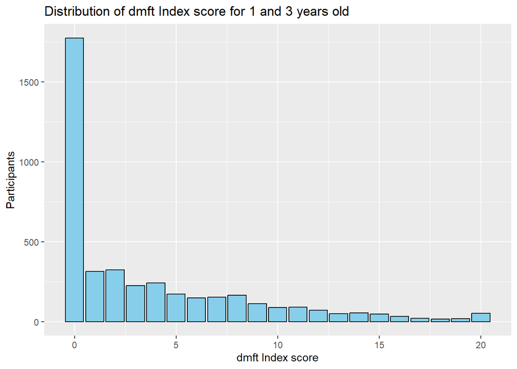

```r
#See distribution

ggplot(data = examen13, aes(x = dmft_ICDAS)) +
  geom_bar(fill = "skyblue", color = "black") +
  labs(x = "dmft Index score", y = "Participants", title = "Distribution of dmft Index score for 1 and 3 years old")
```

Caries experience based on dmft_ICDAS

```r
examen13 <- examen13 %>%
  mutate(cariesexp = case_when(
    dmft_ICDAS > 0 ~ 1,
    TRUE ~ 0
  )) %>%
  mutate(cariesexp = factor(cariesexp, levels = c(0, 1), labels = c("No caries", "Caries")))

summary(examen13$cariesexp)
```

```
## No caries    Caries
##      1776      2393
```

dmft(copd)

```r
#Assign a value to 1 to the following letters: B, C, D, E, G
examen13 <- examen13 %>%
  mutate(
    across(
      starts_with("MA_3"),
      ~case_when(
        str_detect(., "[BCDEG]") ~ 1,
        TRUE ~ 0)
    ))

#create variable dmft
examen13 <- examen13 %>%
  mutate(dmft = rowSums(across(starts_with("MA_3"), ~. > 0)))

glimpse(examen13)
```

```
## Rows: 4,169
## Columns: 108
## $ M4_104     <dbl> 3, 1, 3, 1, 1, 3, 3, 1, 1, 1, 1, 3, 1, 1, 1, 1, 1, 1, 1, 1,…
## $ MA_208     <dbl> 1, 1, 1, 1, 1, 1, 1, 1, 1, 1, 1, 1, 1, 1, 1, 1, 1, 1, 1, 1,…
## $ MA_304A    <dbl> 0, 0, 0, 0, 0, 0, 0, 0, 0, 0, 0, 0, 0, 0, 0, 0, 0, 0, 0, 0,…
## $ MA_304B    <dbl> 0, 0, 0, 0, 0, 0, 0, 0, 0, 0, 0, 0, 0, 0, 0, 0, 0, 0, 0, 0,…
## $ MA_304C    <dbl> 0, 0, 0, 0, 0, 0, 0, 0, 0, 0, 0, 0, 0, 0, 0, 0, 0, 0, 0, 0,…
## $ MA_304D    <dbl> 0, 0, 0, 0, 0, 0, 0, 0, 0, 0, 0, 0, 0, 0, 0, 0, 0, 0, 0, 0,…
## $ MA_304E    <dbl> 0, 0, 0, 0, 0, 0, 0, 0, 0, 0, 0, 0, 0, 0, 0, 0, 0, 0, 0, 0,…
## $ MA_304F    <dbl> 0, 0, 0, 0, 0, 0, 0, 0, 0, 0, 0, 0, 0, 0, 0, 0, 0, 0, 0, 0,…
## $ MA_304G    <dbl> 0, 0, 0, 0, 0, 0, 0, 0, 0, 0, 0, 0, 0, 0, 0, 0, 0, 0, 0, 0,…
## $ MA_304H    <dbl> 0, 0, 0, 0, 0, 0, 0, 0, 0, 0, 0, 0, 0, 0, 0, 0, 0, 0, 0, 0,…
## $ MA_304I    <dbl> 0, 0, 0, 0, 0, 0, 0, 0, 0, 0, 0, 0, 0, 0, 0, 0, 0, 0, 0, 0,…
## $ MA_304J    <dbl> 0, 0, 0, 0, 0, 0, 0, 0, 0, 0, 0, 0, 0, 0, 0, 0, 0, 0, 0, 0,…
## $ MA_306A    <dbl> 0, 0, 0, 0, 0, 0, 0, 0, 0, 0, 0, 0, 0, 0, 0, 0, 0, 0, 0, 0,…
```

[output cut: 95 more lines]

```r
summary(examen13$dmft)
```

```
##    Min. 1st Qu.  Median    Mean 3rd Qu.    Max.
##   0.000   0.000   0.000   1.038   1.000  20.000
```

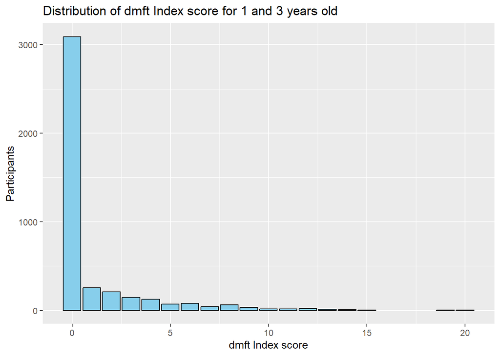

```r
#See distribution
ggplot(data = examen13, aes(x = dmft)) +
  geom_bar(fill = "skyblue", color = "black") +
  labs(x = "dmft Index score", y = "Participants", title = "Distribution of dmft Index score for 1 and 3 years old")
```

### Caries severity in 1-3 years old

Caries severity is binary, classified as:

- 1 years old: any sign of smooth-surface caries in children under 3 yrs of age (smooth surface will only)
- 3 years old: one or more decayed (does not include non-cavitated), missing (due to caries), or filled smooth surfaces in primary maxillary anterior teeth. or a decayed, missing, or filled score of greater than or equal to 4.

This means:

```r
#Calculating non-cavitated and cavitaded caries in anterior teeth, for caries severity of children 1yo
examen13 <- examen13 %>%
mutate(score_ant = rowSums(across(c(score53, score52, score51, score61, score62, score63, score83))))

#comparing cariesexp in 1yo with severe ECC if dmft >0 or if score_ant > 0

examen13 %>%
  filter(age == 1) %>%
  summarize(proportion = sum(dmft_ICDAS > 0, na.rm = TRUE)/n())
```

```
## # A tibble: 1 × 1
##   proportion
##        <dbl>
## 1      0.319
```

```r
examen13 %>%

  filter(age == 1) %>%
  summarize(prop = sum(score_ant > 0, na.rm = TRUE)/n()) #this one will be used
```

```
## # A tibble: 1 × 1
##    prop
##   <dbl>
## 1 0.228
```

```r
examen13 %>%
  filter(age == 1) %>%
  summarize(proportion = sum(dmft > 0, na.rm = TRUE)/n())
```

```
## # A tibble: 1 × 1
##   proportion
##        <dbl>
## 1     0.0545
```

```r
#for cariessev we will take into account normal dmft (only cavitated), which is why we will use variables that start with MA instead of score, corresponding to teeth 53 to 63
glimpse(examen13$MA_305C)
```

```
##  num [1:4169] 0 0 0 0 0 0 0 0 0 0 ...
```

```r
examen13 <- examen13 %>%
  mutate(score53_63 = rowSums(across(c(MA_305C, MA_305D, MA_305E, MA_305F, MA_305G, MA_305H)))) %>%
  mutate(cariessev = case_when(
    age == 3 & (score53_63 > 0 | dmft >= 4) ~ 1,
    age == 1 & score_ant > 0 ~ 1,
    TRUE ~ 0
  )) %>%
  mutate(cariessev = factor(cariessev, levels = c(0, 1), labels = c("No severe ECC", "Severe ECC")))

summary(examen13$cariessev)
```

```
## No severe ECC    Severe ECC
##          3090          1079
```

```r
summary(examen13$cariesexp)
```

```
## No caries    Caries
##      1776      2393
```

## 5 years old

Select variables (like 1y old) Exclude 1M from the analysis (because the outcome is ECC). Letters A and L.

```r
examen5 <- examen5completa %>%
  dplyr::select(M4_104, MB_208, MB_304B, MB_304C, MB_304D, MB_304E, MB_304F, MB_304G, MB_304H, MB_304I, MB_304J, MB_304K, MB_306B, MB_306C, MB_306D, MB_306E, MB_306F, MB_306G, MB_306H, MB_306I, MB_306J, MB_306K, MB_305B, MB_305C, MB_305D, MB_305E, MB_305F, MB_305G, MB_305H, MB_305I, MB_305J, MB_305K, MB_307B, MB_307C, MB_307D, MB_307E, MB_307F, MB_307G, MB_307H, MB_307I, MB_307J, MB_307K, ID_HOGAR, ID_PERSONA) %>%
  mutate(age = M4_104,
         ICDAS55 = MB_304B,
         ICDAS54 = MB_304C,
         ICDAS53 = MB_304D,
         ICDAS52 = MB_304E,
         ICDAS51 = MB_304F,
         ICDAS61 = MB_304G,
         ICDAS62 = MB_304H,
         ICDAS63 = MB_304I,
         ICDAS64 = MB_304J,
         ICDAS65 = MB_304K,
         ICDAS85 = MB_306B,
         ICDAS84 = MB_306C,
         ICDAS83 = MB_306D,
         ICDAS82 = MB_306E,
         ICDAS81 = MB_306F,
         ICDAS71 = MB_306G,
         ICDAS72 = MB_306H,
         ICDAS73 = MB_306I,
         ICDAS74 = MB_306J,
         ICDAS75 = MB_306K,
         COP55 = MB_305B,
         COP54 = MB_305C,
         COP53 = MB_305D,
         COP52 = MB_305E,
         COP51 = MB_305F,
         COP61 = MB_305G,
         COP62 = MB_305H,
         COP63 = MB_305I,
         COP64 = MB_305J,
         COP65 = MB_305K,
         COP85 = MB_307B,
         COP84 = MB_307C,
         COP83 = MB_307D,
         COP82 = MB_307E,
         COP81 = MB_307F,
         COP71 = MB_307G,
         COP72 = MB_307H,
         COP73 = MB_307I,
         COP74 = MB_307J,
         COP75 = MB_307K)
```

### Missing data

```r
examen5 %>%
  filter(MB_208 == 2) %>%
  dplyr::select(ID_PERSONA)
```

```
## # A tibble: 1 × 1
##     ID_PERSONA
##          <dbl>
## 1 688820130106
```

```r
examen5 %>%
  filter(if_any(everything(), is.na)) %>%
  dplyr::select(ID_PERSONA) #no NAs but we will still exclude participant, everything is 0
```

```
## # A tibble: 1 × 1
##     ID_PERSONA
##          <dbl>
## 1 688820130106
```

Caries experience: with ICDAS

Experiencia modificada: includes cavitaded and non-cavitaded carious lesions.

304: ICDAS 55-65 306: ICDAS 85-75

Caries if: * 2: first/distinct visual change in enamel (ICDAS 1 and 2) * 3: Localized enamel breakdown (considered cavitated) (ICDAS 3) * 4: underlying dark shadow from dentin without enamel breakdown (ICDAS 4) * 5: distinc cavity with visible dentin (ICDAS 5) * 6: extensive cavity with visible dentin (ICDAS 6)

2 is non-cavitated, 3-6 are cavitated.

Not caries if: 0 or 9

New categorization: * No caries: 0 if 0 or 9 * Non-cavitated: 1 if 2 * Cavitated: 2 if 3, 4, 5 or 6

dmft including non-cavitated lessions

```r
#Assign a value to 1 to the following numbers: 2, 3, 4, 5, 6

head(examen5$ICDAS55, 20)
```

```
##  [1] "0" "2" "4" "0" "0" "6" "2" "0" "5" "0" "2" "2" "0" "2" "2" "2" "2" "2" "0"
## [20] "2"
```

```r
examen5 <- examen5 %>%
  mutate(
    across(
      starts_with("ICDAS"),
      ~case_when(
        str_detect(., "^[23456]$") ~ 1,
        TRUE ~ 0)
    ))
head(examen5$ICDAS55, 20)
```

```
##  [1] 0 1 1 0 0 1 1 0 1 0 1 1 0 1 1 1 1 1 0 1
```

dmft: cavitated and non-cavitated

Only count missing and filled, decayed is being counted with ICDAS classification.

1 if: C (filled with caries), D (filled without caries), E (missing due to caries), G (prosthesis, crown, retainer, veneer) 0 if: A (healthy), F (sealant), H (not registered), B (cavitated)

```r
#Assign a value of 1 to the following letters:

head(examen5$COP51, 20)
```

```
##  [1] "A" "A" "A" "A" "A" "B" "B" "A" "B" "A" "B" "A" "A" "A" "A" "A" "A" "A" "A"
## [20] "A"
```

```r
examen5 <- examen5 %>%
  mutate(
    across(
      starts_with("COP"),
      ~case_when(
        str_detect(., "[CDEG]") ~ 1,
        TRUE ~ 0)
    ))
head(examen5$COP51, 20)
```

```
##  [1] 0 0 0 0 0 0 0 0 0 0 0 0 0 0 0 0 0 0 0 0
```

```r
#Create variable dmft_ICDAS that includes the sum of both ICDAS and COP variables

#first: create dummy variable for each tooth that assings 1 if either ICDAS or COP is greater than 0, 0 otherwise. For example, if ICDAS51 is 1, then dmft51 = 1. If COP51 is 1, then dmft51 = 1. If both are 1, then dmft51 = 1. If both are 0, then dmft51 = 0.

examen5 <- examen5 %>%
  mutate(score55 = case_when(
    ICDAS55 > 0 | COP55 > 0 ~ 1, TRUE ~ 0),
    score54 = case_when(
    ICDAS54 > 0 | COP54 > 0 ~ 1, TRUE ~ 0),
    score53 = case_when(
    ICDAS53 > 0 | COP53 > 0 ~ 1, TRUE ~ 0),
    score52 = case_when(
    ICDAS52 > 0 | COP52 > 0 ~ 1, TRUE ~ 0),
    score51 = case_when(
    ICDAS51 > 0 | COP51 > 0 ~ 1, TRUE ~ 0),
    score61 = case_when(
    ICDAS61 > 0 | COP61 > 0 ~ 1, TRUE ~ 0),
    score62 = case_when(
    ICDAS62 > 0 | COP62 > 0 ~ 1, TRUE ~ 0),
    score63 = case_when(
    ICDAS63 > 0 | COP63 > 0 ~ 1, TRUE ~ 0),
    score64 = case_when(
    ICDAS64 > 0 | COP64 > 0 ~ 1, TRUE ~ 0),
    score65 = case_when(
    ICDAS65 > 0 | COP65 > 0 ~ 1, TRUE ~ 0),
    score85 = case_when(
    ICDAS85 > 0 | COP85 > 0 ~ 1, TRUE ~ 0),
    score84 = case_when(
    ICDAS84 > 0 | COP84 > 0 ~ 1, TRUE ~ 0),
    score83 = case_when(
    ICDAS83 > 0 | COP83 > 0 ~ 1, TRUE ~ 0),
    score82 = case_when(
    ICDAS82 > 0 | COP82 > 0 ~ 1, TRUE ~ 0),
    score81 = case_when(
    ICDAS81 > 0 | COP81 > 0 ~ 1, TRUE ~ 0),
    score71 = case_when(
    ICDAS71 > 0 | COP71 > 0 ~ 1, TRUE ~ 0),
    score72 = case_when(
    ICDAS72 > 0 | COP72 > 0 ~ 1, TRUE ~ 0),
    score73 = case_when(
    ICDAS73 > 0 | COP73 > 0 ~ 1, TRUE ~ 0),
    score74 = case_when(
    ICDAS74 > 0 | COP74 > 0 ~ 1, TRUE ~ 0),
    score75 = case_when(
    ICDAS75 > 0 | COP75 > 0 ~ 1, TRUE ~ 0))

#sum the dummy variables
examen5 <- examen5 %>%
  mutate(dmft_ICDAS = rowSums(across(starts_with("score"), ~. > 0)))

summary(examen5$dmft_ICDAS) #now the max is 20
```

```
##    Min. 1st Qu.  Median    Mean 3rd Qu.    Max.
##   0.000   2.000   6.000   6.683  10.000  20.000
```

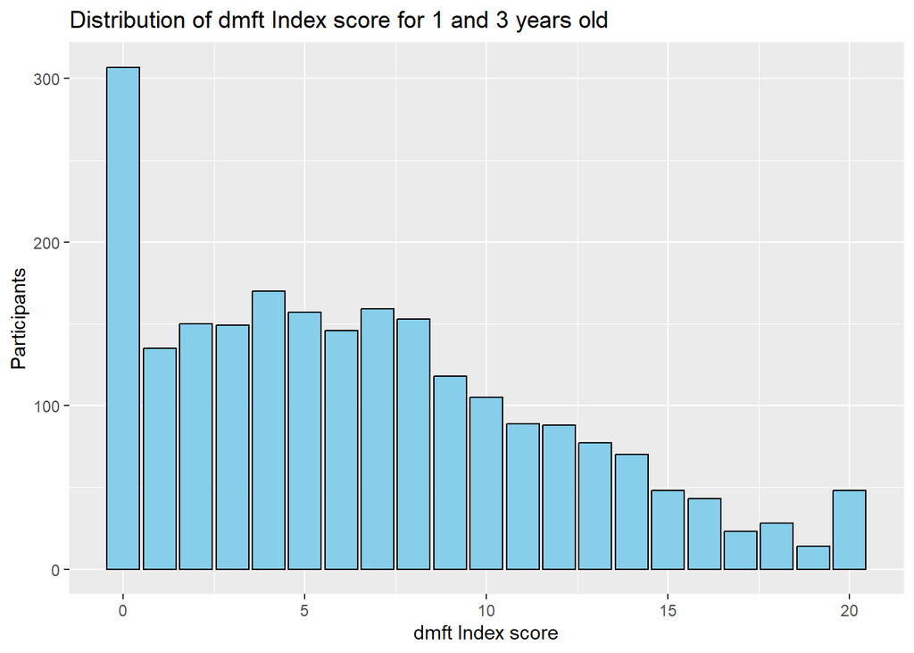

```r
#See distribution

ggplot(data = examen5, aes(x = dmft_ICDAS)) +
  geom_bar(fill = "skyblue", color = "black") +
  labs(x = "dmft Index score", y = "Participants", title = "Distribution of dmft Index score for 1 and 3 years old")
```

Caries experience based on dmft_ICDAS

```r
examen5 <- examen5 %>%
  mutate(cariesexp = case_when(
    dmft_ICDAS > 0 ~ 1,
    TRUE ~ 0
  )) %>%
  mutate(cariesexp = factor(cariesexp, levels = c(0, 1), labels = c("No caries", "Caries")))

summary(examen5$cariesexp)
```

```
## No caries    Caries
##       307      1970
```

dmft

```r
#Assign a value to 1 to the following numbers: 1, 2, 3, 4, 7
examen5 <- examen5 %>%
  mutate(
    across(
      starts_with("MB_3"),
      ~case_when(
        str_detect(., "^[12347]$|^[BCDEG]$") ~ 1,
        TRUE ~ 0
      )))

#create variable dmft
examen5 <- examen5 %>%
  mutate(dmft = rowSums(across(starts_with("MB_3"), ~. > 0)))

summary(examen5$dmft)
```

```
##    Min. 1st Qu.  Median    Mean 3rd Qu.    Max.
##   0.000   2.000   6.000   7.211  11.000  30.000
```

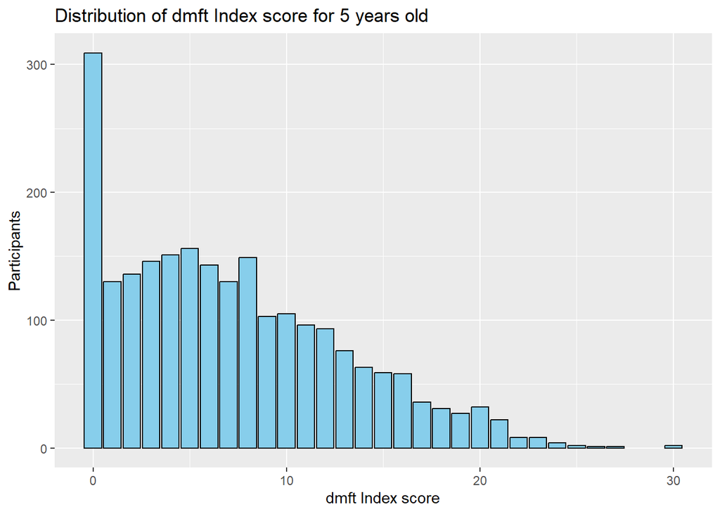

```r
#See distribution
ggplot(data = examen5, aes(x = dmft)) +
  geom_bar(fill = "skyblue", color = "black") +
  labs(x = "dmft Index score", y = "Participants", title = "Distribution of dmft Index score for 5 years old")
```

### Caries severity in 5 years old

Caries severity is binary, classified as:

```r
examen5 <- examen5 %>%
  mutate(score53_63 = rowSums(across(c(MB_305C, MB_305D, MB_305E, MB_305F, MB_305G, MB_305H)))) %>%
  mutate(cariessev = case_when(
    score53_63 > 0 | dmft >= 6 ~ 1,
    TRUE ~ 0
  )) %>%
  mutate(cariessev = factor(cariessev, levels = c(0, 1), labels = c("No severe ECC", "Severe ECC")))

summary(examen5$cariessev)
```

```
## No severe ECC    Severe ECC
##           939          1338
```

```r
summary(examen5$cariesexp)
```

```
## No caries    Caries
##       307      1970
```

## Merge datasets

```r
ensab <- ninos %>%
  left_join(examen13 %>% dplyr::select(MA_208, ID_PERSONA, dmft, dmft_ICDAS, cariesexp, cariessev), by = "ID_PERSONA") %>%
  left_join(examen5 %>% dplyr::select(MB_208, ID_PERSONA, dmft, dmft_ICDAS, cariesexp, cariessev), by = "ID_PERSONA") %>%
  mutate(dmft = coalesce(dmft.x, dmft.y),
         dmft_ICDAS = coalesce(dmft_ICDAS.x, dmft_ICDAS.y),
         cariesexp = coalesce(cariesexp.x, cariesexp.y),
         cariessev = coalesce(cariessev.x, cariessev.y)) %>%
  dplyr::select(-dmft.x, -dmft.y, -dmft_ICDAS.x, -dmft_ICDAS.y,
         -cariesexp.x, -cariesexp.y, -cariessev.x, -cariessev.y)
```

## Missing clinical examination

```r
#show rows with missin data in clinical portion

missing <- ensab %>%
  filter(MA_208 == 2 | MB_208 == 2)

ensab %>%
  filter(MA_208 == 2 | MB_208 == 2) %>%
  count()
```

```
## # A tibble: 1 × 1
##       n
##   <int>
## 1     3
```

```r
ensab <- ensab %>%
  filter(MA_208 == 1 | MB_208 == 1) %>%
  dplyr::select(-MB_208, -MA_208)

#only  3 children did not have the clinical examination portion. We'll exclude them. Now the sample size is 6443 children.
```

### Distribution and summary of outcome

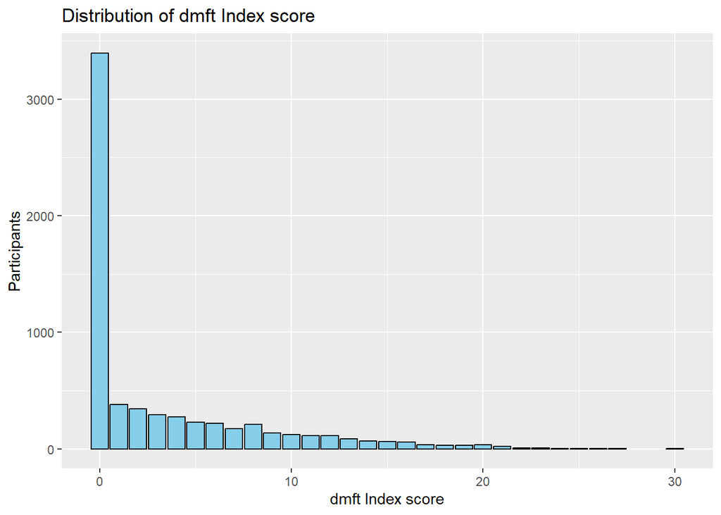

```r
ggplot(data = ensab, aes(x = dmft)) +
  geom_bar(fill = "skyblue", color = "black") +
  labs(x = "dmft Index score", y = "Participants", title = "Distribution of dmft Index score")
```

```r
summary(ensab$dmft)
```

```
##    Min. 1st Qu.  Median    Mean 3rd Qu.    Max.
##    0.00    0.00    0.00    3.22    5.00   30.00
```

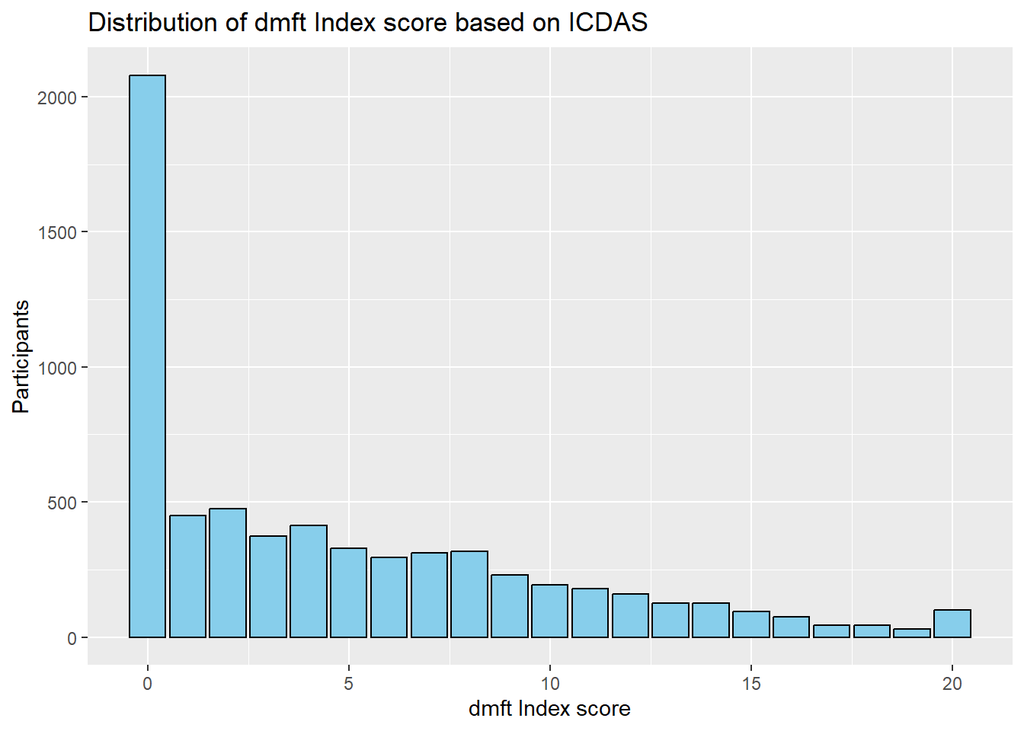

```r
ggplot(data = ensab, aes(x = dmft_ICDAS)) +
  geom_bar(fill = "skyblue", color = "black") +
  labs(x = "dmft Index score", y = "Participants", title = "Distribution of dmft Index score based on ICDAS")
```

```r
#looks much more different, as it is counting all stages of cavities now

summary(ensab$dmft_ICDAS)
```

```
##    Min. 1st Qu.  Median    Mean 3rd Qu.    Max.
##   0.000   0.000   3.000   4.707   8.000  20.000
```

```r
summary(ensab$cariesexp)
```

```
## No caries    Caries
##      2080      4363
```

```r
prop.table(table(ensab$cariesexp))
```

```
##
## No caries    Caries
##  0.322831  0.677169
```

```r
summary(ensab$cariessev)
```

```
## No severe ECC    Severe ECC
##          4026          2417
```

```r
prop.table(table(ensab$cariessev))
```

```
##
## No severe ECC    Severe ECC
##     0.6248642     0.3751358
```

Making cariessev not binary but ordinal, named cariessev3 (cariessev with 3 categories): No caries, Non-severe ECC, Severe ECC

```r
ensab <- ensab %>%
  mutate(cariessev3 = case_when(
    cariesexp == "No caries" ~ 0,
    cariessev == "No severe ECC" & cariesexp == "Caries" ~ 1,
    cariessev == "Severe ECC" ~ 2
  )) %>%
  mutate(cariessev3 = factor(cariessev3, levels = c(0, 1, 2), labels = c("No ECC", "Non-severe ECC", "Severe ECC"), ordered = TRUE))

table(ensab$cariessev3)
```

```
##
##         No ECC Non-severe ECC     Severe ECC
##           2080           1946           2417
```

```r
prop.table(table(ensab$cariessev3))
```

```
##
##         No ECC Non-severe ECC     Severe ECC
##      0.3228310      0.3020332      0.3751358
```

# Key variables

Age: M3_100C

It really is categorical and not continuous.

```r
glimpse(ensab$M3_100C)
```

```
##  num [1:6443] 5 3 5 5 1 5 3 5 1 5 ...
```

```r
summary(ensab$M3_100C)
```

```
##    Min. 1st Qu.  Median    Mean 3rd Qu.    Max.
##   1.000   1.000   3.000   3.058   5.000   5.000
```

```r
#rename M2_100C to age
ensab <- ensab %>%
  rename(age = M3_100C) %>%
  mutate(age = factor(age,
                      levels = c(1, 3, 5),
                      labels = c("1", "3", "5")))

summary(ensab$age)
```

```
##    1    3    5
## 2088 2079 2276
```

## Exposure: Nutrition

M3_229AA, M3_229AB, M3_229BA, M3_229BB, M3_229CA, M3_229CB, M3_229DA, M3_229DB, M3_229EA, M3_229EB, M3_229FA, M3_229FB, M3_229GA, M3_229GB, M3_229HA, M3_229HB, M3_229IA, M3_229IB,

1. Cereals, roots, tubers, plantain: carbs
2. Vegetables, greens, green legumes: veg
3. Fruits: fruit
4. Meat, eggs, dried legumes and vegetables: prot
5. Dairy products: dairy
6. Fats and oils: fats
7. Sugars and sweets: sugar
8. Sodas and soft drinks: soda
9. Juices, natural or artificial: juice

carbs, veg, fruit, prot, dairy, fats, sugar, soda, juice

```r
#make all variables starting with M3_229 to numeric

ensab <- ensab %>%
  mutate(across(starts_with("M3_229"), as.numeric))
#frequency of each variable

ensab %>%
  dplyr::select(M3_229AA:M3_229IB) %>%
  pivot_longer(cols = everything(), names_to = "Variable", values_to = "Value") %>%
  group_by(Variable, Value) %>%
  summarise(Frequency = n(), .groups = "drop") %>%
  arrange(Variable, desc(Value)) %>%
  print(n = 100)
```

```
## # A tibble: 72 × 3
##    Variable Value Frequency
##    <chr>    <dbl>     <int>
##  1 M3_229AA     4      5335
##  2 M3_229AA     3       926
##  3 M3_229AA     2       121
##  4 M3_229AA     1        61
##  5 M3_229AB     3        13
##  6 M3_229AB     2      4269
##  7 M3_229AB     1      2100
##  8 M3_229AB    NA        61
##  9 M3_229BA     4      2536
## 10 M3_229BA     3      2288
## 11 M3_229BA     2       701
## 12 M3_229BA     1       918
```

[output cut: 60 more lines]

```r
ensab %>%
  group_by(M3_229AA, M3_229AB) %>%
  count()
```

```
## # A tibble: 9 × 3
## # Groups:   M3_229AA, M3_229AB [9]
##   M3_229AA M3_229AB     n
##      <dbl>    <dbl> <int>
## 1        1       NA    61
## 2        2        1    87
## 3        2        2    34
## 4        3        1   506
## 5        3        2   415
## 6        3        3     5
## 7        4        1  1507
## 8        4        2  3820
## 9        4        3     8
```

```r
#renaming variables for interpretation

ensab <- ensab %>%
  rename(carbs_week = M3_229AA,
         carbs_day = M3_229AB,
         veg_week = M3_229BA,
         veg_day = M3_229BB,
         fruit_week = M3_229CA,
         fruit_day = M3_229CB,
         prot_week = M3_229DA,
         prot_day = M3_229DB,
         dairy_week = M3_229EA,
         dairy_day = M3_229EB,
         fats_week = M3_229FA,
         fats_day = M3_229FB,
         sugar_week = M3_229GA,
         sugar_day = M3_229GB,
         soda_week = M3_229HA,
         soda_day = M3_229HB,
         juice_week = M3_229IA,
         juice_day = M3_229IB)

#categorizing with factor for weekly and daily intake

ensab <- ensab %>%
  mutate(across(contains("week"), ~ factor(.,
    levels = c(1, 2, 3, 4),
    labels = c("Never", "1x", "2-3x", "4-6x")
    )))

ensab <- ensab %>%
  mutate(across(contains("day"), ~ case_when(
    is.na(.) ~ 0,
    . == 3 ~ NA,
    TRUE ~ .))) %>%
  mutate(across(contains("day"), ~ factor(.,
    levels = c(0, 1, 2),
    labels = c("Never", "1x", "2+x")
  )))

# frequency of weekly and daily intake

ensab %>%
  group_by(carbs_week, carbs_day) %>%
  count()
```

```
## # A tibble: 9 × 3
## # Groups:   carbs_week, carbs_day [9]
##   carbs_week carbs_day     n
##   <fct>      <fct>     <int>
## 1 Never      Never        61
## 2 1x         1x           87
## 3 1x         2+x          34
## 4 2-3x       1x          506
## 5 2-3x       2+x         415
## 6 2-3x       <NA>          5
## 7 4-6x       1x         1507
## 8 4-6x       2+x        3820
## 9 4-6x       <NA>          8
```

```r
ensab %>%
  group_by(veg_week, veg_day) %>%
  count()
```

```
## # A tibble: 10 × 3
## # Groups:   veg_week, veg_day [10]
##    veg_week veg_day     n
##    <fct>    <fct>   <int>
##  1 Never    Never     918
##  2 1x       1x        560
##  3 1x       2+x       140
##  4 1x       <NA>        1
##  5 2-3x     1x       1440
##  6 2-3x     2+x       841
##  7 2-3x     <NA>        7
##  8 4-6x     1x       1252
##  9 4-6x     2+x      1275
## 10 4-6x     <NA>        9
```

```r
ensab %>%
  group_by(fruit_week, fruit_day) %>%
  count()
```

```
## # A tibble: 10 × 3
## # Groups:   fruit_week, fruit_day [10]
##    fruit_week fruit_day     n
##    <fct>      <fct>     <int>
##  1 Never      Never       644
##  2 1x         1x          424
##  3 1x         2+x          72
##  4 1x         <NA>          2
##  5 2-3x       1x         1263
##  6 2-3x       2+x         616
##  7 2-3x       <NA>          3
##  8 4-6x       1x         1501
##  9 4-6x       2+x        1915
## 10 4-6x       <NA>          3
```

```r
ensab %>%
  group_by(prot_week, prot_day) %>%
  count()
```

```
## # A tibble: 9 × 3
## # Groups:   prot_week, prot_day [9]
##   prot_week prot_day     n
##   <fct>     <fct>    <int>
## 1 Never     Never       38
## 2 1x        1x          93
## 3 1x        2+x         32
## 4 2-3x      1x         723
## 5 2-3x      2+x        460
## 6 2-3x      <NA>         3
## 7 4-6x      1x        1622
## 8 4-6x      2+x       3463
## 9 4-6x      <NA>         9
```

```r
ensab %>%
  group_by(dairy_week, dairy_day) %>%
  count()
```

```
## # A tibble: 9 × 3
## # Groups:   dairy_week, dairy_day [9]
##   dairy_week dairy_day     n
##   <fct>      <fct>     <int>
## 1 Never      Never       409
## 2 1x         1x          231
## 3 1x         2+x          43
## 4 2-3x       1x          732
## 5 2-3x       2+x         406
## 6 2-3x       <NA>          3
## 7 4-6x       1x         1307
## 8 4-6x       2+x        3306
## 9 4-6x       <NA>          6
```

```r
ensab %>%
  group_by(fats_week, fats_day) %>%
  count()
```

```
## # A tibble: 9 × 3
## # Groups:   fats_week, fats_day [9]
##   fats_week fats_day     n
##   <fct>     <fct>    <int>
## 1 Never     Never      951
## 2 1x        1x         813
## 3 1x        2+x         70
## 4 1x        <NA>         1
## 5 2-3x      1x        1665
## 6 2-3x      2+x        584
## 7 2-3x      <NA>         6
## 8 4-6x      1x        1125
## 9 4-6x      2+x       1228
```

```r
ensab %>%
  group_by(sugar_week, sugar_day) %>%
  count()
```

```
## # A tibble: 10 × 3
## # Groups:   sugar_week, sugar_day [10]
##    sugar_week sugar_day     n
##    <fct>      <fct>     <int>
##  1 Never      Never       669
##  2 1x         1x          650
##  3 1x         2+x          71
##  4 1x         <NA>          2
##  5 2-3x       1x         1254
##  6 2-3x       2+x         391
##  7 2-3x       <NA>          3
##  8 4-6x       1x         1321
##  9 4-6x       2+x        2075
## 10 4-6x       <NA>          7
```

```r
ensab %>%
  group_by(soda_week, soda_day) %>%
  count()
```

```
## # A tibble: 9 × 3
## # Groups:   soda_week, soda_day [9]
##   soda_week soda_day     n
##   <fct>     <fct>    <int>
## 1 Never     Never     2827
## 2 1x        1x        1397
## 3 1x        2+x        156
## 4 1x        <NA>         1
## 5 2-3x      1x        1095
## 6 2-3x      2+x        328
## 7 2-3x      <NA>         3
## 8 4-6x      1x         350
## 9 4-6x      2+x        286
```

```r
ensab %>%
  group_by(juice_week, juice_day) %>%
  count()
```

```
## # A tibble: 9 × 3
## # Groups:   juice_week, juice_day [9]
##   juice_week juice_day     n
##   <fct>      <fct>     <int>
## 1 Never      Never       277
## 2 1x         1x          170
## 3 1x         2+x          41
## 4 2-3x       1x          559
## 5 2-3x       2+x         430
## 6 2-3x       <NA>          2
## 7 4-6x       1x         1007
## 8 4-6x       2+x        3953
## 9 4-6x       <NA>          4
```

### Nutrition index for each category

```r
ensab <- ensab %>%
  mutate(carbs = case_when(
    carbs_week == "Never" & carbs_day == "Never" ~ 0,
    carbs_week == "1x" & carbs_day == "1x" ~ 1,
    carbs_week == "1x" & carbs_day == "2+x" ~ 2,
    carbs_week == "2-3x" & carbs_day == "1x" ~ 3,
    carbs_week == "2-3x" & carbs_day == "2+x" ~ 4,
    carbs_week == "4-6x" & carbs_day == "1x" ~ 5,
    carbs_week == "4-6x" & carbs_day == "2+x" ~ 6,
    is.na(carbs_day) ~ NA))

summary(ensab$carbs)
```

```
##    Min. 1st Qu.  Median    Mean 3rd Qu.    Max.    NA's
##   0.000   5.000   6.000   5.255   6.000   6.000      13
```

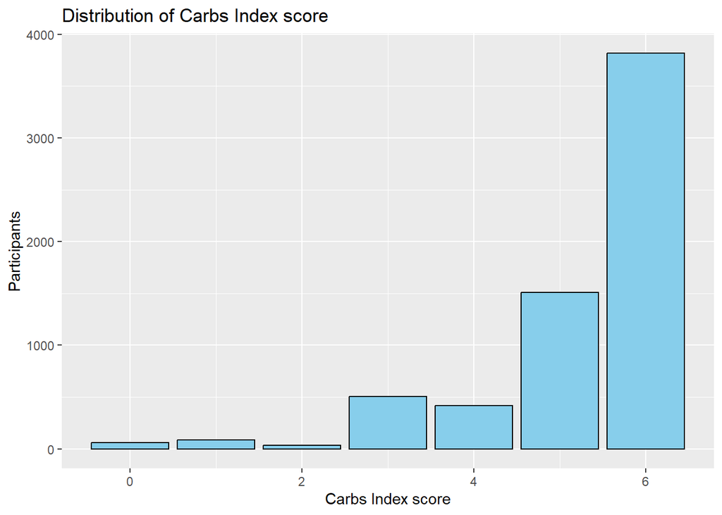

```r
ggplot(data = ensab, aes(x = carbs)) +
  geom_bar(fill = "skyblue", color = "black") +
  labs(x = "Carbs Index score", y = "Participants", title = "Distribution of Carbs Index score")
```

```r
# collapse carbs 2 and 3, and 4 and 5

ensab <- ensab %>%
  mutate(carbs = case_when(
    carbs == 3 ~ 2,  # Recode 3 to 2
    carbs == 4 ~ 3,  # Recode 4 to 3
    carbs == 5 ~ 3,  # Recode 5 to 3
    carbs == 6 ~ 4,  # Recode 6 to 4
    TRUE ~ carbs     # Keep other values unchanged
  )) %>%
  mutate(carbs = factor(carbs,
                        levels = c(0, 1, 2, 3, 4),
                        labels = c("Never", "1x", "2-3x", "4-7x", "8+x")))
summary(ensab$carbs)
```

```
## Never    1x  2-3x  4-7x   8+x  NA's
##    61    87   540  1922  3820    13
```

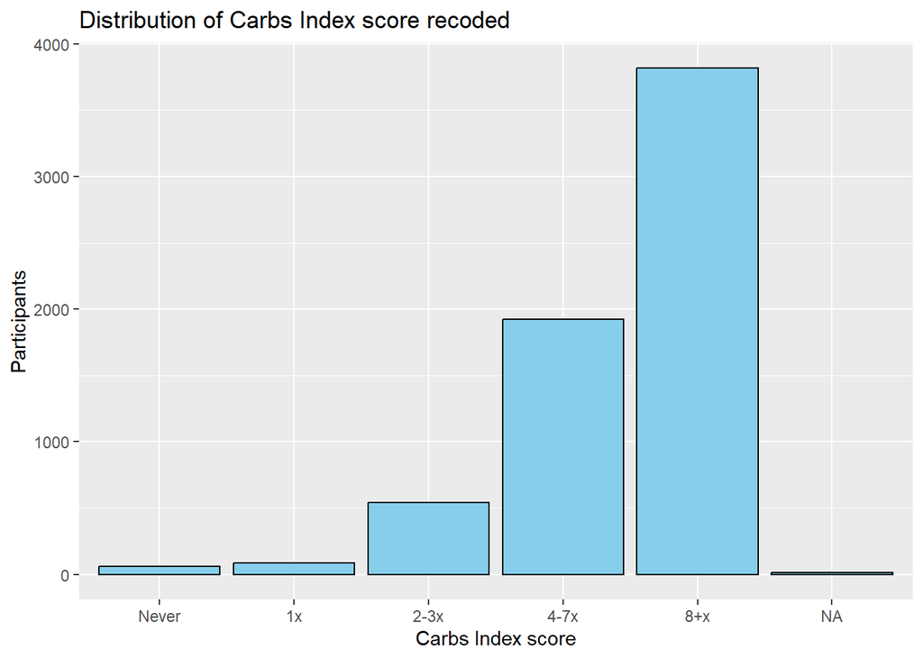

```r
ggplot(data = ensab, aes(x = carbs)) +
  geom_bar(fill = "skyblue", color = "black") +
  labs(x = "Carbs Index score", y = "Participants", title = "Distribution of Carbs Index score recoded")
```

```r
#Vegetables

ensab <- ensab %>%
  mutate(veg = case_when(
    veg_week == "Never" & veg_day == "Never" ~ 0,
    veg_week == "1x" & veg_day == "1x" ~ 1,
    veg_week == "1x" & veg_day == "2+x" ~ 2,
    veg_week == "2-3x" & veg_day == "1x" ~ 3,
    veg_week == "2-3x" & veg_day == "2+x" ~ 4,
    veg_week == "4-6x" & veg_day == "1x" ~ 5,
    veg_week == "4-6x" & veg_day == "2+x" ~ 6,
    is.na(veg_day) ~ NA))

summary(ensab$veg)
```

```
##    Min. 1st Qu.  Median    Mean 3rd Qu.    Max.    NA's
##   0.000   2.000   4.000   3.491   5.000   6.000      17
```

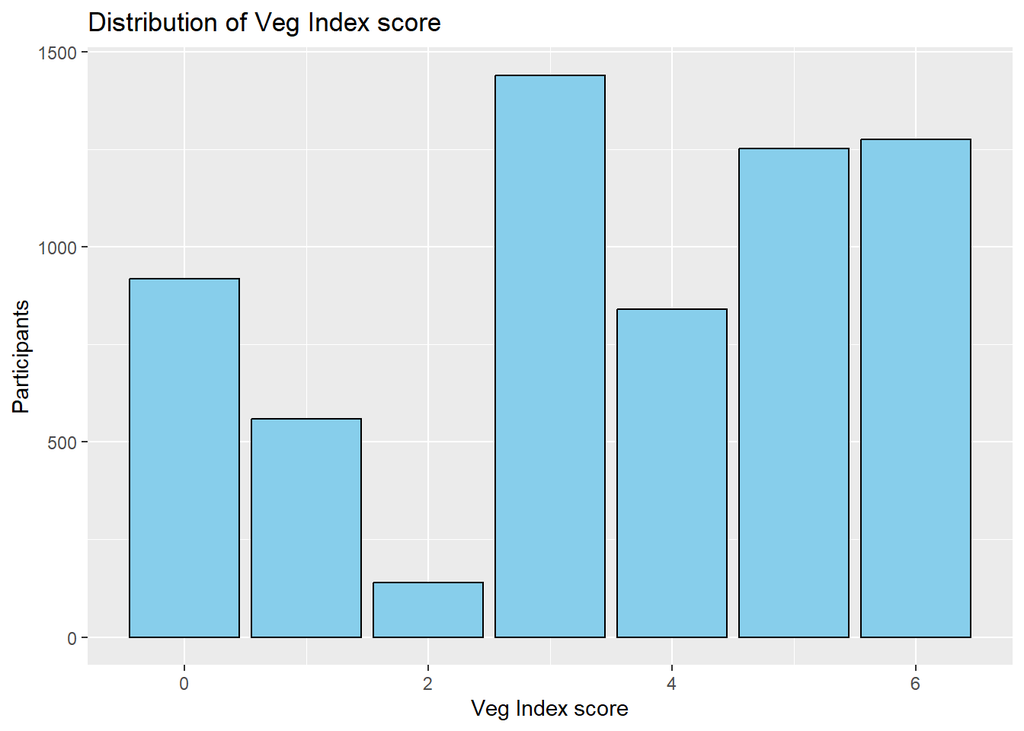

```r
ggplot(data = ensab, aes(x = veg)) +
  geom_bar(fill = "skyblue", color = "black") +
  labs(x = "Veg Index score", y = "Participants", title = "Distribution of Veg Index score")
```

```r
# collapse veg 2 and 3, and 4 and 5

summary(ensab$veg)
```

```
##    Min. 1st Qu.  Median    Mean 3rd Qu.    Max.    NA's
##   0.000   2.000   4.000   3.491   5.000   6.000      17
```

```r
ensab <- ensab %>%
  mutate(veg = case_when(
    veg == 3 ~ 2,  # Recode 3 to 2
    veg == 4 ~ 3,  # Recode 4 to 3
    veg == 5 ~ 3,  # Recode 5 to 3
    veg == 6 ~ 4,  # Recode 6 to 4
    TRUE ~ veg     # Keep other values unchanged
  )) %>%
  mutate(veg = factor(veg,
                        levels = c(0, 1, 2, 3, 4),
                        labels = c("Never", "1x", "2-3x", "4-7x", "8+x")))
summary(ensab$veg)
```

```
## Never    1x  2-3x  4-7x   8+x  NA's
##   918   560  1580  2093  1275    17
```

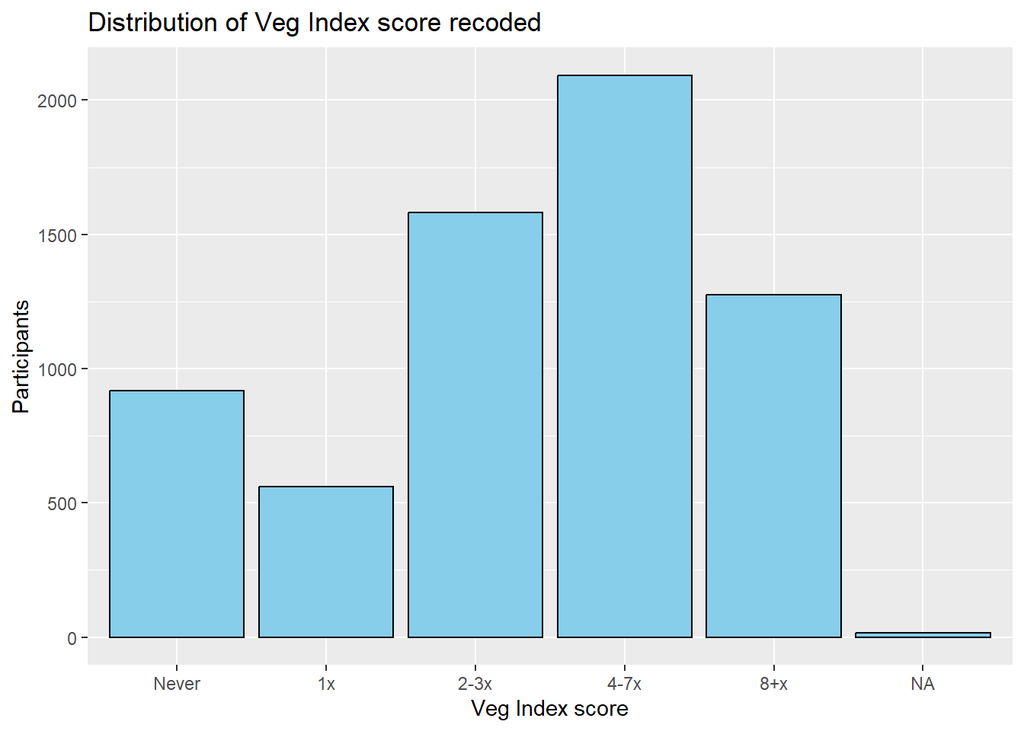

```r
ggplot(data = ensab, aes(x = veg)) +
  geom_bar(fill = "skyblue", color = "black") +
  labs(x = "Veg Index score", y = "Participants", title = "Distribution of Veg Index score recoded")
```

```r
#Fruit

ensab <- ensab %>%
  mutate(fruit = case_when(
    fruit_week == "Never" & fruit_day == "Never" ~ 0,
    fruit_week == "1x" & fruit_day == "1x" ~ 1,
    fruit_week == "1x" & fruit_day == "2+x" ~ 2,
    fruit_week == "2-3x" & fruit_day == "1x" ~ 3,
    fruit_week == "2-3x" & fruit_day == "2+x" ~ 4,
    fruit_week == "4-6x" & fruit_day == "1x" ~ 5,
    fruit_week == "4-6x" & fruit_day == "2+x" ~ 6,
    is.na(fruit_day) ~ NA))

summary(ensab$fruit)
```

```
##    Min. 1st Qu.  Median    Mean 3rd Qu.    Max.    NA's
##   0.000   3.000   5.000   4.012   6.000   6.000       8
```

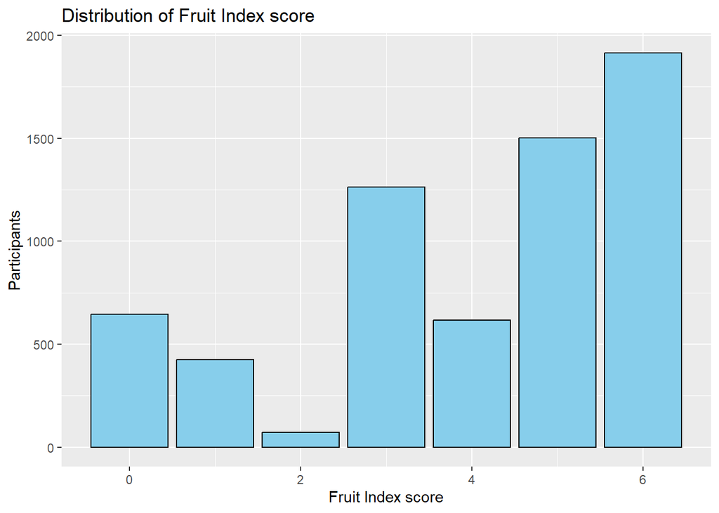

```r
ggplot(data = ensab, aes(x = fruit)) +
  geom_bar(fill = "skyblue", color = "black") +
  labs(x = "Fruit Index score", y = "Participants", title = "Distribution of Fruit Index score")
```

```r
# collapse fruit 2 and 3, and 4 and 5

summary(ensab$fruit)
```

```
##    Min. 1st Qu.  Median    Mean 3rd Qu.    Max.    NA's
##   0.000   3.000   5.000   4.012   6.000   6.000       8
```

```r
ensab <- ensab %>%
  mutate(fruit = case_when(
    fruit == 3 ~ 2,  # Recode 3 to 2
    fruit == 4 ~ 3,  # Recode 4 to 3
    fruit == 5 ~ 3,  # Recode 5 to 3
    fruit == 6 ~ 4,  # Recode 6 to 4
    TRUE ~ fruit     # Keep other values unchanged
  )) %>%
  mutate(fruit = factor(fruit,
                        levels = c(0, 1, 2, 3, 4),
                        labels = c("Never", "1x", "2-3x", "4-7x", "8+x")))
summary(ensab$fruit)
```

```
## Never    1x  2-3x  4-7x   8+x  NA's
##   644   424  1335  2117  1915     8
```

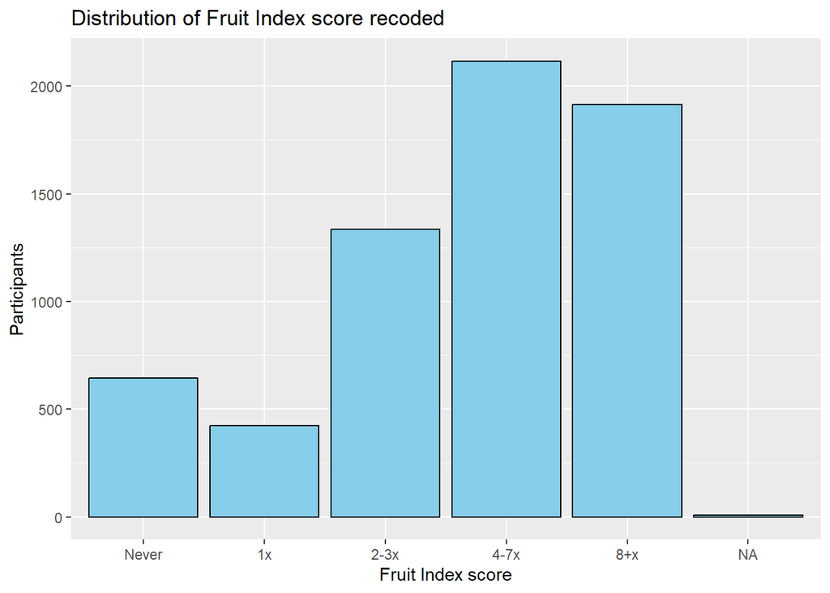

```r
ggplot(data = ensab, aes(x = fruit)) +
  geom_bar(fill = "skyblue", color = "black") +
  labs(x = "Fruit Index score", y = "Participants", title = "Distribution of Fruit Index score recoded")
```

```r
#Protein

ensab <- ensab %>%
  mutate(prot = case_when(
    prot_week == "Never" & prot_day == "Never" ~ 0,
    prot_week == "1x" & prot_day == "1x" ~ 1,
    prot_week == "1x" & prot_day == "2+x" ~ 2,
    prot_week == "2-3x" & prot_day == "1x" ~ 3,
    prot_week == "2-3x" & prot_day == "2+x" ~ 4,
    prot_week == "4-6x" & prot_day == "1x" ~ 5,
    prot_week == "4-6x" & prot_day == "2+x" ~ 6,
    is.na(prot_day) ~ NA))

summary(ensab$prot)
```

```
##    Min. 1st Qu.  Median    Mean 3rd Qu.    Max.    NA's
##    0.00    5.00    6.00    5.14    6.00    6.00      12
```

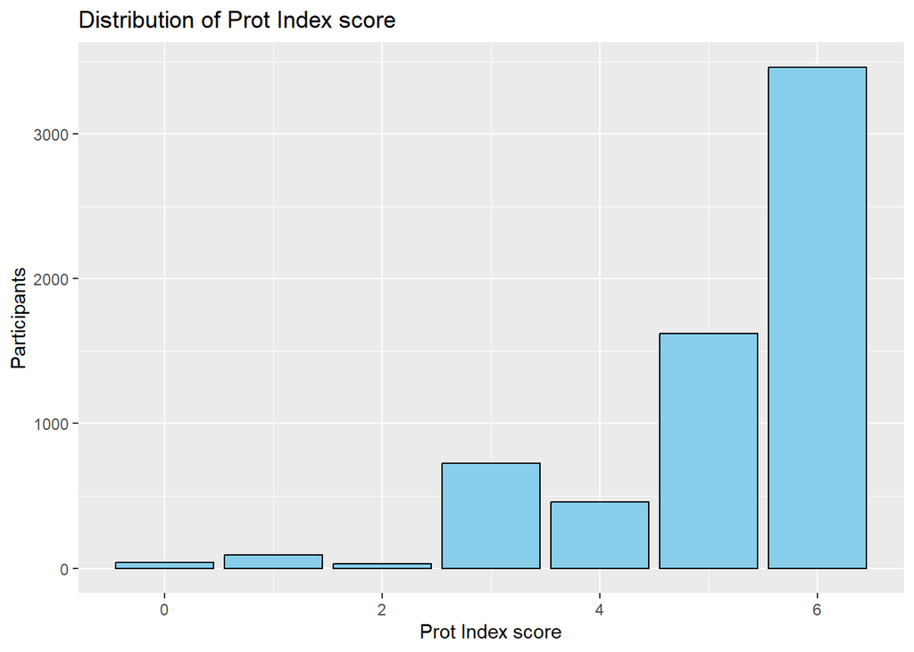

```r
ggplot(data = ensab, aes(x = prot)) +
  geom_bar(fill = "skyblue", color = "black") +
  labs(x = "Prot Index score", y = "Participants", title = "Distribution of Prot Index score")
```

```r
summary(ensab$prot)
```

```
##    Min. 1st Qu.  Median    Mean 3rd Qu.    Max.    NA's
##    0.00    5.00    6.00    5.14    6.00    6.00      12
```

```r
ensab <- ensab %>%
  mutate(prot = case_when(
    prot == 3 ~ 2,  # Recode 3 to 2
    prot == 4 ~ 3,  # Recode 4 to 3
    prot == 5 ~ 3,  # Recode 5 to 3
    prot == 6 ~ 4,  # Recode 6 to 4
    TRUE ~ prot     # Keep other values unchanged
  )) %>%
  mutate(prot = factor(prot,
                       levels = c(0, 1, 2, 3, 4),
                       labels = c("Never", "1x", "2-3x", "4-7x", "8+x")))
summary(ensab$prot)
```

```
## Never    1x  2-3x  4-7x   8+x  NA's
##    38    93   755  2082  3463    12
```

```r
summary(ensab$prot)
```

```
## Never    1x  2-3x  4-7x   8+x  NA's
##    38    93   755  2082  3463    12
```

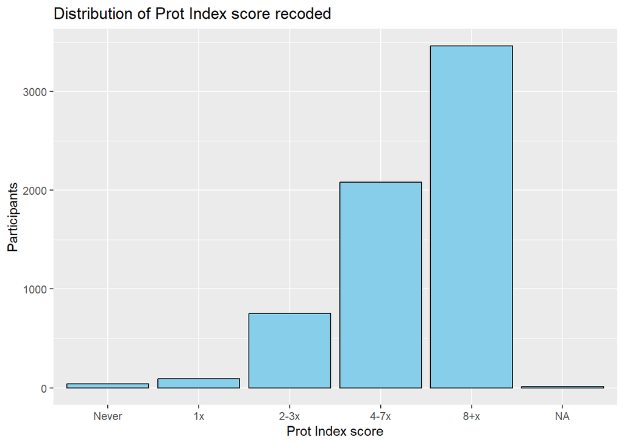

```r
ggplot(data = ensab, aes(x = prot)) +
  geom_bar(fill = "skyblue", color = "black") +
  labs(x = "Prot Index score", y = "Participants", title = "Distribution of Prot Index score recoded")
```

```r
#dairy

ensab <- ensab %>%
  mutate(dairy = case_when(
    dairy_week == "Never" & dairy_day == "Never" ~ 0,
    dairy_week == "1x" & dairy_day == "1x" ~ 1,
    dairy_week == "1x" & dairy_day == "2+x" ~ 2,
    dairy_week == "2-3x" & dairy_day == "1x" ~ 3,
    dairy_week == "2-3x" & dairy_day == "2+x" ~ 4,
    dairy_week == "4-6x" & dairy_day == "1x" ~ 5,
    dairy_week == "4-6x" & dairy_day == "2+x" ~ 6,
    is.na(dairy_day) ~ NA))

summary(ensab$dairy)
```

```
##    Min. 1st Qu.  Median    Mean 3rd Qu.    Max.    NA's
##   0.000   4.000   6.000   4.742   6.000   6.000       9
```

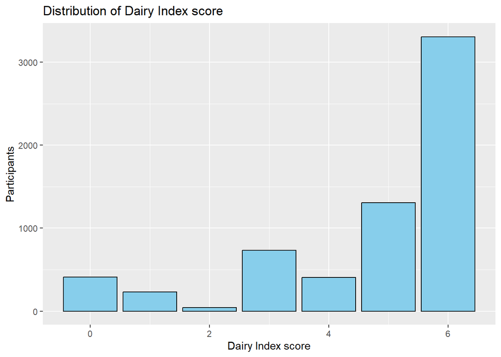

```r
ggplot(data = ensab, aes(x = dairy)) +
  geom_bar(fill = "skyblue", color = "black") +
  labs(x = "Dairy Index score", y = "Participants", title = "Distribution of Dairy Index score")
```

```r
summary(ensab$dairy)
```

```
##    Min. 1st Qu.  Median    Mean 3rd Qu.    Max.    NA's
##   0.000   4.000   6.000   4.742   6.000   6.000       9
```

```r
ensab <- ensab %>%
  mutate(dairy = case_when(
    dairy == 3 ~ 2,  # Recode 3 to 2
    dairy == 4 ~ 3,  # Recode 4 to 3
    dairy == 5 ~ 3,  # Recode 5 to 3
    dairy == 6 ~ 4,  # Recode 6 to 4
    TRUE ~ dairy     # Keep other values unchanged
  )) %>%
  mutate(dairy = factor(dairy,
                        levels = c(0, 1, 2, 3, 4),
                        labels = c("Never", "1x", "2-3x", "4-7x", "8+x")))
summary(ensab$dairy)
```

```
## Never    1x  2-3x  4-7x   8+x  NA's
##   409   231   775  1713  3306     9
```

```r
summary(ensab$dairy)
```

```
## Never    1x  2-3x  4-7x   8+x  NA's
##   409   231   775  1713  3306     9
```

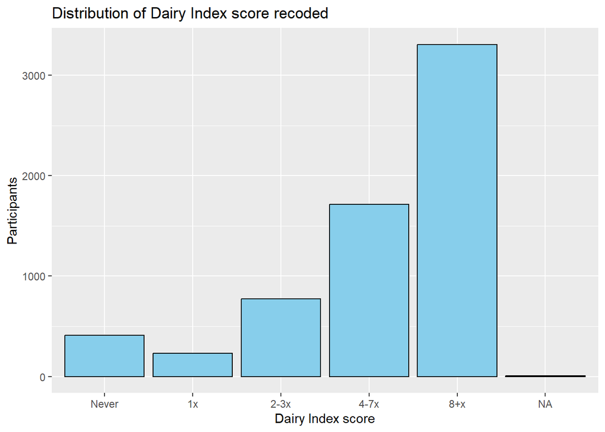

```r
ggplot(data = ensab, aes(x = dairy)) +
  geom_bar(fill = "skyblue", color = "black") +
  labs(x = "Dairy Index score", y = "Participants", title = "Distribution of Dairy Index score recoded")
```

```r
#Fats

ensab <- ensab %>%
  mutate(fats = case_when(
    fats_week == "Never" & fats_day == "Never" ~ 0,
    fats_week == "1x" & fats_day == "1x" ~ 1,
    fats_week == "1x" & fats_day == "2+x" ~ 2,
    fats_week == "2-3x" & fats_day == "1x" ~ 3,
    fats_week == "2-3x" & fats_day == "2+x" ~ 4,
    fats_week == "4-6x" & fats_day == "1x" ~ 5,
    fats_week == "4-6x" & fats_day == "2+x" ~ 6,
    is.na(fats_day) ~ NA))

summary(ensab$fats)
```

```
##    Min. 1st Qu.  Median    Mean 3rd Qu.    Max.    NA's
##   0.000   1.000   3.000   3.306   5.000   6.000       7
```

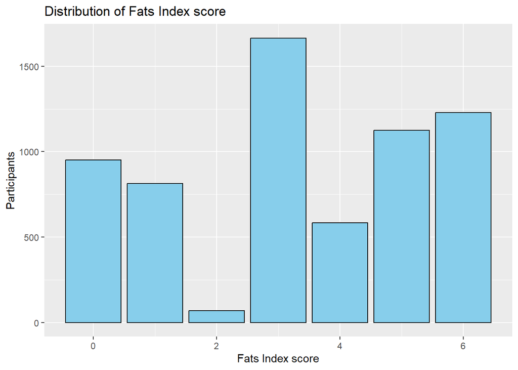

```r
ggplot(data = ensab, aes(x = fats)) +
  geom_bar(fill = "skyblue", color = "black") +
  labs(x = "Fats Index score", y = "Participants", title = "Distribution of Fats Index score")
```

```r
summary(ensab$fats)
```

```
##    Min. 1st Qu.  Median    Mean 3rd Qu.    Max.    NA's
##   0.000   1.000   3.000   3.306   5.000   6.000       7
```

```r
ensab <- ensab %>%
  mutate(fats = case_when(
    fats == 3 ~ 2,  # Recode 3 to 2
    fats == 4 ~ 3,  # Recode 4 to 3
    fats == 5 ~ 3,  # Recode 5 to 3
    fats == 6 ~ 4,  # Recode 6 to 4
    TRUE ~ fats     # Keep other values unchanged
  )) %>%
  mutate(fats = factor(fats,
                       levels = c(0, 1, 2, 3, 4),
                       labels = c("Never", "1x", "2-3x", "4-7x", "8+x")))
summary(ensab$fats)
```

```
## Never    1x  2-3x  4-7x   8+x  NA's
##   951   813  1735  1709  1228     7
```

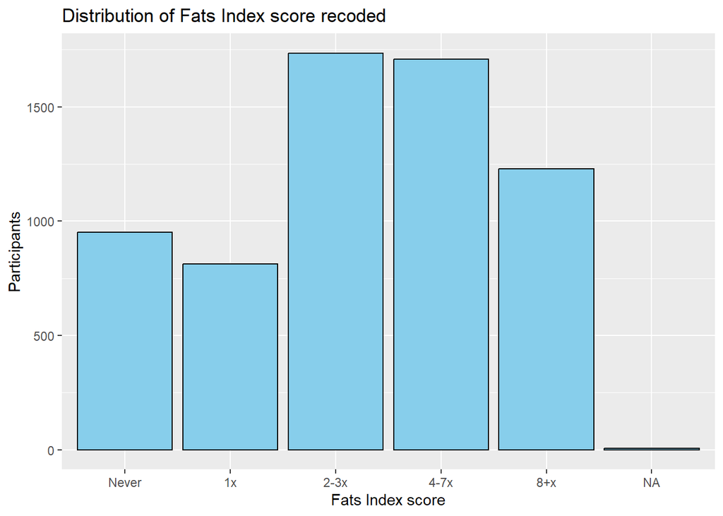

```r
ggplot(data = ensab, aes(x = fats)) +
  geom_bar(fill = "skyblue", color = "black") +
  labs(x = "Fats Index score", y = "Participants", title = "Distribution of Fats Index score recoded")
```

```r
#Sugar

ensab <- ensab %>%
  mutate(sugar = case_when(
    sugar_week == "Never" & sugar_day == "Never" ~ 0,
    sugar_week == "1x" & sugar_day == "1x" ~ 1,
    sugar_week == "1x" & sugar_day == "2+x" ~ 2,
    sugar_week == "2-3x" & sugar_day == "1x" ~ 3,
    sugar_week == "2-3x" & sugar_day == "2+x" ~ 4,
    sugar_week == "4-6x" & sugar_day == "1x" ~ 5,
    sugar_week == "4-6x" & sugar_day == "2+x" ~ 6,
    is.na(sugar_day) ~ NA))

summary(ensab$sugar)
```

```
##    Min. 1st Qu.  Median    Mean 3rd Qu.    Max.    NA's
##   0.000   3.000   5.000   3.914   6.000   6.000      12
```

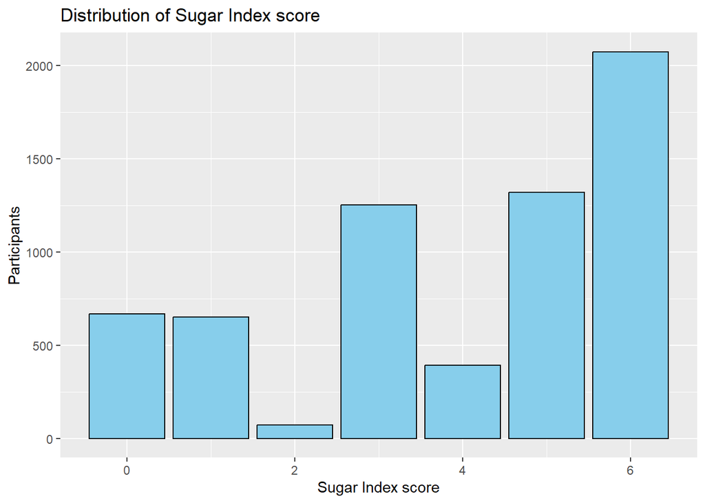

```r
ggplot(data = ensab, aes(x = sugar)) +
  geom_bar(fill = "skyblue", color = "black") +
  labs(x = "Sugar Index score", y = "Participants", title = "Distribution of Sugar Index score")
```

```r
summary(ensab$sugar)
```

```
##    Min. 1st Qu.  Median    Mean 3rd Qu.    Max.    NA's
##   0.000   3.000   5.000   3.914   6.000   6.000      12
```

```r
ensab <- ensab %>%
  mutate(sugar = case_when(
    sugar == 3 ~ 2,  # Recode 3 to 2
    sugar == 4 ~ 3,  # Recode 4 to 3
    sugar == 5 ~ 3,  # Recode 5 to 3
    sugar == 6 ~ 4,  # Recode 6 to 4
    TRUE ~ sugar     # Keep other values unchanged
  )) %>%
  mutate(sugar = factor(sugar,
                        levels = c(0, 1, 2, 3, 4),
                        labels = c("Never", "1x", "2-3x", "4-7x", "8+x")))
summary(ensab$sugar)
```

```
## Never    1x  2-3x  4-7x   8+x  NA's
##   669   650  1325  1712  2075    12
```

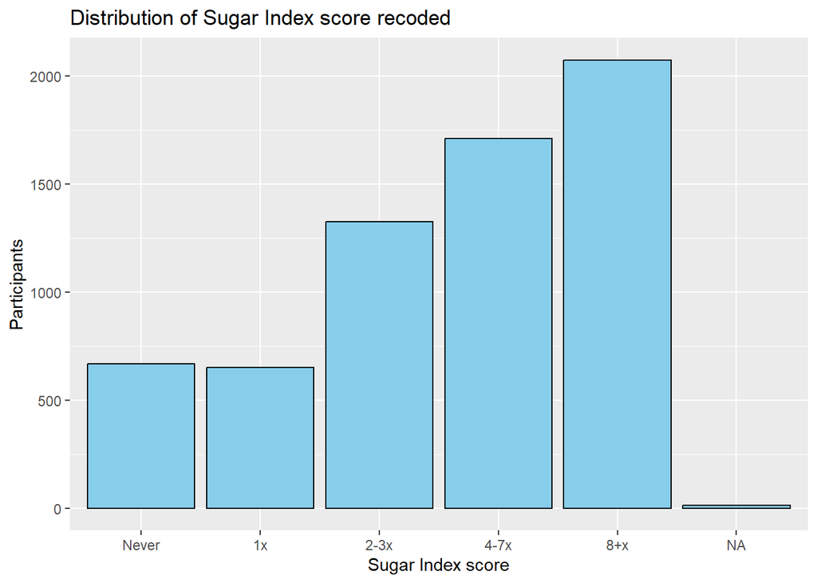

```r
ggplot(data = ensab, aes(x = sugar)) +
  geom_bar(fill = "skyblue", color = "black") +
  labs(x = "Sugar Index score", y = "Participants", title = "Distribution of Sugar Index score recoded")
```

```r
#Soda

ensab <- ensab %>%
  mutate(soda = case_when(
    soda_week == "Never" & soda_day == "Never" ~ 0,
    soda_week == "1x" & soda_day == "1x" ~ 1,
    soda_week == "1x" & soda_day == "2+x" ~ 2,
    soda_week == "2-3x" & soda_day == "1x" ~ 3,
    soda_week == "2-3x" & soda_day == "2+x" ~ 4,
    soda_week == "4-6x" & soda_day == "1x" ~ 5,
    soda_week == "4-6x" & soda_day == "2+x" ~ 6,
    is.na(soda_day) ~ NA))

summary(ensab$soda)
```

```
##    Min. 1st Qu.  Median    Mean 3rd Qu.    Max.    NA's
##   0.000   0.000   1.000   1.518   3.000   6.000       4
```

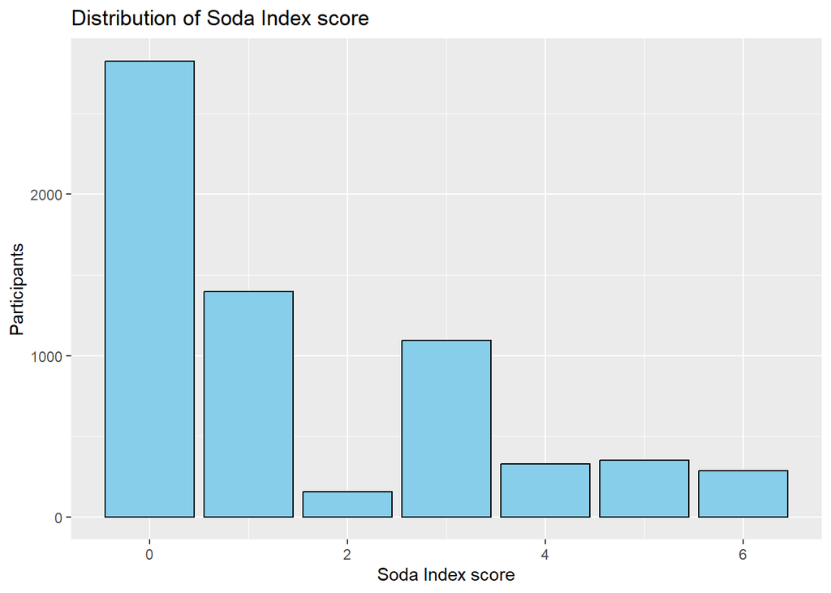

```r
ggplot(data = ensab, aes(x = soda)) +
  geom_bar(fill = "skyblue", color = "black") +
  labs(x = "Soda Index score", y = "Participants", title = "Distribution of Soda Index score")
```

```r
summary(ensab$soda)
```

```
##    Min. 1st Qu.  Median    Mean 3rd Qu.    Max.    NA's
##   0.000   0.000   1.000   1.518   3.000   6.000       4
```

```r
ensab <- ensab %>%
  mutate(soda = case_when(
    soda == 3 ~ 2,  # Recode 3 to 2
    soda == 4 ~ 3,  # Recode 4 to 3
    soda == 5 ~ 3,  # Recode 5 to 3
    soda == 6 ~ 4,  # Recode 6 to 4
    TRUE ~ soda     # Keep other values unchanged
  )) %>%
  mutate(soda = factor(soda,
                       levels = c(0, 1, 2, 3, 4),
                       labels = c("Never", "1x", "2-3x", "4-7x", "8+x")))
summary(ensab$soda)
```

```
## Never    1x  2-3x  4-7x   8+x  NA's
##  2827  1397  1251   678   286     4
```

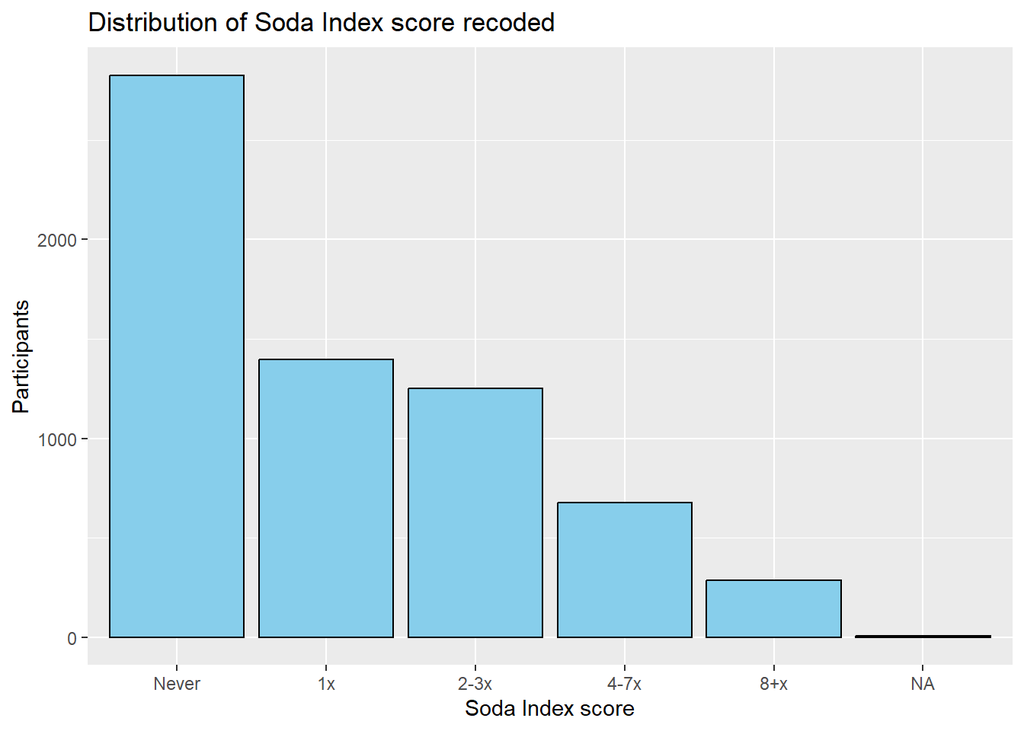

```r
ggplot(data = ensab, aes(x = soda)) +
  geom_bar(fill = "skyblue", color = "black") +
  labs(x = "Soda Index score", y = "Participants", title = "Distribution of Soda Index score recoded")
```

```r
#Juice

ensab <- ensab %>%
  mutate(juice = case_when(
    juice_week == "Never" & juice_day == "Never" ~ 0,
    juice_week == "1x" & juice_day == "1x" ~ 1,
    juice_week == "1x" & juice_day == "2+x" ~ 2,
    juice_week == "2-3x" & juice_day == "1x" ~ 3,
    juice_week == "2-3x" & juice_day == "2+x" ~ 4,
    juice_week == "4-6x" & juice_day == "1x" ~ 5,
    juice_week == "4-6x" & juice_day == "2+x" ~ 6,
    is.na(juice_day) ~ NA))

summary(ensab$juice)
```

```
##    Min. 1st Qu.  Median    Mean 3rd Qu.    Max.    NA's
##   0.000   5.000   6.000   5.034   6.000   6.000       6
```

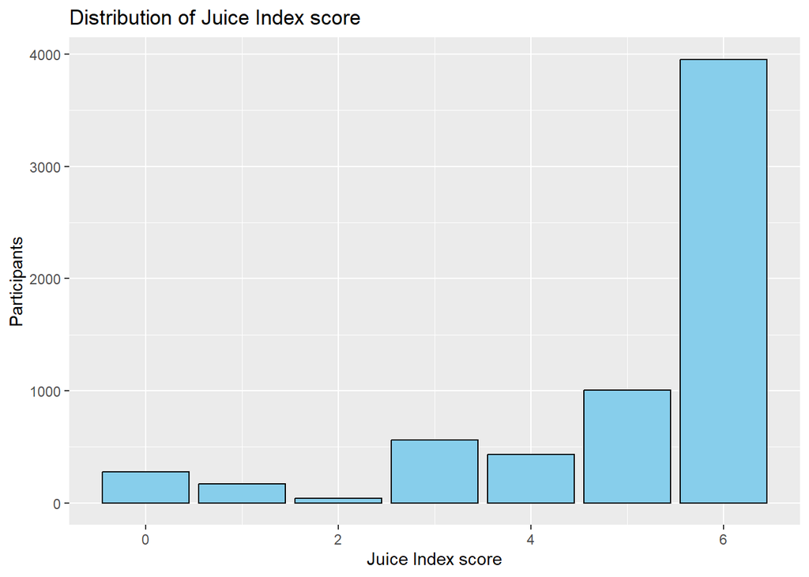

```r
ggplot(data = ensab, aes(x = juice)) +
  geom_bar(fill = "skyblue", color = "black") +
  labs(x = "Juice Index score", y = "Participants", title = "Distribution of Juice Index score")
```

```r
summary(ensab$juice)
```

```
##    Min. 1st Qu.  Median    Mean 3rd Qu.    Max.    NA's
##   0.000   5.000   6.000   5.034   6.000   6.000       6
```

```r
ensab <- ensab %>%
  mutate(juice = case_when(
    juice == 3 ~ 2,  # Recode 3 to 2
    juice == 4 ~ 3,  # Recode 4 to 3
    juice == 5 ~ 3,  # Recode 5 to 3
    juice == 6 ~ 4,  # Recode 6 to 4
    TRUE ~ juice     # Keep other values unchanged
  )) %>%
  mutate(juice = factor(juice,
                        levels = c(0, 1, 2, 3, 4),
                        labels = c("Never", "1x", "2-3x", "4-7x", "8+x")))
summary(ensab$juice)
```

```
## Never    1x  2-3x  4-7x   8+x  NA's
##   277   170   600  1437  3953     6
```

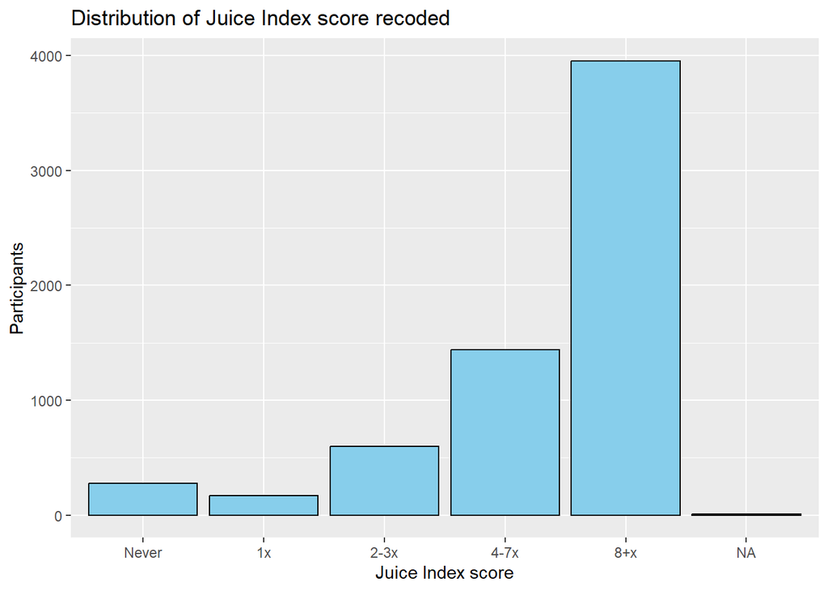

```r
ggplot(data = ensab, aes(x = juice)) +
  geom_bar(fill = "skyblue", color = "black") +
  labs(x = "Juice Index score", y = "Participants", title = "Distribution of Juice Index score recoded")
```

### NAs in all nutrition variables

```r
#check for NAs in all nutrition variables

missingnut <- ensab %>%
  dplyr::select(carbs, veg, fruit, prot, dairy, fats, sugar, soda, juice) %>%
  summarise(across(everything(), ~ sum(is.na(.)))) %>%
  pivot_longer(cols = everything(), names_to = "Variable", values_to = "NAs") %>%
  arrange(desc(NAs))
missingnut
```

```
## # A tibble: 9 × 2
##   Variable   NAs
##   <chr>    <int>
## 1 veg         17
## 2 carbs       13
## 3 prot        12
## 4 sugar       12
## 5 dairy        9
## 6 fruit        8
## 7 fats         7
## 8 juice        6
## 9 soda         4
```

```r
#proportion of missing values
sum(missingnut$NAs)/nrow(ensab) #1.3%, so will exclude. Should now have at least 6355 observations
```

```
## [1] 0.01365823
```

```r
ensab <- ensab %>%
  filter(!is.na(carbs) & !is.na(veg) & !is.na(fruit) & !is.na(prot) & !is.na(dairy) & !is.na(fats) & !is.na(sugar) & !is.na(soda) & !is.na(juice))
#Now we have 6382 observations, which means most of this NAs were from the same participants.
6443-6382 #61 participants had at least one missing value in the nutrition variables
```

```
## [1] 61
```

```r
#check if there are still NAs

ensab %>%
  dplyr::select(carbs, veg, fruit, prot, dairy, fats, sugar, soda, juice) %>%
  summarise(across(everything(), ~ sum(is.na(.)))) %>%
  pivot_longer(cols = everything(), names_to = "Variable", values_to = "NAs") %>%
  arrange(desc(NAs)) #no NAs now
```

```
## # A tibble: 9 × 2
##   Variable   NAs
##   <chr>    <int>
## 1 carbs        0
## 2 veg          0
## 3 fruit        0
## 4 prot         0
## 5 dairy        0
## 6 fats         0
## 7 sugar        0
## 8 soda         0
## 9 juice        0
```

```r
6382/6446*100
```

```
## [1] 99.00714
```

```r
61/6446*100 #0.9463233 missing data on nutrition
```

```
## [1] 0.9463233
```

```r
#Total percentage of participants with missing data
(61+3)/6446*100
```

```
## [1] 0.9928638
```

## Possible confounders or EMM

### Demographic variables

Sex: Sexo

Couldn’t find the codification in the codebook so I had to guess.

```r
glimpse(ensab$Sexo)
```

```
##  num [1:6382] 2 2 1 1 2 2 1 1 2 1 ...
```

```r
ensab <- ensab %>%
  mutate(sex = factor(Sexo,
                         levels = c(1, 2),
                         labels = c("Masculine", "Feminine")))

summary(ensab$sex)
```

```
## Masculine  Feminine
##      3309      3073
```

Ethnicity: M3_113D

```r
glimpse(ensab$M3_113D)
```

```
##  chr [1:6382] "NULL" "NULL" "NULL" "NULL" "NULL" "NULL" "5" "NULL" "NULL" ...
```

```r
ensab %>%
  group_by(M3_113D) %>%
  count()
```

```
## # A tibble: 8 × 2
## # Groups:   M3_113D [8]
##   M3_113D     n
##   <chr>   <int>
## 1 1          30
## 2 10         58
## 3 5          69
## 4 6         194
## 5 7         244
## 6 8          14
## 7 9          56
## 8 NULL     5717
```

### Socioeconomic position

Socioeconomic status: EST_SE_2

```r
glimpse(ensab$EST_SE_2)
```

```
##  num [1:6382] 2 1 1 1 2 1 2 2 2 2 ...
```

```r
ensab <- ensab %>%
  mutate(ses = factor(EST_SE_2,
                           levels = c(1, 2, 3, 4),
                           labels = c("Low low", "Low", "Middle low", "Middle to high")))

summary(ensab$ses)
```

```
##        Low low            Low     Middle low Middle to high
##           2622           2667            999             94
```

Income: M3_119

NMW: national minimum wage (salario minimo legal vigente)

```r
glimpse(ensab$M3_119)
```

```
##  num [1:6382] 3 2 2 2 3 1 8 2 3 2 ...
```

```r
ensab %>%
  group_by(M3_119) %>%
  count()
```

```
## # A tibble: 8 × 2
## # Groups:   M3_119 [8]
##   M3_119     n
##    <dbl> <int>
## 1      1   999
## 2      2  2500
## 3      3  2068
## 4      4   402
## 5      5   112
## 6      6   122
## 7      7    85
## 8      8    94
```

```r
#8 are NAs
ensab %>%
  filter(M3_119 == 8) %>%
  count() #95 NAs
```

```
## # A tibble: 1 × 1
##       n
##   <int>
## 1    94
```

```r
#transform 7 unemployed into 0

ensab <- ensab %>%
  mutate(income = case_when(
    M3_119 == 8 ~ NA,
    M3_119 == 7 ~ 0,
    TRUE ~ M3_119)) %>%
  mutate(income = factor(income,
                         levels = c(0, 1, 2, 3, 4, 5, 6),
                         labels = c("Unemployed", "Less than half NMW", "Half - 1 NMW", "1-2 NMW", "2-3 NMW", "3-4 NMW", "More than 4 NMW")))

summary(ensab$income)
```

```
##         Unemployed Less than half NMW       Half - 1 NMW            1-2 NMW
##                 85                999               2500               2068
##            2-3 NMW            3-4 NMW    More than 4 NMW               NA's
##                402                112                122                 94
```

Educational level of the provider: M3_113F

```r
glimpse(ensab$M3_113F)
```

```
##  chr [1:6382] "NULL" "NULL" "NULL" "NULL" "NULL" "NULL" "6" "NULL" "NULL" ...
```

```r
ensab %>%
  group_by(M3_113F) %>%
  count()
```

```
## # A tibble: 9 × 2
## # Groups:   M3_113F [9]
##   M3_113F     n
##   <chr>   <int>
## 1 1           6
## 2 2           1
## 3 3         122
## 4 4         348
## 5 5          65
## 6 6          65
## 7 7           6
## 8 8          52
## 9 NULL     5717
```

Health insurance coverage/scheme:

Chose REGIMEN over M3_113E because it has less categories plus no missing values, and it reflects the insurance status of the child and not the main provider.

```r
glimpse(ensab$REGIMEN)
```

```
##  num [1:6382] 4 1 2 2 2 2 2 2 1 2 ...
```

```r
#counting NAs in M3_113E

ensab %>%
  filter(M3_113E == 6) %>%
  count()
```

```
## # A tibble: 1 × 1
##       n
##   <int>
## 1    82
```

```r
ensab <- ensab %>%
  mutate(insurance = case_when(
    REGIMEN == 4 ~ 0,
    TRUE ~ REGIMEN)) %>%
  mutate(insurance = factor(insurance,
                           levels = c(0, 1, 2, 3),
                           labels = c("Uninsured", "Contributory", "Subsidized", "Other")))

summary(ensab$insurance)
```

```
##    Uninsured Contributory   Subsidized        Other
##          436         2224         3452          270
```

### Location

Region

```r
glimpse(ensab$Region)
```

```
##  num [1:6382] 3 3 3 3 3 3 3 3 3 3 ...
```

```r
ensab <- ensab %>%
  mutate(region = factor(Region,
                         levels = c(1, 2, 3, 4, 5, 6),
                         labels = c("Atlantic", "Eastern", "Central", "Pacific", "Bogota", "Orinoquia - Amazonia")))

summary(ensab$region)
```

```
##             Atlantic              Eastern              Central
##                 1070                 1084                  968
##              Pacific               Bogota Orinoquia - Amazonia
##                  993                 1169                 1098
```

Urban vs rural: Zona

Will be named location Chose Zona over Clase because it has more universal categories (rural and urban), while Clase has categories according to the national census. However, it has more granularity and could be useful.

```r
glimpse(ensab$Zona)
```

```
##  num [1:6382] 1 1 1 1 1 1 1 1 1 1 ...
```

```r
ensab %>%
  group_by(Zona, .drop = FALSE) %>%
  count()
```

```
## # A tibble: 2 × 2
## # Groups:   Zona [2]
##    Zona     n
##   <dbl> <int>
## 1     1  5216
## 2     2  1166
```

```r
ensab <- ensab %>%
  mutate(location = factor(Zona,
                           levels = c(1, 2),
                           labels = c("Urban", "Rural")))

summary(ensab$location)
```

```
## Urban Rural
##  5216  1166
```

### Potentially interesting variables to check for EMM

M3_201: Where the child spends most of their time Could categorize into home or not home

M3_202: Who takes care of the child 1: Mother or father 2: Relative who is overage

```r
ensab %>%
  group_by(M3_201) %>%
  count()
```

```
## # A tibble: 4 × 2
## # Groups:   M3_201 [4]
##   M3_201     n
##    <dbl> <int>
## 1      1   842
## 2      2   248
## 3      3  5146
## 4      4   146
```

```r
ensab %>%
  group_by(M3_202) %>%
  count()
```

```
## # A tibble: 6 × 2
## # Groups:   M3_202 [6]
##   M3_202     n
##    <dbl> <int>
## 1      1  4891
## 2      2  1276
## 3      3    55
## 4      4    53
## 5      5     5
## 6      6   102
```

# Characteristics of sample: Table 1

## Account for survey design and weights

checking how many children share the same household

```r
ensab %>%
  group_by(ID_HOGAR) %>%
  count() %>%
  arrange(desc(n)) %>%
  filter(n > 1) %>%
  rename(cph = n) %>%
  group_by(cph) %>%
  summarise(prop = n() / nrow(ensab) * 100)
```

```
## # A tibble: 5 × 2
##     cph    prop
##   <int>   <dbl>
## 1     2 10.4
## 2     3  0.987
## 3     4  0.0627
## 4     5  0.0157
## 5     6  0.0157
```

```r
#737 children share the same household with another child included in the study. We won't take it into account for now.
```

Primary sampling unit: municipality

Sampling strata: Could be region or subregion

Documentation about survey package, and understanding finite population correction (fpc)

```r
ensab %>%
  group_by(Subreg) %>%
  count()
```

```
## # A tibble: 16 × 2
## # Groups:   Subreg [16]
##    Subreg     n
##     <dbl> <int>
##  1      1   323
##  2      2   287
##  3      3   178
##  4      4  1169
##  5      5   678
##  6      6   158
##  7      7   290
##  8      8   260
##  9      9   342
## 10     10   306
## 11     11   137
## 12     12   227
## 13     13  1098
## 14     14   406
## 15     15   299
## 16     16   224
```

```r
#Region as strata
survensab <- svydesign(
  ids = ~census_mpio,
  data = ensab,
  strata = ~Region,
  weights = ~Fex_fin,
  nest = TRUE
)

#calculate fpc

reg_raw <- table(ensab$Region)
reg_exp <- svytable(~Region, design = survensab) #expanded number of participants
reg_raw
```

```
##
##    1    2    3    4    5    6
## 1070 1084  968  993 1169 1098
```

```r
reg_exp
```

```
## Region
##         1         2         3         4         5         6
## 630901.17 437475.36 600347.95 429878.16 357573.87  90856.52
```

```r
sum(reg_raw)
```

```
## [1] 6382
```

```r
sum(reg_exp)
```

```
## [1] 2547033
```

```r
#checking ratio of raw vs expanded
sum(reg_raw)/sum(reg_exp)
```

```
## [1] 0.00250566
```

```r
#total sample checking ratio of raw vs expanded
1498/5215631
```

```
## [1] 0.0002872136
```

```r
#calculate the proportion of the population sampled in each region
reg_prop <- reg_raw/reg_exp
reg_prop
```

```
##
##           1           2           3           4           5           6
## 0.001695987 0.002477854 0.001612398 0.002309957 0.003269255 0.012084988
```

```r
ensab <- ensab %>%
  mutate(region_prop = case_when(
    Region == 1 ~ reg_prop[1],
    Region == 2 ~ reg_prop[2],
    Region == 3 ~ reg_prop[3],
    Region == 4 ~ reg_prop[4],
    Region == 5 ~ reg_prop[5],
    Region == 6 ~ reg_prop[6]
  ))

ensab %>%
  group_by(Region) %>%
  summarise(prop = mean(region_prop)) #checking the values for fpc are correct
```

```
## # A tibble: 6 × 2
##   Region    prop
##    <dbl>   <dbl>
## 1      1 0.00170
## 2      2 0.00248
## 3      3 0.00161
## 4      4 0.00231
## 5      5 0.00327
## 6      6 0.0121
```

```r
survensab <- svydesign(
  ids = ~census_mpio,
  data = ensab,
  strata = ~Region,
  weights = ~Fex_fin,
  nest = TRUE,
  options = list(survey.lonely.psu = "adjust"),
  fpc = ~region_prop)

sum(reg_exp)
```

```
## [1] 2547033
```

```r
sum(ensab$Fex_fin)
```

```
## [1] 2547033
```

```r
#adding fpc still didn't work. Using subregion as strata for now

#Subregion as strata
survensab <- svydesign(
  ids = ~census_mpio,
  data = ensab,
  strata = ~Subreg,
  weights = ~Fex_fin,
  nest = TRUE
)

summary(survensab)
```

```
## Stratified 1 - level Cluster Sampling design (with replacement)
## With (196) clusters.
## svydesign(ids = ~census_mpio, data = ensab, strata = ~Subreg,
##     weights = ~Fex_fin, nest = TRUE)
## Probabilities:
##      Min.   1st Qu.    Median      Mean   3rd Qu.      Max.
## 0.0001077 0.0021099 0.0040716 0.0198468 0.0078458 1.0000000
## Stratum Sizes:
##              1   2   3    4   5   6   7   8   9  10  11  12   13  14  15  16
## obs        323 287 178 1169 678 158 290 260 342 306 137 227 1098 406 299 224
## design.PSU  19   8   1    1  42  11   1  17  16  14   8   1   18  19  14   6
## actual.PSU  19   8   1    1  42  11   1  17  16  14   8   1   18  19  14   6
## Data variables:
##  [1] "census_mpio"     "MPIO"            "DPTO"            "age"
##  [5] "M3_113D"         "M3_113E"         "M3_113F"         "M3_119"
##  [9] "M3_201"          "M3_202"          "M3_205"          "M3_213"
## [13] "M3_226"          "M3_206A"         "M3_224"          "M3_225"
## [17] "M3_206B"         "M3_227"          "M3_227A"         "M3_227B"
## [21] "M3_227C"         "M3_227D"         "M3_227E"         "M3_227F"
## [25] "M3_227G"         "M3_227CU"        "carbs_week"      "carbs_day"
## [29] "veg_week"        "veg_day"         "fruit_week"      "fruit_day"
## [33] "prot_week"       "prot_day"        "dairy_week"      "dairy_day"
## [37] "fats_week"       "fats_day"        "sugar_week"      "sugar_day"
## [41] "soda_week"       "soda_day"        "juice_week"      "juice_day"
## [45] "Region"          "Subreg"          "Municipio"       "Fex_fin"
## [49] "Sexo"            "Zona"            "EST_SE_2"        "FRACCION"
## [53] "REGIMEN"         "ID_HOGAR"        "ID_PERSONA"      "Grandesciudades"
## [57] "dmft"            "dmft_ICDAS"      "cariesexp"       "cariessev"
## [61] "cariessev3"      "carbs"           "veg"             "fruit"
## [65] "prot"            "dairy"           "fats"            "sugar"
## [69] "soda"            "juice"           "sex"             "ses"
## [73] "income"          "insurance"       "region"          "location"
## [77] "region_prop"
```

```r
#svymean(~cariesexp, design = survensab)
#Error in onestrat(`attr<-`(x[index, , drop = FALSE], "recentering", recentering),  :
#  Stratum (7) has only one PSU at stage 1

#adjust, certainty, remove
```

## Table 1 stratified by outcome (caries or no caries)

```r
#Total sample

table(ensab$cariesexp)
```

```
##
## No caries    Caries
##      2058      4324
```

```r
svytable(~cariesexp, design = survensab)
```

```
## cariesexp
## No caries    Caries
##  847687.2 1699345.8
```

Age

```r
age_total <- prop.table(svytable(~age, design = survensab))
age_total <- round(age_total * 100, 2)
age_total
```

```
## age
##     1     3     5
## 33.60 33.24 33.16
```

```r
#by outcome (caries experience)
summary(ensab$cariesexp)
```

```
## No caries    Caries
##      2058      4324
```

```r
age_caries <- prop.table(svytable(~age, design = subset(survensab, cariesexp == "Caries")))
age_caries <- round(age_caries * 100, 2)
age_caries
```

```
## age
##     1     3     5
## 14.71 41.31 43.98
```

```r
age_nocaries <- prop.table(svytable(~age, design = subset(survensab, cariesexp == "No caries")))
age_nocaries <- round(age_nocaries * 100, 2)
age_nocaries
```

```
## age
##     1     3     5
## 71.47 17.05 11.49
```

Sex

```r
sex_total <- prop.table(svytable(~sex, design = survensab))
sex_total <- round(sex_total * 100, 2)
sex_total
```

```
## sex
## Masculine  Feminine
##     51.15     48.85
```

```r
#by outcome (cariesexp)

sex_caries <-  prop.table(svytable(~sex, design = subset(survensab, cariesexp == "Caries")))
sex_caries <- round(sex_caries * 100, 2)
sex_caries
```

```
## sex
## Masculine  Feminine
##     52.52     47.48
```

```r
sex_nocaries <- prop.table(svytable(~sex, design = subset(survensab, cariesexp == "No caries")))
sex_nocaries <- round(sex_nocaries*100, 2)
sex_nocaries
```

```
## sex
## Masculine  Feminine
##     48.41     51.59
```

Socioeconomic status

```r
ses_total <- prop.table(svytable(~ses, design = survensab))
ses_total <- round(ses_total * 100, 2)
ses_total
```

```
## ses
##        Low low            Low     Middle low Middle to high
##          42.80          42.04          13.15           2.01
```

```r
#by outcome (cariesexp)

ses_caries <- prop.table(svytable(~ses, design = subset(survensab, cariesexp == "Caries")))
ses_caries <- round(ses_caries * 100, 2)
ses_caries
```

```
## ses
##        Low low            Low     Middle low Middle to high
##          44.09          41.52          12.55           1.84
```

```r
ses_nocaries <- prop.table(svytable(~ses, design = subset(survensab, cariesexp == "No caries")))
ses_nocaries <- round(ses_nocaries * 100, 2)
ses_nocaries
```

```
## ses
##        Low low            Low     Middle low Middle to high
##          40.22          43.08          14.35           2.35
```

Income

```r
income_total <- prop.table(svytable(~income, design = survensab))
income_total <- round(income_total * 100, 2)
income_total
```

```
## income
##         Unemployed Less than half NMW       Half - 1 NMW            1-2 NMW
##               1.53              17.89              43.07              29.39
##            2-3 NMW            3-4 NMW    More than 4 NMW
##               5.43               1.44               1.25
```

```r
#by outcome (cariesexp)

income_caries <- prop.table(svytable(~income, design = subset(survensab, cariesexp == "Caries")))
income_caries <- round(income_caries * 100, 2)
income_caries
```

```
## income
##         Unemployed Less than half NMW       Half - 1 NMW            1-2 NMW
##               1.89              18.67              44.02              28.22
##            2-3 NMW            3-4 NMW    More than 4 NMW
##               4.96               1.30               0.93
```

```r
income_nocaries <- prop.table(svytable(~income, design = subset(survensab, cariesexp == "No caries")))
income_nocaries <- round(income_nocaries * 100, 2)
income_nocaries
```

```
## income
##         Unemployed Less than half NMW       Half - 1 NMW            1-2 NMW
##               0.79              16.31              41.15              31.76
##            2-3 NMW            3-4 NMW    More than 4 NMW
##               6.38               1.71               1.90
```

Region

```r
region_total <- prop.table(svytable(~region, design = survensab))
region_total <- round(region_total * 100, 2)
region_total
```

```
## region
##             Atlantic              Eastern              Central
##                24.77                17.18                23.57
##              Pacific               Bogota Orinoquia - Amazonia
##                16.88                14.04                 3.57
```

```r
paste(region_total, collapse = " ")
```

```
## [1] "24.77 17.18 23.57 16.88 14.04 3.57"
```

```r
#by outcome (cariesexp)

region_caries <- prop.table(svytable(~region, design = subset(survensab, cariesexp == "Caries")))
region_caries <- round(region_caries * 100, 2)
region_caries
```

```
## region
##             Atlantic              Eastern              Central
##                25.84                17.07                24.64
##              Pacific               Bogota Orinoquia - Amazonia
##                14.05                14.49                 3.91
```

```r
paste(region_caries, collapse = " ")
```

```
## [1] "25.84 17.07 24.64 14.05 14.49 3.91"
```

```r
region_nocaries <- prop.table(svytable(~region, design = subset(survensab, cariesexp == "No caries")))
region_nocaries <- round(region_nocaries * 100, 2)
region_nocaries
```

```
## region
##             Atlantic              Eastern              Central
##                22.63                17.40                21.42
##              Pacific               Bogota Orinoquia - Amazonia
##                22.54                13.14                 2.88
```

```r
paste(region_nocaries, collapse = " ")
```

```
## [1] "22.63 17.4 21.42 22.54 13.14 2.88"
```

Area of residence

```r
location_total <- prop.table(svytable(~location, design = survensab))
location_total <- round(location_total * 100, 2)
location_total
```

```
## location
## Urban Rural
## 72.46 27.54
```

```r
#by outcome (cariesexp)

location_caries <- prop.table(svytable(~location, design = subset(survensab, cariesexp == "Caries")))
location_caries <- round(location_caries * 100, 2)
location_caries
```

```
## location
## Urban Rural
## 69.33 30.67
```

```r
location_nocaries <- prop.table(svytable(~location, design = subset(survensab, cariesexp == "No caries")))
location_nocaries <- round(location_nocaries * 100, 2)
location_nocaries
```

```
## location
## Urban Rural
## 78.73 21.27
```

Insurance

```r
insurance_total <- prop.table(svytable(~insurance, design = survensab))
insurance_total <- round(insurance_total * 100, 2)
insurance_total
```

```
## insurance
##    Uninsured Contributory   Subsidized        Other
##         7.07        30.90        58.47         3.56
```

```r
#by outcome (cariesexp)

insurance_caries <- prop.table(svytable(~insurance, design = subset(survensab, cariesexp == "Caries")))
insurance_caries <- round(insurance_caries * 100, 2)
insurance_caries
```

```
## insurance
##    Uninsured Contributory   Subsidized        Other
##         7.52        29.27        60.01         3.20
```

```r
insurance_nocaries <- prop.table(svytable(~insurance, design = subset(survensab, cariesexp == "No caries")))
insurance_nocaries <- round(insurance_nocaries * 100, 2)
insurance_nocaries
```

```
## insurance
##    Uninsured Contributory   Subsidized        Other
##         6.18        34.15        55.39         4.28
```

### Age of first dental visit (agefdv)

It is composed of: - M3_206A: numeric - M3_206B: 1: months, 2: years

Take into account M3_205: have they ever had an appointment with a dentist?  
1: yes, 2: no, 3: doesn’t know

Combine 206A and 205 to categorize.

```r
#Turn M3_206A into a numeric variable
ensab$M3_206A <- as.numeric(ensab$M3_206A)
summary(ensab$M3_206A)
```

```
##    Min. 1st Qu.  Median    Mean 3rd Qu.    Max.    NA's
##    1.00    3.00   12.00   14.89   24.00   70.00    2621
```

```r
ensab %>%
  filter(M3_205 == 2 | M3_205 == 3) %>%
  count()
```

```
## # A tibble: 1 × 1
##       n
##   <int>
## 1  2621
```

```r
#2648: coincides with the number of NAs

ensab %>%
  filter(M3_205 == 3) %>%
  count()
```

```
## # A tibble: 1 × 1
##       n
##   <int>
## 1    46
```

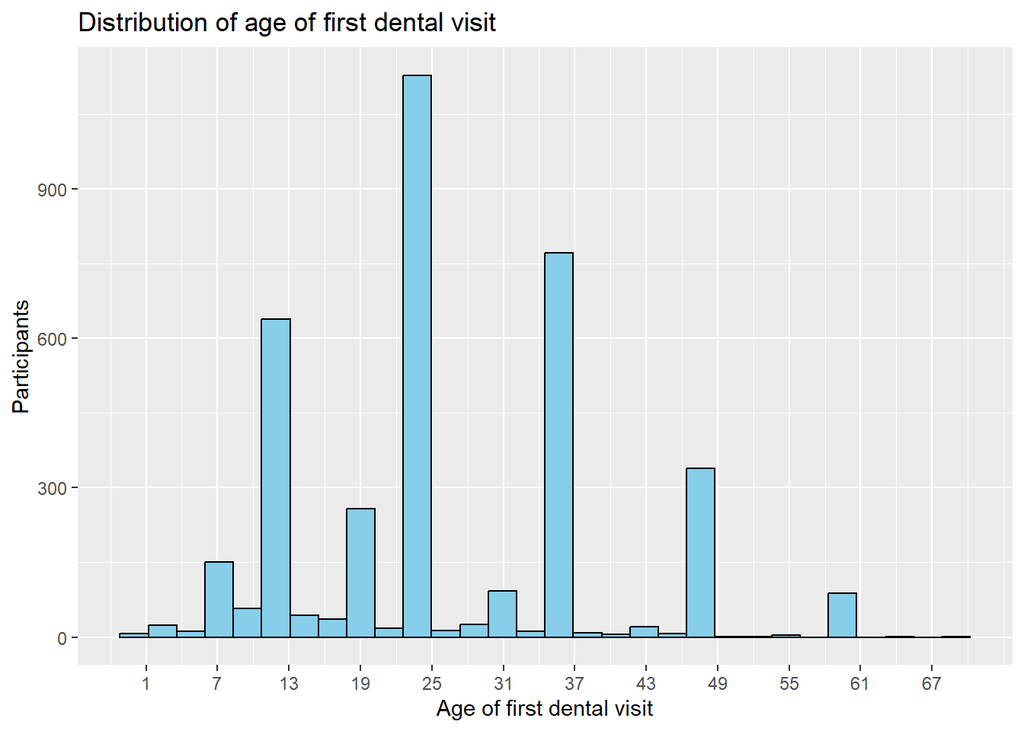

```r
#only 46 participants have missing values for M3_205

#multiply values in the filtered rows by 12 and categorize
ensab <- ensab %>%
  mutate(agefdv = if_else(M3_206B == 2, M3_206A * 12, M3_206A))

ggplot(ensab, aes(x = agefdv)) +
  geom_histogram(fill = "skyblue", color = "black") +
  scale_x_continuous(breaks = seq(min(ensab$agefdv, na.rm = TRUE), max(ensab$agefdv, na.rm = TRUE), by = 6)) +
  labs(x = "Age of first dental visit", y = "Participants", title = "Distribution of age of first dental visit")
```

```r
# can do bins 0-6, 7-12, 13-24, 25-36, 37-48, 49-72, or just divide into 3.

ensab <- ensab %>%
  mutate(agefdv = case_when(
    M3_205 == 3 ~ NA_real_,
    M3_205 == 2 ~ 0,
    agefdv <= 12 ~ 1,
    agefdv > 12 ~ 2,
    TRUE ~ agefdv)) %>%
  mutate(agefdv = factor(agefdv,
                         levels = c(0, 1, 2),
                         labels = c("Never", "0-12", "13+")))

summary(ensab$agefdv)
```

```
## Never  0-12   13+  NA's
##  2575   874  2887    46
```

```r
ensab <- ensab %>%
  dplyr::select(-M3_206B, -M3_206A)
```

Proportions

```r
survensab <- svydesign(
  ids = ~census_mpio,
  data = ensab,
  strata = ~Subreg,
  weights = ~Fex_fin,
  nest = TRUE
)

agefdv_total <- prop.table(svytable(~factor(agefdv, exclude = NULL), design = survensab))
agefdv_total <- round(agefdv_total * 100, 2)
agefdv_total
```

```
## factor(agefdv, exclude = NULL)
## Never  0-12   13+  <NA>
## 42.15 13.05 44.17  0.63
```

```r
#by outcome (cariesexp)

agefdv_caries <- prop.table(svytable(~factor(agefdv, exclude = NULL), design = subset(survensab, cariesexp == "Caries")))
agefdv_caries <- round(agefdv_caries * 100, 2)
agefdv_caries
```

```
## factor(agefdv, exclude = NULL)
## Never  0-12   13+  <NA>
## 30.58 13.07 55.76  0.59
```

```r
agefdv_nocaries <- prop.table(svytable(~factor(agefdv, exclude = NULL), design = subset(survensab, cariesexp == "No caries")))
agefdv_nocaries <- round(agefdv_nocaries * 100, 2)
agefdv_nocaries
```

```
## factor(agefdv, exclude = NULL)
## Never  0-12   13+  <NA>
## 65.34 13.03 20.92  0.71
```

### Reason for last consultation (reason), will not be included for now

M3_209: 1: por una urgencia 2: para un tratamiento 3: por revision/prevencion 4: certificado odontologico

M207 Is important: when was the last appointment of the child with the dentist? 1: less than a year ago 2: between 1-2 years 3: more than 3 years 4: does not remember (NA)

### Age of start of dental hygiene = agehyg

M3_213: units are months, continuous 91: doesn’t know 92: has never gotten dental hygiene done

```r
ensab %>%
  filter(M3_213 == 91 | M3_213 == 92) %>%
  count()
```

```
## # A tibble: 1 × 1
##       n
##   <int>
## 1   382
```

```r
#385

ensab %>%
  filter(M3_213 == 91) %>%
  count()
```

```
## # A tibble: 1 × 1
##       n
##   <int>
## 1   153
```

```r
#NA

ensab %>%
  group_by(age) %>%
  filter(M3_213 == 92) %>%
  count()
```

```
## # A tibble: 3 × 2
## # Groups:   age [3]
##   age       n
##   <fct> <int>
## 1 1       223
## 2 3         4
## 3 5         2
```

```r
#226 children at 1 years old have never gotten dental hygiene done, 4 at age 3 and 2 at age 5

glimpse(ensab$M3_213)
```

```
##  num [1:6382] 3 6 7 3 3 3 3 3 12 30 ...
```

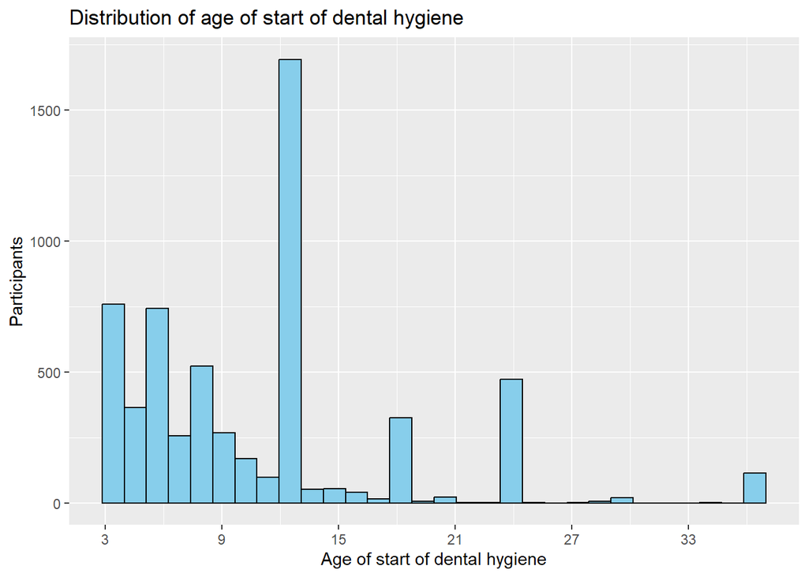

```r
#create distribution
ensab %>%
  filter(!(M3_213 %in% c(91, 92))) %>%
  ggplot(aes(x = M3_213)) +
  geom_histogram(fill = "skyblue", color = "black") +
  scale_x_continuous(breaks = seq(min(ensab$M3_213, na.rm = TRUE), max(ensab$M3_213, na.rm = TRUE), by = 6)) +
  labs(x = "Age of start of dental hygiene", y = "Participants", title = "Distribution of age of start of dental hygiene")
```

```r
#max value of M3_213 without 91 or 92 using summary only for M3_213

ensab %>%
  filter(!(M3_213 %in% c(91, 92))) %>%
  summary()
```

```
##   census_mpio        MPIO               DPTO           age
##  Min.   : 5001   Length:6000        Length:6000        1:1801
##  1st Qu.:11001   Class :character   Class :character   3:2013
##  Median :25658   Mode  :character   Mode  :character   5:2186
##  Mean   :40574
##  3rd Qu.:76001
##  Max.   :99001
##
##    M3_113D            M3_113E            M3_113F              M3_119
##  Length:6000        Length:6000        Length:6000        Min.   :1.000
##  Class :character   Class :character   Class :character   1st Qu.:2.000
##  Mode  :character   Mode  :character   Mode  :character   Median :2.000
##                                                           Mean   :2.569
##                                                           3rd Qu.:3.000
##                                                           Max.   :8.000
##
##      M3_201         M3_202          M3_205          M3_213
##  Min.   :1.00   Min.   :1.000   Min.   :1.000   Min.   : 3.00
##  1st Qu.:3.00   1st Qu.:1.000   1st Qu.:1.000   1st Qu.: 6.00
##  Median :3.00   Median :1.000   Median :1.000   Median :10.00
##  Mean   :2.71   Mean   :1.319   Mean   :1.394   Mean   :10.84
##  3rd Qu.:3.00   3rd Qu.:1.000   3rd Qu.:2.000   3rd Qu.:12.00
##  Max.   :4.00   Max.   :6.000   Max.   :3.000   Max.   :36.00
##
##     M3_226              M3_224         M3_225         M3_227
##  Length:6000        Min.   : 0.0   Min.   :1.000   Length:6000
##  Class :character   1st Qu.: 4.0   1st Qu.:1.000   Class :character
##  Mode  :character   Median : 6.0   Median :2.000   Mode  :character
##                     Mean   :11.3   Mean   :1.707
##                     3rd Qu.: 7.0   3rd Qu.:2.000
##                     Max.   :92.0   Max.   :2.000
##
##    M3_227A            M3_227B            M3_227C            M3_227D
##  Length:6000        Length:6000        Length:6000        Length:6000
##  Class :character   Class :character   Class :character   Class :character
##  Mode  :character   Mode  :character   Mode  :character   Mode  :character
##
##
##
##
```

[output cut: 89 more lines]

```
##  Uninsured   : 394   Atlantic            :1015   Urban:4928
##  Contributory:2116   Eastern             :1009   Rural:1072
##  Subsidized  :3229   Central             : 914
##  Other       : 261   Pacific             : 932
##                      Bogota              :1101
##                      Orinoquia - Amazonia:1029
##
##   region_prop         agefdv
##  Min.   :0.001612   Never:2290
##  1st Qu.:0.001696   0-12 : 846
##  Median :0.002478   13+  :2828
##  Mean   :0.003981   NA's :  36
##  3rd Qu.:0.003269
##  Max.   :0.012085
##
```

```r
#Categorize into: never, 0-6 months, more than 6 months

ensab <- ensab %>%
  mutate(agehyg = case_when(
    M3_213 == 91 ~ NA_real_,
    M3_213 <= 6 ~ 1,
    M3_213 > 6 & M3_213 <= 12 ~ 2,
    M3_213 > 12 & M3_213 <= 36 ~ 3,
    M3_213 == 92 ~ 4
  )) %>%
  mutate(agehyg = factor(agehyg,
                        levels = c(1, 2, 3, 4),
                        labels = c( "0-6 months", "6-12 months", "+12 months", "Never")))

#Proportions

ensab %>%
  group_by(age, agehyg) %>%
  count() %>%
  group_by(age) %>%
  mutate(prop = n / sum(n) * 100)
```

```
## # A tibble: 15 × 4
## # Groups:   age [3]
##    age   agehyg          n    prop
##    <fct> <fct>       <int>   <dbl>
##  1 1     0-6 months    682 32.9
##  2 1     6-12 months   960 46.4
##  3 1     +12 months    159  7.68
##  4 1     Never         223 10.8
##  5 1     <NA>           47  2.27
##  6 3     0-6 months    599 29.1
##  7 3     6-12 months   939 45.6
##  8 3     +12 months    475 23.1
##  9 3     Never           4  0.194
## 10 3     <NA>           40  1.94
## 11 5     0-6 months    583 25.9
## 12 5     6-12 months  1066 47.3
## 13 5     +12 months    537 23.8
## 14 5     Never           2  0.0887
## 15 5     <NA>           66  2.93
```

Proportions with survey design

```r
survensab <- svydesign(
  ids = ~census_mpio,
  data = ensab,
  strata = ~Subreg,
  weights = ~Fex_fin,
  nest = TRUE
)

agehyg_total <- prop.table(svytable(~factor(agehyg, exclude = NULL), design = survensab))
agehyg_total <- round(agehyg_total * 100, 2)
agehyg_total
```

```
## factor(agehyg, exclude = NULL)
##  0-6 months 6-12 months  +12 months       Never        <NA>
##       31.68       43.98       17.68        4.00        2.66
```

```r
#by outcome (cariesexp)

agehyg_caries <- prop.table(svytable(~factor(agehyg, exclude = NULL), design = subset(survensab, cariesexp == "Caries")))
agehyg_caries <- round(agehyg_caries * 100, 2)
agehyg_caries
```

```
## factor(agehyg, exclude = NULL)
##  0-6 months 6-12 months  +12 months       Never        <NA>
##       29.46       44.30       21.74        1.92        2.58
```

```r
agehyg_nocaries <- prop.table(svytable(~factor(agehyg, exclude = NULL), design = subset(survensab, cariesexp == "No caries")))
agehyg_nocaries <- round(agehyg_nocaries * 100, 2)
agehyg_nocaries
```

```
## factor(agehyg, exclude = NULL)
##  0-6 months 6-12 months  +12 months       Never        <NA>
##       36.12       43.34        9.55        8.18        2.81
```

## Without survey design

Stratified by outcome

```r
library(table1)
library(expss) #for apply_labels
```

```r
ensab <- apply_labels(ensab,
                      age = "Age in years, n (%)",
                      sex = "Sex, n (%)",
                      ses = "Socioeconomic status, n (%)",
                      income = "Income of provider, n (%)",
                      region = "Region, n (%)",
                      location = "Area of residence, n (%)",
                      insurance = "Type of insurance affiliation, n (%)",
                      agehyg = "Age of oral hygiene start,n (%)",
                      agefdv = "Age of first dental visit, n (%)"
                      )

table1ECC <- table1(~ age + sex + ses + income + region + location + insurance + agehyg + agefdv | cariesexp , data = ensab,
                    caption = "Table 1. Sociodemographic and Oral Health Characteristics of Children 1, 3, and 5 years old of ENSAB IV, Colombia, 2014",
                    footnote = "Caries experience: presence of tooth decay (cavitaded or non-cavitaded), missing teeth due to caries and/or filled tooth surfaces (dmft >1) in the primary teeth of children younger than 6 years old. No caries experience is defined as dmft = 0. NMW: National minimum wage per month. Data source: ENSAB IV, 2014.")

table1ECC
```

Table 1. Sociodemographic and Oral Health Characteristics of Children 1, 3, and 5 years old of ENSAB IV, Colombia, 2014

|  | No caries (N=2058) | Caries (N=4324) | Overall (N=6382) |
| --- | --- | --- | --- |
| Age in years, n (%) |  |  |  |
| 1 | 1408 (68.4%) | 663 (15.3%) | 2071 (32.5%) |
| 3 | 348 (16.9%) | 1709 (39.5%) | 2057 (32.2%) |
| 5 | 302 (14.7%) | 1952 (45.1%) | 2254 (35.3%) |
| Sex, n (%) |  |  |  |
| Masculine | 1013 (49.2%) | 2296 (53.1%) | 3309 (51.8%) |
| Feminine | 1045 (50.8%) | 2028 (46.9%) | 3073 (48.2%) |
| Socioeconomic status, n (%) |  |  |  |
| Low low | 814 (39.6%) | 1808 (41.8%) | 2622 (41.1%) |
| Low | 835 (40.6%) | 1832 (42.4%) | 2667 (41.8%) |
| Middle low | 368 (17.9%) | 631 (14.6%) | 999 (15.7%) |
| Middle to high | 41 (2.0%) | 53 (1.2%) | 94 (1.5%) |
| Income of provider, n (%) |  |  |  |
| Unemployed | 23 (1.1%) | 62 (1.4%) | 85 (1.3%) |
| Less than half NMW | 298 (14.5%) | 701 (16.2%) | 999 (15.7%) |
| Half - 1 NMW | 795 (38.6%) | 1705 (39.4%) | 2500 (39.2%) |
| 1-2 NMW | 675 (32.8%) | 1393 (32.2%) | 2068 (32.4%) |
| 2-3 NMW | 138 (6.7%) | 264 (6.1%) | 402 (6.3%) |
| 3-4 NMW | 40 (1.9%) | 72 (1.7%) | 112 (1.8%) |
| More than 4 NMW | 50 (2.4%) | 72 (1.7%) | 122 (1.9%) |
| Missing | 39 (1.9%) | 55 (1.3%) | 94 (1.5%) |
| Region, n (%) |  |  |  |
| Atlantic | 334 (16.2%) | 736 (17.0%) | 1070 (16.8%) |
| Eastern | 327 (15.9%) | 757 (17.5%) | 1084 (17.0%) |
| Central | 294 (14.3%) | 674 (15.6%) | 968 (15.2%) |
| Pacific | 441 (21.4%) | 552 (12.8%) | 993 (15.6%) |
| Bogota | 321 (15.6%) | 848 (19.6%) | 1169 (18.3%) |
| Orinoquia - Amazonia | 341 (16.6%) | 757 (17.5%) | 1098 (17.2%) |
| Area of residence, n (%) |  |  |  |
| Urban | 1746 (84.8%) | 3470 (80.2%) | 5216 (81.7%) |
| Rural | 312 (15.2%) | 854 (19.8%) | 1166 (18.3%) |
| Type of insurance affiliation, n (%) |  |  |  |
| Uninsured | 143 (6.9%) | 293 (6.8%) | 436 (6.8%) |
| Contributory | 765 (37.2%) | 1459 (33.7%) | 2224 (34.8%) |
| Subsidized | 1062 (51.6%) | 2390 (55.3%) | 3452 (54.1%) |
| Other | 88 (4.3%) | 182 (4.2%) | 270 (4.2%) |
| Age of oral hygiene start,n (%) |  |  |  |
| 0-6 months | 681 (33.1%) | 1183 (27.4%) | 1864 (29.2%) |
| 6-12 months | 940 (45.7%) | 2025 (46.8%) | 2965 (46.5%) |
| +12 months | 223 (10.8%) | 948 (21.9%) | 1171 (18.3%) |
| Never | 160 (7.8%) | 69 (1.6%) | 229 (3.6%) |
| Missing | 54 (2.6%) | 99 (2.3%) | 153 (2.4%) |
| Age of first dental visit, n (%) |  |  |  |
| Never | 1312 (63.8%) | 1263 (29.2%) | 2575 (40.3%) |
| 0-12 | 258 (12.5%) | 616 (14.2%) | 874 (13.7%) |
| 13+ | 471 (22.9%) | 2416 (55.9%) | 2887 (45.2%) |
| Missing | 17 (0.8%) | 29 (0.7%) | 46 (0.7%) |

Caries experience: presence of tooth decay (cavitaded or non-cavitaded), missing teeth due to caries and/or filled tooth surfaces (dmft >1) in the primary teeth of children younger than 6 years old. No caries experience is defined as dmft = 0. NMW: National minimum wage per month. Data source: ENSAB IV, 2014.

# Table 2: Caries experience and caries severity

## Taking into account survey design

```r
prop.table(svytable(~cariesexp, design = survensab))
```

```
## cariesexp
## No caries    Caries
## 0.3328136 0.6671864
```

```r
survensab_rep <- as.svrepdesign(
    survensab,
    type = "bootstrap",
    replicates = 500
  )

survensab_rep
```

```
## Call: as.svrepdesign.default(survensab, type = "bootstrap", replicates = 500)
## Survey bootstrap with 500 replicates.
```

```r
#cariesexp proportion with bootstrapping standard error (survensab_rep)

prop.table(svymean(~cariesexp, design = survensab_rep))
```

```
##                       mean     SE
## cariesexpNo caries 0.33281 0.0146
## cariesexpCaries    0.66719 0.0146
```

```r
confint(svymean(~cariesexp, design = survensab_rep))
```

```
##                        2.5 %    97.5 %
## cariesexpNo caries 0.3041732 0.3614539
## cariesexpCaries    0.6385461 0.6958268
```

```r
#as.svrepdesign

(sqrt(0.6775306)*0.3224694)/6382
```

```
## [1] 4.159069e-05
```

```r
#accounting for survey design

#svymean(~cariesexp, design = survensab)
#Error in onestrat(`attr<-`(x[index, , drop = FALSE], "recentering", recentering),  :
#  Stratum (7) has only one PSU at stage 1

if(!require("interpretCI")) install.packages("interpretCI")
library(interpretCI)
prop.table(table(ensab$cariesexp))
```

```
##
## No caries    Caries
## 0.3224694 0.6775306
```

```r
propCI(n = 6382, x = 0.6775306, alpha = 0.05)
```

```
## $data
## # A tibble: 1 × 1
##   value
##   <dbl>
## 1 0.678
##
## $result
##   alpha n df  p P se critical ME lower upper               CI  z pvalue
## 1  0.05 1  0 NA 0 NA 1.959964 NA    NA    NA NA [95CI NA; NA] NA     NA
##   alternative
## 1   two.sided
##
## $call
## propCI(x = 0.6775306, n = 6382, alpha = 0.05)
##
## attr(,"measure")
## [1] "prop"
```

```r
prop.table(svytable(~cariesexp, design = survensab))
```

```
## cariesexp
## No caries    Caries
## 0.3328136 0.6671864
```

```r
svymean(~cariesexp, design = survensab_rep)
```

```
##                       mean     SE
## cariesexpNo caries 0.33281 0.0146
## cariesexpCaries    0.66719 0.0146
```

```r
prop.table(table(ensab$cariesexp))
```

```
##
## No caries    Caries
## 0.3224694 0.6775306
```

## Without survey design

### Caries experience

Total

```r
# Create a binary vector
x_vector <- as.numeric(ensab$cariesexp == "Caries")
# Total sample size
n_total <- length(x_vector)

# Calculate proportion confidence interval using propCI
cariesexp_prop <- propCI(x = x_vector, n = n_total, alpha = 0.05)

# Multiply the CI values by 100 to express them as percentages and round to two decimals

cariesexp_pt <- data.frame(
  p = round(cariesexp_prop$result$p * 100, 2),
  lower = round(cariesexp_prop$result$lower * 100, 2),
  upper = round(cariesexp_prop$result$upper * 100, 2),
  ME = round(cariesexp_prop$result$ME * 100, 2)
)

print(cariesexp_pt)
```

```
##       p lower upper   ME
## 1 67.75 66.61  68.9 1.15
```

Per age

```r
# 1 years old age ==1

x_vector <- as.numeric(ensab$cariesexp[ensab$age == "1"] == "Caries")
n_total <- length(x_vector)
# Calculate proportion confidence interval using propCI
cariesexp_prop <- propCI(x = x_vector, n = n_total, alpha = 0.05)
# Multiply the CI values by 100 to express them as percentages and round to two decimals
cariesexp_pt <- data.frame(
  p = round(cariesexp_prop$result$p * 100, 2),
  lower = round(cariesexp_prop$result$lower * 100, 2),
  upper = round(cariesexp_prop$result$upper * 100, 2),
  ME = round(cariesexp_prop$result$ME * 100, 2)
)
cariesexp_pt
```

```
##       p lower upper   ME
## 1 32.01    30 34.02 2.01
```

```r
# 3 years old age == 3

x_vector <- as.numeric(ensab$cariesexp[ensab$age == "3"] == "Caries")
n_total <- length(x_vector)
# Calculate proportion confidence interval using propCI
cariesexp_prop <- propCI(x = x_vector, n = n_total, alpha = 0.05)
# Multiply the CI values by 100 to express them as percentages and round to two decimals
cariesexp_pt <- data.frame(
  p = round(cariesexp_prop$result$p * 100, 2),
  lower = round(cariesexp_prop$result$lower * 100, 2),
  upper = round(cariesexp_prop$result$upper * 100, 2),
  ME = round(cariesexp_prop$result$ME * 100, 2)
)
cariesexp_pt
```

```
##       p lower upper   ME
## 1 83.08 81.46  84.7 1.62
```

```r
# 5 years old age == 5

x_vector <- as.numeric(ensab$cariesexp[ensab$age == "5"] == "Caries")
n_total <- length(x_vector)
# Calculate proportion confidence interval using propCI
cariesexp_prop <- propCI(x = x_vector, n = n_total, alpha = 0.05)
# Multiply the CI values by 100 to express them as percentages and round to two decimals
cariesexp_pt <- data.frame(
  p = round(cariesexp_prop$result$p * 100, 2),
  lower = round(cariesexp_prop$result$lower * 100, 2),
  upper = round(cariesexp_prop$result$upper * 100, 2),
  ME = round(cariesexp_prop$result$ME * 100, 2)
)
cariesexp_pt
```

```
##      p lower upper   ME
## 1 86.6  85.2 88.01 1.41
```

### Caries severity

Total

```r
glimpse(ensab$cariessev3)
```

```
##  Ord.factor w/ 3 levels "No ECC"<"Non-severe ECC"<..: 2 1 2 3 2 1 2 2 1 3 ...
```

```r
summary(ensab$cariessev3)
```

```
##         No ECC Non-severe ECC     Severe ECC
##           2058           1929           2395
```

```r
summary(ensab$cariessev)
```

```
## No severe ECC    Severe ECC
##          3987          2395
```

```r
x_vector <- as.numeric(ensab$cariessev3 == "Severe ECC")
# Total sample size
n_total <- length(x_vector)
# Calculate proportion confidence interval using propCI
cariessev3_prop <- propCI(x = x_vector, n = n_total, alpha = 0.05)
# Multiply the CI values by 100 to express them as percentages and round to two decimals
cariessev3_pt <- data.frame(
  p = round(cariessev3_prop$result$p * 100, 2),
  lower = round(cariessev3_prop$result$lower * 100, 2),
  upper = round(cariessev3_prop$result$upper * 100, 2),
  ME = round(cariessev3_prop$result$ME * 100, 2)
)
cariessev3_pt
```

```
##       p lower upper   ME
## 1 37.53 36.34 38.72 1.19
```

By age

```r
# 1 years old age ==1

x_vector <- as.numeric(ensab$cariessev3[ensab$age == "1"] == "Severe ECC")
n_total <- length(x_vector)
# Calculate proportion confidence interval using propCI
cariessev3_prop <- propCI(x = x_vector, n = n_total, alpha = 0.05)
# Multiply the CI values by 100 to express them as percentages and round to two decimals
cariessev3_pt <- data.frame(
  p = round(cariessev3_prop$result$p * 100, 2),
  lower = round(cariessev3_prop$result$lower * 100, 2),
  upper = round(cariessev3_prop$result$upper * 100, 2),
  ME = round(cariessev3_prop$result$ME * 100, 2)
)
cariessev3_pt
```

```
##       p lower upper   ME
## 1 22.94 21.13 24.75 1.81
```

```r
# 3 years old age == 3

x_vector <- as.numeric(ensab$cariessev3[ensab$age == "3"] == "Severe ECC")
n_total <- length(x_vector)
# Calculate proportion confidence interval using propCI
cariessev3_prop <- propCI(x = x_vector, n = n_total, alpha = 0.05)
# Multiply the CI values by 100 to express them as percentages and round to two decimals
cariessev3_pt <- data.frame(
  p = round(cariessev3_prop$result$p * 100, 2),
  lower = round(cariessev3_prop$result$lower * 100, 2),
  upper = round(cariessev3_prop$result$upper * 100, 2),
  ME = round(cariessev3_prop$result$ME * 100, 2)
)
cariessev3_pt
```

```
##       p lower upper   ME
## 1 29.02 27.06 30.98 1.96
```

```r
# 5 years old age == 5

x_vector <- as.numeric(ensab$cariessev3[ensab$age == "5"] == "Severe ECC")
n_total <- length(x_vector)
# Calculate proportion confidence interval using propCI
cariessev3_prop <- propCI(x = x_vector, n = n_total, alpha = 0.05)
# Multiply the CI values by 100 to express them as percentages and round to two decimals
cariessev3_pt <- data.frame(
  p = round(cariessev3_prop$result$p * 100, 2),
  lower = round(cariessev3_prop$result$lower * 100, 2),
  upper = round(cariessev3_prop$result$upper * 100, 2),
  ME = round(cariessev3_prop$result$ME * 100, 2)
)
cariessev3_pt
```

```
##      p lower upper   ME
## 1 58.7 56.66 60.73 2.03
```

### Trouble shooting: I am getting higher results than ENSAB and than Guarnizo et al

```r
ensab %>%
  summarize(proportion = sum(dmft > 0, na.rm = TRUE)/n())
```

```
## # A tibble: 1 × 1
##   proportion
##        <dbl>
## 1      0.474
```

```r
#Guarnizo et al are getting 36.90 and I am getting  47.4
# Maybe because I am not accounting for survey design?
```

### Fig 1: experience and severity

caries experience by age

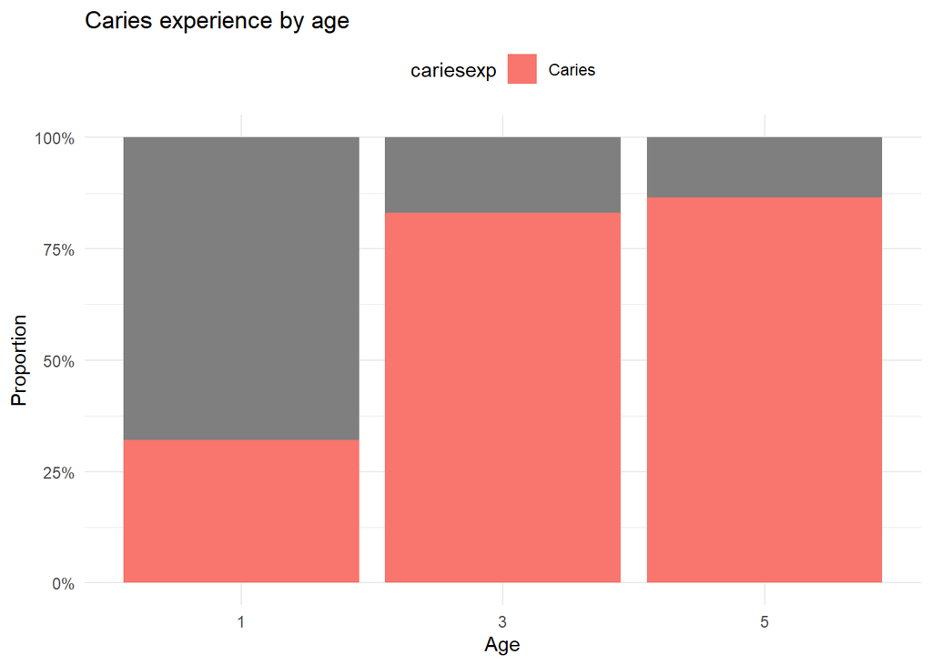

```r
ggplot(ensab, aes(x = age, fill = cariesexp)) +
  geom_bar(position = "fill") +
  scale_y_continuous(labels = scales::percent_format()) +
  labs(x = "Age", y = "Proportion", title = "Caries experience by age") +
  theme_minimal() +
  scale_fill_manual(values = c("Caries" = "#F8766D")) +
  theme(legend.position = "top")
```

Caries severity by age

```r
glimpse(ensab$cariessev3)
```

```
##  Ord.factor w/ 3 levels "No ECC"<"Non-severe ECC"<..: 2 1 2 3 2 1 2 2 1 3 ...
```

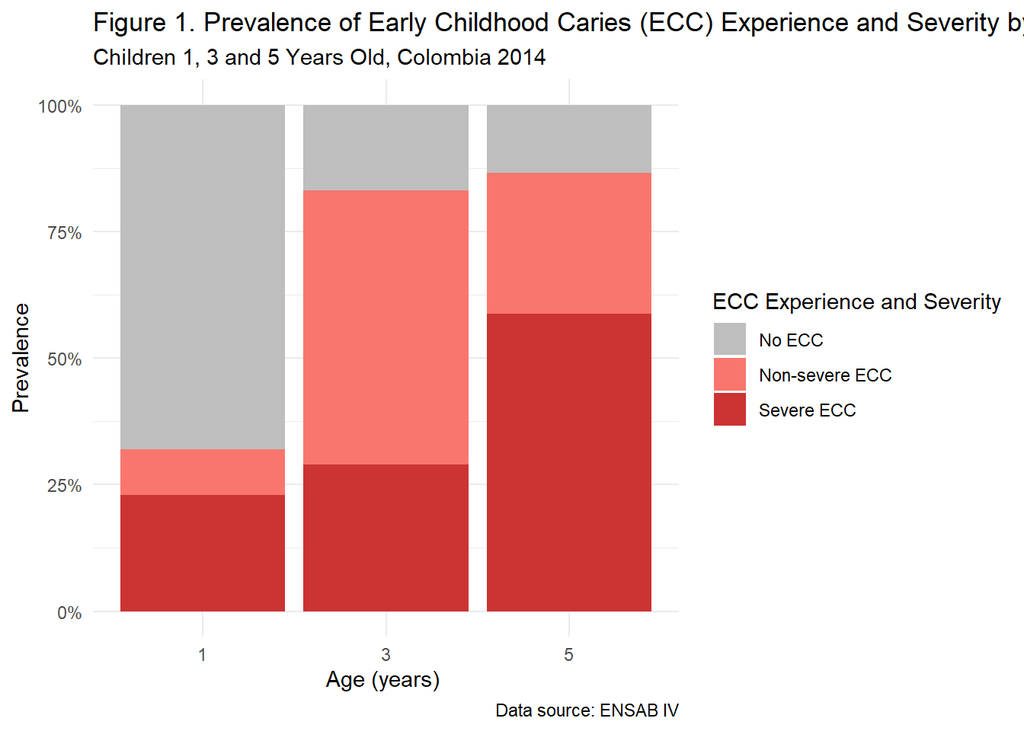

```r
ggplot(ensab, aes(x = age, fill = cariessev3)) +
  geom_bar(position = "fill") +
  scale_y_continuous(labels = scales::percent_format()) +
  labs(x = "Age (years) ", y = "Prevalence",
       title = "Figure 1. Prevalence of Early Childhood Caries (ECC) Experience and Severity by Age",
       subtitle = "Children 1, 3 and 5 Years Old, Colombia 2014",
       caption = "Data source: ENSAB IV") +
  theme_minimal() +
  scale_fill_manual(
    name = "ECC Experience and Severity",
    values = c("Severe ECC" = "#CC3333", "Non-severe ECC" = "#F8766D", "No ECC" = "grey")) +
  theme(legend.position = "right")
```

#Table 3: Weekly consumption of food groups by age

Multi-level logistic regression to account for clustering by subregion and region

## Taking into account survey desing

carbs, veg, fruit, prot, dairy, fats, sugar, soda, juice

### Carbs proportions

```r
carbs_total <- prop.table(svytable(~carbs, design = survensab))
carbs_total <- round(carbs_total * 100, 2)
carbs_total
```

```
## carbs
## Never    1x  2-3x  4-7x   8+x
##  0.92  1.16  7.49 28.01 62.43
```

```r
prop.table(svymean(~carbs, design = survensab_rep))
```

```
##                 mean     SE
## carbsNever 0.0091565 0.0023
## carbs1x    0.0115600 0.0024
## carbs2-3x  0.0748628 0.0071
## carbs4-7x  0.2800780 0.0172
## carbs8+x   0.6243427 0.0201
```

### Vegetables proportions

```r
veg_total <- prop.table(svytable(~veg, design = survensab))
veg_total <- round(veg_total * 100, 2)
veg_total
```

```
## veg
## Never    1x  2-3x  4-7x   8+x
## 16.10  9.25 23.69 29.65 21.32
```

### Fruits proportions

```r
fruit_total <- prop.table(svytable(~fruit, design = survensab))
fruit_total <- round(fruit_total * 100, 2)
fruit_total
```

```
## fruit
## Never    1x  2-3x  4-7x   8+x
## 12.01  6.81 19.96 33.93 27.29
```

### Protein proportions

```r
prot_total <- prop.table(svytable(~prot, design = survensab))
prot_total <- round(prot_total * 100, 2)
prot_total
```

```
## prot
## Never    1x  2-3x  4-7x   8+x
##  0.46  1.37 11.80 30.63 55.73
```

### Dairy proportions

```r
dairy_total <- prop.table(svytable(~dairy, design = survensab))
dairy_total <- round(dairy_total * 100, 2)
dairy_total
```

```
## dairy
## Never    1x  2-3x  4-7x   8+x
##  6.31  3.42 12.13 25.37 52.77
```

### Fats proportions

```r
fats_total <- prop.table(svytable(~fats, design = survensab))
fats_total <- round(fats_total * 100, 2)
fats_total
```

```
## fats
## Never    1x  2-3x  4-7x   8+x
## 15.09 12.62 26.38 27.13 18.78
```

### Sugars

```r
sugar_total <- prop.table(svytable(~sugar, design = survensab))
sugar_total <- round(sugar_total * 100, 2)
sugar_total
```

```
## sugar
## Never    1x  2-3x  4-7x   8+x
## 10.69 10.37 19.54 26.59 32.81
```

### Soda

```r
soda_total <- prop.table(svytable(~soda, design = survensab))
soda_total <- round(soda_total * 100, 2)
soda_total
```

```
## soda
## Never    1x  2-3x  4-7x   8+x
## 44.03 20.56 20.47 10.51  4.43
```

### Juice

```r
juice_total <- prop.table(svytable(~juice, design = survensab))
juice_total <- round(juice_total * 100, 2)
juice_total
```

```
## juice
## Never    1x  2-3x  4-7x   8+x
##  4.18  2.37  9.21 23.11 61.13
```

## No survey design

Carbs

```r
totalcarbs <- ensab %>%
  group_by(carbs) %>%
  summarise(Total = n(), .groups = "drop") %>%
  mutate(Percent = Total / sum(Total)) %>%
  mutate(Total = paste0(round(Total, 3), " (", round(Percent * 100, 2), "%)")) %>%
  select(Freq = carbs, Total)

totalcarbs
```

```
## # A tibble: 5 × 2
##   Freq  Total
##   <fct> <chr>
## 1 Never 61 (0.96%)
## 2 1x    86 (1.35%)
## 3 2-3x  537 (8.41%)
## 4 4-7x  1909 (29.91%)
## 5 8+x   3789 (59.37%)
```

```r
agecarbs <- ensab %>%
  group_by(age, carbs) %>%
  summarise(Total = n()) %>%
  mutate(Percent = Total/sum(Total)) %>%
  mutate(Percent_complete = paste0(round(Total, 3), " (", round(Percent*100, 2), "%)")) %>%
  select(age, Freq = carbs, Percent_complete) %>%
  pivot_wider(names_from = "age", values_from = Percent_complete)
```

```
## argument.
```

```r
agecarbs
```

```
## # A tibble: 5 × 4
##   Freq  `1`           `3`           `5`
##   <fct> <chr>         <chr>         <chr>
## 1 Never 38 (1.83%)    11 (0.53%)    12 (0.53%)
## 2 1x    35 (1.69%)    18 (0.88%)    33 (1.46%)
## 3 2-3x  190 (9.17%)   179 (8.7%)    168 (7.45%)
## 4 4-7x  655 (31.63%)  603 (29.31%)  651 (28.88%)
## 5 8+x   1153 (55.67%) 1246 (60.57%) 1390 (61.67%)
```

```r
t2carbs <- left_join(totalcarbs, agecarbs, by = "Freq") %>%
  mutate(Food = "Carbs") %>%
  select(Food, everything())
t2carbs
```

```
## # A tibble: 5 × 6
##   Food  Freq  Total         `1`           `3`           `5`
##   <chr> <fct> <chr>         <chr>         <chr>         <chr>
## 1 Carbs Never 61 (0.96%)    38 (1.83%)    11 (0.53%)    12 (0.53%)
## 2 Carbs 1x    86 (1.35%)    35 (1.69%)    18 (0.88%)    33 (1.46%)
## 3 Carbs 2-3x  537 (8.41%)   190 (9.17%)   179 (8.7%)    168 (7.45%)
## 4 Carbs 4-7x  1909 (29.91%) 655 (31.63%)  603 (29.31%)  651 (28.88%)
## 5 Carbs 8+x   3789 (59.37%) 1153 (55.67%) 1246 (60.57%) 1390 (61.67%)
```

Veg

```r
totalveg <- ensab %>%
  group_by(veg) %>%
  summarise(Total = n(), .groups = "drop") %>%
  mutate(Percent = Total / sum(Total)) %>%
  mutate(Total = paste0(round(Total, 3), " (", round(Percent * 100, 2), "%)")) %>%
  select(Freq = veg, Total)
totalveg
```

```
## # A tibble: 5 × 2
##   Freq  Total
##   <fct> <chr>
## 1 Never 908 (14.23%)
## 2 1x    557 (8.73%)
## 3 2-3x  1568 (24.57%)
## 4 4-7x  2081 (32.61%)
## 5 8+x   1268 (19.87%)
```

```r
ageveg <- ensab %>%
  group_by(age, veg) %>%
  summarise(Total = n()) %>%
  mutate(Percent = Total/sum(Total)) %>%
  mutate(Percent_complete = paste0(round(Total, 3), " (", round(Percent*100, 2), "%)")) %>%
  select(age, Freq = veg, Percent_complete) %>%
  pivot_wider(names_from = "age", values_from = Percent_complete)
```

```
## argument.
```

```r
ageveg
```

```
## # A tibble: 5 × 4
##   Freq  `1`          `3`          `5`
##   <fct> <chr>        <chr>        <chr>
## 1 Never 289 (13.95%) 274 (13.32%) 345 (15.31%)
## 2 1x    163 (7.87%)  186 (9.04%)  208 (9.23%)
## 3 2-3x  503 (24.29%) 476 (23.14%) 589 (26.13%)
## 4 4-7x  682 (32.93%) 685 (33.3%)  714 (31.68%)
## 5 8+x   434 (20.96%) 436 (21.2%)  398 (17.66%)
```

```r
t2veg <- left_join(totalveg, ageveg, by = "Freq") %>%
  mutate(Food = "Veg") %>%
  select(Food, everything())
```

Fruit

```r
totalfruit <- ensab %>%
  group_by(fruit) %>%
  summarise(Total = n(), .groups = "drop") %>%
  mutate(Percent = Total / sum(Total)) %>%
  mutate(Total = paste0(round(Total, 3), " (", round(Percent * 100, 2), "%)")) %>%
  select(Freq = fruit, Total)

totalfruit
```

```
## # A tibble: 5 × 2
##   Freq  Total
##   <fct> <chr>
## 1 Never 638 (10%)
## 2 1x    421 (6.6%)
## 3 2-3x  1324 (20.75%)
## 4 4-7x  2098 (32.87%)
## 5 8+x   1901 (29.79%)
```

```r
agefruit <- ensab %>%
  group_by(age, fruit) %>%
  summarise(Total = n()) %>%
  mutate(Percent = Total/sum(Total)) %>%
  mutate(Percent_complete = paste0(round(Total, 3), " (", round(Percent*100, 2), "%)")) %>%
  select(age, Freq = fruit, Percent_complete) %>%
  pivot_wider(names_from = "age", values_from = Percent_complete)
```

```
## argument.
```

```r
agefruit
```

```
## # A tibble: 5 × 4
##   Freq  `1`          `3`          `5`
##   <fct> <chr>        <chr>        <chr>
## 1 Never 231 (11.15%) 179 (8.7%)   228 (10.12%)
## 2 1x    155 (7.48%)  116 (5.64%)  150 (6.65%)
## 3 2-3x  427 (20.62%) 399 (19.4%)  498 (22.09%)
## 4 4-7x  673 (32.5%)  697 (33.88%) 728 (32.3%)
## 5 8+x   585 (28.25%) 666 (32.38%) 650 (28.84%)
```

```r
t2fruit <- left_join(totalfruit, agefruit, by = "Freq") %>%
  mutate(Food = "Fruit") %>%
  select(Food, everything())
t2fruit
```

```
## # A tibble: 5 × 6
##   Food  Freq  Total         `1`          `3`          `5`
##   <chr> <fct> <chr>         <chr>        <chr>        <chr>
## 1 Fruit Never 638 (10%)     231 (11.15%) 179 (8.7%)   228 (10.12%)
## 2 Fruit 1x    421 (6.6%)    155 (7.48%)  116 (5.64%)  150 (6.65%)
## 3 Fruit 2-3x  1324 (20.75%) 427 (20.62%) 399 (19.4%)  498 (22.09%)
## 4 Fruit 4-7x  2098 (32.87%) 673 (32.5%)  697 (33.88%) 728 (32.3%)
## 5 Fruit 8+x   1901 (29.79%) 585 (28.25%) 666 (32.38%) 650 (28.84%)
```

Protein

```r
totalprot <- ensab %>%
  group_by(prot) %>%
  summarise(Total = n(), .groups = "drop") %>%
  mutate(Percent = Total / sum(Total)) %>%
  mutate(Total = paste0(round(Total, 3), " (", round(Percent * 100, 2), "%)")) %>%
  select(Freq = prot, Total)

totalprot
```

```
## # A tibble: 5 × 2
##   Freq  Total
##   <fct> <chr>
## 1 Never 37 (0.58%)
## 2 1x    93 (1.46%)
## 3 2-3x  747 (11.7%)
## 4 4-7x  2063 (32.33%)
## 5 8+x   3442 (53.93%)
```

```r
ageprot <- ensab %>%
  group_by(age, prot) %>%
  summarise(Total = n()) %>%
  mutate(Percent = Total/sum(Total)) %>%
  mutate(Percent_complete = paste0(round(Total, 3), " (", round(Percent*100, 2), "%)")) %>%
  select(age, Freq = prot, Percent_complete) %>%
  pivot_wider(names_from = "age", values_from = Percent_complete)
```

```
## argument.
```

```r
ageprot
```

```
## # A tibble: 5 × 4
##   Freq  `1`           `3`          `5`
##   <fct> <chr>         <chr>        <chr>
## 1 Never 25 (1.21%)    6 (0.29%)    6 (0.27%)
## 2 1x    42 (2.03%)    15 (0.73%)   36 (1.6%)
## 3 2-3x  303 (14.63%)  236 (11.47%) 208 (9.23%)
## 4 4-7x  681 (32.88%)  683 (33.2%)  699 (31.01%)
## 5 8+x   1020 (49.25%) 1117 (54.3%) 1305 (57.9%)
```

```r
t2prot <- left_join(totalprot, ageprot, by = "Freq") %>%
  mutate(Food = "Protein") %>%
  select(Food, everything())
t2prot
```

```
## # A tibble: 5 × 6
##   Food    Freq  Total         `1`           `3`          `5`
##   <chr>   <fct> <chr>         <chr>         <chr>        <chr>
## 1 Protein Never 37 (0.58%)    25 (1.21%)    6 (0.29%)    6 (0.27%)
## 2 Protein 1x    93 (1.46%)    42 (2.03%)    15 (0.73%)   36 (1.6%)
## 3 Protein 2-3x  747 (11.7%)   303 (14.63%)  236 (11.47%) 208 (9.23%)
## 4 Protein 4-7x  2063 (32.33%) 681 (32.88%)  683 (33.2%)  699 (31.01%)
## 5 Protein 8+x   3442 (53.93%) 1020 (49.25%) 1117 (54.3%) 1305 (57.9%)
```

Dairy

```r
totaldairy <- ensab %>%
  group_by(dairy) %>%
  summarise(Total = n(), .groups = "drop") %>%
  mutate(Percent = Total / sum(Total)) %>%
  mutate(Total = paste0(round(Total, 3), " (", round(Percent * 100, 2), "%)")) %>%
  select(Freq = dairy, Total)

totaldairy
```

```
## # A tibble: 5 × 2
##   Freq  Total
##   <fct> <chr>
## 1 Never 407 (6.38%)
## 2 1x    229 (3.59%)
## 3 2-3x  770 (12.07%)
## 4 4-7x  1701 (26.65%)
## 5 8+x   3275 (51.32%)
```

```r
agedairy <- ensab %>%
  group_by(age, dairy) %>%
  summarise(Total = n()) %>%
  mutate(Percent = Total/sum(Total)) %>%
  mutate(Percent_complete = paste0(round(Total, 3), " (", round(Percent*100, 2), "%)")) %>%
  select(age, Freq = dairy, Percent_complete) %>%
  pivot_wider(names_from = "age", values_from = Percent_complete)
```

```
## argument.
```

```r
agedairy
```

```
## # A tibble: 5 × 4
##   Freq  `1`           `3`           `5`
##   <fct> <chr>         <chr>         <chr>
## 1 Never 138 (6.66%)   101 (4.91%)   168 (7.45%)
## 2 1x    83 (4.01%)    72 (3.5%)     74 (3.28%)
## 3 2-3x  215 (10.38%)  238 (11.57%)  317 (14.06%)
## 4 4-7x  460 (22.21%)  571 (27.76%)  670 (29.72%)
## 5 8+x   1175 (56.74%) 1075 (52.26%) 1025 (45.47%)
```

```r
t2dairy <- left_join(totaldairy, agedairy, by = "Freq") %>%
  mutate(Food = "Dairy") %>%
  select(Food, everything())
t2dairy
```

```
## # A tibble: 5 × 6
##   Food  Freq  Total         `1`           `3`           `5`
##   <chr> <fct> <chr>         <chr>         <chr>         <chr>
## 1 Dairy Never 407 (6.38%)   138 (6.66%)   101 (4.91%)   168 (7.45%)
## 2 Dairy 1x    229 (3.59%)   83 (4.01%)    72 (3.5%)     74 (3.28%)
## 3 Dairy 2-3x  770 (12.07%)  215 (10.38%)  238 (11.57%)  317 (14.06%)
## 4 Dairy 4-7x  1701 (26.65%) 460 (22.21%)  571 (27.76%)  670 (29.72%)
## 5 Dairy 8+x   3275 (51.32%) 1175 (56.74%) 1075 (52.26%) 1025 (45.47%)
```

Fats

```r
totalfats <- ensab %>%
  group_by(fats) %>%
  summarise(Total = n(), .groups = "drop") %>%
  mutate(Percent = Total / sum(Total)) %>%
  mutate(Total = paste0(round(Total, 3), " (", round(Percent * 100, 2), "%)")) %>%
  select(Freq = fats, Total)

totalfats
```

```
## # A tibble: 5 × 2
##   Freq  Total
##   <fct> <chr>
## 1 Never 944 (14.79%)
## 2 1x    811 (12.71%)
## 3 2-3x  1720 (26.95%)
## 4 4-7x  1689 (26.47%)
## 5 8+x   1218 (19.08%)
```

```r
agefats <- ensab %>%
  group_by(age, fats) %>%
  summarise(Total = n()) %>%
  mutate(Percent = Total/sum(Total)) %>%
  mutate(Percent_complete = paste0(round(Total, 3), " (", round(Percent*100, 2), "%)")) %>%
  select(age, Freq = fats, Percent_complete) %>%
  pivot_wider(names_from = "age", values_from = Percent_complete)
```

```
## argument.
```

```r
agefats
```

```
## # A tibble: 5 × 4
##   Freq  `1`          `3`          `5`
##   <fct> <chr>        <chr>        <chr>
## 1 Never 492 (23.76%) 219 (10.65%) 233 (10.34%)
## 2 1x    277 (13.38%) 250 (12.15%) 284 (12.6%)
## 3 2-3x  517 (24.96%) 591 (28.73%) 612 (27.15%)
## 4 4-7x  485 (23.42%) 584 (28.39%) 620 (27.51%)
## 5 8+x   300 (14.49%) 413 (20.08%) 505 (22.4%)
```

```r
t2fats <- left_join(totalfats, agefats, by = "Freq") %>%
  mutate(Food = "Fats") %>%
  select(Food, everything())
t2fats
```

```
## # A tibble: 5 × 6
##   Food  Freq  Total         `1`          `3`          `5`
##   <chr> <fct> <chr>         <chr>        <chr>        <chr>
## 1 Fats  Never 944 (14.79%)  492 (23.76%) 219 (10.65%) 233 (10.34%)
## 2 Fats  1x    811 (12.71%)  277 (13.38%) 250 (12.15%) 284 (12.6%)
## 3 Fats  2-3x  1720 (26.95%) 517 (24.96%) 591 (28.73%) 612 (27.15%)
## 4 Fats  4-7x  1689 (26.47%) 485 (23.42%) 584 (28.39%) 620 (27.51%)
## 5 Fats  8+x   1218 (19.08%) 300 (14.49%) 413 (20.08%) 505 (22.4%)
```

Sugars

```r
totalsugar <- ensab %>%
  group_by(sugar) %>%
  summarise(Total = n(), .groups = "drop") %>%
  mutate(Percent = Total / sum(Total)) %>%
  mutate(Total = paste0(round(Total, 3), " (", round(Percent * 100, 2), "%)")) %>%
  select(Freq = sugar, Total)
totalsugar
```

```
## # A tibble: 5 × 2
##   Freq  Total
##   <fct> <chr>
## 1 Never 664 (10.4%)
## 2 1x    643 (10.08%)
## 3 2-3x  1317 (20.64%)
## 4 4-7x  1700 (26.64%)
## 5 8+x   2058 (32.25%)
```

```r
agesugar <- ensab %>%
  group_by(age, sugar) %>%
  summarise(Total = n()) %>%
  mutate(Percent = Total/sum(Total)) %>%
  mutate(Percent_complete = paste0(round(Total, 3), " (", round(Percent*100, 2), "%)")) %>%
  select(age, Freq = sugar, Percent_complete) %>%
  pivot_wider(names_from = "age", values_from = Percent_complete)
```

```
## argument.
```

```r
agesugar
```

```
## # A tibble: 5 × 4
##   Freq  `1`          `3`          `5`
##   <fct> <chr>        <chr>        <chr>
## 1 Never 313 (15.11%) 171 (8.31%)  180 (7.99%)
## 2 1x    302 (14.58%) 167 (8.12%)  174 (7.72%)
## 3 2-3x  473 (22.84%) 437 (21.24%) 407 (18.06%)
## 4 4-7x  479 (23.13%) 604 (29.36%) 617 (27.37%)
## 5 8+x   504 (24.34%) 678 (32.96%) 876 (38.86%)
```

```r
t2sugar <- left_join(totalsugar, agesugar, by = "Freq") %>%
  mutate(Food = "Sugars") %>%
  select(Food, everything())
t2sugar
```

```
## # A tibble: 5 × 6
##   Food   Freq  Total         `1`          `3`          `5`
##   <chr>  <fct> <chr>         <chr>        <chr>        <chr>
## 1 Sugars Never 664 (10.4%)   313 (15.11%) 171 (8.31%)  180 (7.99%)
## 2 Sugars 1x    643 (10.08%)  302 (14.58%) 167 (8.12%)  174 (7.72%)
## 3 Sugars 2-3x  1317 (20.64%) 473 (22.84%) 437 (21.24%) 407 (18.06%)
## 4 Sugars 4-7x  1700 (26.64%) 479 (23.13%) 604 (29.36%) 617 (27.37%)
## 5 Sugars 8+x   2058 (32.25%) 504 (24.34%) 678 (32.96%) 876 (38.86%)
```

Soda

```r
totalsoda <- ensab %>%
  group_by(soda) %>%
  summarise(Total = n(), .groups = "drop") %>%
  mutate(Percent = Total / sum(Total)) %>%
  mutate(Total = paste0(round(Total, 3), " (", round(Percent * 100, 2), "%)")) %>%
  select(Freq = soda, Total)

totalsoda
```

```
## # A tibble: 5 × 2
##   Freq  Total
##   <fct> <chr>
## 1 Never 2807 (43.98%)
## 2 1x    1384 (21.69%)
## 3 2-3x  1237 (19.38%)
## 4 4-7x  669 (10.48%)
## 5 8+x   285 (4.47%)
```

```r
agesoda <- ensab %>%
  group_by(age, soda) %>%
  summarise(Total = n()) %>%
  mutate(Percent = Total/sum(Total)) %>%
  mutate(Percent_complete = paste0(round(Total, 3), " (", round(Percent*100, 2), "%)")) %>%
  select(age, Freq = soda, Percent_complete) %>%
  pivot_wider(names_from = "age", values_from = Percent_complete)
```

```
## argument.
```

```r
agesoda
```

```
## # A tibble: 5 × 4
##   Freq  `1`           `3`          `5`
##   <fct> <chr>         <chr>        <chr>
## 1 Never 1080 (52.15%) 835 (40.59%) 892 (39.57%)
## 2 1x    453 (21.87%)  453 (22.02%) 478 (21.21%)
## 3 2-3x  312 (15.07%)  442 (21.49%) 483 (21.43%)
## 4 4-7x  171 (8.26%)   225 (10.94%) 273 (12.11%)
## 5 8+x   55 (2.66%)    102 (4.96%)  128 (5.68%)
```

```r
t2soda <- left_join(totalsoda, agesoda, by = "Freq") %>%
  mutate(Food = "Soda") %>%
  select(Food, everything())
t2soda
```

```
## # A tibble: 5 × 6
##   Food  Freq  Total         `1`           `3`          `5`
##   <chr> <fct> <chr>         <chr>         <chr>        <chr>
## 1 Soda  Never 2807 (43.98%) 1080 (52.15%) 835 (40.59%) 892 (39.57%)
## 2 Soda  1x    1384 (21.69%) 453 (21.87%)  453 (22.02%) 478 (21.21%)
## 3 Soda  2-3x  1237 (19.38%) 312 (15.07%)  442 (21.49%) 483 (21.43%)
## 4 Soda  4-7x  669 (10.48%)  171 (8.26%)   225 (10.94%) 273 (12.11%)
## 5 Soda  8+x   285 (4.47%)   55 (2.66%)    102 (4.96%)  128 (5.68%)
```

Juice

```r
totaljuice <- ensab %>%
  group_by(juice) %>%
  summarise(Total = n(), .groups = "drop") %>%
  mutate(Percent = Total / sum(Total)) %>%
  mutate(Total = paste0(round(Total, 3), " (", round(Percent * 100, 2), "%)")) %>%
  select(Freq = juice, Total)
totaljuice
```

```
## # A tibble: 5 × 2
##   Freq  Total
##   <fct> <chr>
## 1 Never 275 (4.31%)
## 2 1x    169 (2.65%)
## 3 2-3x  595 (9.32%)
## 4 4-7x  1422 (22.28%)
## 5 8+x   3921 (61.44%)
```

```r
agejuice <- ensab %>%
  group_by(age, juice) %>%
  summarise(Total = n()) %>%
  mutate(Percent = Total/sum(Total)) %>%
  mutate(Percent_complete = paste0(round(Total, 3), " (", round(Percent*100, 2), "%)")) %>%
  select(age, Freq = juice, Percent_complete) %>%
  pivot_wider(names_from = "age", values_from = Percent_complete)
```

```
## argument.
```

```r
agejuice
```

```
## # A tibble: 5 × 4
##   Freq  `1`           `3`           `5`
##   <fct> <chr>         <chr>         <chr>
## 1 Never 113 (5.46%)   73 (3.55%)    89 (3.95%)
## 2 1x    68 (3.28%)    41 (1.99%)    60 (2.66%)
## 3 2-3x  208 (10.04%)  193 (9.38%)   194 (8.61%)
## 4 4-7x  493 (23.8%)   458 (22.27%)  471 (20.9%)
## 5 8+x   1189 (57.41%) 1292 (62.81%) 1440 (63.89%)
```

```r
t2juice <- left_join(totaljuice, agejuice, by = "Freq") %>%
  mutate(Food = "Juice") %>%
  select(Food, everything())
t2juice
```

```
## # A tibble: 5 × 6
##   Food  Freq  Total         `1`           `3`           `5`
##   <chr> <fct> <chr>         <chr>         <chr>         <chr>
## 1 Juice Never 275 (4.31%)   113 (5.46%)   73 (3.55%)    89 (3.95%)
## 2 Juice 1x    169 (2.65%)   68 (3.28%)    41 (1.99%)    60 (2.66%)
## 3 Juice 2-3x  595 (9.32%)   208 (10.04%)  193 (9.38%)   194 (8.61%)
## 4 Juice 4-7x  1422 (22.28%) 493 (23.8%)   458 (22.27%)  471 (20.9%)
## 5 Juice 8+x   3921 (61.44%) 1189 (57.41%) 1292 (62.81%) 1440 (63.89%)
```

Append all tables

```r
t2 <- bind_rows(t2carbs, t2veg, t2fruit, t2prot, t2dairy, t2fats, t2sugar, t2soda, t2juice)
t2
```

```
## # A tibble: 45 × 6
##    Food  Freq  Total         `1`           `3`           `5`
##    <chr> <fct> <chr>         <chr>         <chr>         <chr>
##  1 Carbs Never 61 (0.96%)    38 (1.83%)    11 (0.53%)    12 (0.53%)
##  2 Carbs 1x    86 (1.35%)    35 (1.69%)    18 (0.88%)    33 (1.46%)
##  3 Carbs 2-3x  537 (8.41%)   190 (9.17%)   179 (8.7%)    168 (7.45%)
##  4 Carbs 4-7x  1909 (29.91%) 655 (31.63%)  603 (29.31%)  651 (28.88%)
##  5 Carbs 8+x   3789 (59.37%) 1153 (55.67%) 1246 (60.57%) 1390 (61.67%)
##  6 Veg   Never 908 (14.23%)  289 (13.95%)  274 (13.32%)  345 (15.31%)
##  7 Veg   1x    557 (8.73%)   163 (7.87%)   186 (9.04%)   208 (9.23%)
##  8 Veg   2-3x  1568 (24.57%) 503 (24.29%)  476 (23.14%)  589 (26.13%)
##  9 Veg   4-7x  2081 (32.61%) 682 (32.93%)  685 (33.3%)   714 (31.68%)
## 10 Veg   8+x   1268 (19.87%) 434 (20.96%)  436 (21.2%)   398 (17.66%)
## # ℹ 35 more rows
```

```r
#export as csv
write.csv(t2, "t2_foodgroups.csv", row.names = FALSE)
```

### Fig 2: Food groups by age

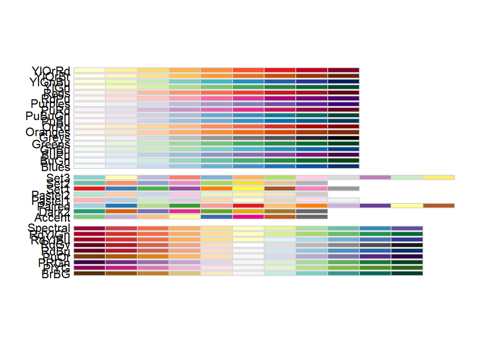

```r
library(RColorBrewer)
RColorBrewer::display.brewer.all()
```

```r
summary(ensab$carbs)
```

```
## Never    1x  2-3x  4-7x   8+x
##    61    86   537  1909  3789
```

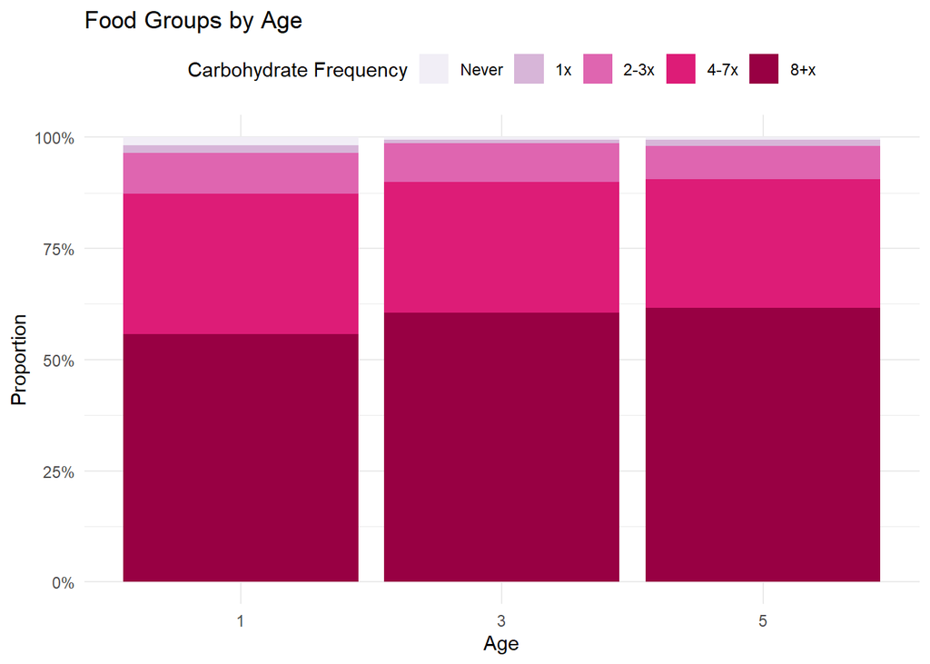

```r
ggplot(ensab, aes(x = age, fill = carbs)) +
  geom_bar(position = "fill") +
  scale_y_continuous(labels = scales::percent_format()) +
  labs(
    x = "Age",
    y = "Proportion",
    title = "Food Groups by Age"
  ) +
  theme_minimal() +
  scale_fill_brewer(palette = "PuRd", name = "Carbohydrate Frequency") +
  theme(legend.position = "top")
```

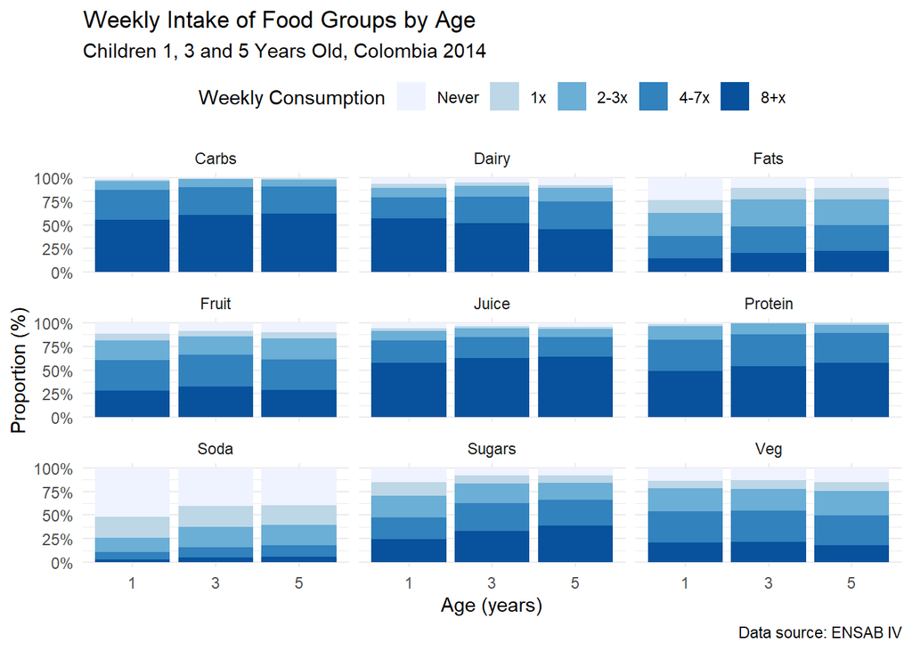

```r
fig_dietage <- t2 %>%
  dplyr::select(-Total) %>%
  pivot_longer(cols = -c(Food, Freq), names_to = "Age", values_to = "Percent") %>%
  mutate(
    Proportion = as.numeric(str_extract(Percent, "(?<=\\().*?(?=%)")),
    Freq = factor(Freq, levels = c("Never", "1x", "2-3x", "4-7x", "8+x"), ordered = TRUE)
  )

ggplot(fig_dietage, aes(x = Age, y = Proportion, fill = Freq)) +
  geom_col(position = "fill") +
  facet_wrap(~ Food, ncol = 3) +
  scale_y_continuous(labels = scales::percent_format()) +
  scale_fill_brewer(palette = "Blues", name = "Weekly Consumption") +
  labs(
    x = "Age (years)",
    y = "Proportion (%)",
    title = "Weekly Intake of Food Groups by Age",
    subtitle = "Children 1, 3 and 5 Years Old, Colombia 2014",
    caption = "Data source: ENSAB IV"
  ) +
  theme_minimal() +
  theme(legend.position = "top")
```

# Table 3b. Weekly consumption of food groups by region

Function

```r
f_foodgroupsdf <- function(foodgroup, strat_variable) {
  foodgroup_name <- rlang::as_string(foodgroup)
  strat_variable_name <- rlang::as_string(strat_variable)

  totaldf <- ensab %>%
    group_by(.data[[foodgroup_name]]) %>%
    summarise(Total = n(), .groups = "drop") %>%
    mutate(Percent = Total / sum(Total)) %>%
    mutate(Total = paste0(round(Total, 3), " (", round(Percent * 100, 2), "%)")) %>%
    select(Freq = .data[[foodgroup_name]], Total)

  stratdf <- ensab %>%
    group_by(.data[[strat_variable_name]], .data[[foodgroup_name]]) %>%
    summarise(Total = n(), .groups = "drop_last") %>%
    mutate(Percent = Total / sum(Total)) %>%
    mutate(Percent_complete = paste0(round(Total, 3), " (", round(Percent * 100, 2), "%)")) %>%
    select(.data[[strat_variable_name]], Freq = .data[[foodgroup_name]], Percent_complete) %>%
    pivot_wider(names_from = .data[[strat_variable_name]], values_from = Percent_complete)

  t_foodgroupsdf <- left_join(totaldf, stratdf, by = "Freq") %>%
    mutate(Food = foodgroup_name) %>%
    select(Food, everything())

  return(t_foodgroupsdf)
}

#lapply with all food groups and region

foodgroups <- rlang::syms(c("carbs", "veg", "fruit", "prot", "dairy", "fats", "sugar", "soda", "juice"))

fgregion <- lapply(foodgroups, function(fg) {
  f_foodgroupsdf(foodgroup = fg, strat_variable = rlang::sym("region"))
})
t_fgregion <- bind_rows(fgregion) #combine
t_fgregion
```

```
## # A tibble: 45 × 9
##    Food  Freq  Total         Atlantic     Eastern      Central    Pacific Bogota
##    <chr> <fct> <chr>         <chr>        <chr>        <chr>      <chr>   <chr>
##  1 carbs Never 61 (0.96%)    2 (0.19%)    13 (1.2%)    6 (0.62%)  17 (1.… 13 (1…
##  2 carbs 1x    86 (1.35%)    3 (0.28%)    15 (1.38%)   13 (1.34%) 22 (2.… 17 (1…
##  3 carbs 2-3x  537 (8.41%)   46 (4.3%)    130 (11.99%) 63 (6.51%) 96 (9.… 107 (…
##  4 carbs 4-7x  1909 (29.91%) 260 (24.3%)  338 (31.18%) 237 (24.4… 334 (3… 305 (…
##  5 carbs 8+x   3789 (59.37%) 759 (70.93%) 588 (54.24%) 649 (67.0… 524 (5… 727 (…
##  6 veg   Never 908 (14.23%)  251 (23.46%) 127 (11.72%) 110 (11.3… 146 (1… 108 (…
##  7 veg   1x    557 (8.73%)   107 (10%)    84 (7.75%)   66 (6.82%) 96 (9.… 83 (7…
##  8 veg   2-3x  1568 (24.57%) 248 (23.18%) 302 (27.86%) 201 (20.7… 221 (2… 265 (…
##  9 veg   4-7x  2081 (32.61%) 302 (28.22%) 396 (36.53%) 300 (30.9… 310 (3… 412 (…
## 10 veg   8+x   1268 (19.87%) 162 (15.14%) 175 (16.14%) 291 (30.0… 220 (2… 301 (…
## # ℹ 35 more rows
## # ℹ 1 more variable: `Orinoquia - Amazonia` <chr>
```

```r
#export as csv
write.csv(t_fgregion, "t3b_foodgroups_region.csv", row.names = FALSE)
```

## Fig 3. Food groups by region

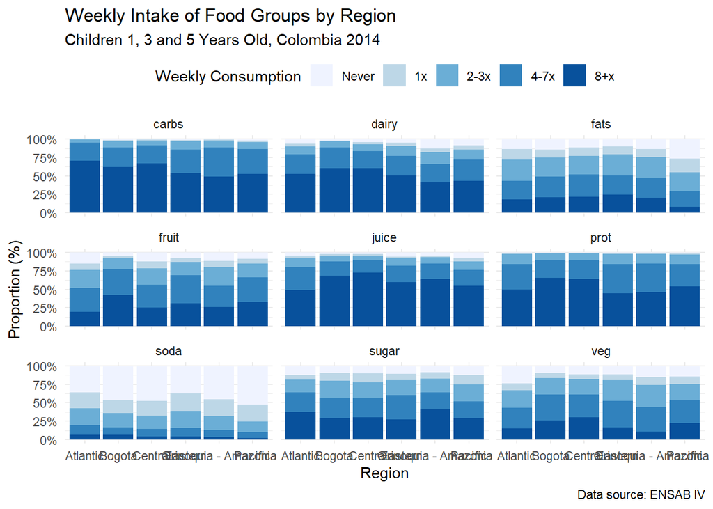

```r
#make the data tidy

fig_dietregion <- t_fgregion %>%
  dplyr::select(-Total) %>%
  pivot_longer(cols = -c(Food, Freq), names_to = "Region", values_to = "Percent") %>%
  mutate(
    Proportion = as.numeric(str_extract(Percent, "(?<=\\().*?(?=%)")),
    Freq = factor(Freq, levels = c("Never", "1x", "2-3x", "4-7x", "8+x"), ordered = TRUE)
  )

#graph for all regions

ggplot(fig_dietregion, aes(x = Region, y = Proportion, fill = Freq)) +
  geom_col(position = "fill") +
  facet_wrap(~ Food, ncol = 3) +
  scale_y_continuous(labels = scales::percent_format()) +
  scale_fill_brewer(palette = "Blues", name = "Weekly Consumption") +
  labs(
    x = "Region",
    y = "Proportion (%)",
    title = "Weekly Intake of Food Groups by Region",
    subtitle = "Children 1, 3 and 5 Years Old, Colombia 2014",
    caption = "Data source: ENSAB IV"
  ) +
  theme_minimal() +
  theme(legend.position = "top")
```

### Carbs

Carbs only with region ordered by highest proportion in category 8+x

```r
# Step 1: Create ordered Region factor based on "8+x"
region_order <- fig_dietregion %>%
  filter(Food == "carbs", Freq == "8+x") %>%
  arrange(desc(Proportion)) %>%
  mutate(Region = fct_inorder(Region)) %>%
  pull(Region)
region_order
```

```
## [1] Atlantic             Central              Bogota
## [4] Eastern              Pacific              Orinoquia - Amazonia
## Levels: Atlantic Central Bogota Eastern Pacific Orinoquia - Amazonia
```

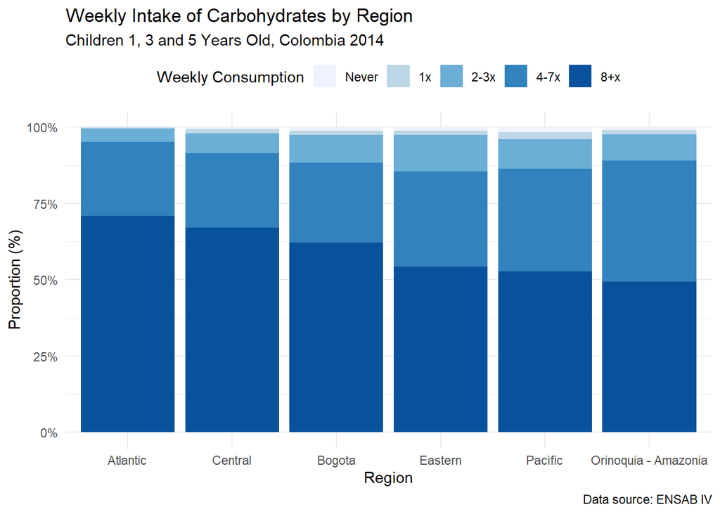

```r
# Step 2: Apply that ordering to the full dataset
fig_dietregion %>%
  filter(Food == "carbs") %>%
  mutate(Region = factor(Region, levels = region_order)) %>%
  ggplot(aes(x = Region, y = Proportion, fill = Freq)) +
  geom_col(position = "fill") +
  scale_y_continuous(labels = scales::percent_format()) +
  scale_fill_brewer(palette = "Blues", name = "Weekly Consumption") +
  labs(
    x = "Region",
    y = "Proportion (%)",
    title = "Weekly Intake of Carbohydrates by Region",
    subtitle = "Children 1, 3 and 5 Years Old, Colombia 2014",
    caption = "Data source: ENSAB IV"
  ) +
  theme_minimal() +
  theme(legend.position = "top")
```

### Veg

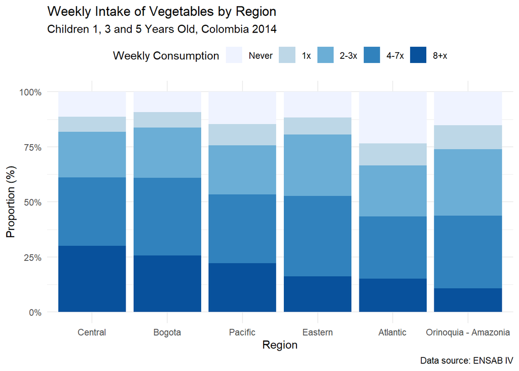

```r
# Region factor
region_order <- fig_dietregion %>%
  filter(Food == "veg", Freq == "8+x") %>%
  arrange(desc(Proportion)) %>%
  mutate(Region = fct_inorder(Region)) %>%
  pull(Region)

#graph

fig_dietregion %>%
  filter(Food == "veg") %>%
  mutate(Region = factor(Region, levels = region_order)) %>%
  ggplot(aes(x = Region, y = Proportion, fill = Freq)) +
  geom_col(position = "fill") +
  scale_y_continuous(labels = scales::percent_format()) +
  scale_fill_brewer(palette = "Blues", name = "Weekly Consumption") +
  labs(
    x = "Region",
    y = "Proportion (%)",
    title = "Weekly Intake of Vegetables by Region",
    subtitle = "Children 1, 3 and 5 Years Old, Colombia 2014",
    caption = "Data source: ENSAB IV"
  ) +
  theme_minimal() +
  theme(legend.position = "top")
```

### Fruit

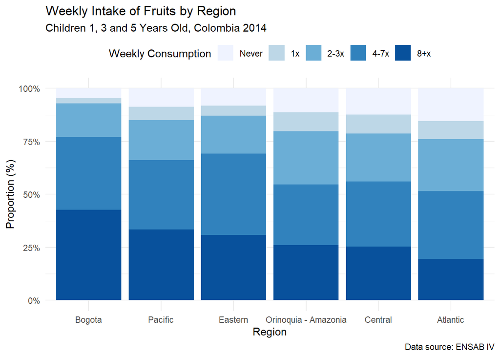

```r
# Region factor
region_order <- fig_dietregion %>%
  filter(Food == "fruit", Freq == "8+x") %>%
  arrange(desc(Proportion)) %>%
  mutate(Region = fct_inorder(Region)) %>%
  pull(Region)

#graph
fig_dietregion %>%
  filter(Food == "fruit") %>%
  mutate(Region = factor(Region, levels = region_order)) %>%
  ggplot(aes(x = Region, y = Proportion, fill = Freq)) +
  geom_col(position = "fill") +
  scale_y_continuous(labels = scales::percent_format()) +
  scale_fill_brewer(palette = "Blues", name = "Weekly Consumption") +
  labs(
    x = "Region",
    y = "Proportion (%)",
    title = "Weekly Intake of Fruits by Region",
    subtitle = "Children 1, 3 and 5 Years Old, Colombia 2014",
    caption = "Data source: ENSAB IV"
  ) +
  theme_minimal() +
  theme(legend.position = "top")
```

### Protein

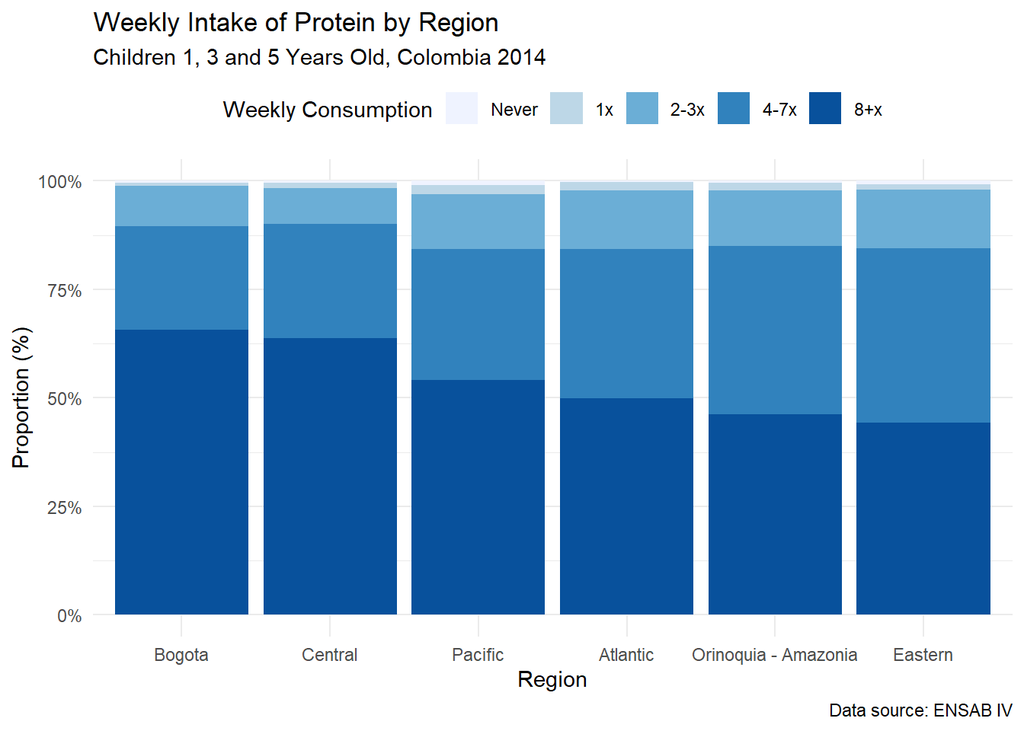

```r
# Region factor
region_order <- fig_dietregion %>%
  filter(Food == "prot", Freq == "8+x") %>%
  arrange(desc(Proportion)) %>%
  mutate(Region = fct_inorder(Region)) %>%
  pull(Region)

#graph
fig_dietregion %>%
  filter(Food == "prot") %>%
  mutate(Region = factor(Region, levels = region_order)) %>%
  ggplot(aes(x = Region, y = Proportion, fill = Freq)) +
  geom_col(position = "fill") +
  scale_y_continuous(labels = scales::percent_format()) +
  scale_fill_brewer(palette = "Blues", name = "Weekly Consumption") +
  labs(
    x = "Region",
    y = "Proportion (%)",
    title = "Weekly Intake of Protein by Region",
    subtitle = "Children 1, 3 and 5 Years Old, Colombia 2014",
    caption = "Data source: ENSAB IV"
  ) +
  theme_minimal() +
  theme(legend.position = "top")
```

### Dairy

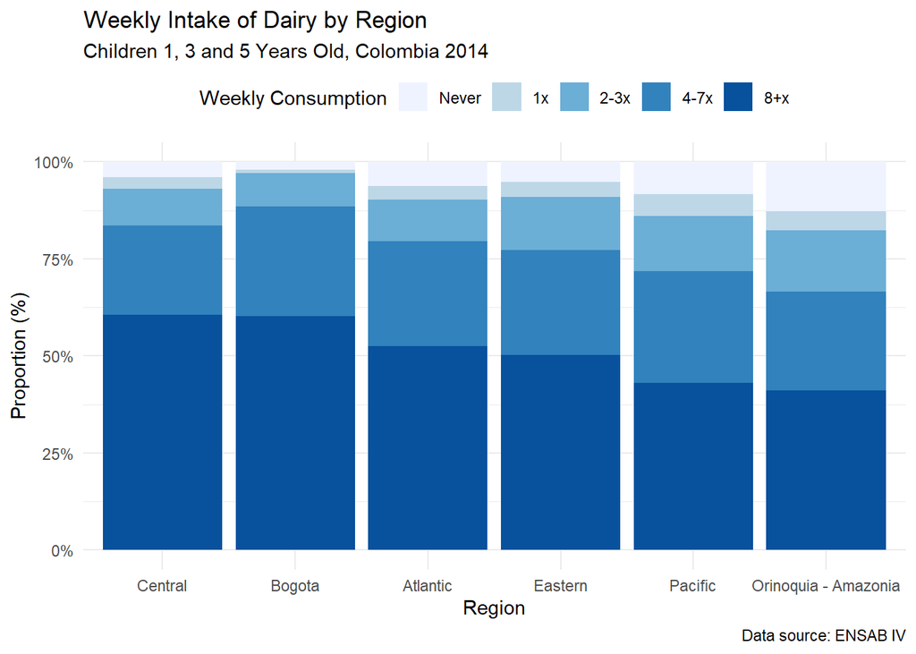

```r
# Region factor
region_order <- fig_dietregion %>%
  filter(Food == "dairy", Freq == "8+x") %>%
  arrange(desc(Proportion)) %>%
  mutate(Region = fct_inorder(Region)) %>%
  pull(Region)

#graph
fig_dietregion %>%
  filter(Food == "dairy") %>%
  mutate(Region = factor(Region, levels = region_order)) %>%
  ggplot(aes(x = Region, y = Proportion, fill = Freq)) +
  geom_col(position = "fill") +
  scale_y_continuous(labels = scales::percent_format()) +
  scale_fill_brewer(palette = "Blues", name = "Weekly Consumption") +
  labs(
    x = "Region",
    y = "Proportion (%)",
    title = "Weekly Intake of Dairy by Region",
    subtitle = "Children 1, 3 and 5 Years Old, Colombia 2014",
    caption = "Data source: ENSAB IV"
  ) +
  theme_minimal() +
  theme(legend.position = "top")
```

### Fats

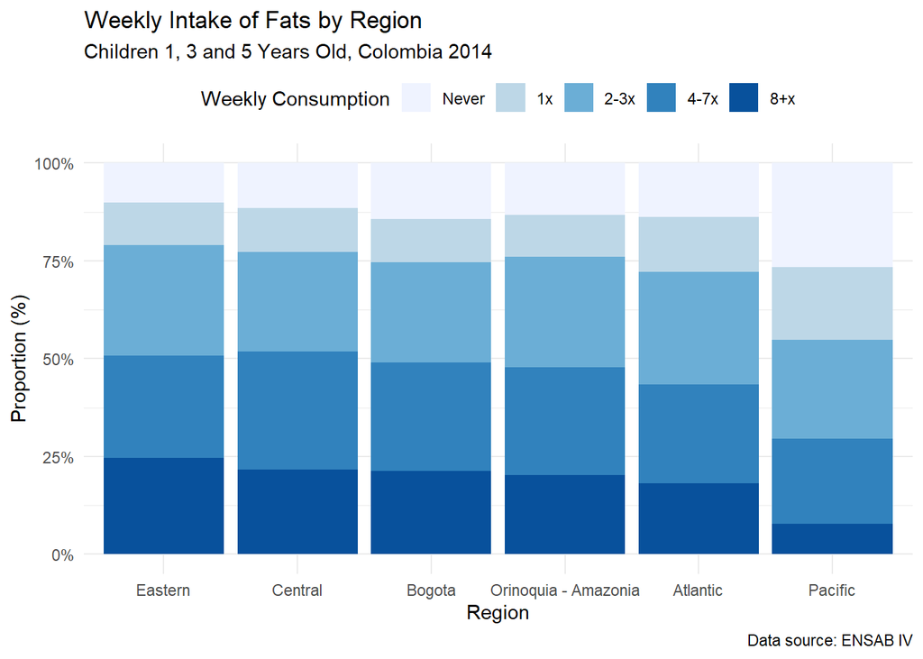

```r
# Region factor
region_order <- fig_dietregion %>%
  filter(Food == "fats", Freq == "8+x") %>%
  arrange(desc(Proportion)) %>%
  mutate(Region = fct_inorder(Region)) %>%
  pull(Region)

#graph
fig_dietregion %>%
  filter(Food == "fats") %>%
  mutate(Region = factor(Region, levels = region_order)) %>%
  ggplot(aes(x = Region, y = Proportion, fill = Freq)) +
  geom_col(position = "fill") +
  scale_y_continuous(labels = scales::percent_format()) +
  scale_fill_brewer(palette = "Blues", name = "Weekly Consumption") +
  labs(
    x = "Region",
    y = "Proportion (%)",
    title = "Weekly Intake of Fats by Region",
    subtitle = "Children 1, 3 and 5 Years Old, Colombia 2014",
    caption = "Data source: ENSAB IV"
  ) +
  theme_minimal() +
  theme(legend.position = "top")
```

### Sugars

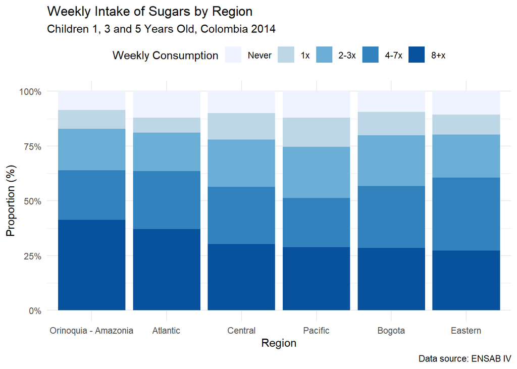

```r
# Region factor
region_order <- fig_dietregion %>%
  filter(Food == "sugar", Freq == "8+x") %>%
  arrange(desc(Proportion)) %>%
  mutate(Region = fct_inorder(Region)) %>%
  pull(Region)
#graph
fig_dietregion %>%
  filter(Food == "sugar") %>%
  mutate(Region = factor(Region, levels = region_order)) %>%
  ggplot(aes(x = Region, y = Proportion, fill = Freq)) +
  geom_col(position = "fill") +
  scale_y_continuous(labels = scales::percent_format()) +
  scale_fill_brewer(palette = "Blues", name = "Weekly Consumption") +
  labs(
    x = "Region",
    y = "Proportion (%)",
    title = "Weekly Intake of Sugars by Region",
    subtitle = "Children 1, 3 and 5 Years Old, Colombia 2014",
    caption = "Data source: ENSAB IV"
  ) +
  theme_minimal() +
  theme(legend.position = "top")
```

### Soda

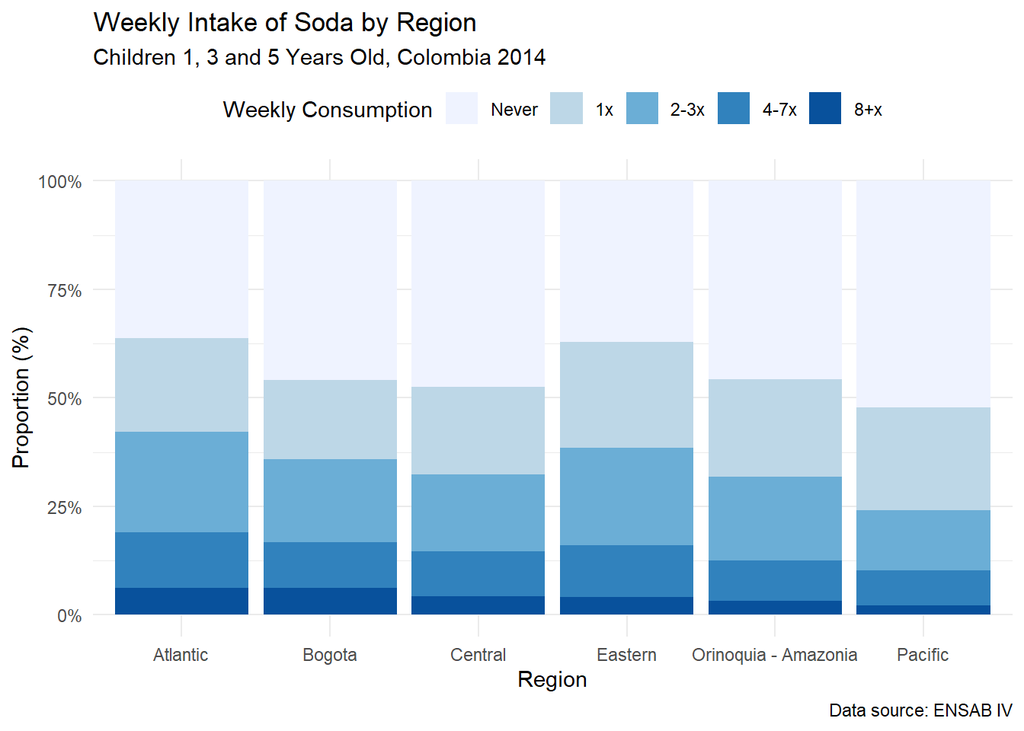

```r
# Region factor
region_order <- fig_dietregion %>%
  filter(Food == "soda", Freq == "8+x") %>%
  arrange(desc(Proportion)) %>%
  mutate(Region = fct_inorder(Region)) %>%
  pull(Region)
#graph
fig_dietregion %>%
  filter(Food == "soda") %>%
  mutate(Region = factor(Region, levels = region_order)) %>%
  ggplot(aes(x = Region, y = Proportion, fill = Freq)) +
  geom_col(position = "fill") +
  scale_y_continuous(labels = scales::percent_format()) +
  scale_fill_brewer(palette = "Blues", name = "Weekly Consumption") +
  labs(
    x = "Region",
    y = "Proportion (%)",
    title = "Weekly Intake of Soda by Region",
    subtitle = "Children 1, 3 and 5 Years Old, Colombia 2014",
    caption = "Data source: ENSAB IV"
  ) +
  theme_minimal() +
  theme(legend.position = "top")
```

### Juice

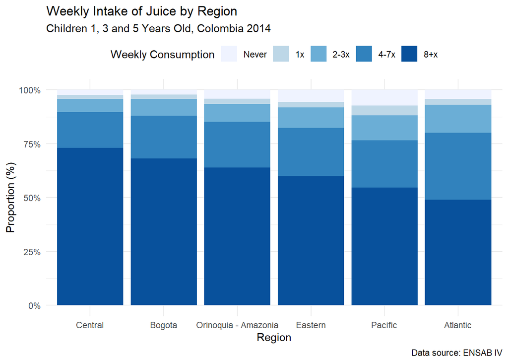

```r
# Region factor
region_order <- fig_dietregion %>%
  filter(Food == "juice", Freq == "8+x") %>%
  arrange(desc(Proportion)) %>%
  mutate(Region = fct_inorder(Region)) %>%
  pull(Region)

#graph
fig_dietregion %>%
  filter(Food == "juice") %>%
  mutate(Region = factor(Region, levels = region_order)) %>%
  ggplot(aes(x = Region, y = Proportion, fill = Freq)) +
  geom_col(position = "fill") +
  scale_y_continuous(labels = scales::percent_format()) +
  scale_fill_brewer(palette = "Blues", name = "Weekly Consumption") +
  labs(
    x = "Region",
    y = "Proportion (%)",
    title = "Weekly Intake of Juice by Region",
    subtitle = "Children 1, 3 and 5 Years Old, Colombia 2014",
    caption = "Data source: ENSAB IV"
  ) +
  theme_minimal() +
  theme(legend.position = "top")
```

# Collapsing categories with few numbers of observations

Socioeconomic status: Collapse “Middle low” into “Middle to high

```r
summary(ensab$ses)
```

```
##        Low low            Low     Middle low Middle to high
##           2622           2667            999             94
```

```r
ensab <- ensab %>%
  mutate(ses = dplyr::recode(ses,
                      "Middle low" = "Middle to high"))

summary(ensab$ses) #middle to high is now 999+94
```

```
##        Low low            Low Middle to high
##           2622           2667           1093
```

Income: Collapse Unemployed with Less than half NMW and collapse 2-3 NWM, 3-4 NMW and More than 4 NMW

```r
summary(ensab$income)
```

```
##         Unemployed Less than half NMW       Half - 1 NMW            1-2 NMW
##                 85                999               2500               2068
##            2-3 NMW            3-4 NMW    More than 4 NMW               NA's
##                402                112                122                 94
```

```r
ensab <- ensab %>%
  mutate(income = dplyr::recode(income,
                                "Unemployed" = "Less than half NMW",
                                "2-3 NMW" = "More than 2 NMW",
                                "3-4 NMW" = "More than 2 NMW",
                                "More than 4 NMW" = "More than 2 NMW"))
summary(ensab$income)
```

```
## Less than half NMW       Half - 1 NMW            1-2 NMW    More than 2 NMW
##               1084               2500               2068                636
##               NA's
##                 94
```

```r
summary(as.numeric(ensab$income))
```

```
##    Min. 1st Qu.  Median    Mean 3rd Qu.    Max.    NA's
##   1.000   2.000   2.000   2.359   3.000   4.000      94
```

Carbs: Collapse Never and Once a week with 2-3 times a week, to <4x (less than four times a week)

```r
summary(ensab$carbs)
```

```
## Never    1x  2-3x  4-7x   8+x
##    61    86   537  1909  3789
```

```r
summary(as.numeric(ensab$carbs))
```

```
##    Min. 1st Qu.  Median    Mean 3rd Qu.    Max.
##   1.000   4.000   5.000   4.454   5.000   5.000
```

```r
ensab <- ensab %>%
  mutate(carbs = dplyr::recode(carbs,
                               "Never" = "<4x",
                               "1x" = "<4x",
                               "2-3x" = "<4x"))

summary(ensab$carbs)
```

```
##  <4x 4-7x  8+x
##  684 1909 3789
```

```r
summary(as.numeric(ensab$carbs))
```

```
##    Min. 1st Qu.  Median    Mean 3rd Qu.    Max.
##   1.000   2.000   3.000   2.487   3.000   3.000
```

Fruits: Collapse Never and Once a week into <2x (less than twice a week)

```r
summary(ensab$fruit)
```

```
## Never    1x  2-3x  4-7x   8+x
##   638   421  1324  2098  1901
```

```r
ensab <- ensab %>%
  mutate(fruit = dplyr::recode(fruit,
                               "Never" = "<2x",
                               "1x" = "<2x"))
summary(ensab$fruit)
```

```
##  <2x 2-3x 4-7x  8+x
## 1059 1324 2098 1901
```

Protein: Collapse Never and Once a week with 2-3 times a week, to <4x (less than four times a week)

```r
summary(ensab$prot)
```

```
## Never    1x  2-3x  4-7x   8+x
##    37    93   747  2063  3442
```

```r
ensab <- ensab %>%
  mutate(prot = dplyr::recode(prot,
                               "Never" = "<4x",
                               "1x" = "<4x",
                               "2-3x" = "<4x"))
summary(ensab$prot)
```

```
##  <4x 4-7x  8+x
##  877 2063 3442
```

Dairy: Collapse Never and Once a week into <2x (less than twice a week)

```r
summary(ensab$dairy)
```

```
## Never    1x  2-3x  4-7x   8+x
##   407   229   770  1701  3275
```

```r
ensab <- ensab %>%
  mutate(dairy = dplyr::recode(dairy,
                               "Never" = "<2x",
                               "1x" = "<2x"))
summary(ensab$dairy)
```

```
##  <2x 2-3x 4-7x  8+x
##  636  770 1701 3275
```

Sodas and soft drinks

```r
summary(ensab$soda)
```

```
## Never    1x  2-3x  4-7x   8+x
##  2807  1384  1237   669   285
```

```r
ensab <- ensab %>%
  mutate(soda = dplyr::recode(soda,
                              "4-7x" = "4+x",
                              "8+x" = "4+x",))
summary(ensab$soda)
```

```
## Never    1x  2-3x   4+x
##  2807  1384  1237   954
```

Juice: Collapse Never and Once a week into <2x (less than twice a week)

```r
summary(ensab$juice)
```

```
## Never    1x  2-3x  4-7x   8+x
##   275   169   595  1422  3921
```

```r
ensab <- ensab %>%
  mutate(juice = dplyr::recode(juice,
                               "Never" = "<2x",
                               "1x" = "<2x"))
summary(ensab$juice)
```

```
##  <2x 2-3x 4-7x  8+x
##  444  595 1422 3921
```

# Table 4: Association between nutrition and caries

Steps of multivariable analysis: 1. DAG 2. Fit different models 4. Check for multi-collinearity with VIF 5. Check model fit with likelihood ratio test (chi squared): nested models. Backwards or forwards selection

## DAG

Created in the web version of dagitty: https://www.dagitty.net/dags.html

Copy and paste the code below into the web version to see the DAG with colors and to edit it/move it.

```r
if(!require("dagitty")) install.packages("dagitty")
```

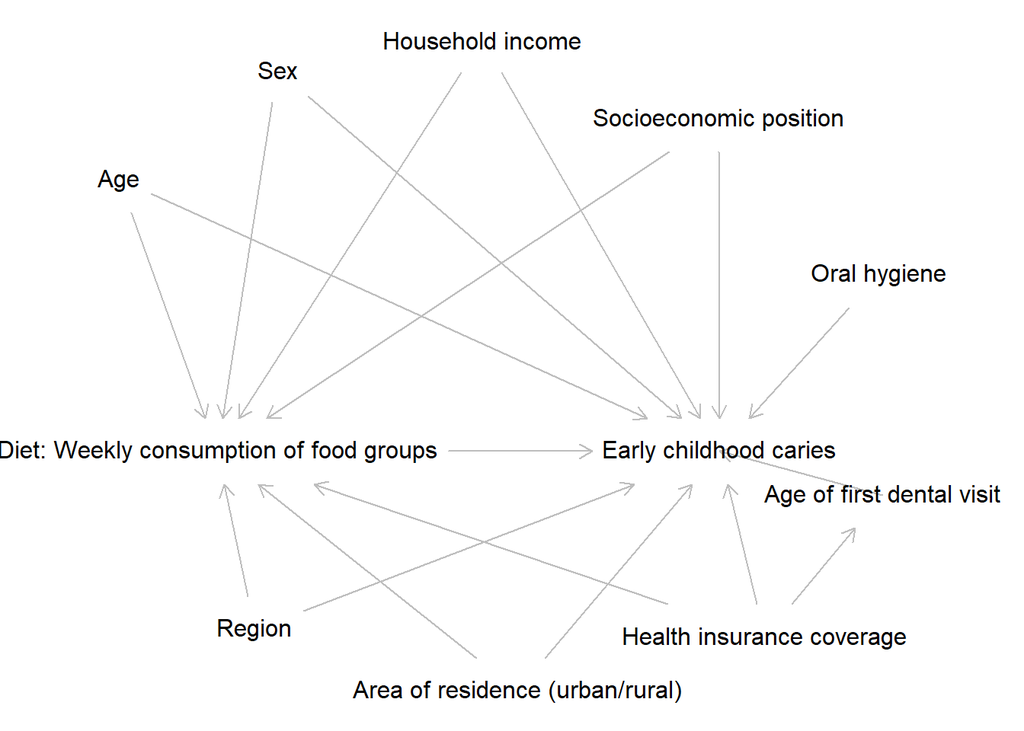

```r
library(dagitty)

dag <- dagitty('dag {
"Age of first dental visit" [pos="0.729,0.362"]
"Area of residence (urban/rural)" [pos="-0.270,1.100"]
"Diet: Weekly consumption of food groups" [exposure,pos="-1.091,0.196"]
"Early childhood caries" [outcome,pos="0.283,0.196"]
"Health insurance coverage" [pos="0.406,0.897"]
"Household income" [pos="-0.366,-1.356"]
"Oral hygiene" [pos="0.719,-0.470"]
"Socioeconomic position" [pos="0.280,-1.058"]
Age [pos="-1.359,-0.828"]
Region [pos="-0.988,0.868"]
Sex [pos="-0.927,-1.243"]
"Age of first dental visit" -> "Early childhood caries"
"Area of residence (urban/rural)" -> "Diet: Weekly consumption of food groups"
"Area of residence (urban/rural)" -> "Early childhood caries"
"Diet: Weekly consumption of food groups" -> "Early childhood caries"
"Health insurance coverage" -> "Age of first dental visit"
"Health insurance coverage" -> "Diet: Weekly consumption of food groups"
"Health insurance coverage" -> "Early childhood caries"
"Household income" -> "Diet: Weekly consumption of food groups"
"Household income" -> "Early childhood caries"
"Oral hygiene" -> "Early childhood caries"
"Socioeconomic position" -> "Diet: Weekly consumption of food groups"
"Socioeconomic position" -> "Early childhood caries"
Age -> "Diet: Weekly consumption of food groups"
Age -> "Early childhood caries"
Region -> "Diet: Weekly consumption of food groups"
Region -> "Early childhood caries"
Sex -> "Diet: Weekly consumption of food groups"
Sex -> "Early childhood caries"
}')

plot(dag)
```

## No survey design

Setup

```r
library(car) #for vif
if(!require("logbin")) install.packages("logbin")
library(logbin) #for log binomial regression
library(sandwich) #for robust variance
library(lmtest) #for coeftest
library(MASS) #for stepAIC, but it doesn't work with glmer. stepAIC can't be used when there is missing data.

#Create a binary version of cariesexp so poission can work
ensab <- ensab %>%
  mutate(cariesexp_num = ifelse(cariesexp == "Caries", 1, 0))
summary(ensab$cariesexp_num)
```

```
##    Min. 1st Qu.  Median    Mean 3rd Qu.    Max.
##  0.0000  0.0000  1.0000  0.6775  1.0000  1.0000
```

carbs, veg, fruit, prot, dairy, fats, sugar, soda, juice

### Carbs

```r
# Fit log binomial regression

m1carbs <- glm(cariesexp_num ~ carbs, data = ensab, family = "binomial"(link = "log"))
summary(m1carbs)
```

```
##
## Call:
## glm(formula = cariesexp_num ~ carbs, family = binomial(link = "log"),
##     data = ensab)
##
## Coefficients:
##             Estimate Std. Error z value Pr(>|z|)
## (Intercept) -0.46185    0.02929 -15.766  < 2e-16 ***
## carbs4-7x    0.04876    0.03356   1.453  0.14622
## carbs8+x     0.09673    0.03122   3.099  0.00194 **
## ---
## Signif. codes:  0 '***' 0.001 '**' 0.01 '*' 0.05 '.' 0.1 ' ' 1
##
## (Dispersion parameter for binomial family taken to be 1)
##
##     Null deviance: 8024.9  on 6381  degrees of freedom
## Residual deviance: 8011.1  on 6379  degrees of freedom
## AIC: 8017.1
##
## Number of Fisher Scoring iterations: 5
```

```r
# mcarbs <- glm(cariesexp_num ~ carbs + age + sex + ses + income + insurance + region + location, data = ensab, family = "binomial"(link = "log"))

#failed to converge so will try logbin package

# mcarbs <- logbin(cariesexp_num ~ carbs + age + sex + ses + income + insurance + region + location,
#   data = ensab)

#also failed to converge so will use poisson regression with robust SEs

m2carbs <- glm(cariesexp_num ~ carbs + age + sex + region + ses + income + insurance + location,
  family = poisson(link = "log"), data = ensab)
summary(m2carbs)
```

```
##
## Call:
## glm(formula = cariesexp_num ~ carbs + age + sex + region + ses +
##     income + insurance + location, family = poisson(link = "log"),
##     data = ensab)
##
## Coefficients:
##                             Estimate Std. Error z value Pr(>|z|)
## (Intercept)                -1.068116   0.098348 -10.861  < 2e-16 ***
## carbs4-7x                   0.014156   0.056528   0.250 0.802261
## carbs8+x                    0.017371   0.053013   0.328 0.743157
## age3                        0.948581   0.046078  20.586  < 2e-16 ***
## age5                        0.995143   0.045325  21.956  < 2e-16 ***
## sexFeminine                -0.047553   0.030732  -1.547 0.121778
## regionEastern               0.016404   0.054683   0.300 0.764193
## regionCentral               0.001471   0.054877   0.027 0.978619
## regionPacific              -0.223999   0.058032  -3.860 0.000113 ***
## regionBogota                0.099419   0.054266   1.832 0.066944 .
## regionOrinoquia - Amazonia -0.015877   0.053018  -0.299 0.764577
## sesLow                      0.010553   0.037871   0.279 0.780504
## sesMiddle to high          -0.075253   0.052331  -1.438 0.150424
## incomeHalf - 1 NMW         -0.022236   0.044705  -0.497 0.618917
## income1-2 NMW              -0.009247   0.049235  -0.188 0.851029
## incomeMore than 2 NMW      -0.014407   0.068120  -0.211 0.832501
## insuranceContributory      -0.085452   0.066019  -1.294 0.195542
## insuranceSubsidized        -0.017908   0.063530  -0.282 0.778034
## insuranceOther             -0.078676   0.098200  -0.801 0.423025
## locationRural               0.089608   0.042870   2.090 0.036597 *
## ---
## Signif. codes:  0 '***' 0.001 '**' 0.01 '*' 0.05 '.' 0.1 ' ' 1
##
## (Dispersion parameter for poisson family taken to be 1)
##
##     Null deviance: 3306.5  on 6287  degrees of freedom
## Residual deviance: 2610.0  on 6268  degrees of freedom
##   (94 observations deleted due to missingness)
## AIC: 11188
##
## Number of Fisher Scoring iterations: 5
```

```r
coeftest(m2carbs, vcov = sandwich)# Robust standard errors
```

```
##
## z test of coefficients:
##
##                              Estimate Std. Error  z value  Pr(>|z|)
## (Intercept)                -1.0681162  0.0536622 -19.9045 < 2.2e-16 ***
## carbs4-7x                   0.0141559  0.0278795   0.5078  0.611627
## carbs8+x                    0.0173710  0.0260095   0.6679  0.504217
## age3                        0.9485814  0.0332784  28.5044 < 2.2e-16 ***
## age5                        0.9951426  0.0328101  30.3304 < 2.2e-16 ***
## sexFeminine                -0.0475526  0.0145986  -3.2573  0.001125 **
## regionEastern               0.0164037  0.0250095   0.6559  0.511889
## regionCentral               0.0014708  0.0257390   0.0571  0.954433
## regionPacific              -0.2239993  0.0303845  -7.3722 1.679e-13 ***
## regionBogota                0.0994189  0.0252083   3.9439 8.017e-05 ***
## regionOrinoquia - Amazonia -0.0158775  0.0258176  -0.6150  0.538564
## sesLow                      0.0105531  0.0179855   0.5868  0.557367
## sesMiddle to high          -0.0752534  0.0258507  -2.9111  0.003602 **
## incomeHalf - 1 NMW         -0.0222355  0.0205453  -1.0823  0.279133
## income1-2 NMW              -0.0092466  0.0231405  -0.3996  0.689463
## incomeMore than 2 NMW      -0.0144070  0.0335731  -0.4291  0.667833
## insuranceContributory      -0.0854521  0.0328888  -2.5982  0.009371 **
## insuranceSubsidized        -0.0179079  0.0311954  -0.5741  0.565931
## insuranceOther             -0.0786761  0.0486890  -1.6159  0.106118
## locationRural               0.0896080  0.0191372   4.6824 2.835e-06 ***
## ---
## Signif. codes:  0 '***' 0.001 '**' 0.01 '*' 0.05 '.' 0.1 ' ' 1
```

```r
exp(m2carbs$coefficients) #PR
```

```
##                (Intercept)                  carbs4-7x
##                  0.3436553                  1.0142566
##                   carbs8+x                       age3
##                  1.0175227                  2.5820441
##                       age5                sexFeminine
##                  2.7051101                  0.9535603
##              regionEastern              regionCentral
##                  1.0165390                  1.0014718
##              regionPacific               regionBogota
##                  0.7993157                  1.1045289
## regionOrinoquia - Amazonia                     sesLow
##                  0.9842479                  1.0106090
##          sesMiddle to high         incomeHalf - 1 NMW
##                  0.9275084                  0.9780099
##              income1-2 NMW      incomeMore than 2 NMW
##                  0.9907960                  0.9856962
##      insuranceContributory        insuranceSubsidized
##                  0.9180971                  0.9822515
##             insuranceOther              locationRural
##                  0.9243392                  1.0937454
```

```r
#exp(confint(m2carbs)) # NOT CORRECT because doesn't use robust standard errors

robust_se <- coeftest(m2carbs, vcov = sandwich)[, 2]  # Extract robust standard errors
pvalue <- coeftest(m2carbs, vcov = sandwich)[, 4]  # Extract p-values

# Compute confidence intervals
carbs_ci <- data.frame(
  Estimate = round(exp(coef(m2carbs)), 3),  # PR (Prevalence Ratio)
  Lower_CI = round(exp(coef(m2carbs) - 1.96 * robust_se), 3),
  Upper_CI = round(exp(coef(m2carbs) + 1.96 * robust_se), 3),
  P_value = round(pvalue, 4)
)  %>%
  mutate(
    PR = paste0(Estimate, " (", Lower_CI, ", ", Upper_CI, ")"),
    Food = "Carbs"
  ) %>%
  rownames_to_column() %>%
  filter(grepl("^carbs", rowname)) %>%
  mutate(rowname = str_remove(rowname, "^carbs")) %>%
  rename(Freq = rowname) %>%
  dplyr::select(Food, Freq, PR, P_value)
carbs_ci
```

```
##    Food Freq                   PR P_value
## 1 Carbs 4-7x  1.014 (0.96, 1.071)  0.6116
## 2 Carbs  8+x 1.018 (0.967, 1.071)  0.5042
```

```r
vif(m2carbs) #checking multicollinearity
```

```
##               GVIF Df GVIF^(1/(2*Df))
## carbs     1.042791  2        1.010530
## age       1.009305  2        1.002318
## sex       1.003949  1        1.001972
## region    1.371506  5        1.032095
## ses       1.488725  2        1.104596
## income    1.383527  3        1.055597
## insurance 1.418502  3        1.059998
## location  1.245588  1        1.116059
```

Take this code and replace “carbs” with every single variable name listed:

```r
m1veg <- glm(cariesexp_num ~ veg, data = ensab, family = "binomial"(link = "log"))
summary(m1veg)
```

```
##
## Call:
## glm(formula = cariesexp_num ~ veg, family = binomial(link = "log"),
##     data = ensab)
##
## Coefficients:
##             Estimate Std. Error z value Pr(>|z|)
## (Intercept) -0.32356    0.02051 -15.774  < 2e-16 ***
## veg1x       -0.00754    0.03355  -0.225 0.822160
## veg2-3x     -0.08222    0.02720  -3.023 0.002505 **
## veg4-7x     -0.07927    0.02567  -3.087 0.002019 **
## veg8+x      -0.09901    0.02891  -3.425 0.000614 ***
## ---
## Signif. codes:  0 '***' 0.001 '**' 0.01 '*' 0.05 '.' 0.1 ' ' 1
##
## (Dispersion parameter for binomial family taken to be 1)
##
##     Null deviance: 8024.9  on 6381  degrees of freedom
## Residual deviance: 8007.1  on 6377  degrees of freedom
## AIC: 8017.1
##
## Number of Fisher Scoring iterations: 5
```

```r
m2veg <- glm(cariesexp_num ~ veg + age + sex + region + ses + income + insurance + location,
             family = poisson(link = "log"), data = ensab)
summary(m2veg)
```

```
##
## Call:
## glm(formula = cariesexp_num ~ veg + age + sex + region + ses +
##     income + insurance + location, family = poisson(link = "log"),
##     data = ensab)
##
## Coefficients:
##                             Estimate Std. Error z value Pr(>|z|)
## (Intercept)                -1.015128   0.090583 -11.207  < 2e-16 ***
## veg1x                      -0.015717   0.063985  -0.246 0.805968
## veg2-3x                    -0.069152   0.050716  -1.364 0.172724
## veg4-7x                    -0.057901   0.048567  -1.192 0.233192
## veg8+x                     -0.060865   0.053901  -1.129 0.258813
## age3                        0.948603   0.046047  20.601  < 2e-16 ***
## age5                        0.994624   0.045301  21.956  < 2e-16 ***
## sexFeminine                -0.047677   0.030736  -1.551 0.120856
## regionEastern               0.021925   0.054628   0.401 0.688166
## regionCentral               0.008336   0.055250   0.151 0.880072
## regionPacific              -0.221069   0.057824  -3.823 0.000132 ***
## regionBogota                0.105466   0.054458   1.937 0.052787 .
## regionOrinoquia - Amazonia -0.012709   0.052722  -0.241 0.809517
## sesLow                      0.010294   0.037869   0.272 0.785743
## sesMiddle to high          -0.074528   0.052397  -1.422 0.154921
## incomeHalf - 1 NMW         -0.018384   0.044778  -0.411 0.681391
## income1-2 NMW              -0.003459   0.049392  -0.070 0.944173
## incomeMore than 2 NMW      -0.006783   0.068257  -0.099 0.920838
## insuranceContributory      -0.081134   0.066089  -1.228 0.219579
## insuranceSubsidized        -0.015208   0.063567  -0.239 0.810922
## insuranceOther             -0.074382   0.098242  -0.757 0.448972
## locationRural               0.086268   0.042964   2.008 0.044654 *
## ---
## Signif. codes:  0 '***' 0.001 '**' 0.01 '*' 0.05 '.' 0.1 ' ' 1
##
## (Dispersion parameter for poisson family taken to be 1)
##
##     Null deviance: 3306.5  on 6287  degrees of freedom
## Residual deviance: 2607.6  on 6266  degrees of freedom
##   (94 observations deleted due to missingness)
## AIC: 11190
##
## Number of Fisher Scoring iterations: 5
```

```r
coeftest(m2veg, vcov = sandwich)# Robust standard errors
```

```
##
## z test of coefficients:
##
##                              Estimate Std. Error  z value  Pr(>|z|)
## (Intercept)                -1.0151284  0.0501312 -20.2494 < 2.2e-16 ***
## veg1x                      -0.0157167  0.0299555  -0.5247  0.599815
## veg2-3x                    -0.0691516  0.0233441  -2.9623  0.003054 **
## veg4-7x                    -0.0579009  0.0218035  -2.6556  0.007917 **
## veg8+x                     -0.0608653  0.0251856  -2.4167  0.015663 *
## age3                        0.9486034  0.0332409  28.5372 < 2.2e-16 ***
## age5                        0.9946244  0.0327689  30.3527 < 2.2e-16 ***
## sexFeminine                -0.0476773  0.0145844  -3.2691  0.001079 **
## regionEastern               0.0219245  0.0249390   0.8791  0.379333
## regionCentral               0.0083360  0.0258804   0.3221  0.747381
## regionPacific              -0.2210687  0.0303570  -7.2823 3.282e-13 ***
## regionBogota                0.1054659  0.0252395   4.1786 2.933e-05 ***
## regionOrinoquia - Amazonia -0.0127086  0.0255897  -0.4966  0.619451
## sesLow                      0.0102944  0.0179711   0.5728  0.566760
## sesMiddle to high          -0.0745279  0.0258677  -2.8811  0.003963 **
## incomeHalf - 1 NMW         -0.0183843  0.0205063  -0.8965  0.369975
## income1-2 NMW              -0.0034587  0.0231946  -0.1491  0.881462
## incomeMore than 2 NMW      -0.0067833  0.0336011  -0.2019  0.840014
## insuranceContributory      -0.0811345  0.0329094  -2.4654  0.013687 *
## insuranceSubsidized        -0.0152076  0.0312052  -0.4873  0.626015
## insuranceOther             -0.0743822  0.0488646  -1.5222  0.127956
## locationRural               0.0862682  0.0191432   4.5065 6.592e-06 ***
## ---
## Signif. codes:  0 '***' 0.001 '**' 0.01 '*' 0.05 '.' 0.1 ' ' 1
```

```r
exp(m2veg$coefficients) #PR
```

```
##                (Intercept)                      veg1x
##                  0.3623559                  0.9844062
##                    veg2-3x                    veg4-7x
##                  0.9331852                  0.9437435
##                     veg8+x                       age3
##                  0.9409500                  2.5821009
##                       age5                sexFeminine
##                  2.7037086                  0.9534414
##              regionEastern              regionCentral
##                  1.0221666                  1.0083708
##              regionPacific               regionBogota
##                  0.8016616                  1.1112283
## regionOrinoquia - Amazonia                     sesLow
##                  0.9873719                  1.0103476
##          sesMiddle to high         incomeHalf - 1 NMW
##                  0.9281816                  0.9817836
##              income1-2 NMW      incomeMore than 2 NMW
##                  0.9965473                  0.9932397
##      insuranceContributory        insuranceSubsidized
##                  0.9220697                  0.9849074
##             insuranceOther              locationRural
##                  0.9283168                  1.0900987
```

```r
robust_se <- coeftest(m2veg, vcov = sandwich)[, 2]  # Extract robust standard errors
pvalue <- coeftest(m2veg, vcov = sandwich)[, 4]

veg_ci <- data.frame(
  Estimate = round(exp(coef(m2veg)), 3),
  Lower_CI = round(exp(coef(m2veg) - 1.96 * robust_se), 3),
  Upper_CI = round(exp(coef(m2veg) + 1.96 * robust_se), 3),
  P_value = round(pvalue, 4)
) %>%
  mutate(
    PR = paste0(Estimate, " (", Lower_CI, ", ", Upper_CI, ")"),
    Food = "Veg"
  ) %>%
  rownames_to_column() %>%
  filter(grepl("^veg", rowname)) %>%
  mutate(rowname = str_remove(rowname, "^veg")) %>%
  rename(Freq = rowname) %>%
  dplyr::select(Food, Freq, PR, P_value)
veg_ci
```

```
##   Food Freq                   PR P_value
## 1  Veg   1x 0.984 (0.928, 1.044)  0.5998
## 2  Veg 2-3x 0.933 (0.891, 0.977)  0.0031
## 3  Veg 4-7x 0.944 (0.904, 0.985)  0.0079
## 4  Veg  8+x 0.941 (0.896, 0.989)  0.0157
```

```r
vif(m2veg) #checking multicollinearity
```

```
##               GVIF Df GVIF^(1/(2*Df))
## veg       1.092326  4        1.011100
## age       1.009965  2        1.002482
## sex       1.004233  1        1.002114
## region    1.379515  5        1.032696
## ses       1.491232  2        1.105061
## income    1.395171  3        1.057072
## insurance 1.423108  3        1.060571
## location  1.251083  1        1.118518
```

### Fruits

```r
m1fruit <- glm(cariesexp_num ~ fruit, data = ensab, family = "binomial"(link = "log"))
summary(m1fruit)
```

```
##
## Call:
## glm(formula = cariesexp_num ~ fruit, family = binomial(link = "log"),
##     data = ensab)
##
## Coefficients:
##             Estimate Std. Error z value Pr(>|z|)
## (Intercept) -0.40972    0.02187 -18.737   <2e-16 ***
## fruit2-3x    0.03035    0.02875   1.056    0.291
## fruit4-7x    0.01091    0.02668   0.409    0.683
## fruit8+x     0.03508    0.02678   1.310    0.190
## ---
## Signif. codes:  0 '***' 0.001 '**' 0.01 '*' 0.05 '.' 0.1 ' ' 1
##
## (Dispersion parameter for binomial family taken to be 1)
##
##     Null deviance: 8024.9  on 6381  degrees of freedom
## Residual deviance: 8022.5  on 6378  degrees of freedom
## AIC: 8030.5
##
## Number of Fisher Scoring iterations: 5
```

```r
m2fruit <- glm(cariesexp_num ~ fruit + age + sex + region + ses + income + insurance + location,
             family = poisson(link = "log"), data = ensab)
summary(m2fruit)
```

```
##
## Call:
## glm(formula = cariesexp_num ~ fruit + age + sex + region + ses +
##     income + insurance + location, family = poisson(link = "log"),
##     data = ensab)
##
## Coefficients:
##                              Estimate Std. Error z value Pr(>|z|)
## (Intercept)                -1.0506752  0.0899003 -11.687  < 2e-16 ***
## fruit2-3x                   0.0075349  0.0508452   0.148   0.8822
## fruit4-7x                  -0.0145517  0.0474461  -0.307   0.7591
## fruit8+x                    0.0064434  0.0486733   0.132   0.8947
## age3                        0.9491664  0.0460820  20.597  < 2e-16 ***
## age5                        0.9956410  0.0452762  21.990  < 2e-16 ***
## sexFeminine                -0.0477056  0.0307060  -1.554   0.1203
## regionEastern               0.0149275  0.0545468   0.274   0.7843
## regionCentral               0.0002616  0.0548613   0.005   0.9962
## regionPacific              -0.2266039  0.0578330  -3.918 8.92e-05 ***
## regionBogota                0.0973750  0.0546441   1.782   0.0748 .
## regionOrinoquia - Amazonia -0.0187008  0.0525887  -0.356   0.7221
## sesLow                      0.0105508  0.0379162   0.278   0.7808
## sesMiddle to high          -0.0753532  0.0524677  -1.436   0.1510
## incomeHalf - 1 NMW         -0.0223056  0.0447813  -0.498   0.6184
## income1-2 NMW              -0.0093722  0.0493496  -0.190   0.8494
## incomeMore than 2 NMW      -0.0137762  0.0683345  -0.202   0.8402
## insuranceContributory      -0.0853981  0.0661113  -1.292   0.1964
## insuranceSubsidized        -0.0182813  0.0635639  -0.288   0.7736
## insuranceOther             -0.0793025  0.0982258  -0.807   0.4195
## locationRural               0.0896960  0.0429081   2.090   0.0366 *
## ---
## Signif. codes:  0 '***' 0.001 '**' 0.01 '*' 0.05 '.' 0.1 ' ' 1
##
## (Dispersion parameter for poisson family taken to be 1)
##
##     Null deviance: 3306.5  on 6287  degrees of freedom
## Residual deviance: 2609.7  on 6267  degrees of freedom
##   (94 observations deleted due to missingness)
## AIC: 11190
##
## Number of Fisher Scoring iterations: 5
```

```r
coeftest(m2fruit, vcov = sandwich)# Robust standard errors
```

```
##
## z test of coefficients:
##
##                               Estimate  Std. Error  z value  Pr(>|z|)
## (Intercept)                -1.05067516  0.05024008 -20.9131 < 2.2e-16 ***
## fruit2-3x                   0.00753490  0.02525605   0.2983 0.7654432
## fruit4-7x                  -0.01455169  0.02350143  -0.6192 0.5357957
## fruit8+x                    0.00644338  0.02363873   0.2726 0.7851783
## age3                        0.94916635  0.03326243  28.5357 < 2.2e-16 ***
## age5                        0.99564104  0.03277784  30.3754 < 2.2e-16 ***
## sexFeminine                -0.04770565  0.01458293  -3.2713 0.0010704 **
## regionEastern               0.01492750  0.02494135   0.5985 0.5495036
## regionCentral               0.00026156  0.02573471   0.0102 0.9918908
## regionPacific              -0.22660385  0.03034284  -7.4681 8.135e-14 ***
## regionBogota                0.09737500  0.02515840   3.8705 0.0001086 ***
## regionOrinoquia - Amazonia -0.01870082  0.02554595  -0.7320 0.4641403
## sesLow                      0.01055080  0.01802172   0.5854 0.5582458
## sesMiddle to high          -0.07535319  0.02593056  -2.9060 0.0036613 **
## incomeHalf - 1 NMW         -0.02230556  0.02058516  -1.0836 0.2785533
## income1-2 NMW              -0.00937223  0.02317920  -0.4043 0.6859643
## incomeMore than 2 NMW      -0.01377624  0.03367912  -0.4090 0.6825074
## insuranceContributory      -0.08539812  0.03302419  -2.5859 0.0097118 **
## insuranceSubsidized        -0.01828128  0.03128535  -0.5843 0.5589916
## insuranceOther             -0.07930245  0.04879424  -1.6252 0.1041110
## locationRural               0.08969599  0.01917540   4.6777 2.902e-06 ***
## ---
## Signif. codes:  0 '***' 0.001 '**' 0.01 '*' 0.05 '.' 0.1 ' ' 1
```

```r
exp(m2fruit$coefficients) #PR
```

```
##                (Intercept)                  fruit2-3x
##                  0.3497016                  1.0075634
##                  fruit4-7x                   fruit8+x
##                  0.9855537                  1.0064642
##                       age3                       age5
##                  2.5835550                  2.7064587
##                sexFeminine              regionEastern
##                  0.9534144                  1.0150395
##              regionCentral              regionPacific
##                  1.0002616                  0.7972365
##               regionBogota regionOrinoquia - Amazonia
##                  1.1022736                  0.9814730
##                     sesLow          sesMiddle to high
##                  1.0106067                  0.9274159
##         incomeHalf - 1 NMW              income1-2 NMW
##                  0.9779414                  0.9906716
##      incomeMore than 2 NMW      insuranceContributory
##                  0.9863182                  0.9181467
##        insuranceSubsidized             insuranceOther
##                  0.9818848                  0.9237605
##              locationRural
##                  1.0938417
```

```r
robust_se <- coeftest(m2fruit, vcov = sandwich)[, 2]  # Extract robust standard errors
pvalue <- coeftest(m2fruit, vcov = sandwich)[, 4]

fruit_ci <- data.frame(
  Estimate = round(exp(coef(m2fruit)), 3),
  Lower_CI = round(exp(coef(m2fruit) - 1.96 * robust_se), 3),
  Upper_CI = round(exp(coef(m2fruit) + 1.96 * robust_se), 3),
  P_value = round(pvalue, 4)
) %>%
  mutate(
    PR = paste0(Estimate, " (", Lower_CI, ", ", Upper_CI, ")"),
    Food = "Fruit"
  ) %>%
  rownames_to_column() %>%
  filter(grepl("^fruit", rowname)) %>%
  mutate(rowname = str_remove(rowname, "^fruit")) %>%
  rename(Freq = rowname) %>%
  dplyr::select(Food, Freq, PR, P_value)
fruit_ci
```

```
##    Food Freq                   PR P_value
## 1 Fruit 2-3x 1.008 (0.959, 1.059)  0.7654
## 2 Fruit 4-7x 0.986 (0.941, 1.032)  0.5358
## 3 Fruit  8+x 1.006 (0.961, 1.054)  0.7852
```

```r
vif(m2fruit) #checking multicollinearity
```

```
##               GVIF Df GVIF^(1/(2*Df))
## fruit     1.089165  3        1.014337
## age       1.009737  2        1.002426
## sex       1.002276  1        1.001137
## region    1.371507  5        1.032095
## ses       1.496647  2        1.106063
## income    1.394735  3        1.057017
## insurance 1.422882  3        1.060543
## location  1.247803  1        1.117051
```

### Protein

```r
m1prot <- glm(cariesexp_num ~ prot, data = ensab, family = "binomial"(link = "log"))
summary(m1prot)
```

```
##
## Call:
## glm(formula = cariesexp_num ~ prot, family = binomial(link = "log"),
##     data = ensab)
##
## Coefficients:
##             Estimate Std. Error z value Pr(>|z|)
## (Intercept) -0.48494    0.02668 -18.179  < 2e-16 ***
## prot4-7x     0.10010    0.03065   3.266  0.00109 **
## prot8+x      0.11599    0.02900   3.999 6.36e-05 ***
## ---
## Signif. codes:  0 '***' 0.001 '**' 0.01 '*' 0.05 '.' 0.1 ' ' 1
##
## (Dispersion parameter for binomial family taken to be 1)
##
##     Null deviance: 8024.9  on 6381  degrees of freedom
## Residual deviance: 8006.9  on 6379  degrees of freedom
## AIC: 8012.9
##
## Number of Fisher Scoring iterations: 5
```

```r
m2prot <- glm(cariesexp_num ~ prot + age + sex + region + ses + income + insurance + location,
             family = poisson(link = "log"), data = ensab)
summary(m2prot)
```

```
##
## Call:
## glm(formula = cariesexp_num ~ prot + age + sex + region + ses +
##     income + insurance + location, family = poisson(link = "log"),
##     data = ensab)
##
## Coefficients:
##                             Estimate Std. Error z value Pr(>|z|)
## (Intercept)                -1.067722   0.093071 -11.472  < 2e-16 ***
## prot4-7x                    0.025845   0.051023   0.507   0.6125
## prot8+x                     0.013587   0.048521   0.280   0.7795
## age3                        0.948425   0.046107  20.570  < 2e-16 ***
## age5                        0.995123   0.045398  21.920  < 2e-16 ***
## sexFeminine                -0.048046   0.030715  -1.564   0.1178
## regionEastern               0.014277   0.054430   0.262   0.7931
## regionCentral               0.001425   0.055000   0.026   0.9793
## regionPacific              -0.225278   0.057700  -3.904 9.45e-05 ***
## regionBogota                0.099015   0.054291   1.824   0.0682 .
## regionOrinoquia - Amazonia -0.017960   0.052558  -0.342   0.7326
## sesLow                      0.009835   0.037848   0.260   0.7950
## sesMiddle to high          -0.075568   0.052375  -1.443   0.1491
## incomeHalf - 1 NMW         -0.022171   0.044730  -0.496   0.6201
## income1-2 NMW              -0.009251   0.049313  -0.188   0.8512
## incomeMore than 2 NMW      -0.014387   0.068130  -0.211   0.8328
## insuranceContributory      -0.085431   0.066017  -1.294   0.1956
## insuranceSubsidized        -0.017754   0.063532  -0.279   0.7799
## insuranceOther             -0.079549   0.098187  -0.810   0.4178
## locationRural               0.089778   0.042875   2.094   0.0363 *
## ---
## Signif. codes:  0 '***' 0.001 '**' 0.01 '*' 0.05 '.' 0.1 ' ' 1
##
## (Dispersion parameter for poisson family taken to be 1)
##
##     Null deviance: 3306.5  on 6287  degrees of freedom
## Residual deviance: 2609.9  on 6268  degrees of freedom
##   (94 observations deleted due to missingness)
## AIC: 11188
##
## Number of Fisher Scoring iterations: 5
```

```r
coeftest(m2prot, vcov = sandwich)# Robust standard errors
```

```
##
## z test of coefficients:
##
##                              Estimate Std. Error  z value  Pr(>|z|)
## (Intercept)                -1.0677215  0.0520116 -20.5285 < 2.2e-16 ***
## prot4-7x                    0.0258449  0.0255392   1.0120 0.3115524
## prot8+x                     0.0135872  0.0241234   0.5632 0.5732732
## age3                        0.9484251  0.0333072  28.4751 < 2.2e-16 ***
## age5                        0.9951234  0.0328284  30.3128 < 2.2e-16 ***
## sexFeminine                -0.0480461  0.0145770  -3.2960 0.0009806 ***
## regionEastern               0.0142775  0.0249414   0.5724 0.5670236
## regionCentral               0.0014253  0.0257460   0.0554 0.9558511
## regionPacific              -0.2252782  0.0304021  -7.4100 1.263e-13 ***
## regionBogota                0.0990153  0.0250919   3.9461 7.943e-05 ***
## regionOrinoquia - Amazonia -0.0179595  0.0255203  -0.7037 0.4815967
## sesLow                      0.0098347  0.0179676   0.5474 0.5841344
## sesMiddle to high          -0.0755677  0.0258657  -2.9215 0.0034831 **
## incomeHalf - 1 NMW         -0.0221707  0.0205531  -1.0787 0.2807207
## income1-2 NMW              -0.0092509  0.0231847  -0.3990 0.6898871
## incomeMore than 2 NMW      -0.0143872  0.0335440  -0.4289 0.6679923
## insuranceContributory      -0.0854311  0.0328830  -2.5980 0.0093759 **
## insuranceSubsidized        -0.0177536  0.0311893  -0.5692 0.5692057
## insuranceOther             -0.0795490  0.0487437  -1.6320 0.1026826
## locationRural               0.0897779  0.0191692   4.6835 2.821e-06 ***
## ---
## Signif. codes:  0 '***' 0.001 '**' 0.01 '*' 0.05 '.' 0.1 ' ' 1
```

```r
exp(m2prot$coefficients) #PR
```

```
##                (Intercept)                   prot4-7x
##                  0.3437909                  1.0261818
##                    prot8+x                       age3
##                  1.0136799                  2.5816406
##                       age5                sexFeminine
##                  2.7050582                  0.9530898
##              regionEastern              regionCentral
##                  1.0143799                  1.0014263
##              regionPacific               regionBogota
##                  0.7982941                  1.1040832
## regionOrinoquia - Amazonia                     sesLow
##                  0.9822008                  1.0098832
##          sesMiddle to high         incomeHalf - 1 NMW
##                  0.9272169                  0.9780733
##              income1-2 NMW      incomeMore than 2 NMW
##                  0.9907918                  0.9857158
##      insuranceContributory        insuranceSubsidized
##                  0.9181164                  0.9824030
##             insuranceOther              locationRural
##                  0.9235327                  1.0939312
```

```r
robust_se <- coeftest(m2prot, vcov = sandwich)[, 2]  # Extract robust standard errors
#CI
pvalue <- coeftest(m2prot, vcov = sandwich)[, 4]

prot_ci <- data.frame(
  Estimate = round(exp(coef(m2prot)), 3),
  Lower_CI = round(exp(coef(m2prot) - 1.96 * robust_se), 3),
  Upper_CI = round(exp(coef(m2prot) + 1.96 * robust_se), 3),
  P_value = round(pvalue, 4)
) %>%
  mutate(
    PR = paste0(Estimate, " (", Lower_CI, ", ", Upper_CI, ")"),
    Food = "Prot"
  ) %>%
  rownames_to_column() %>%
  filter(grepl("^prot", rowname)) %>%
  mutate(rowname = str_remove(rowname, "^prot")) %>%
  rename(Freq = rowname) %>%
  dplyr::select(Food, Freq, PR, P_value)
prot_ci
```

```
##   Food Freq                   PR P_value
## 1 Prot 4-7x 1.026 (0.976, 1.079)  0.3116
## 2 Prot  8+x 1.014 (0.967, 1.063)  0.5733
```

```r
vif(m2prot) #checking multicollinearity
```

```
##               GVIF Df GVIF^(1/(2*Df))
## prot      1.046717  2        1.011480
## age       1.012698  2        1.003160
## sex       1.002860  1        1.001429
## region    1.358895  5        1.031142
## ses       1.489332  2        1.104709
## income    1.387237  3        1.056068
## insurance 1.418279  3        1.059970
## location  1.245868  1        1.116185
```

### Dairy

```r
m1dairy <- glm(cariesexp_num ~ dairy, data = ensab, family = "binomial"(link = "log"))
summary(m1dairy)
```

```
##
## Call:
## glm(formula = cariesexp_num ~ dairy, family = binomial(link = "log"),
##     data = ensab)
##
## Coefficients:
##             Estimate Std. Error z value Pr(>|z|)
## (Intercept) -0.41257    0.02834 -14.559   <2e-16 ***
## dairy2-3x    0.07972    0.03627   2.198   0.0280 *
## dairy4-7x    0.07609    0.03222   2.362   0.0182 *
## dairy8+x    -0.01482    0.03108  -0.477   0.6335
## ---
## Signif. codes:  0 '***' 0.001 '**' 0.01 '*' 0.05 '.' 0.1 ' ' 1
##
## (Dispersion parameter for binomial family taken to be 1)
##
##     Null deviance: 8024.9  on 6381  degrees of freedom
## Residual deviance: 7998.4  on 6378  degrees of freedom
## AIC: 8006.4
##
## Number of Fisher Scoring iterations: 5
```

```r
m2dairy <- glm(cariesexp_num ~ dairy + age + sex + region + ses + income + insurance + location,
             family = poisson(link = "log"), data = ensab)
summary(m2dairy)
```

```
##
## Call:
## glm(formula = cariesexp_num ~ dairy + age + sex + region + ses +
##     income + insurance + location, family = poisson(link = "log"),
##     data = ensab)
##
## Coefficients:
##                             Estimate Std. Error z value Pr(>|z|)
## (Intercept)                -1.069929   0.095994 -11.146  < 2e-16 ***
## dairy2-3x                   0.044723   0.065928   0.678   0.4975
## dairy4-7x                   0.030766   0.058637   0.525   0.5998
## dairy8+x                    0.008067   0.056195   0.144   0.8859
## age3                        0.947153   0.046101  20.545  < 2e-16 ***
## age5                        0.992764   0.045429  21.853  < 2e-16 ***
## sexFeminine                -0.048479   0.030712  -1.579   0.1144
## regionEastern               0.013874   0.054448   0.255   0.7989
## regionCentral               0.002201   0.054897   0.040   0.9680
## regionPacific              -0.226908   0.057795  -3.926 8.63e-05 ***
## regionBogota                0.098811   0.054180   1.824   0.0682 .
## regionOrinoquia - Amazonia -0.017839   0.052821  -0.338   0.7356
## sesLow                      0.009656   0.037918   0.255   0.7990
## sesMiddle to high          -0.074107   0.052396  -1.414   0.1573
## incomeHalf - 1 NMW         -0.022187   0.044865  -0.495   0.6209
## income1-2 NMW              -0.006707   0.049652  -0.135   0.8925
## incomeMore than 2 NMW      -0.011391   0.068417  -0.166   0.8678
## insuranceContributory      -0.085466   0.066100  -1.293   0.1960
## insuranceSubsidized        -0.017700   0.063569  -0.278   0.7807
## insuranceOther             -0.078451   0.098211  -0.799   0.4244
## locationRural               0.091914   0.043073   2.134   0.0328 *
## ---
## Signif. codes:  0 '***' 0.001 '**' 0.01 '*' 0.05 '.' 0.1 ' ' 1
##
## (Dispersion parameter for poisson family taken to be 1)
##
##     Null deviance: 3306.5  on 6287  degrees of freedom
## Residual deviance: 2609.2  on 6267  degrees of freedom
##   (94 observations deleted due to missingness)
## AIC: 11189
##
## Number of Fisher Scoring iterations: 5
```

```r
coeftest(m2dairy, vcov = sandwich)# Robust standard errors
```

```
##
## z test of coefficients:
##
##                              Estimate Std. Error  z value  Pr(>|z|)
## (Intercept)                -1.0699288  0.0522462 -20.4786 < 2.2e-16 ***
## dairy2-3x                   0.0447227  0.0303991   1.4712 0.1412412
## dairy4-7x                   0.0307665  0.0274151   1.1222 0.2617583
## dairy8+x                    0.0080669  0.0266422   0.3028 0.7620517
## age3                        0.9471527  0.0333007  28.4424 < 2.2e-16 ***
## age5                        0.9927643  0.0328343  30.2355 < 2.2e-16 ***
## sexFeminine                -0.0484792  0.0145848  -3.3240 0.0008875 ***
## regionEastern               0.0138736  0.0249131   0.5569 0.5776101
## regionCentral               0.0022011  0.0257539   0.0855 0.9318907
## regionPacific              -0.2269081  0.0303754  -7.4701 8.012e-14 ***
## regionBogota                0.0988111  0.0251485   3.9291 8.526e-05 ***
## regionOrinoquia - Amazonia -0.0178388  0.0255854  -0.6972 0.4856627
## sesLow                      0.0096563  0.0180100   0.5362 0.5918457
## sesMiddle to high          -0.0741072  0.0258660  -2.8650 0.0041696 **
## incomeHalf - 1 NMW         -0.0221867  0.0205397  -1.0802 0.2800594
## income1-2 NMW              -0.0067073  0.0233149  -0.2877 0.7735900
## incomeMore than 2 NMW      -0.0113910  0.0336740  -0.3383 0.7351566
## insuranceContributory      -0.0854659  0.0329627  -2.5928 0.0095196 **
## insuranceSubsidized        -0.0176995  0.0312568  -0.5663 0.5712154
## insuranceOther             -0.0784512  0.0487507  -1.6092 0.1075660
## locationRural               0.0919140  0.0191127   4.8091 1.516e-06 ***
## ---
## Signif. codes:  0 '***' 0.001 '**' 0.01 '*' 0.05 '.' 0.1 ' ' 1
```

```r
exp(m2dairy$coefficients) #PR
```

```
##                (Intercept)                  dairy2-3x
##                  0.3430329                  1.0457378
##                  dairy4-7x                   dairy8+x
##                  1.0312446                  1.0080996
##                       age3                       age5
##                  2.5783578                  2.6986842
##                sexFeminine              regionEastern
##                  0.9526771                  1.0139703
##              regionCentral              regionPacific
##                  1.0022035                  0.7969940
##               regionBogota regionOrinoquia - Amazonia
##                  1.1038578                  0.9823194
##                     sesLow          sesMiddle to high
##                  1.0097031                  0.9285722
##         incomeHalf - 1 NMW              income1-2 NMW
##                  0.9780576                  0.9933152
##      incomeMore than 2 NMW      insuranceContributory
##                  0.9886736                  0.9180844
##        insuranceSubsidized             insuranceOther
##                  0.9824562                  0.9245472
##              locationRural
##                  1.0962706
```

```r
robust_se <- coeftest(m2dairy, vcov = sandwich)[, 2]  # Extract robust standard errors
#CI
pvalue <- coeftest(m2dairy, vcov = sandwich)[, 4]

dairy_ci <- data.frame(
  Estimate = round(exp(coef(m2dairy)), 3),
  Lower_CI = round(exp(coef(m2dairy) - 1.96 * robust_se), 3),
  Upper_CI = round(exp(coef(m2dairy) + 1.96 * robust_se), 3),
  P_value = round(pvalue, 4)
) %>%
  mutate(
    PR = paste0(Estimate, " (", Lower_CI, ", ", Upper_CI, ")"),
    Food = "Dairy"
  ) %>%
  rownames_to_column() %>%
  filter(grepl("^dairy", rowname)) %>%
  mutate(rowname = str_remove(rowname, "^dairy")) %>%
  rename(Freq = rowname) %>%
  dplyr::select(Food, Freq, PR, P_value)
dairy_ci
```

```
##    Food Freq                   PR P_value
## 1 Dairy 2-3x  1.046 (0.985, 1.11)  0.1412
## 2 Dairy 4-7x 1.031 (0.977, 1.088)  0.2618
## 3 Dairy  8+x 1.008 (0.957, 1.062)  0.7621
```

```r
vif(m2dairy) #checking multicollinearity
```

```
##               GVIF Df GVIF^(1/(2*Df))
## dairy     1.130783  3        1.020696
## age       1.016477  2        1.004094
## sex       1.002655  1        1.001327
## region    1.363952  5        1.031525
## ses       1.495055  2        1.105769
## income    1.411537  3        1.059129
## insurance 1.423141  3        1.060575
## location  1.257391  1        1.121334
```

### Fats

```r
m1fats <- glm(cariesexp_num ~ fats, data = ensab, family = "binomial"(link = "log"))
summary(m1fats)
```

```
##
## Call:
## glm(formula = cariesexp_num ~ fats, family = binomial(link = "log"),
##     data = ensab)
##
## Coefficients:
##             Estimate Std. Error z value Pr(>|z|)
## (Intercept) -0.61768    0.03009 -20.529  < 2e-16 ***
## fats1x       0.20913    0.03908   5.351 8.76e-08 ***
## fats2-3x     0.23832    0.03426   6.957 3.48e-12 ***
## fats4-7x     0.28746    0.03372   8.525  < 2e-16 ***
## fats8+x      0.29830    0.03485   8.561  < 2e-16 ***
## ---
## Signif. codes:  0 '***' 0.001 '**' 0.01 '*' 0.05 '.' 0.1 ' ' 1
##
## (Dispersion parameter for binomial family taken to be 1)
##
##     Null deviance: 8024.9  on 6381  degrees of freedom
## Residual deviance: 7918.6  on 6377  degrees of freedom
## AIC: 7928.6
##
## Number of Fisher Scoring iterations: 5
```

```r
m2fats <- glm(cariesexp_num ~ fats + age + sex + region + ses + income + insurance + location,
             family = poisson(link = "log"), data = ensab)
summary(m2fats)
```

```
##
## Call:
## glm(formula = cariesexp_num ~ fats + age + sex + region + ses +
##     income + insurance + location, family = poisson(link = "log"),
##     data = ensab)
##
## Coefficients:
##                              Estimate Std. Error z value Pr(>|z|)
## (Intercept)                -1.0823109  0.0931128 -11.624  < 2e-16 ***
## fats1x                      0.0461862  0.0626561   0.737 0.461038
## fats2-3x                    0.0271872  0.0542513   0.501 0.616277
## fats4-7x                    0.0598934  0.0541928   1.105 0.269076
## fats8+x                     0.0150153  0.0575599   0.261 0.794198
## age3                        0.9452626  0.0464509  20.350  < 2e-16 ***
## age5                        0.9924245  0.0457349  21.700  < 2e-16 ***
## sexFeminine                -0.0477659  0.0307298  -1.554 0.120093
## regionEastern               0.0148891  0.0544854   0.273 0.784648
## regionCentral              -0.0005052  0.0549143  -0.009 0.992660
## regionPacific              -0.2241876  0.0581341  -3.856 0.000115 ***
## regionBogota                0.0985972  0.0542444   1.818 0.069118 .
## regionOrinoquia - Amazonia -0.0171824  0.0525749  -0.327 0.743806
## sesLow                      0.0111671  0.0378533   0.295 0.767987
## sesMiddle to high          -0.0739362  0.0523487  -1.412 0.157839
## incomeHalf - 1 NMW         -0.0232458  0.0447275  -0.520 0.603258
## income1-2 NMW              -0.0092989  0.0492560  -0.189 0.850259
## incomeMore than 2 NMW      -0.0159591  0.0681165  -0.234 0.814758
## insuranceContributory      -0.0866212  0.0660895  -1.311 0.189971
## insuranceSubsidized        -0.0178850  0.0635610  -0.281 0.778416
## insuranceOther             -0.0809913  0.0981927  -0.825 0.409474
## locationRural               0.0910435  0.0429163   2.121 0.033886 *
## ---
## Signif. codes:  0 '***' 0.001 '**' 0.01 '*' 0.05 '.' 0.1 ' ' 1
##
## (Dispersion parameter for poisson family taken to be 1)
##
##     Null deviance: 3306.5  on 6287  degrees of freedom
## Residual deviance: 2608.3  on 6266  degrees of freedom
##   (94 observations deleted due to missingness)
## AIC: 11190
##
## Number of Fisher Scoring iterations: 5
```

```r
coeftest(m2fats, vcov = sandwich)# Robust standard errors
```

```
##
## z test of coefficients:
##
##                              Estimate Std. Error  z value  Pr(>|z|)
## (Intercept)                -1.0823109  0.0513028 -21.0965 < 2.2e-16 ***
## fats1x                      0.0461862  0.0320086   1.4429  0.149040
## fats2-3x                    0.0271872  0.0277541   0.9796  0.327296
## fats4-7x                    0.0598935  0.0276293   2.1678  0.030178 *
## fats8+x                     0.0150153  0.0286163   0.5247  0.599784
## age3                        0.9452626  0.0334783  28.2351 < 2.2e-16 ***
## age5                        0.9924245  0.0329711  30.0999 < 2.2e-16 ***
## sexFeminine                -0.0477659  0.0145969  -3.2723  0.001067 **
## regionEastern               0.0148891  0.0249749   0.5962  0.551068
## regionCentral              -0.0005052  0.0257976  -0.0196  0.984376
## regionPacific              -0.2241876  0.0305281  -7.3436 2.079e-13 ***
## regionBogota                0.0985972  0.0251816   3.9154 9.024e-05 ***
## regionOrinoquia - Amazonia -0.0171824  0.0255726  -0.6719  0.501644
## sesLow                      0.0111671  0.0179656   0.6216  0.534219
## sesMiddle to high          -0.0739362  0.0258825  -2.8566  0.004282 **
## incomeHalf - 1 NMW         -0.0232458  0.0205439  -1.1315  0.257837
## income1-2 NMW              -0.0092989  0.0231507  -0.4017  0.687928
## incomeMore than 2 NMW      -0.0159591  0.0335827  -0.4752  0.634631
## insuranceContributory      -0.0866212  0.0329425  -2.6295  0.008552 **
## insuranceSubsidized        -0.0178850  0.0312196  -0.5729  0.566727
## insuranceOther             -0.0809913  0.0487550  -1.6612  0.096675 .
## locationRural               0.0910435  0.0191795   4.7469 2.065e-06 ***
## ---
## Signif. codes:  0 '***' 0.001 '**' 0.01 '*' 0.05 '.' 0.1 ' ' 1
```

```r
exp(m2fats$coefficients) #PR
```

```
##                (Intercept)                     fats1x
##                  0.3388116                  1.0472694
##                   fats2-3x                   fats4-7x
##                  1.0275601                  1.0617234
##                    fats8+x                       age3
##                  1.0151286                  2.5734890
##                       age5                sexFeminine
##                  2.6977673                  0.9533569
##              regionEastern              regionCentral
##                  1.0150005                  0.9994949
##              regionPacific               regionBogota
##                  0.7991652                  1.1036217
## regionOrinoquia - Amazonia                     sesLow
##                  0.9829644                  1.0112296
##          sesMiddle to high         incomeHalf - 1 NMW
##                  0.9287310                  0.9770223
##              income1-2 NMW      incomeMore than 2 NMW
##                  0.9907442                  0.9841675
##      insuranceContributory        insuranceSubsidized
##                  0.9170244                  0.9822740
##             insuranceOther              locationRural
##                  0.9222017                  1.0953166
```

```r
robust_se <- coeftest(m2fats, vcov = sandwich)[, 2]  # Extract robust standard errors
#CI
pvalue <- coeftest(m2fats, vcov = sandwich)[, 4]

fats_ci <- data.frame(
  Estimate = round(exp(coef(m2fats)), 3),
  Lower_CI = round(exp(coef(m2fats) - 1.96 * robust_se), 3),
  Upper_CI = round(exp(coef(m2fats) + 1.96 * robust_se), 3),
  P_value = round(pvalue, 4)
) %>%
  mutate(
    PR = paste0(Estimate, " (", Lower_CI, ", ", Upper_CI, ")"),
    Food = "Fats"
  ) %>%
  rownames_to_column() %>%
  filter(grepl("^fats", rowname)) %>%
  mutate(rowname = str_remove(rowname, "^fats")) %>%
  rename(Freq = rowname) %>%
  dplyr::select(Food, Freq, PR, P_value)
fats_ci
```

```
##   Food Freq                   PR P_value
## 1 Fats   1x 1.047 (0.984, 1.115)  0.1490
## 2 Fats 2-3x 1.028 (0.973, 1.085)  0.3273
## 3 Fats 4-7x 1.062 (1.006, 1.121)  0.0302
## 4 Fats  8+x  1.015 (0.96, 1.074)  0.5998
```

```r
vif(m2fats) #checking multicollinearity
```

```
##               GVIF Df GVIF^(1/(2*Df))
## fats      1.077280  4        1.009348
## age       1.030329  2        1.007497
## sex       1.003833  1        1.001915
## region    1.384729  5        1.033086
## ses       1.487727  2        1.104411
## income    1.385255  3        1.055816
## insurance 1.422741  3        1.060525
## location  1.248278  1        1.117264
```

### Sugars

```r
m1sugar <- glm(cariesexp_num ~ sugar, data = ensab, family = "binomial"(link = "log"))
summary(m1sugar)
```

```
##
## Call:
## glm(formula = cariesexp_num ~ sugar, family = binomial(link = "log"),
##     data = ensab)
##
## Coefficients:
##             Estimate Std. Error z value Pr(>|z|)
## (Intercept) -0.52702    0.03233 -16.303  < 2e-16 ***
## sugar1x     -0.03649    0.04714  -0.774  0.43885
## sugar2-3x    0.11470    0.03785   3.030  0.00244 **
## sugar4-7x    0.18536    0.03584   5.172 2.32e-07 ***
## sugar8+x     0.20137    0.03510   5.737 9.63e-09 ***
## ---
## Signif. codes:  0 '***' 0.001 '**' 0.01 '*' 0.05 '.' 0.1 ' ' 1
##
## (Dispersion parameter for binomial family taken to be 1)
##
##     Null deviance: 8024.9  on 6381  degrees of freedom
## Residual deviance: 7940.6  on 6377  degrees of freedom
## AIC: 7950.6
##
## Number of Fisher Scoring iterations: 5
```

```r
m2sugar <- glm(cariesexp_num ~ sugar + age + sex + region + ses + income + insurance + location,
             family = poisson(link = "log"), data = ensab)
summary(m2sugar)
```

```
##
## Call:
## glm(formula = cariesexp_num ~ sugar + age + sex + region + ses +
##     income + insurance + location, family = poisson(link = "log"),
##     data = ensab)
##
## Coefficients:
##                             Estimate Std. Error z value Pr(>|z|)
## (Intercept)                -1.076864   0.097382 -11.058  < 2e-16 ***
## sugar1x                    -0.021168   0.073507  -0.288 0.773367
## sugar2-3x                   0.033212   0.061641   0.539 0.590027
## sugar4-7x                   0.044215   0.059337   0.745 0.456179
## sugar8+x                    0.034744   0.058100   0.598 0.549845
## age3                        0.942931   0.046370  20.335  < 2e-16 ***
## age5                        0.989341   0.045754  21.623  < 2e-16 ***
## sexFeminine                -0.048205   0.030712  -1.570 0.116517
## regionEastern               0.014757   0.054526   0.271 0.786668
## regionCentral               0.002994   0.054954   0.054 0.956547
## regionPacific              -0.222323   0.057865  -3.842 0.000122 ***
## regionBogota                0.100571   0.054318   1.852 0.064095 .
## regionOrinoquia - Amazonia -0.017570   0.052605  -0.334 0.738376
## sesLow                      0.010513   0.037868   0.278 0.781306
## sesMiddle to high          -0.076190   0.052336  -1.456 0.145451
## incomeHalf - 1 NMW         -0.024079   0.044751  -0.538 0.590522
## income1-2 NMW              -0.012031   0.049330  -0.244 0.807318
## incomeMore than 2 NMW      -0.016762   0.068192  -0.246 0.805831
## insuranceContributory      -0.084710   0.066032  -1.283 0.199539
## insuranceSubsidized        -0.017302   0.063542  -0.272 0.785395
## insuranceOther             -0.078834   0.098216  -0.803 0.422175
## locationRural               0.094263   0.043086   2.188 0.028684 *
## ---
## Signif. codes:  0 '***' 0.001 '**' 0.01 '*' 0.05 '.' 0.1 ' ' 1
##
## (Dispersion parameter for poisson family taken to be 1)
##
##     Null deviance: 3306.5  on 6287  degrees of freedom
## Residual deviance: 2608.6  on 6266  degrees of freedom
##   (94 observations deleted due to missingness)
## AIC: 11191
##
## Number of Fisher Scoring iterations: 5
```

```r
coeftest(m2sugar, vcov = sandwich)# Robust standard errors
```

```
##
## z test of coefficients:
##
##                              Estimate Std. Error  z value  Pr(>|z|)
## (Intercept)                -1.0768639  0.0542866 -19.8366 < 2.2e-16 ***
## sugar1x                    -0.0211680  0.0388878  -0.5443 0.5862113
## sugar2-3x                   0.0332118  0.0319399   1.0398 0.2984230
## sugar4-7x                   0.0442148  0.0305468   1.4474 0.1477733
## sugar8+x                    0.0347435  0.0295685   1.1750 0.2399868
## age3                        0.9429309  0.0334027  28.2292 < 2.2e-16 ***
## age5                        0.9893408  0.0329486  30.0268 < 2.2e-16 ***
## sexFeminine                -0.0482052  0.0145943  -3.3030 0.0009565 ***
## regionEastern               0.0147568  0.0250155   0.5899 0.5552536
## regionCentral               0.0029943  0.0257845   0.1161 0.9075527
## regionPacific              -0.2223231  0.0304253  -7.3072 2.728e-13 ***
## regionBogota                0.1005707  0.0251836   3.9935 6.511e-05 ***
## regionOrinoquia - Amazonia -0.0175703  0.0255472  -0.6878 0.4916052
## sesLow                      0.0105129  0.0179791   0.5847 0.5587293
## sesMiddle to high          -0.0761900  0.0258359  -2.9490 0.0031881 **
## incomeHalf - 1 NMW         -0.0240795  0.0205712  -1.1705 0.2417840
## income1-2 NMW              -0.0120311  0.0231999  -0.5186 0.6040517
## incomeMore than 2 NMW      -0.0167621  0.0336157  -0.4986 0.6180336
## insuranceContributory      -0.0847099  0.0328447  -2.5791 0.0099058 **
## insuranceSubsidized        -0.0173021  0.0311408  -0.5556 0.5784791
## insuranceOther             -0.0788339  0.0486950  -1.6189 0.1054621
## locationRural               0.0942630  0.0192490   4.8970 9.730e-07 ***
## ---
## Signif. codes:  0 '***' 0.001 '**' 0.01 '*' 0.05 '.' 0.1 ' ' 1
```

```r
exp(m2sugar$coefficients) #PR
```

```
##                (Intercept)                    sugar1x
##                  0.3406622                  0.9790545
##                  sugar2-3x                  sugar4-7x
##                  1.0337695                  1.0452068
##                   sugar8+x                       age3
##                  1.0353542                  2.5674955
##                       age5                sexFeminine
##                  2.6894610                  0.9529383
##              regionEastern              regionCentral
##                  1.0148662                  1.0029987
##              regionPacific               regionBogota
##                  0.8006566                  1.1058018
## regionOrinoquia - Amazonia                     sesLow
##                  0.9825832                  1.0105684
##          sesMiddle to high         incomeHalf - 1 NMW
##                  0.9266401                  0.9762081
##              income1-2 NMW      incomeMore than 2 NMW
##                  0.9880410                  0.9833776
##      insuranceContributory        insuranceSubsidized
##                  0.9187788                  0.9828468
##             insuranceOther              locationRural
##                  0.9241935                  1.0988487
```

```r
robust_se <- coeftest(m2sugar, vcov = sandwich)[, 2]  # Extract robust standard errors
#CI
pvalue <- coeftest(m2sugar, vcov = sandwich)[, 4]

sugar_ci <- data.frame(
  Estimate = round(exp(coef(m2sugar)), 3),
  Lower_CI = round(exp(coef(m2sugar) - 1.96 * robust_se), 3),
  Upper_CI = round(exp(coef(m2sugar) + 1.96 * robust_se), 3),
  P_value = round(pvalue, 4)
) %>%
  mutate(
    PR = paste0(Estimate, " (", Lower_CI, ", ", Upper_CI, ")"),
    Food = "Sugar"
  ) %>%
  rownames_to_column() %>%
  filter(grepl("^sugar", rowname)) %>%
  mutate(rowname = str_remove(rowname, "^sugar")) %>%
  rename(Freq = rowname) %>%
  dplyr::select(Food, Freq, PR, P_value)
sugar_ci
```

```
##    Food Freq                   PR P_value
## 1 Sugar   1x 0.979 (0.907, 1.057)  0.5862
## 2 Sugar 2-3x 1.034 (0.971, 1.101)  0.2984
## 3 Sugar 4-7x  1.045 (0.984, 1.11)  0.1478
## 4 Sugar  8+x 1.035 (0.977, 1.097)  0.2400
```

```r
vif(m2sugar) #checking multicollinearity
```

```
##               GVIF Df GVIF^(1/(2*Df))
## sugar     1.072617  4        1.008801
## age       1.030683  2        1.007584
## sex       1.002701  1        1.001350
## region    1.356979  5        1.030997
## ses       1.489047  2        1.104656
## income    1.388823  3        1.056269
## insurance 1.420348  3        1.060228
## location  1.258148  1        1.121672
```

### Soda

```r
m1soda <- glm(cariesexp_num ~ soda, data = ensab, family = "binomial"(link = "log"))
summary(m1soda)
```

```
##
## Call:
## glm(formula = cariesexp_num ~ soda, family = binomial(link = "log"),
##     data = ensab)
##
## Coefficients:
##             Estimate Std. Error z value Pr(>|z|)
## (Intercept) -0.46340    0.01449 -31.978  < 2e-16 ***
## soda1x       0.07973    0.02341   3.406 0.000658 ***
## soda2-3x     0.14868    0.02256   6.590 4.40e-11 ***
## soda4+x      0.17081    0.02380   7.178 7.07e-13 ***
## ---
## Signif. codes:  0 '***' 0.001 '**' 0.01 '*' 0.05 '.' 0.1 ' ' 1
##
## (Dispersion parameter for binomial family taken to be 1)
##
##     Null deviance: 8024.9  on 6381  degrees of freedom
## Residual deviance: 7957.8  on 6378  degrees of freedom
## AIC: 7965.8
##
## Number of Fisher Scoring iterations: 5
```

```r
m2soda <- glm(cariesexp_num ~ soda + age + sex + region + ses + income + insurance + location,
             family = poisson(link = "log"), data = ensab)
summary(m2soda)
```

```
##
## Call:
## glm(formula = cariesexp_num ~ soda + age + sex + region + ses +
##     income + insurance + location, family = poisson(link = "log"),
##     data = ensab)
##
## Coefficients:
##                             Estimate Std. Error z value Pr(>|z|)
## (Intercept)                -1.076884   0.087741 -12.273  < 2e-16 ***
## soda1x                      0.032613   0.040804   0.799 0.424134
## soda2-3x                    0.042459   0.041799   1.016 0.309727
## soda4+x                     0.049569   0.045367   1.093 0.274555
## age3                        0.943922   0.046218  20.423  < 2e-16 ***
## age5                        0.989907   0.045510  21.751  < 2e-16 ***
## sexFeminine                -0.046921   0.030712  -1.528 0.126575
## regionEastern               0.015983   0.054416   0.294 0.768968
## regionCentral               0.005992   0.054977   0.109 0.913210
## regionPacific              -0.217918   0.058044  -3.754 0.000174 ***
## regionBogota                0.103761   0.054329   1.910 0.056150 .
## regionOrinoquia - Amazonia -0.012724   0.052680  -0.242 0.809142
## sesLow                      0.009817   0.037846   0.259 0.795333
## sesMiddle to high          -0.077046   0.052363  -1.471 0.141190
## incomeHalf - 1 NMW         -0.023019   0.044695  -0.515 0.606536
## income1-2 NMW              -0.011454   0.049227  -0.233 0.816016
## incomeMore than 2 NMW      -0.014873   0.068059  -0.219 0.827010
## insuranceContributory      -0.083702   0.066109  -1.266 0.205469
## insuranceSubsidized        -0.016827   0.063566  -0.265 0.791233
## insuranceOther             -0.077728   0.098254  -0.791 0.428892
## locationRural               0.095190   0.043063   2.210 0.027074 *
## ---
## Signif. codes:  0 '***' 0.001 '**' 0.01 '*' 0.05 '.' 0.1 ' ' 1
##
## (Dispersion parameter for poisson family taken to be 1)
##
##     Null deviance: 3306.5  on 6287  degrees of freedom
## Residual deviance: 2608.4  on 6267  degrees of freedom
##   (94 observations deleted due to missingness)
## AIC: 11188
##
## Number of Fisher Scoring iterations: 5
```

```r
coeftest(m2soda, vcov = sandwich)# Robust standard errors
```

```
##
## z test of coefficients:
##
##                              Estimate Std. Error  z value  Pr(>|z|)
## (Intercept)                -1.0768839  0.0491393 -21.9149 < 2.2e-16 ***
## soda1x                      0.0326135  0.0197467   1.6516  0.098617 .
## soda2-3x                    0.0424593  0.0195312   2.1739  0.029710 *
## soda4+x                     0.0495691  0.0204333   2.4259  0.015271 *
## age3                        0.9439218  0.0333391  28.3128 < 2.2e-16 ***
## age5                        0.9899067  0.0328765  30.1099 < 2.2e-16 ***
## sexFeminine                -0.0469205  0.0145818  -3.2178  0.001292 **
## regionEastern               0.0159834  0.0249510   0.6406  0.521790
## regionCentral               0.0059920  0.0257746   0.2325  0.816168
## regionPacific              -0.2179182  0.0305415  -7.1352 9.668e-13 ***
## regionBogota                0.1037608  0.0251918   4.1188 3.808e-05 ***
## regionOrinoquia - Amazonia -0.0127240  0.0255683  -0.4976  0.618731
## sesLow                      0.0098168  0.0179511   0.5469  0.584472
## sesMiddle to high          -0.0770461  0.0258645  -2.9788  0.002893 **
## incomeHalf - 1 NMW         -0.0230189  0.0205332  -1.1211  0.262263
## income1-2 NMW              -0.0114539  0.0231084  -0.4957  0.620136
## incomeMore than 2 NMW      -0.0148735  0.0335108  -0.4438  0.657157
## insuranceContributory      -0.0837021  0.0328735  -2.5462  0.010891 *
## insuranceSubsidized        -0.0168265  0.0311644  -0.5399  0.589247
## insuranceOther             -0.0777279  0.0488614  -1.5908  0.111658
## locationRural               0.0951896  0.0192317   4.9496 7.436e-07 ***
## ---
## Signif. codes:  0 '***' 0.001 '**' 0.01 '*' 0.05 '.' 0.1 ' ' 1
```

```r
exp(m2soda$coefficients) #PR
```

```
##                (Intercept)                     soda1x
##                  0.3406554                  1.0331511
##                   soda2-3x                    soda4+x
##                  1.0433736                  1.0508182
##                       age3                       age5
##                  2.5700410                  2.6909834
##                sexFeminine              regionEastern
##                  0.9541632                  1.0161118
##              regionCentral              regionPacific
##                  1.0060100                  0.8041912
##               regionBogota regionOrinoquia - Amazonia
##                  1.1093351                  0.9873566
##                     sesLow          sesMiddle to high
##                  1.0098652                  0.9258472
##         incomeHalf - 1 NMW              income1-2 NMW
##                  0.9772440                  0.9886115
##      incomeMore than 2 NMW      insuranceContributory
##                  0.9852366                  0.9197052
##        insuranceSubsidized             insuranceOther
##                  0.9833143                  0.9252162
##              locationRural
##                  1.0998674
```

```r
robust_se <- coeftest(m2soda, vcov = sandwich)[, 2]  # Extract robust standard errors
pvalue <- coeftest(m2soda, vcov = sandwich)[, 4]

#CI
soda_ci <- data.frame(
  Estimate = round(exp(coef(m2soda)), 3),
  Lower_CI = round(exp(coef(m2soda) - 1.96 * robust_se), 3),
  Upper_CI = round(exp(coef(m2soda) + 1.96 * robust_se), 3),
  P_value = round(pvalue, 4)
) %>%
  mutate(
    PR = paste0(Estimate, " (", Lower_CI, ", ", Upper_CI, ")"),
    Food = "Soda"
  ) %>%
  rownames_to_column() %>%
  filter(grepl("^soda", rowname)) %>%
  mutate(rowname = str_remove(rowname, "^soda")) %>%
  rename(Freq = rowname) %>%
  dplyr::select(Food, Freq, PR, P_value)
soda_ci
```

```
##   Food Freq                   PR P_value
## 1 Soda   1x 1.033 (0.994, 1.074)  0.0986
## 2 Soda 2-3x 1.043 (1.004, 1.084)  0.0297
## 3 Soda  4+x  1.051 (1.01, 1.094)  0.0153
```

```r
vif(m2soda) #checking multicollinearity
```

```
##               GVIF Df GVIF^(1/(2*Df))
## soda      1.054112  3        1.008822
## age       1.018067  2        1.004486
## sex       1.002681  1        1.001340
## region    1.355872  5        1.030913
## ses       1.488401  2        1.104536
## income    1.382015  3        1.055404
## insurance 1.421603  3        1.060384
## location  1.256858  1        1.121097
```

### Juice

```r
m1juice <- glm(cariesexp_num ~ juice, data = ensab, family = "binomial"(link = "log"))
summary(m1juice)
```

```
##
## Call:
## glm(formula = cariesexp_num ~ juice, family = binomial(link = "log"),
##     data = ensab)
##
## Coefficients:
##              Estimate Std. Error z value Pr(>|z|)
## (Intercept) -0.527480   0.039554 -13.336  < 2e-16 ***
## juice2-3x    0.005387   0.052122   0.103 0.917687
## juice4-7x    0.143925   0.043512   3.308 0.000941 ***
## juice8+x     0.169091   0.040920   4.132 3.59e-05 ***
## ---
## Signif. codes:  0 '***' 0.001 '**' 0.01 '*' 0.05 '.' 0.1 ' ' 1
##
## (Dispersion parameter for binomial family taken to be 1)
##
##     Null deviance: 8024.9  on 6381  degrees of freedom
## Residual deviance: 7983.1  on 6378  degrees of freedom
## AIC: 7991.1
##
## Number of Fisher Scoring iterations: 5
```

```r
m2juice <- glm(cariesexp_num ~ juice + age + sex + region + ses + income + insurance + location,
             family = poisson(link = "log"), data = ensab)
summary(m2juice)
```

```
##
## Call:
## glm(formula = cariesexp_num ~ juice + age + sex + region + ses +
##     income + insurance + location, family = poisson(link = "log"),
##     data = ensab)
##
## Coefficients:
##                             Estimate Std. Error z value Pr(>|z|)
## (Intercept)                -1.091344   0.103046 -10.591  < 2e-16 ***
## juice2-3x                  -0.060134   0.081914  -0.734  0.46288
## juice4-7x                   0.072563   0.070125   1.035  0.30078
## juice8+x                    0.059659   0.065290   0.914  0.36085
## age3                        0.946812   0.046093  20.541  < 2e-16 ***
## age5                        0.993491   0.045317  21.923  < 2e-16 ***
## sexFeminine                -0.047430   0.030720  -1.544  0.12260
## regionEastern               0.012753   0.054533   0.234  0.81510
## regionCentral              -0.006273   0.055371  -0.113  0.90980
## regionPacific              -0.222458   0.057846  -3.846  0.00012 ***
## regionBogota                0.092679   0.054500   1.701  0.08903 .
## regionOrinoquia - Amazonia -0.021913   0.052818  -0.415  0.67824
## sesLow                      0.011477   0.037844   0.303  0.76169
## sesMiddle to high          -0.077993   0.052349  -1.490  0.13626
## incomeHalf - 1 NMW         -0.024834   0.044729  -0.555  0.57874
## income1-2 NMW              -0.011574   0.049262  -0.235  0.81425
## incomeMore than 2 NMW      -0.018419   0.068127  -0.270  0.78689
## insuranceContributory      -0.087868   0.066029  -1.331  0.18327
## insuranceSubsidized        -0.020494   0.063547  -0.322  0.74708
## insuranceOther             -0.080607   0.098190  -0.821  0.41169
## locationRural               0.087141   0.042886   2.032  0.04216 *
## ---
## Signif. codes:  0 '***' 0.001 '**' 0.01 '*' 0.05 '.' 0.1 ' ' 1
##
## (Dispersion parameter for poisson family taken to be 1)
##
##     Null deviance: 3306.5  on 6287  degrees of freedom
## Residual deviance: 2604.4  on 6267  degrees of freedom
##   (94 observations deleted due to missingness)
## AIC: 11184
##
## Number of Fisher Scoring iterations: 5
```

```r
coeftest(m2juice, vcov = sandwich)# Robust standard errors
```

```
##
## z test of coefficients:
##
##                             Estimate Std. Error  z value  Pr(>|z|)
## (Intercept)                -1.091344   0.056141 -19.4394 < 2.2e-16 ***
## juice2-3x                  -0.060134   0.042224  -1.4242 0.1543981
## juice4-7x                   0.072563   0.035552   2.0410 0.0412460 *
## juice8+x                    0.059659   0.033389   1.7868 0.0739719 .
## age3                        0.946812   0.033243  28.4819 < 2.2e-16 ***
## age5                        0.993491   0.032755  30.3309 < 2.2e-16 ***
## sexFeminine                -0.047430   0.014583  -3.2523 0.0011447 **
## regionEastern               0.012753   0.024844   0.5133 0.6077341
## regionCentral              -0.006273   0.025840  -0.2428 0.8081890
## regionPacific              -0.222458   0.030262  -7.3510 1.967e-13 ***
## regionBogota                0.092679   0.025262   3.6688 0.0002437 ***
## regionOrinoquia - Amazonia -0.021913   0.025473  -0.8602 0.3896702
## sesLow                      0.011477   0.017924   0.6403 0.5219780
## sesMiddle to high          -0.077993   0.025784  -3.0248 0.0024879 **
## incomeHalf - 1 NMW         -0.024834   0.020577  -1.2069 0.2274701
## income1-2 NMW              -0.011574   0.023126  -0.5005 0.6167431
## incomeMore than 2 NMW      -0.018419   0.033512  -0.5496 0.5825841
## insuranceContributory      -0.087868   0.032850  -2.6748 0.0074767 **
## insuranceSubsidized        -0.020494   0.031165  -0.6576 0.5108002
## insuranceOther             -0.080606   0.048791  -1.6521 0.0985170 .
## locationRural               0.087141   0.019154   4.5496 5.374e-06 ***
## ---
## Signif. codes:  0 '***' 0.001 '**' 0.01 '*' 0.05 '.' 0.1 ' ' 1
```

```r
exp(m2juice$coefficients) #PR
```

```
##                (Intercept)                  juice2-3x
##                  0.3357651                  0.9416381
##                  juice4-7x                   juice8+x
##                  1.0752601                  1.0614743
##                       age3                       age5
##                  2.5774802                  2.7006471
##                sexFeminine              regionEastern
##                  0.9536774                  1.0128346
##              regionCentral              regionPacific
##                  0.9937467                  0.8005489
##               regionBogota regionOrinoquia - Amazonia
##                  1.0971099                  0.9783258
##                     sesLow          sesMiddle to high
##                  1.0115429                  0.9249706
##         incomeHalf - 1 NMW              income1-2 NMW
##                  0.9754714                  0.9884930
##      incomeMore than 2 NMW      insuranceContributory
##                  0.9817500                  0.9158816
##        insuranceSubsidized             insuranceOther
##                  0.9797149                  0.9225566
##              locationRural
##                  1.0910507
```

```r
robust_se <- coeftest(m2juice, vcov = sandwich)[, 2]  # Extract robust standard errors
#CI
pvalue <- coeftest(m2juice, vcov = sandwich)[, 4]

juice_ci <- data.frame(
  Estimate = round(exp(coef(m2juice)), 3),
  Lower_CI = round(exp(coef(m2juice) - 1.96 * robust_se), 3),
  Upper_CI = round(exp(coef(m2juice) + 1.96 * robust_se), 3),
  P_value = round(pvalue, 4)
) %>%
  mutate(
    PR = paste0(Estimate, " (", Lower_CI, ", ", Upper_CI, ")"),
    Food = "Juice"
  ) %>%
  rownames_to_column() %>%
  filter(grepl("^juice", rowname)) %>%
  mutate(rowname = str_remove(rowname, "^juice")) %>%
  rename(Freq = rowname) %>%
  dplyr::select(Food, Freq, PR, P_value)
juice_ci
```

```
##    Food Freq                   PR P_value
## 1 Juice 2-3x 0.942 (0.867, 1.023)  0.1544
## 2 Juice 4-7x 1.075 (1.003, 1.153)  0.0412
## 3 Juice  8+x 1.061 (0.994, 1.133)  0.0740
```

```r
vif(m2juice) #checking multicollinearity
```

```
##               GVIF Df GVIF^(1/(2*Df))
## juice     1.048511  3        1.007926
## age       1.010112  2        1.002518
## sex       1.003196  1        1.001597
## region    1.372405  5        1.032163
## ses       1.489297  2        1.104702
## income    1.385149  3        1.055803
## insurance 1.418024  3        1.059938
## location  1.246514  1        1.116474
```

### Append all tables

```r
# Combine all the CI data frames into one
tfoodcariesexp <- bind_rows(carbs_ci, veg_ci, fruit_ci, prot_ci, dairy_ci, fats_ci, sugar_ci, soda_ci, juice_ci)
tfoodcariesexp
```

```
##     Food Freq                   PR P_value
## 1  Carbs 4-7x  1.014 (0.96, 1.071)  0.6116
## 2  Carbs  8+x 1.018 (0.967, 1.071)  0.5042
## 3    Veg   1x 0.984 (0.928, 1.044)  0.5998
## 4    Veg 2-3x 0.933 (0.891, 0.977)  0.0031
## 5    Veg 4-7x 0.944 (0.904, 0.985)  0.0079
## 6    Veg  8+x 0.941 (0.896, 0.989)  0.0157
## 7  Fruit 2-3x 1.008 (0.959, 1.059)  0.7654
## 8  Fruit 4-7x 0.986 (0.941, 1.032)  0.5358
## 9  Fruit  8+x 1.006 (0.961, 1.054)  0.7852
## 10  Prot 4-7x 1.026 (0.976, 1.079)  0.3116
## 11  Prot  8+x 1.014 (0.967, 1.063)  0.5733
## 12 Dairy 2-3x  1.046 (0.985, 1.11)  0.1412
## 13 Dairy 4-7x 1.031 (0.977, 1.088)  0.2618
## 14 Dairy  8+x 1.008 (0.957, 1.062)  0.7621
## 15  Fats   1x 1.047 (0.984, 1.115)  0.1490
## 16  Fats 2-3x 1.028 (0.973, 1.085)  0.3273
## 17  Fats 4-7x 1.062 (1.006, 1.121)  0.0302
## 18  Fats  8+x  1.015 (0.96, 1.074)  0.5998
## 19 Sugar   1x 0.979 (0.907, 1.057)  0.5862
## 20 Sugar 2-3x 1.034 (0.971, 1.101)  0.2984
## 21 Sugar 4-7x  1.045 (0.984, 1.11)  0.1478
## 22 Sugar  8+x 1.035 (0.977, 1.097)  0.2400
## 23  Soda   1x 1.033 (0.994, 1.074)  0.0986
## 24  Soda 2-3x 1.043 (1.004, 1.084)  0.0297
## 25  Soda  4+x  1.051 (1.01, 1.094)  0.0153
## 26 Juice 2-3x 0.942 (0.867, 1.023)  0.1544
## 27 Juice 4-7x 1.075 (1.003, 1.153)  0.0412
## 28 Juice  8+x 1.061 (0.994, 1.133)  0.0740
```

```r
#export as csv
write.csv(tfoodcariesexp, "tfoodcariesexp.csv", row.names = FALSE)
```

## Add caries severity

Setup: checking cariessev, which should be binary

```r
summary(ensab$cariessev)
```

```
## No severe ECC    Severe ECC
##          3987          2395
```

```r
glimpse(ensab$cariessev) #however, it is 1 and 2
```

```
##  Factor w/ 2 levels "No severe ECC",..: 1 1 1 2 1 1 1 1 1 2 ...
```

```r
ensab <- ensab %>%
  mutate(cariessev_num = ifelse(cariessev == "Severe ECC", 1, 0))
summary(ensab$cariessev_num)
```

```
##    Min. 1st Qu.  Median    Mean 3rd Qu.    Max.
##  0.0000  0.0000  0.0000  0.3753  1.0000  1.0000
```

### Carbs

```r
m3carbs <- glm(cariessev_num ~ carbs, data = ensab, family = "binomial"(link = "log"))
summary(m3carbs)
```

```
##
## Call:
## glm(formula = cariessev_num ~ carbs, family = binomial(link = "log"),
##     data = ensab)
##
## Coefficients:
##             Estimate Std. Error z value Pr(>|z|)
## (Intercept) -1.08554    0.05354 -20.276   <2e-16 ***
## carbs4-7x    0.07512    0.06149   1.222    0.222
## carbs8+x     0.13802    0.05730   2.409    0.016 *
## ---
## Signif. codes:  0 '***' 0.001 '**' 0.01 '*' 0.05 '.' 0.1 ' ' 1
##
## (Dispersion parameter for binomial family taken to be 1)
##
##     Null deviance: 8446.0  on 6381  degrees of freedom
## Residual deviance: 8438.3  on 6379  degrees of freedom
## AIC: 8444.3
##
## Number of Fisher Scoring iterations: 5
```

```r
m4carbs <- glm(cariessev_num ~ carbs + age + sex + region + ses + income + insurance + location,
             family = poisson(link = "log"), data = ensab)
summary(m4carbs)
```

```
##
## Call:
## glm(formula = cariessev_num ~ carbs + age + sex + region + ses +
##     income + insurance + location, family = poisson(link = "log"),
##     data = ensab)
##
## Coefficients:
##                             Estimate Std. Error z value Pr(>|z|)
## (Intercept)                -1.495059   0.129675 -11.529  < 2e-16 ***
## carbs4-7x                   0.058800   0.077059   0.763 0.445434
## carbs8+x                    0.090603   0.072278   1.254 0.210012
## age3                        0.217537   0.061965   3.511 0.000447 ***
## age5                        0.934792   0.053946  17.328  < 2e-16 ***
## sexFeminine                -0.108661   0.041398  -2.625 0.008670 **
## regionEastern               0.129110   0.074965   1.722 0.085022 .
## regionCentral               0.009927   0.076765   0.129 0.897111
## regionPacific              -0.084776   0.078163  -1.085 0.278093
## regionBogota                0.298002   0.073814   4.037 5.41e-05 ***
## regionOrinoquia - Amazonia  0.138067   0.071435   1.933 0.053265 .
## sesLow                      0.071827   0.050891   1.411 0.158129
## sesMiddle to high          -0.085871   0.072237  -1.189 0.234544
## incomeHalf - 1 NMW         -0.100390   0.057957  -1.732 0.083246 .
## income1-2 NMW              -0.118666   0.064912  -1.828 0.067532 .
## incomeMore than 2 NMW      -0.147619   0.093077  -1.586 0.112741
## insuranceContributory      -0.139121   0.089226  -1.559 0.118949
## insuranceSubsidized         0.011286   0.085131   0.133 0.894534
## insuranceOther             -0.205802   0.139078  -1.480 0.138936
## locationRural               0.192761   0.056071   3.438 0.000586 ***
## ---
## Signif. codes:  0 '***' 0.001 '**' 0.01 '*' 0.05 '.' 0.1 ' ' 1
##
## (Dispersion parameter for poisson family taken to be 1)
##
##     Null deviance: 4625.4  on 6287  degrees of freedom
## Residual deviance: 4140.3  on 6268  degrees of freedom
##   (94 observations deleted due to missingness)
## AIC: 8904.3
##
## Number of Fisher Scoring iterations: 5
```

```r
coeftest(m4carbs, vcov = sandwich)# Robust standard errors
```

```
##
## z test of coefficients:
##
##                              Estimate Std. Error  z value  Pr(>|z|)
## (Intercept)                -1.4950588  0.0985151 -15.1759 < 2.2e-16 ***
## carbs4-7x                   0.0587999  0.0578161   1.0170 0.3091457
## carbs8+x                    0.0906027  0.0540782   1.6754 0.0938555 .
## age3                        0.2175368  0.0528828   4.1136 3.896e-05 ***
## age5                        0.9347917  0.0437807  21.3517 < 2.2e-16 ***
## sexFeminine                -0.1086605  0.0306810  -3.5416 0.0003977 ***
## regionEastern               0.1291098  0.0559639   2.3070 0.0210538 *
## regionCentral               0.0099266  0.0574302   0.1728 0.8627719
## regionPacific              -0.0847762  0.0583954  -1.4518 0.1465677
## regionBogota                0.2980018  0.0539161   5.5271 3.255e-08 ***
## regionOrinoquia - Amazonia  0.1380672  0.0522873   2.6405 0.0082772 **
## sesLow                      0.0718274  0.0378594   1.8972 0.0577997 .
## sesMiddle to high          -0.0858708  0.0552277  -1.5549 0.1199815
## incomeHalf - 1 NMW         -0.1003905  0.0413368  -2.4286 0.0151573 *
## income1-2 NMW              -0.1186662  0.0469550  -2.5272 0.0114966 *
## incomeMore than 2 NMW      -0.1476188  0.0699051  -2.1117 0.0347119 *
## insuranceContributory      -0.1391215  0.0677396  -2.0538 0.0399980 *
## insuranceSubsidized         0.0112858  0.0643117   0.1755 0.8606977
## insuranceOther             -0.2058022  0.1070187  -1.9230 0.0544739 .
## locationRural               0.1927614  0.0400549   4.8124 1.491e-06 ***
## ---
## Signif. codes:  0 '***' 0.001 '**' 0.01 '*' 0.05 '.' 0.1 ' ' 1
```

```r
exp(m4carbs$coefficients) #PR
```

```
##                (Intercept)                  carbs4-7x
##                  0.2242354                  1.0605630
##                   carbs8+x                       age3
##                  1.0948339                  1.2430112
##                       age5                sexFeminine
##                  2.5466828                  0.8970349
##              regionEastern              regionCentral
##                  1.1378151                  1.0099761
##              regionPacific               regionBogota
##                  0.9187179                  1.3471642
## regionOrinoquia - Amazonia                     sesLow
##                  1.1480527                  1.0744699
##          sesMiddle to high         incomeHalf - 1 NMW
##                  0.9177128                  0.9044842
##              income1-2 NMW      incomeMore than 2 NMW
##                  0.8881042                  0.8627600
##      insuranceContributory        insuranceSubsidized
##                  0.8701223                  1.0113497
##             insuranceOther              locationRural
##                  0.8139941                  1.2125935
```

```r
robust_se <- coeftest(m4carbs, vcov = sandwich)[, 2]  # Extract robust standard errors

pvalue <- coeftest(m4carbs, vcov = sandwich)[, 4]

carbs_ci2 <- data.frame(
  Estimate = round(exp(coef(m4carbs)), 3),
  Lower_CI = round(exp(coef(m4carbs) - 1.96 * robust_se), 3),
  Upper_CI = round(exp(coef(m4carbs) + 1.96 * robust_se), 3),
  P_value = round(pvalue, 4)
) %>%
  mutate(
    PR = paste0(Estimate, " (", Lower_CI, ", ", Upper_CI, ")"),
    Food = "Carbs"
  ) %>%
  rownames_to_column() %>%
  filter(grepl("^carbs", rowname)) %>%
  mutate(rowname = str_remove(rowname, "^carbs")) %>%
  rename(Freq = rowname) %>%
  dplyr::select(Food, Freq, PR, P_value)

carbs_ci2
```

```
##    Food Freq                   PR P_value
## 1 Carbs 4-7x 1.061 (0.947, 1.188)  0.3091
## 2 Carbs  8+x 1.095 (0.985, 1.217)  0.0939
```

```r
vif(m4carbs) #checking multicollinearity
```

```
##               GVIF Df GVIF^(1/(2*Df))
## carbs     1.043543  2        1.010712
## age       1.010810  2        1.002692
## sex       1.003100  1        1.001549
## region    1.397553  5        1.034039
## ses       1.503653  2        1.107355
## income    1.386677  3        1.055997
## insurance 1.421761  3        1.060403
## location  1.267933  1        1.126025
```

### Veg

```r
m3veg <- glm(cariessev_num ~ veg, data = ensab, family = "binomial"(link = "log"))
summary(m3veg)
```

```
##
## Call:
## glm(formula = cariessev_num ~ veg, family = binomial(link = "log"),
##     data = ensab)
##
## Coefficients:
##             Estimate Std. Error z value Pr(>|z|)
## (Intercept) -0.87107    0.03912 -22.269  < 2e-16 ***
## veg1x       -0.01341    0.06389  -0.210  0.83373
## veg2-3x     -0.12345    0.05115  -2.414  0.01580 *
## veg4-7x     -0.13885    0.04867  -2.853  0.00433 **
## veg8+x      -0.17156    0.05457  -3.144  0.00167 **
## ---
## Signif. codes:  0 '***' 0.001 '**' 0.01 '*' 0.05 '.' 0.1 ' ' 1
##
## (Dispersion parameter for binomial family taken to be 1)
##
##     Null deviance: 8446.0  on 6381  degrees of freedom
## Residual deviance: 8431.4  on 6377  degrees of freedom
## AIC: 8441.4
##
## Number of Fisher Scoring iterations: 5
```

```r
m4veg <- glm(cariessev_num ~ veg + age + sex + region + ses + income + insurance + location,
             family = poisson(link = "log"), data = ensab)
summary(m4veg)
```

```
##
## Call:
## glm(formula = cariessev_num ~ veg + age + sex + region + ses +
##     income + insurance + location, family = poisson(link = "log"),
##     data = ensab)
##
## Coefficients:
##                             Estimate Std. Error z value Pr(>|z|)
## (Intercept)                -1.373060   0.118256 -11.611  < 2e-16 ***
## veg1x                       0.006447   0.084296   0.076 0.939040
## veg2-3x                    -0.096270   0.067244  -1.432 0.152239
## veg4-7x                    -0.075713   0.064495  -1.174 0.240417
## veg8+x                     -0.063884   0.072036  -0.887 0.375169
## age3                        0.220063   0.061914   3.554 0.000379 ***
## age5                        0.937692   0.053902  17.396  < 2e-16 ***
## sexFeminine                -0.110795   0.041409  -2.676 0.007459 **
## regionEastern               0.129786   0.074943   1.732 0.083310 .
## regionCentral               0.015624   0.077233   0.202 0.839680
## regionPacific              -0.091222   0.077891  -1.171 0.241538
## regionBogota                0.300422   0.074077   4.056    5e-05 ***
## regionOrinoquia - Amazonia  0.134031   0.071048   1.886 0.059228 .
## sesLow                      0.069162   0.050892   1.359 0.174149
## sesMiddle to high          -0.085729   0.072379  -1.184 0.236238
## incomeHalf - 1 NMW         -0.094665   0.058055  -1.631 0.102974
## income1-2 NMW              -0.110507   0.065117  -1.697 0.089688 .
## incomeMore than 2 NMW      -0.135885   0.093227  -1.458 0.144957
## insuranceContributory      -0.133023   0.089338  -1.489 0.136494
## insuranceSubsidized         0.015680   0.085200   0.184 0.853986
## insuranceOther             -0.200539   0.139157  -1.441 0.149558
## locationRural               0.188530   0.056217   3.354 0.000798 ***
## ---
## Signif. codes:  0 '***' 0.001 '**' 0.01 '*' 0.05 '.' 0.1 ' ' 1
##
## (Dispersion parameter for poisson family taken to be 1)
##
##     Null deviance: 4625.4  on 6287  degrees of freedom
## Residual deviance: 4138.9  on 6266  degrees of freedom
##   (94 observations deleted due to missingness)
## AIC: 8906.9
##
## Number of Fisher Scoring iterations: 5
```

```r
coeftest(m4veg, vcov = sandwich)# Robust standard errors
```

```
##
## z test of coefficients:
##
##                              Estimate Std. Error  z value  Pr(>|z|)
## (Intercept)                -1.3730601  0.0904957 -15.1726 < 2.2e-16 ***
## veg1x                       0.0064467  0.0596506   0.1081 0.9139364
## veg2-3x                    -0.0962704  0.0487893  -1.9732 0.0484743 *
## veg4-7x                    -0.0757130  0.0464382  -1.6304 0.1030164
## veg8+x                     -0.0638837  0.0528084  -1.2097 0.2263842
## age3                        0.2200632  0.0528140   4.1668 3.090e-05 ***
## age5                        0.9376921  0.0436967  21.4591 < 2.2e-16 ***
## sexFeminine                -0.1107954  0.0306986  -3.6091 0.0003072 ***
## regionEastern               0.1297864  0.0560996   2.3135 0.0206951 *
## regionCentral               0.0156244  0.0579984   0.2694 0.7876267
## regionPacific              -0.0912218  0.0584143  -1.5616 0.1183736
## regionBogota                0.3004217  0.0541357   5.5494 2.866e-08 ***
## regionOrinoquia - Amazonia  0.1340312  0.0521099   2.5721 0.0101088 *
## sesLow                      0.0691621  0.0378850   1.8256 0.0679137 .
## sesMiddle to high          -0.0857288  0.0553617  -1.5485 0.1214969
## incomeHalf - 1 NMW         -0.0946653  0.0413662  -2.2885 0.0221102 *
## income1-2 NMW              -0.1105065  0.0471000  -2.3462 0.0189655 *
## incomeMore than 2 NMW      -0.1358852  0.0699221  -1.9434 0.0519702 .
## insuranceContributory      -0.1330226  0.0680021  -1.9562 0.0504469 .
## insuranceSubsidized         0.0156797  0.0645355   0.2430 0.8080350
## insuranceOther             -0.2005389  0.1072764  -1.8694 0.0615718 .
## locationRural               0.1885301  0.0402155   4.6880 2.759e-06 ***
## ---
## Signif. codes:  0 '***' 0.001 '**' 0.01 '*' 0.05 '.' 0.1 ' ' 1
```

```r
exp(m4veg$coefficients) #PR
```

```
##                (Intercept)                      veg1x
##                  0.2533306                  1.0064675
##                    veg2-3x                    veg4-7x
##                  0.9082184                  0.9270822
##                     veg8+x                       age3
##                  0.9381141                  1.2461555
##                       age5                sexFeminine
##                  2.5540801                  0.8951219
##              regionEastern              regionCentral
##                  1.1385852                  1.0157471
##              regionPacific               regionBogota
##                  0.9128152                  1.3504281
## regionOrinoquia - Amazonia                     sesLow
##                  1.1434285                  1.0716099
##          sesMiddle to high         incomeHalf - 1 NMW
##                  0.9178431                  0.9096773
##              income1-2 NMW      incomeMore than 2 NMW
##                  0.8953805                  0.8729428
##      insuranceContributory        insuranceSubsidized
##                  0.8754453                  1.0158032
##             insuranceOther              locationRural
##                  0.8182897                  1.2074734
```

```r
robust_se <- coeftest(m4veg, vcov = sandwich)[, 2]  # Extract robust standard errors
pvalue <- coeftest(m4veg, vcov = sandwich)[, 4]

veg_ci2 <- data.frame(
  Estimate = round(exp(coef(m4veg)), 3),
  Lower_CI = round(exp(coef(m4veg) - 1.96 * robust_se), 3),
  Upper_CI = round(exp(coef(m4veg) + 1.96 * robust_se), 3),
  P_value = round(pvalue, 4)
) %>%
  mutate(
    PR = paste0(Estimate, " (", Lower_CI, ", ", Upper_CI, ")"),
    Food = "Veg"
  ) %>%
  rownames_to_column() %>%
  filter(grepl("^veg", rowname)) %>%
  mutate(rowname = str_remove(rowname, "^veg")) %>%
  rename(Freq = rowname) %>%
  dplyr::select(Food, Freq, PR, P_value)

veg_ci2
```

```
##   Food Freq                   PR P_value
## 1  Veg   1x 1.006 (0.895, 1.131)  0.9139
## 2  Veg 2-3x 0.908 (0.825, 0.999)  0.0485
## 3  Veg 4-7x 0.927 (0.846, 1.015)  0.1030
## 4  Veg  8+x  0.938 (0.846, 1.04)  0.2264
```

```r
vif(m4veg) #checking multicollinearity
```

```
##               GVIF Df GVIF^(1/(2*Df))
## veg       1.088316  4        1.010635
## age       1.010388  2        1.002587
## sex       1.003641  1        1.001819
## region    1.400975  5        1.034292
## ses       1.507439  2        1.108052
## income    1.398473  3        1.057489
## insurance 1.426810  3        1.061030
## location  1.274550  1        1.128960
```

### Fruits

```r
m3fruit <- glm(cariessev_num ~ fruit, data = ensab, family = "binomial"(link = "log"))
summary(m3fruit)
```

```
##
## Call:
## glm(formula = cariessev_num ~ fruit, family = binomial(link = "log"),
##     data = ensab)
##
## Coefficients:
##             Estimate Std. Error z value Pr(>|z|)
## (Intercept) -0.99127    0.04000 -24.782   <2e-16 ***
## fruit2-3x    0.04118    0.05289   0.779    0.436
## fruit4-7x   -0.01368    0.04925  -0.278    0.781
## fruit8+x     0.02316    0.04959   0.467    0.640
## ---
## Signif. codes:  0 '***' 0.001 '**' 0.01 '*' 0.05 '.' 0.1 ' ' 1
##
## (Dispersion parameter for binomial family taken to be 1)
##
##     Null deviance: 8446.0  on 6381  degrees of freedom
## Residual deviance: 8444.2  on 6378  degrees of freedom
## AIC: 8452.2
##
## Number of Fisher Scoring iterations: 5
```

```r
m4fruit <- glm(cariessev_num ~ fruit + age + sex + region + ses + income + insurance + location,
             family = poisson(link = "log"), data = ensab)
summary(m4fruit)
```

```
##
## Call:
## glm(formula = cariessev_num ~ fruit + age + sex + region + ses +
##     income + insurance + location, family = poisson(link = "log"),
##     data = ensab)
##
## Coefficients:
##                             Estimate Std. Error z value Pr(>|z|)
## (Intercept)                -1.430501   0.117534 -12.171  < 2e-16 ***
## fruit2-3x                   0.034941   0.067793   0.515 0.606270
## fruit4-7x                   0.001214   0.063699   0.019 0.984791
## fruit8+x                    0.035671   0.065138   0.548 0.583951
## age3                        0.220086   0.061959   3.552 0.000382 ***
## age5                        0.938235   0.053866  17.418  < 2e-16 ***
## sexFeminine                -0.109998   0.041383  -2.658 0.007859 **
## regionEastern               0.118805   0.074831   1.588 0.112367
## regionCentral               0.007192   0.076747   0.094 0.925338
## regionPacific              -0.097703   0.077865  -1.255 0.209562
## regionBogota                0.288656   0.074295   3.885 0.000102 ***
## regionOrinoquia - Amazonia  0.126144   0.070873   1.780 0.075100 .
## sesLow                      0.068251   0.050959   1.339 0.180463
## sesMiddle to high          -0.088483   0.072436  -1.222 0.221883
## incomeHalf - 1 NMW         -0.101495   0.058055  -1.748 0.080418 .
## income1-2 NMW              -0.119978   0.065073  -1.844 0.065218 .
## incomeMore than 2 NMW      -0.146555   0.093327  -1.570 0.116339
## insuranceContributory      -0.141224   0.089375  -1.580 0.114079
## insuranceSubsidized         0.009617   0.085199   0.113 0.910131
## insuranceOther             -0.210305   0.139113  -1.512 0.130595
## locationRural               0.192212   0.056156   3.423 0.000620 ***
## ---
## Signif. codes:  0 '***' 0.001 '**' 0.01 '*' 0.05 '.' 0.1 ' ' 1
##
## (Dispersion parameter for poisson family taken to be 1)
##
##     Null deviance: 4625.4  on 6287  degrees of freedom
## Residual deviance: 4141.4  on 6267  degrees of freedom
##   (94 observations deleted due to missingness)
## AIC: 8907.4
##
## Number of Fisher Scoring iterations: 5
```

```r
coeftest(m4fruit, vcov = sandwich)# Robust standard errors
```

```
##
## z test of coefficients:
##
##                              Estimate Std. Error  z value  Pr(>|z|)
## (Intercept)                -1.4305012  0.0902590 -15.8488 < 2.2e-16 ***
## fruit2-3x                   0.0349409  0.0499737   0.6992  0.484435
## fruit4-7x                   0.0012143  0.0469520   0.0259  0.979367
## fruit8+x                    0.0356710  0.0474071   0.7524  0.451786
## age3                        0.2200860  0.0527959   4.1686 3.064e-05 ***
## age5                        0.9382351  0.0436935  21.4731 < 2.2e-16 ***
## sexFeminine                -0.1099977  0.0306888  -3.5843  0.000338 ***
## regionEastern               0.1188047  0.0558972   2.1254  0.033552 *
## regionCentral               0.0071921  0.0574602   0.1252  0.900392
## regionPacific              -0.0977029  0.0582671  -1.6768  0.093580 .
## regionBogota                0.2886556  0.0540772   5.3378 9.406e-08 ***
## regionOrinoquia - Amazonia  0.1261441  0.0519086   2.4301  0.015094 *
## sesLow                      0.0682512  0.0378783   1.8019  0.071568 .
## sesMiddle to high          -0.0884832  0.0554053  -1.5970  0.110262
## incomeHalf - 1 NMW         -0.1014953  0.0413622  -2.4538  0.014135 *
## income1-2 NMW              -0.1199784  0.0470068  -2.5524  0.010700 *
## incomeMore than 2 NMW      -0.1465546  0.0700828  -2.0912  0.036514 *
## insuranceContributory      -0.1412237  0.0680808  -2.0744  0.038047 *
## insuranceSubsidized         0.0096167  0.0645559   0.1490  0.881580
## insuranceOther             -0.2103054  0.1071928  -1.9619  0.049770 *
## locationRural               0.1922118  0.0401646   4.7856 1.705e-06 ***
## ---
## Signif. codes:  0 '***' 0.001 '**' 0.01 '*' 0.05 '.' 0.1 ' ' 1
```

```r
exp(m4fruit$coefficients) #PR
```

```
##                (Intercept)                  fruit2-3x
##                  0.2391890                  1.0355585
##                  fruit4-7x                   fruit8+x
##                  1.0012150                  1.0363149
##                       age3                       age5
##                  1.2461839                  2.5554672
##                sexFeminine              regionEastern
##                  0.8958362                  1.1261499
##              regionCentral              regionPacific
##                  1.0072180                  0.9069183
##               regionBogota regionOrinoquia - Amazonia
##                  1.3346320                  1.1344456
##                     sesLow          sesMiddle to high
##                  1.0706342                  0.9153185
##         incomeHalf - 1 NMW              income1-2 NMW
##                  0.9034854                  0.8869396
##      incomeMore than 2 NMW      insuranceContributory
##                  0.8636786                  0.8682951
##        insuranceSubsidized             insuranceOther
##                  1.0096630                  0.8103367
##              locationRural
##                  1.2119271
```

```r
robust_se <- coeftest(m4fruit, vcov = sandwich)[, 2]  # Extract robust standard errors
pvalue <- coeftest(m4fruit, vcov = sandwich)[, 4]

fruit_ci2 <- data.frame(
  Estimate = round(exp(coef(m4fruit)), 3),
  Lower_CI = round(exp(coef(m4fruit) - 1.96 * robust_se), 3),
  Upper_CI = round(exp(coef(m4fruit) + 1.96 * robust_se), 3),
  P_value = round(pvalue, 4)
) %>%
  mutate(
    PR = paste0(Estimate, " (", Lower_CI, ", ", Upper_CI, ")"),
    Food = "Fruit"
  ) %>%
  rownames_to_column() %>%
  filter(grepl("^fruit", rowname)) %>%
  mutate(rowname = str_remove(rowname, "^fruit")) %>%
  rename(Freq = rowname) %>%
  dplyr::select(Food, Freq, PR, P_value)
fruit_ci2
```

```
##    Food Freq                   PR P_value
## 1 Fruit 2-3x 1.036 (0.939, 1.142)  0.4844
## 2 Fruit 4-7x 1.001 (0.913, 1.098)  0.9794
## 3 Fruit  8+x 1.036 (0.944, 1.137)  0.4518
```

```r
vif(m4fruit) #checking multicollinearity
```

```
##               GVIF Df GVIF^(1/(2*Df))
## fruit     1.087722  3        1.014113
## age       1.009829  2        1.002448
## sex       1.002370  1        1.001184
## region    1.392630  5        1.033674
## ses       1.511922  2        1.108874
## income    1.397995  3        1.057428
## insurance 1.426743  3        1.061022
## location  1.271779  1        1.127732
```

### Protein

```r
m3prot <- glm(cariessev_num ~ prot, data = ensab, family = "binomial"(link = "log"))
summary(m3prot)
```

```
##
## Call:
## glm(formula = cariessev_num ~ prot, family = binomial(link = "log"),
##     data = ensab)
##
## Coefficients:
##             Estimate Std. Error z value Pr(>|z|)
## (Intercept) -1.04641    0.04589 -22.802   <2e-16 ***
## prot4-7x     0.06735    0.05396   1.248    0.212
## prot8+x      0.08191    0.05077   1.613    0.107
## ---
## Signif. codes:  0 '***' 0.001 '**' 0.01 '*' 0.05 '.' 0.1 ' ' 1
##
## (Dispersion parameter for binomial family taken to be 1)
##
##     Null deviance: 8446.0  on 6381  degrees of freedom
## Residual deviance: 8443.3  on 6379  degrees of freedom
## AIC: 8449.3
##
## Number of Fisher Scoring iterations: 5
```

```r
m4prot <- glm(cariessev_num ~ prot + age + sex + region + ses + income + insurance + location,
             family = poisson(link = "log"), data = ensab)
summary(m4prot)
```

```
##
## Call:
## glm(formula = cariessev_num ~ prot + age + sex + region + ses +
##     income + insurance + location, family = poisson(link = "log"),
##     data = ensab)
##
## Coefficients:
##                             Estimate Std. Error z value Pr(>|z|)
## (Intercept)                -1.427924   0.121768 -11.727  < 2e-16 ***
## prot4-7x                    0.021357   0.067858   0.315 0.752962
## prot8+x                     0.003889   0.064571   0.060 0.951980
## age3                        0.220905   0.062005   3.563 0.000367 ***
## age5                        0.939007   0.054051  17.373  < 2e-16 ***
## sexFeminine                -0.110691   0.041387  -2.675 0.007483 **
## regionEastern               0.118825   0.074691   1.591 0.111636
## regionCentral               0.008880   0.076947   0.115 0.908130
## regionPacific              -0.095020   0.077740  -1.222 0.221601
## regionBogota                0.293954   0.073839   3.981 6.86e-05 ***
## regionOrinoquia - Amazonia  0.127216   0.070857   1.795 0.072592 .
## sesLow                      0.068635   0.050861   1.349 0.177189
## sesMiddle to high          -0.086300   0.072332  -1.193 0.232825
## incomeHalf - 1 NMW         -0.099304   0.057997  -1.712 0.086856 .
## income1-2 NMW              -0.116954   0.065028  -1.799 0.072095 .
## incomeMore than 2 NMW      -0.144196   0.093065  -1.549 0.121282
## insuranceContributory      -0.138970   0.089232  -1.557 0.119376
## insuranceSubsidized         0.011659   0.085140   0.137 0.891080
## insuranceOther             -0.208558   0.139065  -1.500 0.133687
## locationRural               0.193148   0.056105   3.443 0.000576 ***
## ---
## Signif. codes:  0 '***' 0.001 '**' 0.01 '*' 0.05 '.' 0.1 ' ' 1
##
## (Dispersion parameter for poisson family taken to be 1)
##
##     Null deviance: 4625.4  on 6287  degrees of freedom
## Residual deviance: 4141.9  on 6268  degrees of freedom
##   (94 observations deleted due to missingness)
## AIC: 8905.9
##
## Number of Fisher Scoring iterations: 5
```

```r
coeftest(m4prot, vcov = sandwich)# Robust standard errors
```

```
##
## z test of coefficients:
##
##                              Estimate Std. Error  z value  Pr(>|z|)
## (Intercept)                -1.4279245  0.0931191 -15.3344 < 2.2e-16 ***
## prot4-7x                    0.0213573  0.0507022   0.4212 0.6735866
## prot8+x                     0.0038886  0.0479678   0.0811 0.9353895
## age3                        0.2209045  0.0529233   4.1740 2.992e-05 ***
## age5                        0.9390067  0.0438392  21.4193 < 2.2e-16 ***
## sexFeminine                -0.1106908  0.0306651  -3.6097 0.0003066 ***
## regionEastern               0.1188247  0.0558937   2.1259 0.0335112 *
## regionCentral               0.0088795  0.0576184   0.1541 0.8775239
## regionPacific              -0.0950203  0.0582836  -1.6303 0.1030360
## regionBogota                0.2939538  0.0538903   5.4547 4.906e-08 ***
## regionOrinoquia - Amazonia  0.1272156  0.0519337   2.4496 0.0143024 *
## sesLow                      0.0686353  0.0378336   1.8141 0.0696572 .
## sesMiddle to high          -0.0862996  0.0553730  -1.5585 0.1191116
## incomeHalf - 1 NMW         -0.0993039  0.0413949  -2.3989 0.0164426 *
## income1-2 NMW              -0.1169541  0.0471054  -2.4828 0.0130349 *
## incomeMore than 2 NMW      -0.1441963  0.0698240  -2.0651 0.0389096 *
## insuranceContributory      -0.1389698  0.0678520  -2.0481 0.0405472 *
## insuranceSubsidized         0.0116588  0.0644283   0.1810 0.8564007
## insuranceOther             -0.2085584  0.1072011  -1.9455 0.0517164 .
## locationRural               0.1931480  0.0401172   4.8146 1.475e-06 ***
## ---
## Signif. codes:  0 '***' 0.001 '**' 0.01 '*' 0.05 '.' 0.1 ' ' 1
```

```r
exp(m4prot$coefficients) #PR
```

```
##                (Intercept)                   prot4-7x
##                  0.2398061                  1.0215870
##                    prot8+x                       age3
##                  1.0038961                  1.2472044
##                       age5                sexFeminine
##                  2.5574399                  0.8952155
##              regionEastern              regionCentral
##                  1.1261725                  1.0089190
##              regionPacific               regionBogota
##                  0.9093545                  1.3417220
## regionOrinoquia - Amazonia                     sesLow
##                  1.1356619                  1.0710455
##          sesMiddle to high         incomeHalf - 1 NMW
##                  0.9173193                  0.9054675
##              income1-2 NMW      incomeMore than 2 NMW
##                  0.8896261                  0.8657178
##      insuranceContributory        insuranceSubsidized
##                  0.8702543                  1.0117270
##             insuranceOther              locationRural
##                  0.8117537                  1.2130623
```

```r
robust_se <- coeftest(m4prot, vcov = sandwich)[, 2]  # Extract robust standard errors
pvalue <- coeftest(m4prot, vcov = sandwich)[, 4]

prot_ci2 <- data.frame(
  Estimate = round(exp(coef(m4prot)), 3),
  Lower_CI = round(exp(coef(m4prot) - 1.96 * robust_se), 3),
  Upper_CI = round(exp(coef(m4prot) + 1.96 * robust_se), 3),
  P_value = round(pvalue, 4)
) %>%
  mutate(
    PR = paste0(Estimate, " (", Lower_CI, ", ", Upper_CI, ")"),
    Food = "Prot"
  ) %>%
  rownames_to_column() %>%
  filter(grepl("^prot", rowname)) %>%
  mutate(rowname = str_remove(rowname, "^prot")) %>%
  rename(Freq = rowname) %>%
  dplyr::select(Food, Freq, PR, P_value)
prot_ci2
```

```
##   Food Freq                   PR P_value
## 1 Prot 4-7x 1.022 (0.925, 1.128)  0.6736
## 2 Prot  8+x 1.004 (0.914, 1.103)  0.9354
```

```r
vif(m4prot) #checking multicollinearity
```

```
##               GVIF Df GVIF^(1/(2*Df))
## prot      1.052254  2        1.012815
## age       1.014790  2        1.003677
## sex       1.002555  1        1.001277
## region    1.384669  5        1.033082
## ses       1.505041  2        1.107611
## income    1.390498  3        1.056481
## insurance 1.422348  3        1.060476
## location  1.269471  1        1.126708
```

### Dairy

```r
m3dairy <- glm(cariessev_num ~ dairy, data = ensab, family = "binomial"(link = "log"))
summary(m3dairy)
```

```
##
## Call:
## glm(formula = cariessev_num ~ dairy, family = binomial(link = "log"),
##     data = ensab)
##
## Coefficients:
##             Estimate Std. Error z value Pr(>|z|)
## (Intercept) -0.92181    0.04878 -18.895   <2e-16 ***
## dairy2-3x   -0.02749    0.06661  -0.413   0.6798
## dairy4-7x   -0.01138    0.05733  -0.198   0.8427
## dairy8+x    -0.10324    0.05409  -1.909   0.0563 .
## ---
## Signif. codes:  0 '***' 0.001 '**' 0.01 '*' 0.05 '.' 0.1 ' ' 1
##
## (Dispersion parameter for binomial family taken to be 1)
##
##     Null deviance: 8446  on 6381  degrees of freedom
## Residual deviance: 8438  on 6378  degrees of freedom
## AIC: 8446
##
## Number of Fisher Scoring iterations: 5
```

```r
m4dairy <- glm(cariessev_num ~ dairy + age + sex + region + ses + income + insurance + location,
             family = poisson(link = "log"), data = ensab)
summary(m4dairy)
```

```
##
## Call:
## glm(formula = cariessev_num ~ dairy + age + sex + region + ses +
##     income + insurance + location, family = poisson(link = "log"),
##     data = ensab)
##
## Coefficients:
##                             Estimate Std. Error z value Pr(>|z|)
## (Intercept)                -1.439307   0.125464 -11.472  < 2e-16 ***
## dairy2-3x                  -0.003531   0.087083  -0.041 0.967652
## dairy4-7x                   0.028088   0.076787   0.366 0.714524
## dairy8+x                    0.032113   0.073407   0.437 0.661772
## age3                        0.221092   0.061990   3.567 0.000362 ***
## age5                        0.940774   0.054096  17.391  < 2e-16 ***
## sexFeminine                -0.110313   0.041378  -2.666 0.007677 **
## regionEastern               0.121751   0.074712   1.630 0.103183
## regionCentral               0.007245   0.076797   0.094 0.924840
## regionPacific              -0.092058   0.077934  -1.181 0.237512
## regionBogota                0.292332   0.073718   3.966 7.32e-05 ***
## regionOrinoquia - Amazonia  0.132915   0.071304   1.864 0.062312 .
## sesLow                      0.066980   0.050946   1.315 0.188600
## sesMiddle to high          -0.088671   0.072311  -1.226 0.220110
## incomeHalf - 1 NMW         -0.102366   0.058215  -1.758 0.078679 .
## income1-2 NMW              -0.122695   0.065533  -1.872 0.061170 .
## incomeMore than 2 NMW      -0.149821   0.093432  -1.604 0.108817
## insuranceContributory      -0.140895   0.089304  -1.578 0.114633
## insuranceSubsidized         0.011165   0.085174   0.131 0.895706
## insuranceOther             -0.209333   0.139098  -1.505 0.132341
## locationRural               0.194382   0.056414   3.446 0.000570 ***
## ---
## Signif. codes:  0 '***' 0.001 '**' 0.01 '*' 0.05 '.' 0.1 ' ' 1
##
## (Dispersion parameter for poisson family taken to be 1)
##
##     Null deviance: 4625.4  on 6287  degrees of freedom
## Residual deviance: 4141.6  on 6267  degrees of freedom
##   (94 observations deleted due to missingness)
## AIC: 8907.6
##
## Number of Fisher Scoring iterations: 5
```

```r
coeftest(m4dairy, vcov = sandwich)# Robust standard errors
```

```
##
## z test of coefficients:
##
##                              Estimate Std. Error  z value  Pr(>|z|)
## (Intercept)                -1.4393066  0.0960671 -14.9823 < 2.2e-16 ***
## dairy2-3x                  -0.0035315  0.0628935  -0.0562 0.9552220
## dairy4-7x                   0.0280878  0.0551046   0.5097 0.6102488
## dairy8+x                    0.0321132  0.0527629   0.6086 0.5427681
## age3                        0.2210919  0.0529541   4.1752 2.978e-05 ***
## age5                        0.9407736  0.0439455  21.4078 < 2.2e-16 ***
## sexFeminine                -0.1103126  0.0306668  -3.5971 0.0003217 ***
## regionEastern               0.1217512  0.0558891   2.1784 0.0293730 *
## regionCentral               0.0072449  0.0575418   0.1259 0.8998052
## regionPacific              -0.0920584  0.0584890  -1.5739 0.1155007
## regionBogota                0.2923318  0.0539113   5.4225 5.878e-08 ***
## regionOrinoquia - Amazonia  0.1329152  0.0522492   2.5439 0.0109632 *
## sesLow                      0.0669800  0.0378845   1.7680 0.0770599 .
## sesMiddle to high          -0.0886708  0.0553058  -1.6033 0.1088721
## incomeHalf - 1 NMW         -0.1023661  0.0414366  -2.4704 0.0134951 *
## income1-2 NMW              -0.1226954  0.0474015  -2.5884 0.0096415 **
## incomeMore than 2 NMW      -0.1498207  0.0699210  -2.1427 0.0321362 *
## insuranceContributory      -0.1408952  0.0679008  -2.0750 0.0379852 *
## insuranceSubsidized         0.0111653  0.0644330   0.1733 0.8624277
## insuranceOther             -0.2093329  0.1070681  -1.9551 0.0505668 .
## locationRural               0.1943821  0.0403385   4.8188 1.444e-06 ***
## ---
## Signif. codes:  0 '***' 0.001 '**' 0.01 '*' 0.05 '.' 0.1 ' ' 1
```

```r
exp(m4dairy$coefficients) #PR
```

```
##                (Intercept)                  dairy2-3x
##                  0.2370921                  0.9964747
##                  dairy4-7x                   dairy8+x
##                  1.0284860                  1.0326344
##                       age3                       age5
##                  1.2474380                  2.5619626
##                sexFeminine              regionEastern
##                  0.8955541                  1.1294730
##              regionCentral              regionPacific
##                  1.0072713                  0.9120519
##               regionBogota regionOrinoquia - Amazonia
##                  1.3395475                  1.1421531
##                     sesLow          sesMiddle to high
##                  1.0692740                  0.9151468
##         incomeHalf - 1 NMW              income1-2 NMW
##                  0.9026990                  0.8845330
##      incomeMore than 2 NMW      insuranceContributory
##                  0.8608623                  0.8685803
##        insuranceSubsidized             insuranceOther
##                  1.0112278                  0.8111251
##              locationRural
##                  1.2145603
```

```r
robust_se <- coeftest(m4dairy, vcov = sandwich)[, 2]  # Extract robust standard errors
pvalue <- coeftest(m4dairy, vcov = sandwich)[, 4]

dairy_ci2 <- data.frame(
  Estimate = round(exp(coef(m4dairy)), 3),
  Lower_CI = round(exp(coef(m4dairy) - 1.96 * robust_se), 3),
  Upper_CI = round(exp(coef(m4dairy) + 1.96 * robust_se), 3),
  P_value = round(pvalue, 4)
) %>%
  mutate(
    PR = paste0(Estimate, " (", Lower_CI, ", ", Upper_CI, ")"),
    Food = "Dairy"
  ) %>%
  rownames_to_column() %>%
  filter(grepl("^dairy", rowname)) %>%
  mutate(rowname = str_remove(rowname, "^dairy")) %>%
  rename(Freq = rowname) %>%
  dplyr::select(Food, Freq, PR, P_value)
dairy_ci2
```

```
##    Food Freq                   PR P_value
## 1 Dairy 2-3x 0.996 (0.881, 1.127)  0.9552
## 2 Dairy 4-7x 1.028 (0.923, 1.146)  0.6102
## 3 Dairy  8+x 1.033 (0.931, 1.145)  0.5428
```

```r
vif(m4dairy) #checking multicollinearity
```

```
##               GVIF Df GVIF^(1/(2*Df))
## dairy     1.146858  3        1.023100
## age       1.018598  2        1.004617
## sex       1.002165  1        1.001082
## region    1.393622  5        1.033748
## ses       1.508600  2        1.108265
## income    1.417069  3        1.059819
## insurance 1.424919  3        1.060796
## location  1.283509  1        1.132920
```

### Fats

```r
m3fats <- glm(cariessev_num ~ fats, data = ensab, family = "binomial"(link = "log"))
summary(m3fats)
```

```
##
## Call:
## glm(formula = cariessev_num ~ fats, family = binomial(link = "log"),
##     data = ensab)
##
## Coefficients:
##             Estimate Std. Error z value Pr(>|z|)
## (Intercept) -1.09122    0.04577 -23.842  < 2e-16 ***
## fats1x       0.08332    0.06511   1.280  0.20070
## fats2-3x     0.08209    0.05575   1.472  0.14089
## fats4-7x     0.15460    0.05489   2.816  0.00486 **
## fats8+x      0.18677    0.05746   3.250  0.00115 **
## ---
## Signif. codes:  0 '***' 0.001 '**' 0.01 '*' 0.05 '.' 0.1 ' ' 1
##
## (Dispersion parameter for binomial family taken to be 1)
##
##     Null deviance: 8446.0  on 6381  degrees of freedom
## Residual deviance: 8431.9  on 6377  degrees of freedom
## AIC: 8441.9
##
## Number of Fisher Scoring iterations: 5
```

```r
m4fats <- glm(cariessev_num ~ fats + age + sex + region + ses + income + insurance + location,
             family = poisson(link = "log"), data = ensab)
summary(m4fats)
```

```
##
## Call:
## glm(formula = cariessev_num ~ fats + age + sex + region + ses +
##     income + insurance + location, family = poisson(link = "log"),
##     data = ensab)
##
## Coefficients:
##                             Estimate Std. Error z value Pr(>|z|)
## (Intercept)                -1.393723   0.120808 -11.537  < 2e-16 ***
## fats1x                     -0.030126   0.081987  -0.367 0.713285
## fats2-3x                   -0.056462   0.070594  -0.800 0.423820
## fats4-7x                   -0.005583   0.070271  -0.079 0.936676
## fats8+x                    -0.048599   0.074809  -0.650 0.515926
## age3                        0.225978   0.062475   3.617 0.000298 ***
## age5                        0.943913   0.054549  17.304  < 2e-16 ***
## sexFeminine                -0.110809   0.041408  -2.676 0.007450 **
## regionEastern               0.120601   0.074743   1.614 0.106627
## regionCentral               0.006157   0.076835   0.080 0.936128
## regionPacific              -0.102312   0.078399  -1.305 0.191885
## regionBogota                0.290366   0.073804   3.934 8.34e-05 ***
## regionOrinoquia - Amazonia  0.127521   0.070868   1.799 0.071955 .
## sesLow                      0.068865   0.050869   1.354 0.175812
## sesMiddle to high          -0.085574   0.072258  -1.184 0.236303
## incomeHalf - 1 NMW         -0.099016   0.057989  -1.707 0.087734 .
## income1-2 NMW              -0.115693   0.064969  -1.781 0.074955 .
## incomeMore than 2 NMW      -0.145706   0.093053  -1.566 0.117386
## insuranceContributory      -0.136586   0.089365  -1.528 0.126411
## insuranceSubsidized         0.014413   0.085185   0.169 0.865639
## insuranceOther             -0.206191   0.139100  -1.482 0.138255
## locationRural               0.193223   0.056159   3.441 0.000580 ***
## ---
## Signif. codes:  0 '***' 0.001 '**' 0.01 '*' 0.05 '.' 0.1 ' ' 1
##
## (Dispersion parameter for poisson family taken to be 1)
##
##     Null deviance: 4625.4  on 6287  degrees of freedom
## Residual deviance: 4140.8  on 6266  degrees of freedom
##   (94 observations deleted due to missingness)
## AIC: 8908.8
##
## Number of Fisher Scoring iterations: 5
```

```r
coeftest(m4fats, vcov = sandwich)# Robust standard errors
```

```
##
## z test of coefficients:
##
##                              Estimate Std. Error  z value  Pr(>|z|)
## (Intercept)                -1.3937234  0.0906120 -15.3812 < 2.2e-16 ***
## fats1x                     -0.0301261  0.0602949  -0.4996 0.6173253
## fats2-3x                   -0.0564618  0.0517171  -1.0917 0.2749468
## fats4-7x                   -0.0055829  0.0512977  -0.1088 0.9133353
## fats8+x                    -0.0485986  0.0543717  -0.8938 0.3714175
## age3                        0.2259784  0.0533741   4.2339 2.297e-05 ***
## age5                        0.9439130  0.0443299  21.2929 < 2.2e-16 ***
## sexFeminine                -0.1108089  0.0306776  -3.6120 0.0003038 ***
## regionEastern               0.1206010  0.0558657   2.1588 0.0308682 *
## regionCentral               0.0061574  0.0575314   0.1070 0.9147684
## regionPacific              -0.1023119  0.0586753  -1.7437 0.0812121 .
## regionBogota                0.2903662  0.0539951   5.3776 7.547e-08 ***
## regionOrinoquia - Amazonia  0.1275210  0.0519431   2.4550 0.0140880 *
## sesLow                      0.0688652  0.0377915   1.8222 0.0684186 .
## sesMiddle to high          -0.0855736  0.0552686  -1.5483 0.1215445
## incomeHalf - 1 NMW         -0.0990155  0.0413438  -2.3949 0.0166236 *
## income1-2 NMW              -0.1156928  0.0470328  -2.4598 0.0139001 *
## incomeMore than 2 NMW      -0.1457062  0.0697862  -2.0879 0.0368074 *
## insuranceContributory      -0.1365860  0.0679318  -2.0106 0.0443640 *
## insuranceSubsidized         0.0144134  0.0644246   0.2237 0.8229712
## insuranceOther             -0.2061908  0.1071024  -1.9252 0.0542076 .
## locationRural               0.1932230  0.0401187   4.8163 1.463e-06 ***
## ---
## Signif. codes:  0 '***' 0.001 '**' 0.01 '*' 0.05 '.' 0.1 ' ' 1
```

```r
exp(m4fats$coefficients) #PR
```

```
##                (Intercept)                     fats1x
##                  0.2481496                  0.9703232
##                   fats2-3x                   fats4-7x
##                  0.9451026                  0.9944327
##                    fats8+x                       age3
##                  0.9525634                  1.2535486
##                       age5                sexFeminine
##                  2.5700182                  0.8951098
##              regionEastern              regionCentral
##                  1.1281747                  1.0061764
##              regionPacific               regionBogota
##                  0.9027479                  1.3369170
## regionOrinoquia - Amazonia                     sesLow
##                  1.1360087                  1.0712917
##          sesMiddle to high         incomeHalf - 1 NMW
##                  0.9179855                  0.9057287
##              income1-2 NMW      incomeMore than 2 NMW
##                  0.8907488                  0.8644116
##      insuranceContributory        insuranceSubsidized
##                  0.8723313                  1.0145178
##             insuranceOther              locationRural
##                  0.8136778                  1.2131533
```

```r
robust_se <- coeftest(m4fats, vcov = sandwich)[, 2]  # Extract robust standard errors
pvalue <- coeftest(m4fats, vcov = sandwich)[, 4]

fats_ci2 <- data.frame(
  Estimate = round(exp(coef(m4fats)), 3),
  Lower_CI = round(exp(coef(m4fats) - 1.96 * robust_se), 3),
  Upper_CI = round(exp(coef(m4fats) + 1.96 * robust_se), 3),
  P_value = round(pvalue, 4)
) %>%
  mutate(
    PR = paste0(Estimate, " (", Lower_CI, ", ", Upper_CI, ")"),
    Food = "Fats"
  ) %>%
  rownames_to_column() %>%
  filter(grepl("^fats", rowname)) %>%
  mutate(rowname = str_remove(rowname, "^fats")) %>%
  rename(Freq = rowname) %>%
  dplyr::select(Food, Freq, PR, P_value)
fats_ci2
```

```
##   Food Freq                   PR P_value
## 1 Fats   1x  0.97 (0.862, 1.092)  0.6173
## 2 Fats 2-3x 0.945 (0.854, 1.046)  0.2749
## 3 Fats 4-7x   0.994 (0.899, 1.1)  0.9133
## 4 Fats  8+x  0.953 (0.856, 1.06)  0.3714
```

```r
vif(m4fats) #checking multicollinearity
```

```
##               GVIF Df GVIF^(1/(2*Df))
## fats      1.089278  4        1.010747
## age       1.036089  2        1.008903
## sex       1.003604  1        1.001800
## region    1.416999  5        1.035469
## ses       1.502008  2        1.107052
## income    1.389949  3        1.056412
## insurance 1.427651  3        1.061134
## location  1.271937  1        1.127802
```

### Sugars

```r
m3sugar <- glm(cariessev_num ~ sugar, data = ensab, family = "binomial"(link = "log"))
summary(m3sugar)
```

```
##
## Call:
## glm(formula = cariessev_num ~ sugar, family = binomial(link = "log"),
##     data = ensab)
##
## Coefficients:
##             Estimate Std. Error z value Pr(>|z|)
## (Intercept) -1.06894    0.05366 -19.921  < 2e-16 ***
## sugar1x     -0.09889    0.07952  -1.244  0.21363
## sugar2-3x    0.04280    0.06510   0.657  0.51087
## sugar4-7x    0.09670    0.06202   1.559  0.11895
## sugar8+x     0.18703    0.05972   3.132  0.00174 **
## ---
## Signif. codes:  0 '***' 0.001 '**' 0.01 '*' 0.05 '.' 0.1 ' ' 1
##
## (Dispersion parameter for binomial family taken to be 1)
##
##     Null deviance: 8446.0  on 6381  degrees of freedom
## Residual deviance: 8416.8  on 6377  degrees of freedom
## AIC: 8426.8
##
## Number of Fisher Scoring iterations: 5
```

```r
m4sugar <- glm(cariessev_num ~ sugar + age + sex + region + ses + income + insurance + location,
             family = poisson(link = "log"), data = ensab)
summary(m4sugar)
```

```
##
## Call:
## glm(formula = cariessev_num ~ sugar + age + sex + region + ses +
##     income + insurance + location, family = poisson(link = "log"),
##     data = ensab)
##
## Coefficients:
##                             Estimate Std. Error z value Pr(>|z|)
## (Intercept)                -1.438958   0.127524 -11.284  < 2e-16 ***
## sugar1x                    -0.076986   0.097852  -0.787 0.431424
## sugar2-3x                   0.009175   0.081750   0.112 0.910638
## sugar4-7x                   0.031170   0.078655   0.396 0.691889
## sugar8+x                    0.072784   0.076377   0.953 0.340607
## age3                        0.208464   0.062340   3.344 0.000826 ***
## age5                        0.922655   0.054586  16.903  < 2e-16 ***
## sexFeminine                -0.111318   0.041394  -2.689 0.007161 **
## regionEastern               0.126963   0.074809   1.697 0.089665 .
## regionCentral               0.016646   0.076898   0.216 0.828626
## regionPacific              -0.084799   0.077970  -1.088 0.276782
## regionBogota                0.303361   0.073970   4.101 4.11e-05 ***
## regionOrinoquia - Amazonia  0.126683   0.070895   1.787 0.073953 .
## sesLow                      0.068591   0.050864   1.349 0.177493
## sesMiddle to high          -0.089521   0.072268  -1.239 0.215445
## incomeHalf - 1 NMW         -0.104169   0.058002  -1.796 0.072500 .
## income1-2 NMW              -0.125695   0.065055  -1.932 0.053345 .
## incomeMore than 2 NMW      -0.152724   0.093117  -1.640 0.100977
## insuranceContributory      -0.134690   0.089284  -1.509 0.131410
## insuranceSubsidized         0.012612   0.085135   0.148 0.882232
## insuranceOther             -0.205437   0.139137  -1.477 0.139808
## locationRural               0.201197   0.056359   3.570 0.000357 ***
## ---
## Signif. codes:  0 '***' 0.001 '**' 0.01 '*' 0.05 '.' 0.1 ' ' 1
##
## (Dispersion parameter for poisson family taken to be 1)
##
##     Null deviance: 4625.4  on 6287  degrees of freedom
## Residual deviance: 4138.0  on 6266  degrees of freedom
##   (94 observations deleted due to missingness)
## AIC: 8906
##
## Number of Fisher Scoring iterations: 5
```

```r
coeftest(m4sugar, vcov = sandwich)# Robust standard errors
```

```
##
## z test of coefficients:
##
##                              Estimate Std. Error  z value  Pr(>|z|)
## (Intercept)                -1.4389581  0.0976929 -14.7294 < 2.2e-16 ***
## sugar1x                    -0.0769861  0.0745473  -1.0327 0.3017372
## sugar2-3x                   0.0091751  0.0623053   0.1473 0.8829260
## sugar4-7x                   0.0311705  0.0596154   0.5229 0.6010721
## sugar8+x                    0.0727843  0.0571973   1.2725 0.2031906
## age3                        0.2084641  0.0531340   3.9234 8.732e-05 ***
## age5                        0.9226550  0.0442170  20.8665 < 2.2e-16 ***
## sexFeminine                -0.1113182  0.0306617  -3.6305 0.0002828 ***
## regionEastern               0.1269632  0.0558196   2.2745 0.0229343 *
## regionCentral               0.0166456  0.0574903   0.2895 0.7721694
## regionPacific              -0.0847988  0.0582632  -1.4554 0.1455466
## regionBogota                0.3033612  0.0539506   5.6229 1.877e-08 ***
## regionOrinoquia - Amazonia  0.1266826  0.0519547   2.4383 0.0147554 *
## sesLow                      0.0685913  0.0378274   1.8133 0.0697900 .
## sesMiddle to high          -0.0895212  0.0552246  -1.6210 0.1050096
## incomeHalf - 1 NMW         -0.1041689  0.0413014  -2.5222 0.0116635 *
## income1-2 NMW              -0.1256946  0.0470149  -2.6735 0.0075063 **
## incomeMore than 2 NMW      -0.1527242  0.0697487  -2.1896 0.0285506 *
## insuranceContributory      -0.1346899  0.0676539  -1.9909 0.0464955 *
## insuranceSubsidized         0.0126119  0.0641703   0.1965 0.8441890
## insuranceOther             -0.2054369  0.1072896  -1.9148 0.0555194 .
## locationRural               0.2011970  0.0401922   5.0059 5.561e-07 ***
## ---
## Signif. codes:  0 '***' 0.001 '**' 0.01 '*' 0.05 '.' 0.1 ' ' 1
```

```r
exp(m4sugar$coefficients) #PR
```

```
##                (Intercept)                    sugar1x
##                  0.2371747                  0.9259027
##                  sugar2-3x                  sugar4-7x
##                  1.0092174                  1.0316614
##                   sugar8+x                       age3
##                  1.0754985                  1.2317847
##                       age5                sexFeminine
##                  2.5159614                  0.8946540
##              regionEastern              regionCentral
##                  1.1353752                  1.0167850
##              regionPacific               regionBogota
##                  0.9186971                  1.3544035
## regionOrinoquia - Amazonia                     sesLow
##                  1.1350567                  1.0709984
##          sesMiddle to high         incomeHalf - 1 NMW
##                  0.9143689                  0.9010731
##              income1-2 NMW      incomeMore than 2 NMW
##                  0.8818841                  0.8583664
##      insuranceContributory        insuranceSubsidized
##                  0.8739869                  1.0126918
##             insuranceOther              locationRural
##                  0.8142915                  1.2228656
```

```r
robust_se <- coeftest(m4sugar, vcov = sandwich)[, 2]  # Extract robust standard errors
pvalue <- coeftest(m4sugar, vcov = sandwich)[, 4]

sugar_ci2 <- data.frame(
  Estimate = round(exp(coef(m4sugar)), 3),
  Lower_CI = round(exp(coef(m4sugar) - 1.96 * robust_se), 3),
  Upper_CI = round(exp(coef(m4sugar) + 1.96 * robust_se), 3),
  P_value = round(pvalue, 4)
) %>%
  mutate(
    PR = paste0(Estimate, " (", Lower_CI, ", ", Upper_CI, ")"),
    Food = "Sugar"
  ) %>%
  rownames_to_column() %>%
  filter(grepl("^sugar", rowname)) %>%
  mutate(rowname = str_remove(rowname, "^sugar")) %>%
  rename(Freq = rowname) %>%
  dplyr::select(Food, Freq, PR, P_value)
sugar_ci2
```

```
##    Food Freq                   PR P_value
## 1 Sugar   1x   0.926 (0.8, 1.072)  0.3017
## 2 Sugar 2-3x  1.009 (0.893, 1.14)  0.8829
## 3 Sugar 4-7x  1.032 (0.918, 1.16)  0.6011
## 4 Sugar  8+x 1.075 (0.961, 1.203)  0.2032
```

```r
vif(m4sugar) #checking multicollinearity
```

```
##               GVIF Df GVIF^(1/(2*Df))
## sugar     1.079896  4        1.009654
## age       1.036681  2        1.009047
## sex       1.002905  1        1.001451
## region    1.382865  5        1.032947
## ses       1.503364  2        1.107302
## income    1.391737  3        1.056638
## insurance 1.424559  3        1.060751
## location  1.280994  1        1.131810
```

### Soda

```r
m3soda <- glm(cariessev_num ~ soda, data = ensab, family = "binomial"(link = "log"))
summary(m3soda)
```

```
##
## Call:
## glm(formula = cariessev_num ~ soda, family = binomial(link = "log"),
##     data = ensab)
##
## Coefficients:
##             Estimate Std. Error z value Pr(>|z|)
## (Intercept) -1.05130    0.02575 -40.830  < 2e-16 ***
## soda1x       0.01908    0.04437   0.430  0.66725
## soda2-3x     0.13743    0.04325   3.178  0.00149 **
## soda4+x      0.24272    0.04436   5.472 4.45e-08 ***
## ---
## Signif. codes:  0 '***' 0.001 '**' 0.01 '*' 0.05 '.' 0.1 ' ' 1
##
## (Dispersion parameter for binomial family taken to be 1)
##
##     Null deviance: 8446.0  on 6381  degrees of freedom
## Residual deviance: 8412.7  on 6378  degrees of freedom
## AIC: 8420.7
##
## Number of Fisher Scoring iterations: 5
```

```r
m4soda <- glm(cariessev_num ~ soda + age + sex + region + ses + income + insurance + location,
             family = poisson(link = "log"), data = ensab)
summary(m4soda)
```

```
##
## Call:
## glm(formula = cariessev_num ~ soda + age + sex + region + ses +
##     income + insurance + location, family = poisson(link = "log"),
##     data = ensab)
##
## Coefficients:
##                              Estimate Std. Error z value Pr(>|z|)
## (Intercept)                -1.4659938  0.1147198 -12.779  < 2e-16 ***
## soda1x                     -0.0005745  0.0558459  -0.010 0.991791
## soda2-3x                    0.0861645  0.0563515   1.529 0.126251
## soda4+x                     0.1557838  0.0596386   2.612 0.008998 **
## age3                        0.2077438  0.0621423   3.343 0.000829 ***
## age5                        0.9224533  0.0542213  17.013  < 2e-16 ***
## sexFeminine                -0.1075586  0.0413941  -2.598 0.009366 **
## regionEastern               0.1248391  0.0746384   1.673 0.094409 .
## regionCentral               0.0190958  0.0768565   0.248 0.803778
## regionPacific              -0.0728788  0.0781770  -0.932 0.351219
## regionBogota                0.3031183  0.0738987   4.102  4.1e-05 ***
## regionOrinoquia - Amazonia  0.1417855  0.0710058   1.997 0.045845 *
## sesLow                      0.0675626  0.0508361   1.329 0.183839
## sesMiddle to high          -0.0937948  0.0722611  -1.298 0.194288
## incomeHalf - 1 NMW         -0.1020900  0.0579304  -1.762 0.078021 .
## income1-2 NMW              -0.1230789  0.0648478  -1.898 0.057700 .
## incomeMore than 2 NMW      -0.1472317  0.0929149  -1.585 0.113060
## insuranceContributory      -0.1303591  0.0893456  -1.459 0.144553
## insuranceSubsidized         0.0174919  0.0851727   0.205 0.837283
## insuranceOther             -0.2020327  0.1391388  -1.452 0.146495
## locationRural               0.2072520  0.0563439   3.678 0.000235 ***
## ---
## Signif. codes:  0 '***' 0.001 '**' 0.01 '*' 0.05 '.' 0.1 ' ' 1
##
## (Dispersion parameter for poisson family taken to be 1)
##
##     Null deviance: 4625.4  on 6287  degrees of freedom
## Residual deviance: 4133.6  on 6267  degrees of freedom
##   (94 observations deleted due to missingness)
## AIC: 8899.6
##
## Number of Fisher Scoring iterations: 5
```

```r
coeftest(m4soda, vcov = sandwich)# Robust standard errors
```

```
##
## z test of coefficients:
##
##                               Estimate  Std. Error  z value  Pr(>|z|)
## (Intercept)                -1.46599381  0.08820890 -16.6196 < 2.2e-16 ***
## soda1x                     -0.00057455  0.04221878  -0.0136 0.9891421
## soda2-3x                    0.08616446  0.04157872   2.0723 0.0382355 *
## soda4+x                     0.15578377  0.04257693   3.6589 0.0002533 ***
## age3                        0.20774378  0.05298391   3.9209 8.822e-05 ***
## age5                        0.92245332  0.04398170  20.9736 < 2.2e-16 ***
## sexFeminine                -0.10755864  0.03066379  -3.5077 0.0004520 ***
## regionEastern               0.12483906  0.05568303   2.2420 0.0249640 *
## regionCentral               0.01909582  0.05753373   0.3319 0.7399599
## regionPacific              -0.07287880  0.05862860  -1.2431 0.2138462
## regionBogota                0.30311828  0.05399632   5.6137 1.981e-08 ***
## regionOrinoquia - Amazonia  0.14178547  0.05203792   2.7247 0.0064368 **
## sesLow                      0.06756255  0.03770782   1.7917 0.0731748 .
## sesMiddle to high          -0.09379483  0.05515309  -1.7006 0.0890130 .
## incomeHalf - 1 NMW         -0.10209004  0.04123498  -2.4758 0.0132934 *
## income1-2 NMW              -0.12307894  0.04679817  -2.6300 0.0085386 **
## incomeMore than 2 NMW      -0.14723166  0.06964040  -2.1142 0.0345007 *
## insuranceContributory      -0.13035910  0.06784495  -1.9214 0.0546779 .
## insuranceSubsidized         0.01749188  0.06429874   0.2720 0.7855906
## insuranceOther             -0.20203268  0.10712793  -1.8859 0.0593083 .
## locationRural               0.20725195  0.04021937   5.1530 2.563e-07 ***
## ---
## Signif. codes:  0 '***' 0.001 '**' 0.01 '*' 0.05 '.' 0.1 ' ' 1
```

```r
exp(m4soda$coefficients) #PR
```

```
##                (Intercept)                     soda1x
##                  0.2308485                  0.9994256
##                   soda2-3x                    soda4+x
##                  1.0899856                  1.1685735
##                       age3                       age5
##                  1.2308977                  2.5154540
##                sexFeminine              regionEastern
##                  0.8980239                  1.1329661
##              regionCentral              regionPacific
##                  1.0192793                  0.9297135
##               regionBogota regionOrinoquia - Amazonia
##                  1.3540746                  1.1523294
##                     sesLow          sesMiddle to high
##                  1.0698972                  0.9104695
##         incomeHalf - 1 NMW              income1-2 NMW
##                  0.9029483                  0.8841939
##      incomeMore than 2 NMW      insuranceContributory
##                  0.8630940                  0.8777802
##        insuranceSubsidized             insuranceOther
##                  1.0176458                  0.8170682
##              locationRural
##                  1.2302925
```

```r
robust_se <- coeftest(m4soda, vcov = sandwich)[, 2]  # Extract robust standard errors
pvalue <- coeftest(m4soda, vcov = sandwich)[, 4]

soda_ci2 <- data.frame(
  Estimate = round(exp(coef(m4soda)), 3),
  Lower_CI = round(exp(coef(m4soda) - 1.96 * robust_se), 3),
  Upper_CI = round(exp(coef(m4soda) + 1.96 * robust_se), 3),
  P_value = round(pvalue, 4)
) %>%
  mutate(
    PR = paste0(Estimate, " (", Lower_CI, ", ", Upper_CI, ")"),
    Food = "Soda"
  ) %>%
  rownames_to_column() %>%
  filter(grepl("^soda", rowname)) %>%
  mutate(rowname = str_remove(rowname, "^soda")) %>%
  rename(Freq = rowname) %>%
  dplyr::select(Food, Freq, PR, P_value)
soda_ci2
```

```
##   Food Freq                  PR P_value
## 1 Soda   1x 0.999 (0.92, 1.086)  0.9891
## 2 Soda 2-3x 1.09 (1.005, 1.183)  0.0382
## 3 Soda  4+x 1.169 (1.075, 1.27)  0.0003
```

```r
vif(m4soda) #checking multicollinearity
```

```
##               GVIF Df GVIF^(1/(2*Df))
## soda      1.060581  3        1.009851
## age       1.021488  2        1.005329
## sex       1.002924  1        1.001461
## region    1.381962  5        1.032879
## ses       1.500953  2        1.106858
## income    1.381668  3        1.055360
## insurance 1.423888  3        1.060668
## location  1.280304  1        1.131505
```

### Juice

```r
m3juice <- glm(cariessev_num ~ juice, data = ensab, family = "binomial"(link = "log"))
summary(m3juice)
```

```
##
## Call:
## glm(formula = cariessev_num ~ juice, family = binomial(link = "log"),
##     data = ensab)
##
## Coefficients:
##             Estimate Std. Error z value Pr(>|z|)
## (Intercept) -1.02065    0.06322 -16.144   <2e-16 ***
## juice2-3x   -0.19176    0.08924  -2.149   0.0317 *
## juice4-7x    0.03371    0.07198   0.468   0.6395
## juice8+x     0.07826    0.06631   1.180   0.2379
## ---
## Signif. codes:  0 '***' 0.001 '**' 0.01 '*' 0.05 '.' 0.1 ' ' 1
##
## (Dispersion parameter for binomial family taken to be 1)
##
##     Null deviance: 8446.0  on 6381  degrees of freedom
## Residual deviance: 8426.2  on 6378  degrees of freedom
## AIC: 8434.2
##
## Number of Fisher Scoring iterations: 5
```

```r
m4juice <- glm(cariessev_num ~ juice + age + sex + region + ses + income + insurance + location,
             family = poisson(link = "log"), data = ensab)
summary(m4juice)
```

```
##
## Call:
## glm(formula = cariessev_num ~ juice + age + sex + region + ses +
##     income + insurance + location, family = poisson(link = "log"),
##     data = ensab)
##
## Coefficients:
##                             Estimate Std. Error z value Pr(>|z|)
## (Intercept)                -1.413192   0.133530 -10.583  < 2e-16 ***
## juice2-3x                  -0.194761   0.109682  -1.776 0.075785 .
## juice4-7x                   0.026155   0.090880   0.288 0.773503
## juice8+x                    0.031951   0.083943   0.381 0.703480
## age3                        0.218880   0.061984   3.531 0.000414 ***
## age5                        0.935576   0.053933  17.347  < 2e-16 ***
## sexFeminine                -0.108551   0.041398  -2.622 0.008737 **
## regionEastern               0.114690   0.074780   1.534 0.125107
## regionCentral              -0.007040   0.077396  -0.091 0.927519
## regionPacific              -0.095199   0.077911  -1.222 0.221749
## regionBogota                0.282251   0.074098   3.809 0.000139 ***
## regionOrinoquia - Amazonia  0.117923   0.071187   1.657 0.097617 .
## sesLow                      0.069903   0.050848   1.375 0.169215
## sesMiddle to high          -0.094253   0.072277  -1.304 0.192218
## incomeHalf - 1 NMW         -0.101494   0.058003  -1.750 0.080153 .
## income1-2 NMW              -0.120399   0.064956  -1.854 0.063806 .
## incomeMore than 2 NMW      -0.148748   0.093057  -1.598 0.109940
## insuranceContributory      -0.141878   0.089234  -1.590 0.111844
## insuranceSubsidized         0.008063   0.085163   0.095 0.924567
## insuranceOther             -0.211297   0.139079  -1.519 0.128696
## locationRural               0.188728   0.056101   3.364 0.000768 ***
## ---
## Signif. codes:  0 '***' 0.001 '**' 0.01 '*' 0.05 '.' 0.1 ' ' 1
##
## (Dispersion parameter for poisson family taken to be 1)
##
##     Null deviance: 4625.4  on 6287  degrees of freedom
## Residual deviance: 4133.4  on 6267  degrees of freedom
##   (94 observations deleted due to missingness)
## AIC: 8899.4
##
## Number of Fisher Scoring iterations: 5
```

```r
coeftest(m4juice, vcov = sandwich)# Robust standard errors
```

```
##
## z test of coefficients:
##
##                              Estimate Std. Error  z value  Pr(>|z|)
## (Intercept)                -1.4131916  0.0990558 -14.2666 < 2.2e-16 ***
## juice2-3x                  -0.1947608  0.0808857  -2.4079 0.0160467 *
## juice4-7x                   0.0261549  0.0643133   0.4067 0.6842432
## juice8+x                    0.0319510  0.0587397   0.5439 0.5864805
## age3                        0.2188804  0.0527974   4.1457 3.388e-05 ***
## age5                        0.9355757  0.0437264  21.3961 < 2.2e-16 ***
## sexFeminine                -0.1085511  0.0306789  -3.5383 0.0004027 ***
## regionEastern               0.1146895  0.0557432   2.0575 0.0396419 *
## regionCentral              -0.0070405  0.0579574  -0.1215 0.9033135
## regionPacific              -0.0951990  0.0582184  -1.6352 0.1020061
## regionBogota                0.2822508  0.0540982   5.2174 1.815e-07 ***
## regionOrinoquia - Amazonia  0.1179226  0.0521436   2.2615 0.0237286 *
## sesLow                      0.0699025  0.0377341   1.8525 0.0639534 .
## sesMiddle to high          -0.0942525  0.0551286  -1.7097 0.0873240 .
## incomeHalf - 1 NMW         -0.1014938  0.0413849  -2.4524 0.0141892 *
## income1-2 NMW              -0.1203988  0.0469051  -2.5669 0.0102624 *
## incomeMore than 2 NMW      -0.1487483  0.0697169  -2.1336 0.0328750 *
## insuranceContributory      -0.1418780  0.0675923  -2.0990 0.0358145 *
## insuranceSubsidized         0.0080635  0.0641939   0.1256 0.9000399
## insuranceOther             -0.2112973  0.1070671  -1.9735 0.0484382 *
## locationRural               0.1887282  0.0400804   4.7087 2.492e-06 ***
## ---
## Signif. codes:  0 '***' 0.001 '**' 0.01 '*' 0.05 '.' 0.1 ' ' 1
```

```r
exp(m4juice$coefficients) #PR
```

```
##                (Intercept)                  juice2-3x
##                  0.2433653                  0.8230315
##                  juice4-7x                   juice8+x
##                  1.0265000                  1.0324670
##                       age3                       age5
##                  1.2446825                  2.5486804
##                sexFeminine              regionEastern
##                  0.8971331                  1.1215252
##              regionCentral              regionPacific
##                  0.9929843                  0.9091919
##               regionBogota regionOrinoquia - Amazonia
##                  1.3261113                  1.1251570
##                     sesLow          sesMiddle to high
##                  1.0724036                  0.9100529
##         incomeHalf - 1 NMW              income1-2 NMW
##                  0.9034867                  0.8865668
##      incomeMore than 2 NMW      insuranceContributory
##                  0.8617860                  0.8677271
##        insuranceSubsidized             insuranceOther
##                  1.0080960                  0.8095334
##              locationRural
##                  1.2077127
```

```r
robust_se <- coeftest(m4juice, vcov = sandwich)[, 2]  # Extract robust standard errors
pvalue <- coeftest(m4juice, vcov = sandwich)[, 4]

juice_ci2 <- data.frame(
  Estimate = round(exp(coef(m4juice)), 3),
  Lower_CI = round(exp(coef(m4juice) - 1.96 * robust_se), 3),
  Upper_CI = round(exp(coef(m4juice) + 1.96 * robust_se), 3),
  P_value = round(pvalue, 4)
) %>%
  mutate(
    PR = paste0(Estimate, " (", Lower_CI, ", ", Upper_CI, ")"),
    Food = "Juice"
  ) %>%
  rownames_to_column() %>%
  filter(grepl("^juice", rowname)) %>%
  mutate(rowname = str_remove(rowname, "^juice")) %>%
  rename(Freq = rowname) %>%
  dplyr::select(Food, Freq, PR, P_value)
juice_ci2
```

```
##    Food Freq                   PR P_value
## 1 Juice 2-3x 0.823 (0.702, 0.964)  0.0160
## 2 Juice 4-7x 1.026 (0.905, 1.164)  0.6842
## 3 Juice  8+x  1.032 (0.92, 1.158)  0.5865
```

```r
vif(m4juice) #checking multicollinearity
```

```
##               GVIF Df GVIF^(1/(2*Df))
## juice     1.048014  3        1.007847
## age       1.011265  2        1.002804
## sex       1.003086  1        1.001542
## region    1.394742  5        1.033831
## ses       1.503915  2        1.107403
## income    1.388782  3        1.056264
## insurance 1.421709  3        1.060397
## location  1.269297  1        1.126631
```

### Append all tables

```r
# Combine all the CI data frames into one

tfoodcariessev <- bind_rows(carbs_ci2, veg_ci2, fruit_ci2, prot_ci2, dairy_ci2, fats_ci2, sugar_ci2, soda_ci2, juice_ci2)

tfoodcariessev
```

```
##     Food Freq                   PR P_value
## 1  Carbs 4-7x 1.061 (0.947, 1.188)  0.3091
## 2  Carbs  8+x 1.095 (0.985, 1.217)  0.0939
## 3    Veg   1x 1.006 (0.895, 1.131)  0.9139
## 4    Veg 2-3x 0.908 (0.825, 0.999)  0.0485
## 5    Veg 4-7x 0.927 (0.846, 1.015)  0.1030
## 6    Veg  8+x  0.938 (0.846, 1.04)  0.2264
## 7  Fruit 2-3x 1.036 (0.939, 1.142)  0.4844
## 8  Fruit 4-7x 1.001 (0.913, 1.098)  0.9794
## 9  Fruit  8+x 1.036 (0.944, 1.137)  0.4518
## 10  Prot 4-7x 1.022 (0.925, 1.128)  0.6736
## 11  Prot  8+x 1.004 (0.914, 1.103)  0.9354
## 12 Dairy 2-3x 0.996 (0.881, 1.127)  0.9552
## 13 Dairy 4-7x 1.028 (0.923, 1.146)  0.6102
## 14 Dairy  8+x 1.033 (0.931, 1.145)  0.5428
## 15  Fats   1x  0.97 (0.862, 1.092)  0.6173
## 16  Fats 2-3x 0.945 (0.854, 1.046)  0.2749
## 17  Fats 4-7x   0.994 (0.899, 1.1)  0.9133
## 18  Fats  8+x  0.953 (0.856, 1.06)  0.3714
## 19 Sugar   1x   0.926 (0.8, 1.072)  0.3017
## 20 Sugar 2-3x  1.009 (0.893, 1.14)  0.8829
## 21 Sugar 4-7x  1.032 (0.918, 1.16)  0.6011
## 22 Sugar  8+x 1.075 (0.961, 1.203)  0.2032
## 23  Soda   1x  0.999 (0.92, 1.086)  0.9891
## 24  Soda 2-3x  1.09 (1.005, 1.183)  0.0382
## 25  Soda  4+x  1.169 (1.075, 1.27)  0.0003
## 26 Juice 2-3x 0.823 (0.702, 0.964)  0.0160
## 27 Juice 4-7x 1.026 (0.905, 1.164)  0.6842
## 28 Juice  8+x  1.032 (0.92, 1.158)  0.5865
```

```r
prot_ci2
```

```
##   Food Freq                   PR P_value
## 1 Prot 4-7x 1.022 (0.925, 1.128)  0.6736
## 2 Prot  8+x 1.004 (0.914, 1.103)  0.9354
```

```r
#export as csv
write.csv(tfoodcariessev, "tfoodcariessev.csv", row.names = FALSE)
```

## Ordinal or multinomial logistic regression for caries severity

Ordinal has two types:

- non-proportional odds model Interpretation of beta 1: log odds of being in a higher category compared to a lower category, for each unit (category frequency of consumption) increase. It has a separate log OR for every pair of comparison
- Proportional odds model: INterpretation of beta 1: log odds of being in a higher vs lower category, comparing exposed vs unexposed Only one log OR

Test proportional odds assumption to choose between POM and non POM. Can be tested with the likelihood ratio test: null model POM, extended non POM

```r
library(MASS) #for ordinal logistic regression, supports POM
if(!require("VGAM")) install.packages("VGAM")
library(VGAM) #for ordinal logistic regression, supports non POM

summary(ensab$cariessev) # binary
```

```
## No severe ECC    Severe ECC
##          3987          2395
```

```r
summary(ensab$cariessev3) # ordinal: the one we will use
```

```
##         No ECC Non-severe ECC     Severe ECC
##           2058           1929           2395
```

```r
levels(ensab$cariessev3)
```

```
## [1] "No ECC"         "Non-severe ECC" "Severe ECC"
```

```r
summary(ensab$veg)
```

```
## Never    1x  2-3x  4-7x   8+x
##   908   557  1568  2081  1268
```

Carbs

```r
#Fit bivariate POM

pomcarbs1 <- vglm(cariessev3 ~ carbs,
  data = ensab, family = cumulative(parallel = TRUE))
summary(pomcarbs1) #already includes exponentiated coefficients
```

```
##
## Call:
## vglm(formula = cariessev3 ~ carbs, family = cumulative(parallel = TRUE),
##     data = ensab)
##
## Coefficients:
##               Estimate Std. Error z value Pr(>|z|)
## (Intercept):1 -0.55566    0.07136  -7.787 6.86e-15 ***
## (Intercept):2  0.69863    0.07157   9.762  < 2e-16 ***
## carbs4-7x     -0.12830    0.08196  -1.565  0.11747
## carbs8+x      -0.25141    0.07645  -3.288  0.00101 **
## ---
## Signif. codes:  0 '***' 0.001 '**' 0.01 '*' 0.05 '.' 0.1 ' ' 1
##
## Names of linear predictors: logitlink(P[Y<=1]), logitlink(P[Y<=2])
##
## Residual deviance: 13955.37 on 12760 degrees of freedom
##
## Log-likelihood: -6977.684 on 12760 degrees of freedom
##
## Number of Fisher scoring iterations: 3
##
## No Hauck-Donner effect found in any of the estimates
##
##
## Exponentiated coefficients:
## carbs4-7x  carbs8+x
## 0.8795855 0.7777058
```

```r
exp(coef(pomcarbs1))
```

```
## (Intercept):1 (Intercept):2     carbs4-7x      carbs8+x
##     0.5736932     2.0109931     0.8795855     0.7777058
```

```r
exp(confint(pomcarbs1))
```

```
##                   2.5 %    97.5 %
## (Intercept):1 0.4988159 0.6598104
## (Intercept):2 1.7477995 2.3138199
## carbs4-7x     0.7490583 1.0328579
## carbs8+x      0.6694841 0.9034216
```

```r
#fit multivariate POM

pomcarbs2 <- vglm(cariessev3 ~ carbs + age + sex + region + ses + income + insurance + location,
  data = ensab, family = cumulative(parallel = TRUE))
summary(pomcarbs2)
```

```
##
## Call:
## vglm(formula = cariessev3 ~ carbs + age + sex + region + ses +
##     income + insurance + location, family = cumulative(parallel = TRUE),
##     data = ensab)
##
## Coefficients:
##                             Estimate Std. Error z value Pr(>|z|)
## (Intercept):1               0.446408   0.151750   2.942  0.00326 **
## (Intercept):2               2.012626   0.154080  13.062  < 2e-16 ***
## carbs4-7x                  -0.061091   0.088442  -0.691  0.48973
## carbs8+x                   -0.105262   0.083097  -1.267  0.20525
## age3                       -1.559400   0.062953 -24.771  < 2e-16 ***
## age5                       -2.461801   0.066041 -37.277  < 2e-16 ***
## sexFeminine                 0.186861   0.049497   3.775  0.00016 ***
## regionEastern              -0.122624   0.088571  -1.384  0.16621
## regionCentral               0.002389   0.089196   0.027  0.97863
## regionPacific               0.432682   0.089528   4.833 1.35e-06 ***
## regionBogota               -0.461743   0.088955  -5.191 2.09e-07 ***
## regionOrinoquia - Amazonia -0.123010   0.086003  -1.430  0.15263
## sesLow                     -0.112177   0.061082  -1.837  0.06628 .
## sesMiddle to high           0.169322   0.082120   2.062  0.03922 *
## incomeHalf - 1 NMW          0.156229   0.073218   2.134  0.03286 *
## income1-2 NMW               0.160948   0.080151   2.008  0.04464 *
## incomeMore than 2 NMW       0.195048   0.108116   1.804  0.07122 .
## insuranceContributory       0.246142   0.105389   2.336  0.01951 *
## insuranceSubsidized        -0.014448   0.101676  -0.142  0.88700
## insuranceOther              0.291310   0.156392   1.863  0.06251 .
## locationRural              -0.379099   0.071314  -5.316 1.06e-07 ***
## ---
## Signif. codes:  0 '***' 0.001 '**' 0.01 '*' 0.05 '.' 0.1 ' ' 1
##
## Names of linear predictors: logitlink(P[Y<=1]), logitlink(P[Y<=2])
##
## Residual deviance: 12104.13 on 12555 degrees of freedom
##
## Log-likelihood: -6052.063 on 12555 degrees of freedom
##
## Number of Fisher scoring iterations: 6
##
```

[output cut: 9 more lines]

```
##                 1.20545943                 0.88459622
##              regionCentral              regionPacific
##                 1.00239223                 1.54138614
##               regionBogota regionOrinoquia - Amazonia
##                 0.63018454                 0.88425508
##                     sesLow          sesMiddle to high
##                 0.89388580                 1.18450198
##         incomeHalf - 1 NMW              income1-2 NMW
##                 1.16909362                 1.17462367
##      incomeMore than 2 NMW      insuranceContributory
##                 1.21536952                 1.27908120
##        insuranceSubsidized             insuranceOther
##                 0.98565565                 1.33817948
##              locationRural
##                 0.68447758
```

```r
exp(coef(pomcarbs2))
```

```
##              (Intercept):1              (Intercept):2
##                 1.56268885                 7.48293845
##                  carbs4-7x                   carbs8+x
##                 0.94073754                 0.90008839
##                       age3                       age5
##                 0.21026209                 0.08528118
##                sexFeminine              regionEastern
##                 1.20545943                 0.88459622
##              regionCentral              regionPacific
##                 1.00239223                 1.54138614
##               regionBogota regionOrinoquia - Amazonia
##                 0.63018454                 0.88425508
##                     sesLow          sesMiddle to high
##                 0.89388580                 1.18450198
##         incomeHalf - 1 NMW              income1-2 NMW
##                 1.16909362                 1.17462367
##      incomeMore than 2 NMW      insuranceContributory
##                 1.21536952                 1.27908120
##        insuranceSubsidized             insuranceOther
##                 0.98565565                 1.33817948
##              locationRural
##                 0.68447758
```

```r
exp(confint(pomcarbs2))
```

```
##                                 2.5 %      97.5 %
## (Intercept):1              1.16065316  2.10398466
## (Intercept):2              5.53247271 10.12103824
## carbs4-7x                  0.79101759  1.11879575
## carbs8+x                   0.76480944  1.05929538
## age3                       0.18585527  0.23787404
## age5                       0.07492717  0.09706599
## sexFeminine                1.09400850  1.32826431
## regionEastern              0.74362416  1.05229298
## regionCentral              0.84161617  1.19388173
## regionPacific              1.29331762  1.83703615
## regionBogota               0.52935775  0.75021581
## regionOrinoquia - Amazonia 0.74708815  1.04660613
## sesLow                     0.79302931  1.00756910
## sesMiddle to high          1.00840502  1.39135061
## incomeHalf - 1 NMW         1.01280517  1.34949932
## income1-2 NMW              1.00386247  1.37443206
## incomeMore than 2 NMW      0.98328684  1.50223008
## insuranceContributory      1.04037641  1.57255460
## insuranceSubsidized        0.80756706  1.20301720
## insuranceOther             0.98490271  1.81817382
## locationRural              0.59519130  0.78715793
```

```r
#fit bivariate non POM

npomcarbs1 <- vglm(cariessev3 ~ carbs, data = ensab, family = cumulative(parallel = FALSE))
summary(npomcarbs1)
```

```
##
## Call:
## vglm(formula = cariessev3 ~ carbs, family = cumulative(parallel = FALSE),
##     data = ensab)
##
## Coefficients:
##               Estimate Std. Error z value Pr(>|z|)
## (Intercept):1 -0.53272    0.07920  -6.726 1.74e-11 ***
## (Intercept):2  0.67347    0.08085   8.330  < 2e-16 ***
## carbs4-7x:1   -0.13773    0.09280  -1.484 0.137790
## carbs4-7x:2   -0.11571    0.09380  -1.234 0.217374
## carbs8+x:1    -0.28671    0.08669  -3.307 0.000943 ***
## carbs8+x:2    -0.21649    0.08745  -2.475 0.013307 *
## ---
## Signif. codes:  0 '***' 0.001 '**' 0.01 '*' 0.05 '.' 0.1 ' ' 1
##
## Names of linear predictors: logitlink(P[Y<=1]), logitlink(P[Y<=2])
##
## Residual deviance: 13954.22 on 12758 degrees of freedom
##
## Log-likelihood: -6977.108 on 12758 degrees of freedom
##
## Number of Fisher scoring iterations: 3
##
## No Hauck-Donner effect found in any of the estimates
##
##
## Exponentiated coefficients:
## carbs4-7x:1 carbs4-7x:2  carbs8+x:1  carbs8+x:2
##   0.8713365   0.8907332   0.7507312   0.8053413
```

```r
exp(coef(npomcarbs1))
```

```
## (Intercept):1 (Intercept):2   carbs4-7x:1   carbs4-7x:2    carbs8+x:1
##     0.5870070     1.9610390     0.8713365     0.8907332     0.7507312
##    carbs8+x:2
##     0.8053413
```

```r
exp(confint(npomcarbs1))
```

```
##                   2.5 %    97.5 %
## (Intercept):1 0.5026058 0.6855813
## (Intercept):2 1.6736619 2.2977603
## carbs4-7x:1   0.7264260 1.0451543
## carbs4-7x:2   0.7411431 1.0705162
## carbs8+x:1    0.6334184 0.8897709
## carbs8+x:2    0.6784825 0.9559195
```

```r
#fit multivariate non POM

npomcarbs2 <- vglm(cariessev3 ~ carbs + age + sex + region + ses + income + insurance + location, data = ensab, family = cumulative(parallel = FALSE ~ carbs))
summary(npomcarbs2)
```

```
##
## Call:
## vglm(formula = cariessev3 ~ carbs + age + sex + region + ses +
##     income + insurance + location, family = cumulative(parallel = FALSE ~
##     carbs), data = ensab)
##
## Coefficients:
##                             Estimate Std. Error z value Pr(>|z|)
## (Intercept):1               0.458912   0.157764   2.909  0.00363 **
## (Intercept):2               1.996827   0.160874  12.412  < 2e-16 ***
## carbs4-7x:1                -0.058170   0.103693  -0.561  0.57481
## carbs4-7x:2                -0.061996   0.104718  -0.592  0.55383
## carbs8+x:1                 -0.131540   0.097418  -1.350  0.17693
## carbs8+x:2                 -0.081886   0.098086  -0.835  0.40381
## age3                       -1.558645   0.062951 -24.760  < 2e-16 ***
## age5                       -2.461618   0.066040 -37.275  < 2e-16 ***
## sexFeminine                 0.186852   0.049498   3.775  0.00016 ***
## regionEastern              -0.122386   0.088571  -1.382  0.16704
## regionCentral               0.002582   0.089183   0.029  0.97690
## regionPacific               0.432459   0.089527   4.830 1.36e-06 ***
## regionBogota               -0.461303   0.088945  -5.186 2.14e-07 ***
## regionOrinoquia - Amazonia -0.121779   0.086006  -1.416  0.15679
## sesLow                     -0.112640   0.061085  -1.844  0.06518 .
## sesMiddle to high           0.169178   0.082115   2.060  0.03937 *
## incomeHalf - 1 NMW          0.156475   0.073223   2.137  0.03260 *
## income1-2 NMW               0.161506   0.080154   2.015  0.04391 *
## incomeMore than 2 NMW       0.195452   0.108118   1.808  0.07064 .
## insuranceContributory       0.247245   0.105389   2.346  0.01897 *
## insuranceSubsidized        -0.013524   0.101675  -0.133  0.89418
## insuranceOther              0.292355   0.156395   1.869  0.06158 .
## locationRural              -0.379378   0.071314  -5.320 1.04e-07 ***
## ---
## Signif. codes:  0 '***' 0.001 '**' 0.01 '*' 0.05 '.' 0.1 ' ' 1
##
## Names of linear predictors: logitlink(P[Y<=1]), logitlink(P[Y<=2])
##
## Residual deviance: 12103.43 on 12553 degrees of freedom
##
## Log-likelihood: -6051.715 on 12553 degrees of freedom
##
```

[output cut: 13 more lines]

```
##                 1.20544838                 0.88480686
##              regionCentral              regionPacific
##                 1.00258514                 1.54104270
##               regionBogota regionOrinoquia - Amazonia
##                 0.63046191                 0.88534394
##                     sesLow          sesMiddle to high
##                 0.89347260                 1.18433097
##         incomeHalf - 1 NMW              income1-2 NMW
##                 1.16938204                 1.17527914
##      incomeMore than 2 NMW      insuranceContributory
##                 1.21586076                 1.28049302
##        insuranceSubsidized             insuranceOther
##                 0.98656688                 1.33957913
##              locationRural
##                 0.68428716
```

```r
exp(coef(npomcarbs2))
```

```
##              (Intercept):1              (Intercept):2
##                 1.58235158                 7.36564942
##                carbs4-7x:1                carbs4-7x:2
##                 0.94348979                 0.93988676
##                 carbs8+x:1                 carbs8+x:2
##                 0.87674397                 0.92137743
##                       age3                       age5
##                 0.21042110                 0.08529679
##                sexFeminine              regionEastern
##                 1.20544838                 0.88480686
##              regionCentral              regionPacific
##                 1.00258514                 1.54104270
##               regionBogota regionOrinoquia - Amazonia
##                 0.63046191                 0.88534394
##                     sesLow          sesMiddle to high
##                 0.89347260                 1.18433097
##         incomeHalf - 1 NMW              income1-2 NMW
##                 1.16938204                 1.17527914
##      incomeMore than 2 NMW      insuranceContributory
##                 1.21586076                 1.28049302
##        insuranceSubsidized             insuranceOther
##                 0.98656688                 1.33957913
##              locationRural
##                 0.68428716
```

```r
exp(confint(npomcarbs2))
```

```
##                                 2.5 %      97.5 %
## (Intercept):1              1.16148543  2.15571927
## (Intercept):2              5.37371989 10.09594703
## carbs4-7x:1                0.76997032  1.15611338
## carbs4-7x:2                0.76548948  1.15401602
## carbs8+x:1                 0.72435293  1.06119539
## carbs8+x:2                 0.76023268  1.11667965
## age3                       0.18599666  0.23805288
## age5                       0.07494103  0.09708357
## sexFeminine                1.09399688  1.32825407
## regionEastern              0.74380110  1.05254372
## regionCentral              0.84179930  1.19408148
## regionPacific              1.29303111  1.83662450
## regionBogota               0.52960063  0.75053200
## regionOrinoquia - Amazonia 0.74800319  1.04790181
## sesLow                     0.79265811  1.00710920
## sesMiddle to high          1.00826900  1.39113654
## incomeHalf - 1 NMW         1.01304596  1.34984435
## income1-2 NMW              1.00441552  1.37520880
## incomeMore than 2 NMW      0.98368040  1.50284317
## insuranceContributory      1.04152626  1.57428808
## insuranceSubsidized        0.80831421  1.20412854
## insuranceOther             0.98592662  1.82008704
## locationRural              0.59502584  0.78693880
```

```r
#check proportional odds assumption: with likelihood ratio test
VGAM::lrtest(pomcarbs2, npomcarbs2) #Since the p-value > 0.05, fail to reject the null hypothesis that the proportional odds assumption holds
```

```
## Likelihood ratio test
##
## Model 1: cariessev3 ~ carbs + age + sex + region + ses + income + insurance +
##     location
## Model 2: cariessev3 ~ carbs + age + sex + region + ses + income + insurance +
##     location
##     #Df  LogLik Df Chisq Pr(>Chisq)
## 1 12555 -6052.1
## 2 12553 -6051.7 -2 0.696     0.7061
```

Veg

```r
#Fit bivariate POM

pomveg1 <- vglm(cariessev3 ~ veg,
  data = ensab, family = cumulative(parallel = TRUE))
summary(pomveg1) #already includes exponentiated coefficients
```

```
##
## Call:
## vglm(formula = cariessev3 ~ veg, family = cumulative(parallel = TRUE),
##     data = ensab)
##
## Coefficients:
##               Estimate Std. Error z value Pr(>|z|)
## (Intercept):1 -0.94074    0.06327 -14.868  < 2e-16 ***
## (Intercept):2  0.31468    0.06224   5.056 4.28e-07 ***
## veg1x          0.02433    0.09951   0.244  0.80687
## veg2-3x        0.23247    0.07701   3.019  0.00254 **
## veg4-7x        0.24104    0.07348   3.280  0.00104 **
## veg8+x         0.29564    0.08026   3.684  0.00023 ***
## ---
## Signif. codes:  0 '***' 0.001 '**' 0.01 '*' 0.05 '.' 0.1 ' ' 1
##
## Names of linear predictors: logitlink(P[Y<=1]), logitlink(P[Y<=2])
##
## Residual deviance: 13948.26 on 12758 degrees of freedom
##
## Log-likelihood: -6974.127 on 12758 degrees of freedom
##
## Number of Fisher scoring iterations: 3
##
## No Hauck-Donner effect found in any of the estimates
##
##
## Exponentiated coefficients:
##    veg1x  veg2-3x  veg4-7x   veg8+x
## 1.024626 1.261708 1.272567 1.343983
```

```r
exp(coef(pomveg1))
```

```
## (Intercept):1 (Intercept):2         veg1x       veg2-3x       veg4-7x
##      0.390340      1.369815      1.024626      1.261708      1.272567
##        veg8+x
##      1.343983
```

```r
exp(confint(pomveg1))
```

```
##                   2.5 %   97.5 %
## (Intercept):1 0.3448131 0.441878
## (Intercept):2 1.2125152 1.547522
## veg1x         0.8430595 1.245295
## veg2-3x       1.0849454 1.467270
## veg4-7x       1.1018888 1.469683
## veg8+x        1.1483635 1.572926
```

```r
#fit multivariate POM

pomveg2 <- vglm(cariessev3 ~ veg + age + sex + region + ses + income + insurance + location,
  data = ensab, family = cumulative(parallel = TRUE))
summary(pomveg2)
```

```
##
## Call:
## vglm(formula = cariessev3 ~ veg + age + sex + region + ses +
##     income + insurance + location, family = cumulative(parallel = TRUE),
##     data = ensab)
##
## Coefficients:
##                             Estimate Std. Error z value Pr(>|z|)
## (Intercept):1               0.243061   0.140884   1.725  0.08448 .
## (Intercept):2               1.811054   0.143032  12.662  < 2e-16 ***
## veg1x                       0.003532   0.106525   0.033  0.97355
## veg2-3x                     0.228485   0.083570   2.734  0.00626 **
## veg4-7x                     0.191620   0.080155   2.391  0.01682 *
## veg8+x                      0.180427   0.087914   2.052  0.04014 *
## age3                       -1.562539   0.062936 -24.828  < 2e-16 ***
## age5                       -2.466187   0.066067 -37.329  < 2e-16 ***
## sexFeminine                 0.188597   0.049526   3.808  0.00014 ***
## regionEastern              -0.136546   0.088549  -1.542  0.12306
## regionCentral              -0.018761   0.089891  -0.209  0.83468
## regionPacific               0.430181   0.089254   4.820 1.44e-06 ***
## regionBogota               -0.480358   0.089274  -5.381 7.42e-08 ***
## regionOrinoquia - Amazonia -0.128117   0.085650  -1.496  0.13470
## sesLow                     -0.111750   0.061066  -1.830  0.06725 .
## sesMiddle to high           0.166612   0.082236   2.026  0.04276 *
## incomeHalf - 1 NMW          0.145919   0.073351   1.989  0.04667 *
## income1-2 NMW               0.141342   0.080389   1.758  0.07871 .
## incomeMore than 2 NMW       0.168893   0.108307   1.559  0.11890
## insuranceContributory       0.234200   0.105573   2.218  0.02653 *
## insuranceSubsidized        -0.023345   0.101831  -0.229  0.81868
## insuranceOther              0.282019   0.156519   1.802  0.07157 .
## locationRural              -0.368504   0.071466  -5.156 2.52e-07 ***
## ---
## Signif. codes:  0 '***' 0.001 '**' 0.01 '*' 0.05 '.' 0.1 ' ' 1
##
## Names of linear predictors: logitlink(P[Y<=1]), logitlink(P[Y<=2])
##
## Residual deviance: 12094.39 on 12553 degrees of freedom
##
## Log-likelihood: -6047.197 on 12553 degrees of freedom
##
```

[output cut: 13 more lines]

```
##                 1.20755406                 0.87236631
##              regionCentral              regionPacific
##                 0.98141429                 1.53753511
##               regionBogota regionOrinoquia - Amazonia
##                 0.61856210                 0.87975061
##                     sesLow          sesMiddle to high
##                 0.89426787                 1.18129553
##         incomeHalf - 1 NMW              income1-2 NMW
##                 1.15710201                 1.15181887
##      incomeMore than 2 NMW      insuranceContributory
##                 1.18399395                 1.26389720
##        insuranceSubsidized             insuranceOther
##                 0.97692575                 1.32580400
##              locationRural
##                 0.69176865
```

```r
exp(coef(pomveg2))
```

```
##              (Intercept):1              (Intercept):2
##                 1.27514658                 6.11688825
##                      veg1x                    veg2-3x
##                 1.00353840                 1.25669450
##                    veg4-7x                     veg8+x
##                 1.21121024                 1.19772836
##                       age3                       age5
##                 0.20960312                 0.08490802
##                sexFeminine              regionEastern
##                 1.20755406                 0.87236631
##              regionCentral              regionPacific
##                 0.98141429                 1.53753511
##               regionBogota regionOrinoquia - Amazonia
##                 0.61856210                 0.87975061
##                     sesLow          sesMiddle to high
##                 0.89426787                 1.18129553
##         incomeHalf - 1 NMW              income1-2 NMW
##                 1.15710201                 1.15181887
##      incomeMore than 2 NMW      insuranceContributory
##                 1.18399395                 1.26389720
##        insuranceSubsidized             insuranceOther
##                 0.97692575                 1.32580400
##              locationRural
##                 0.69176865
```

```r
exp(confint(pomveg2))
```

```
##                                 2.5 %     97.5 %
## (Intercept):1              0.96747390 1.68066426
## (Intercept):2              4.62148725 8.09616468
## veg1x                      0.81444101 1.23654055
## veg2-3x                    1.06682807 1.48035199
## veg4-7x                    1.03512162 1.41725399
## veg8+x                     1.00815163 1.42295384
## age3                       0.18527928 0.23712024
## age5                       0.07459551 0.09664618
## sexFeminine                1.09584621 1.33064912
## regionEastern              0.73337521 1.03769936
## regionCentral              0.82288121 1.17048972
## regionPacific              1.29077843 1.83146399
## regionBogota               0.51926944 0.73684111
## regionOrinoquia - Amazonia 0.74379605 1.04055559
## sesLow                     0.79339316 1.00796813
## sesMiddle to high          1.00544730 1.38789883
## incomeHalf - 1 NMW         1.00215585 1.33600484
## income1-2 NMW              0.98391308 1.34837796
## incomeMore than 2 NMW      0.95754268 1.46399915
## insuranceContributory      1.02765700 1.55444485
## insuranceSubsidized        0.80017095 1.19272502
## insuranceOther             0.97555129 1.80180812
## locationRural              0.60135229 0.79577956
```

```r
#fit bivariate non POM

npomveg1 <- vglm(cariessev3 ~ veg, data = ensab, family = cumulative(parallel = FALSE))
summary(npomveg1)
```

```
##
## Call:
## vglm(formula = cariessev3 ~ veg, family = cumulative(parallel = FALSE),
##     data = ensab)
##
## Coefficients:
##               Estimate Std. Error z value Pr(>|z|)
## (Intercept):1 -0.96223    0.07420 -12.968  < 2e-16 ***
## (Intercept):2  0.32893    0.06727   4.889 1.01e-06 ***
## veg1x:1        0.02701    0.11990   0.225 0.821750
## veg1x:2        0.02296    0.10923   0.210 0.833544
## veg2-3x:1      0.27004    0.09152   2.951 0.003170 **
## veg2-3x:2      0.20373    0.08522   2.391 0.016815 *
## veg4-7x:1      0.26114    0.08760   2.981 0.002873 **
## veg4-7x:2      0.22805    0.08124   2.807 0.005001 **
## veg8+x:1       0.31953    0.09486   3.369 0.000756 ***
## veg8+x:2       0.27904    0.08933   3.124 0.001787 **
## ---
## Signif. codes:  0 '***' 0.001 '**' 0.01 '*' 0.05 '.' 0.1 ' ' 1
##
## Names of linear predictors: logitlink(P[Y<=1]), logitlink(P[Y<=2])
##
## Residual deviance: 13947.48 on 12754 degrees of freedom
##
## Log-likelihood: -6973.742 on 12754 degrees of freedom
##
## Number of Fisher scoring iterations: 3
##
## No Hauck-Donner effect found in any of the estimates
##
##
## Exponentiated coefficients:
##   veg1x:1   veg1x:2 veg2-3x:1 veg2-3x:2 veg4-7x:1 veg4-7x:2  veg8+x:1  veg8+x:2
##  1.027380  1.023221  1.310017  1.225967  1.298415  1.256147  1.376487  1.321860
```

```r
exp(coef(npomveg1))
```

```
## (Intercept):1 (Intercept):2       veg1x:1       veg1x:2     veg2-3x:1
##     0.3820396     1.3894737     1.0273805     1.0232213     1.3100173
##     veg2-3x:2     veg4-7x:1     veg4-7x:2      veg8+x:1      veg8+x:2
##     1.2259666     1.2984153     1.2561466     1.3764868     1.3218595
```

```r
exp(confint(npomveg1))
```

```
##                   2.5 %    97.5 %
## (Intercept):1 0.3303289 0.4418451
## (Intercept):2 1.2178346 1.5853032
## veg1x:1       0.8122209 1.2995365
## veg1x:2       0.8260225 1.2674981
## veg2-3x:1     1.0949114 1.5673829
## veg2-3x:2     1.0373910 1.4488212
## veg4-7x:1     1.0935682 1.5416342
## veg4-7x:2     1.0712357 1.4729757
## veg8+x:1      1.1429571 1.6577315
## veg8+x:2      1.1095414 1.5748062
```

```r
#fit multivariate non POM

npomveg2 <- vglm(cariessev3 ~ veg + age + sex + region + ses + income + insurance + location, data = ensab, family = cumulative(parallel = FALSE ~ veg))
summary(npomveg2)
```

```
##
## Call:
## vglm(formula = cariessev3 ~ veg + age + sex + region + ses +
##     income + insurance + location, family = cumulative(parallel = FALSE ~
##     veg), data = ensab)
##
## Coefficients:
##                            Estimate Std. Error z value Pr(>|z|)
## (Intercept):1               0.21769    0.14756   1.475 0.140141
## (Intercept):2               1.82922    0.14705  12.440  < 2e-16 ***
## veg1x:1                     0.03178    0.13170   0.241 0.809345
## veg1x:2                    -0.01568    0.12092  -0.130 0.896847
## veg2-3x:1                   0.27187    0.10197   2.666 0.007675 **
## veg2-3x:2                   0.19640    0.09553   2.056 0.039780 *
## veg4-7x:1                   0.20894    0.09779   2.137 0.032635 *
## veg4-7x:2                   0.18138    0.09156   1.981 0.047581 *
## veg8+x:1                    0.21394    0.10611   2.016 0.043786 *
## veg8+x:2                    0.15590    0.10095   1.544 0.122502
## age3                       -1.56305    0.06295 -24.830  < 2e-16 ***
## age5                       -2.46643    0.06607 -37.328  < 2e-16 ***
## sexFeminine                 0.18875    0.04953   3.811 0.000139 ***
## regionEastern              -0.13698    0.08855  -1.547 0.121893
## regionCentral              -0.01889    0.08989  -0.210 0.833527
## regionPacific               0.42993    0.08925   4.817 1.46e-06 ***
## regionBogota               -0.48086    0.08928  -5.386 7.21e-08 ***
## regionOrinoquia - Amazonia -0.12845    0.08565  -1.500 0.133680
## sesLow                     -0.11152    0.06107  -1.826 0.067825 .
## sesMiddle to high           0.16703    0.08224   2.031 0.042257 *
## incomeHalf - 1 NMW          0.14586    0.07335   1.989 0.046744 *
## income1-2 NMW               0.14117    0.08039   1.756 0.079063 .
## incomeMore than 2 NMW       0.16838    0.10831   1.555 0.120031
## insuranceContributory       0.23405    0.10556   2.217 0.026616 *
## insuranceSubsidized        -0.02359    0.10182  -0.232 0.816774
## insuranceOther              0.28277    0.15653   1.806 0.070853 .
## locationRural              -0.36822    0.07146  -5.153 2.57e-07 ***
## ---
## Signif. codes:  0 '***' 0.001 '**' 0.01 '*' 0.05 '.' 0.1 ' ' 1
##
## Names of linear predictors: logitlink(P[Y<=1]), logitlink(P[Y<=2])
##
```

[output cut: 21 more lines]

```
##                 1.20774001                 0.87198673
##              regionCentral              regionPacific
##                 0.98128347                 1.53714502
##               regionBogota regionOrinoquia - Amazonia
##                 0.61825256                 0.87945828
##                     sesLow          sesMiddle to high
##                 0.89447118                 1.18179087
##         incomeHalf - 1 NMW              income1-2 NMW
##                 1.15703125                 1.15162255
##      incomeMore than 2 NMW      insuranceContributory
##                 1.18338701                 1.26370329
##        insuranceSubsidized             insuranceOther
##                 0.97668483                 1.32679455
##              locationRural
##                 0.69196492
```

```r
exp(coef(npomveg2))
```

```
##              (Intercept):1              (Intercept):2
##                 1.24320597                 6.22901748
##                    veg1x:1                    veg1x:2
##                 1.03228602                 0.98444559
##                  veg2-3x:1                  veg2-3x:2
##                 1.31241743                 1.21701843
##                  veg4-7x:1                  veg4-7x:2
##                 1.23236785                 1.19887508
##                   veg8+x:1                   veg8+x:2
##                 1.23854591                 1.16871462
##                       age3                       age5
##                 0.20949565                 0.08488708
##                sexFeminine              regionEastern
##                 1.20774001                 0.87198673
##              regionCentral              regionPacific
##                 0.98128347                 1.53714502
##               regionBogota regionOrinoquia - Amazonia
##                 0.61825256                 0.87945828
##                     sesLow          sesMiddle to high
##                 0.89447118                 1.18179087
##         incomeHalf - 1 NMW              income1-2 NMW
##                 1.15703125                 1.15162255
##      incomeMore than 2 NMW      insuranceContributory
##                 1.18338701                 1.26370329
##        insuranceSubsidized             insuranceOther
##                 0.97668483                 1.32679455
##              locationRural
##                 0.69196492
```

```r
exp(confint(npomveg2))
```

```
##                                2.5 %    97.5 %
## (Intercept):1              0.9309749 1.6601533
## (Intercept):2              4.6692984 8.3097406
## veg1x:1                    0.7974352 1.3363022
## veg1x:2                    0.7767203 1.2477247
## veg2-3x:1                  1.0746591 1.6027776
## veg2-3x:2                  1.0092186 1.4676047
## veg4-7x:1                  1.0174182 1.4927298
## veg4-7x:2                  1.0019359 1.4345244
## veg8+x:1                   1.0059785 1.5248795
## veg8+x:2                   0.9589117 1.4244209
## age3                       0.1851794 0.2370049
## age5                       0.0745760 0.0966238
## sexFeminine                1.0960024 1.3308693
## regionEastern              0.7330491 1.0372577
## regionCentral              0.8227666 1.1703407
## regionPacific              1.2904638 1.8309811
## regionBogota               0.5190014 0.7364840
## regionOrinoquia - Amazonia 0.7435535 1.0402034
## sesLow                     0.7935679 1.0082044
## sesMiddle to high          1.0058579 1.3884960
## incomeHalf - 1 NMW         1.0021036 1.3359110
## income1-2 NMW              0.9837492 1.3481428
## incomeMore than 2 NMW      0.9570500 1.4632515
## insuranceContributory      1.0275160 1.5541811
## insuranceSubsidized        0.7999908 1.1924052
## insuranceOther             0.9762518 1.8032068
## locationRural              0.6015266 0.7960004
```

```r
#check proportional odds assumption: with likelihood ratio test
VGAM::lrtest(pomveg2, npomveg2) #Since the p-value > 0.05, fail to reject the null hypothesis that the proportional odds assumption holds for veg
```

```
## Likelihood ratio test
##
## Model 1: cariessev3 ~ veg + age + sex + region + ses + income + insurance +
##     location
## Model 2: cariessev3 ~ veg + age + sex + region + ses + income + insurance +
##     location
##     #Df  LogLik Df  Chisq Pr(>Chisq)
## 1 12553 -6047.2
## 2 12549 -6046.9 -4 0.6663     0.9554
```